# Ch. 12 Turbulence — fluidpy

#### 🧮 Derivation — The turbulent kinetic-energy budget `D10` ★★★ (Eq. 12.47: $\frac{\partial\bar e}{\partial t}+U_j\frac{\partial\bar e}{\partial x_j}=\frac{\partial}{\partial x_j}\big(-\frac1{\rho_0}\overline{pu_j}+2\nu\overline{u_iS'_{ij}}-\frac12\overline{u_i^2u_j}\big)-2\nu\overline{S'_{ij}S'_{ij}}-\overline{u_iu_j}\frac{\partial U_i}{\partial x_j}+g\alpha\overline{u_3T'},\ \dots$)

**What we want to show.** a budget for the turbulent kinetic energy $\bar e=\tfrac12\overline{u_i^2}$: what feeds it, what moves it, what destroys it.

**Assumptions.** Boussinesq; constant ν; $T'$ is the potential-temperature fluctuation.

**The plan.**

1. Subtract mean from total to get the equation of the fluctuation.
2. Multiply by $u_i$ and average.
3. Turn each term into a derivative of $\bar e$, a divergence, or a source.
4. Handle the viscous term last.

**Tools we use** (each explained before this point): D01's rules · product rule on products of three factors (P38) · $\partial u_i/\partial x_i=0$ (12.28) · symmetric contraction (ch02 §2.10) · the sympy averaging operator (P294)

**We start from**

$$ \begin{array}{l}\text{the total (Boussinesq) momentum equation} \\ \frac{\partial\tilde u_i}{\partial t}+\tilde u_j\frac{\partial\tilde u_i}{\partial x_j}=-\frac1{\rho_0}\frac{\partial\tilde p}{\partial x_i}-g[1-\alpha(\tilde T-T_0)]\delta_{i3}+\nu\frac{\partial^2\tilde u_i}{\partial x_j^2} \\ \text{(4.86) and the mean one,}\ \frac{\partial U_i}{\partial t}+U_j\frac{\partial U_i}{\partial x_j}=-g[1-\alpha(\bar T-T_0)]\delta_{i3}+\frac1{\rho_0}\frac{\partial\bar\tau_{ij}}{\partial x_j} \\ \text{with}\ \bar\tau_{ij}=-P\delta_{ij}+2\mu\bar S_{ij}-\rho_0\overline{u_iu_j}\ \text{(12.30).}\end{array} $$

**Step 1 of 15 — Write the total equation with every field decomposed.**

$$ \begin{aligned}&\dfrac{\partial(U_i+u_i)}{\partial t}+(U_j+u_j)\dfrac{\partial(U_i+u_i)}{\partial x_j}=-\dfrac1{\rho_0}\dfrac{\partial(P+p)}{\partial x_i}\\&\quad-g\big[1-\alpha(\bar T+T'-T_0)\big]\delta_{i3}+\nu\dfrac{\partial^2(U_i+u_i)}{\partial x_j^2}\end{aligned} $$

- *Why we can do this:* The Start's Boussinesq equation (4.86), $D\mathbf u/Dt=-\rho_0^{-1}\nabla p'+(\rho'/\rho_0)\mathbf g+\nu\nabla^2\mathbf u$ in Ch. 4, with $\tilde u_i=U_i+u_i$ (12.24); the advective form is more convenient here than the flux form of D06.
- *In words:* The exact equation for mean + fluctuation.

**Step 2 of 15 — Write the mean equation in the same form.**

$$ \dfrac{\partial U_i}{\partial t}+U_j\dfrac{\partial U_i}{\partial x_j}=-\dfrac1{\rho_0}\dfrac{\partial P}{\partial x_i}-g\big[1-\alpha(\bar T-T_0)\big]\delta_{i3}+\nu\dfrac{\partial^2U_i}{\partial x_j^2}-\dfrac{\partial\overline{u_iu_j}}{\partial x_j} $$

- *Why we can do this:* This is D06 step 9 with step 10 — the mean momentum equation before its stresses were grouped into $\bar\tau_{ij}=-P\delta_{ij}+2\mu\bar S_{ij}-\rho_0\overline{u_iu_j}$ (12.30).
- *In words:* The equation of the mean alone.

**Step 3 of 15 — Subtract.**

$$ \dfrac{\partial u_i}{\partial t}+U_j\dfrac{\partial u_i}{\partial x_j}+u_j\dfrac{\partial U_i}{\partial x_j}+u_j\dfrac{\partial u_i}{\partial x_j}-\dfrac{\partial\overline{u_iu_j}}{\partial x_j}=-\dfrac1{\rho_0}\dfrac{\partial p}{\partial x_i}+g\alpha T'\delta_{i3}+\nu\dfrac{\partial^2u_i}{\partial x_j^2} $$

- *Why we can do this:* Total minus mean leaves the fluctuation's own equation; $(U_j+u_j)\partial(U_i+u_i)/\partial x_j$ gives four terms, one of which is in the mean equation.
- *In words:* How one fluctuation evolves: carried by the mean, distorted by the mean shear, acting on itself.

**Step 4 of 15 — Multiply by $u_i$ and average.**

$$ \overline{u_i\dfrac{\partial u_i}{\partial t}}+U_j\overline{u_i\dfrac{\partial u_i}{\partial x_j}}+\overline{u_iu_j}\dfrac{\partial U_i}{\partial x_j}+\overline{u_iu_j\dfrac{\partial u_i}{\partial x_j}}-\overline{u_i}\,\dfrac{\partial\overline{u_iu_j}}{\partial x_j}=-\dfrac1{\rho_0}\overline{u_i\dfrac{\partial p}{\partial x_i}}+g\alpha\overline{u_3T'}+\nu\overline{u_i\dfrac{\partial^2u_i}{\partial x_j^2}} $$

- *Why we can do this:* Force × velocity again (D09 step 1), now for the fluctuation; the average is taken because single realizations are not reproducible. Each term is treated in turn below.
- *In words:* The mean rate of working on the fluctuations.

**Step 5 of 15 — Time derivative.**

$$ \overline{u_i\dfrac{\partial u_i}{\partial t}}=\dfrac{\partial}{\partial t}\Big(\tfrac12\overline{u_i^2}\Big)=\dfrac{\partial\bar e}{\partial t} $$

- *Why we can do this:* Chain rule backwards, then D01's $\overline{\partial u^m/\partial t}=\partial\overline{u^m}/\partial t$ (12.6).
- *In words:* The rate of change of turbulent kinetic energy.

**Step 6 of 15 — Advection by the mean flow.**

$$ U_j\,\overline{u_i\dfrac{\partial u_i}{\partial x_j}}=U_j\dfrac{\partial\bar e}{\partial x_j} $$

- *Why we can do this:* $U_j$ is a mean and factors out; chain rule and $\overline{\partial u^m/\partial x_j}=\partial\overline{u^m}/\partial x_j$ (12.8).
- *In words:* Turbulent energy carried along by the mean flow.

**Step 7 of 15 — The mean-stress term.**

$$ \overline{u_i}\,\dfrac{\partial\overline{u_iu_j}}{\partial x_j}=0 $$

- *Why we can do this:* $\partial\overline{u_iu_j}/\partial x_j$ is already an average — a "constant" for the averaging — and $\overline{u_i}=0$ (12.26).
- *In words:* This term kept the fluctuation equation mean-free; it does no work on average.

**Step 8 of 15 — The shear term.**

$$ \overline{u_iu_j}\,\dfrac{\partial U_i}{\partial x_j}\quad(\text{on the left})\ \longrightarrow\ -\overline{u_iu_j}\dfrac{\partial U_i}{\partial x_j}\quad(\text{on the right}) $$

- *Why we can do this:* The mean gradient factors out of the average. Moved to the right it is exactly minus the term of D09 step 8.
- *In words:* Shear production: what the mean flow lost, the turbulence gains.

**Step 9 of 15 — The triple term.**

$$ \overline{u_iu_j\dfrac{\partial u_i}{\partial x_j}}=\overline{u_j\dfrac{\partial}{\partial x_j}\Big(\tfrac12u_i^2\Big)}=\dfrac{\partial}{\partial x_j}\Big(\tfrac12\overline{u_i^2u_j}\Big) $$

- *Why we can do this:* Chain rule; then $u_j\,\partial\phi/\partial x_j=\partial(u_j\phi)/\partial x_j$ because $\partial u_j/\partial x_j=0$ (12.28).
- *In words:* The fluctuations carry their own energy about: a divergence, so transport only.

**Step 10 of 15 — The pressure term.**

$$ -\dfrac1{\rho_0}\overline{u_i\dfrac{\partial p}{\partial x_i}}=-\dfrac1{\rho_0}\dfrac{\partial}{\partial x_i}\overline{p\,u_i} $$

- *Why we can do this:* Product rule: $\partial(pu_i)/\partial x_i=u_i\,\partial p/\partial x_i+p\,\partial u_i/\partial x_i$ and the last term is zero by $\partial u_i/\partial x_i=0$ (12.28).
- *In words:* Pressure fluctuations only move energy from place to place.

**Step 11 of 15 — The buoyancy term.**

$$ \overline{u_i\,g\alpha T'\delta_{i3}}=g\alpha\,\overline{u_3T'} $$

- *Why we can do this:* $\delta_{i3}$ selects the vertical component; g and α are constants.
- *In words:* Buoyant production when warm fluid rises ($\overline{u_3T'}>0$), destruction when the heat flux is downward.

**Step 12 of 15 — Rewrite the viscous term with the strain rate.**

$$ \dfrac{\partial^2u_i}{\partial x_j^2}=\dfrac{\partial}{\partial x_j}\big(2S'_{ij}\big),\quad S'_{ij}=\tfrac12\Big(\dfrac{\partial u_i}{\partial x_j}+\dfrac{\partial u_j}{\partial x_i}\Big) $$

- *Why we can do this:* $\partial(2S'_{ij})/\partial x_j=\partial^2u_i/\partial x_j^2+\partial(\partial u_j/\partial x_j)/\partial x_i$ and the last term is zero by $\partial u_j/\partial x_j=0$ (12.28). We want the book's form.
- *In words:* Viscous force = divergence of the viscous stress of the fluctuation.

**Step 13 of 15 — Split it with the product rule.**

$$ \nu\,u_i\dfrac{\partial}{\partial x_j}\big(2S'_{ij}\big)=\dfrac{\partial}{\partial x_j}\big(2\nu\,u_iS'_{ij}\big)-2\nu\,S'_{ij}\dfrac{\partial u_i}{\partial x_j} $$

- *Why we can do this:* The same split as D09 step 5: a divergence (transport) and a remainder.
- *In words:* Viscous transport minus viscous deformation work.

**Step 14 of 15 — Contract the remainder.**

$$ S'_{ij}\dfrac{\partial u_i}{\partial x_j}=S'_{ij}S'_{ij}\ \Rightarrow\ \bar\varepsilon\equiv2\nu\,\overline{S'_{ij}S'_{ij}}\ \ge0 $$

- *Why we can do this:* A symmetric tensor contracted with a gradient sees only the symmetric part (ch02 §2.10); a sum of squares cannot be negative.
- *In words:* Dissipation: always a loss.

**Step 15 of 15 — Assemble.**

$$ \begin{aligned}\dfrac{\partial\bar e}{\partial t}+U_j\dfrac{\partial\bar e}{\partial x_j}=&\ \dfrac{\partial}{\partial x_j}\Big(-\dfrac1{\rho_0}\overline{pu_j}+2\nu\overline{u_iS'_{ij}}-\tfrac12\overline{u_i^2u_j}\Big)\\&-2\nu\overline{S'_{ij}S'_{ij}}-\overline{u_iu_j}\dfrac{\partial U_i}{\partial x_j}+g\alpha\overline{u_3T'}\end{aligned} $$

- *Why we can do this:* Steps 5–14 in step 4, transport terms gathered in one divergence. This is (12.47), $\frac{\partial\bar e}{\partial t}+U_j\frac{\partial\bar e}{\partial x_j}=\frac{\partial}{\partial x_j}\big(-\frac1{\rho_0}\overline{pu_j}+2\nu\overline{u_iS'_{ij}}-\frac12\overline{u_i^2u_j}\big)-2\nu\overline{S'_{ij}S'_{ij}}-\overline{u_iu_j}\frac{\partial U_i}{\partial x_j}+g\alpha\overline{u_3T'}$.
- *In words:* Turbulent energy: transport − dissipation + shear production ± buoyancy.

**Result**

$$ \begin{array}{l}\frac{\partial\bar e}{\partial t}+U_j\frac{\partial\bar e}{\partial x_j}=\frac{\partial}{\partial x_j}\big(-\frac1{\rho_0}\overline{pu_j}+2\nu\overline{u_iS'_{ij}}-\frac12\overline{u_i^2u_j}\big)-2\nu\overline{S'_{ij}S'_{ij}}-\overline{u_iu_j}\frac{\partial U_i}{\partial x_j}+g\alpha\overline{u_3T'} \\ \text{(12.47), as in step 15}\end{array} $$

*In words:* The turbulence is fed by $-\overline{u_iu_j}\,\partial U_i/\partial x_j$ (and by buoyancy when heated from below) and drained by $\bar\varepsilon$

**What it means.** The three sources and sinks are what every turbulence closure models (C13) and what the Richardson numbers compare (C14). **Fails when:** density fluctuations are not small (compressible turbulence has extra pressure– dilatation terms).

**Check it.** Units — m²/s³. Add the two budgets: $+\overline{u_iu_j}\,\partial U_i/\partial x_j$ in the mean-flow budget (D09's Result) and $-\overline{u_iu_j}\,\partial U_i/\partial x_j$ in this Result cancel — total kinetic energy is only transported, dissipated or exchanged with potential energy ✓. Isotropic turbulence: production = $\overline{u_1^2}\,\partial U_i/\partial x_i=0$ ✓. Homogeneous steady shear flow: production = ε̄. Log layer: $u_*^2\cdot u_*/(\kappa z)$ = 6.59 × 10⁻³ m²/s³ for u_* = 0.3 m/s, z = 10 m, κ = 0.41.

```python
import sympy as sp                                             # symbolic algebra
x, y, nu = sp.symbols("x y nu", real=True)                     # two coordinates are enough to test the identities
psi = sp.Function("psi")(x, y); p = sp.Function("p")(x, y)     # any stream function and pressure
u = [sp.diff(psi, y), -sp.diff(psi, x)]; X = [x, y]            # a divergence-free fluctuation: (12.28) holds exactly
S = lambda i, j: (sp.diff(u[i], X[j]) + sp.diff(u[j], X[i]))/2 # fluctuating strain rate S'_ij
rng = range(2)   # two components are enough to test the identities
# step 9: u_i u_j d_j u_i  ==  d_j( u_j u_i^2 / 2 )
lhs9 = sum(u[i]*u[j]*sp.diff(u[i], X[j]) for i in rng for j in rng)   # step 9, left side: u_i u_j ∂u_i/∂x_j
rhs9 = sum(sp.diff(u[j]*sum(ui**2 for ui in u)/2, X[j]) for j in rng)   # step 9, right side: ∂(½ u_i² u_j)/∂x_j
assert sp.simplify(lhs9 - rhs9) == 0   # the triple term is a pure divergence (uses ∂u_j/∂x_j = 0)
# step 10: u_i d_i p == d_i (p u_i)
assert sp.simplify(sum(u[i]*sp.diff(p, X[i]) for i in rng) - sum(sp.diff(p*u[i], X[i]) for i in rng)) == 0   # step 10: u_i ∂p/∂x_i = ∂(p u_i)/∂x_i
# steps 12-14: nu u_i lap(u_i) == d_j(2 nu u_i S_ij) - 2 nu S_ij S_ij
lhs = nu*sum(u[i]*(sp.diff(u[i], x, 2) + sp.diff(u[i], y, 2)) for i in rng)   # steps 12–14, left side: ν u_i ∇²u_i
rhs = sum(sp.diff(2*nu*u[i]*S(i, j), X[j]) for i in rng for j in rng) - 2*nu*sum(S(i, j)**2 for i in rng for j in rng)   # right side: ∂(2ν u_i S′_ij)/∂x_j − 2ν S′_ij S′_ij
assert sp.simplify(lhs - rhs) == 0                             # every pointwise identity holds before averaging
print("D10 check — step 9, triple term minus its divergence form:", sp.simplify(lhs9 - rhs9))                 # 0
print("D10 check — step 10, pressure term minus its divergence form:", sp.simplify(sum(u[i]*sp.diff(p, X[i]) for i in rng) - sum(sp.diff(p*u[i], X[i]) for i in rng)))   # 0
print("D10 check — steps 12–14, viscous term: left − right simplifies to", sp.simplify(lhs - rhs))           # 0
```

```
D10 check — step 9, triple term minus its divergence form: 0
D10 check — step 10, pressure term minus its divergence form: 0
D10 check — steps 12–14, viscous term: left − right simplifies to 0
```

> ⚠️ **slip #2 — the book prints** the label "change of $\bar E$" under the left side of this budget **; the correct form is** "change of the turbulent energy $\bar e$" ($\bar E$ is the mean-flow energy of D09).

> ⚠️ **slip #10 — the book prints** the triple correlation of this budget, in its later reduced forms, as $\tfrac12\overline{ev}$ and as $\overline{ew}$ **; the correct form is** $\tfrac12\overline{u_i^2u_j}$ throughout (C09's N128 and C14's D24 use it).

> ⚠️ **Common confusion (traps in `D10`):** Forgetting the $+\partial\overline{u_iu_j}/\partial x_j$ in the fluctuation equation (it vanishes only after step 7); the sign of production; writing the dissipation as $\nu\overline{(\partial_ju_i)^2}$ — it differs from $2\nu\overline{S'_{ij}S'_{ij}}$ by a divergence that vanishes only in homogeneous turbulence; slip #2 (the page's label under the left side names Ē — it is the turbulent ē); slip #10 (use $\tfrac12\overline{u_i^2u_j}$ for the triple correlation everywhere).

📝 **Note.** **N81 [B]** **The three terms that are not transport.**

| Term | Sign | Name | Colour |
| --- | --- | --- | --- |
| $-\overline{u_iu_j}\,\partial U_i/\partial x_j$ | $+$ here, $-$ in the mean-flow budget of D09 above | shear production | orange |
| $\bar\varepsilon=2\nu\overline{S'_{ij}S'_{ij}}$ | always a loss ($>0$, and **not** small) | viscous dissipation | rose |
| $g\alpha\overline{u_3T'}$ | $>0$ for an upward heat flux, $<0$ for a downward one | buoyant production or destruction | blue |

This is the turbulent twin of Ch. 11's disturbance-energy equation $\frac{d}{dt}\int\frac12u_i^2\,dV=-\int u_iu_j\frac{\partial U_i}{\partial x_j}\,dV-\Lambda$ (11.88), where the same $-\overline{uv}\,dU/dy$ fed a growing wave. `ch12.shear_production` and `ch12.buoyant_production` evaluate the orange and blue terms.

📝 **Note.** **N83 [B]** **Isotropic turbulence has no shear production**: $\overline{u_iu_j}=\overline{u_1^2}\delta_{ij}$ contracts with $\partial U_i/\partial x_j$ to $\overline{u_1^2}\,\partial U_i/\partial x_i=0$ by mean continuity. Turbulence must be *anisotropic* — the tilted cloud of C04 — to feed on the mean flow (checked in the cell below).

#### ✏️ Tiny example: production in a log layer

$u_*=0.3$ m/s (the friction velocity, defined in C10: $-\overline{uw}=u_*^2$ near the ground), height $z=10$ m, $\kappa=0.41$: $-\overline{uw}=0.09$ m²/s², $dU/dz=u_*/(\kappa z)=0.0732$ s⁻¹.

1. Production $=0.09\times0.0732=6.59\times10^{-3}$ m²/s³ ($=u_*^3/\kappa z$).
2. Night, heat flux $\overline{wT'}=-0.02$ K m/s, $\alpha=1/300$ K⁻¹, $g\approx9.81$ m/s²: buoyancy term $g\alpha\overline{wT'}=-6.5\times10^{-4}$ m²/s³ — it removes about 10 % of the production.
3. Steady, no transport: $\bar\varepsilon=6.59\times10^{-3}-0.65\times10^{-3}=5.9\times10^{-3}$ m²/s³.

```python
uu_log = np.array([[0.4, 0.0, -0.09], [0.0, 0.25, 0.0], [-0.09, 0.0, 0.15]])   # mean(u_i u_j) near the ground [m²/s²]: uw = −u*² = −0.09
gU_log = np.zeros((3, 3)); gU_log[0, 2] = 0.3/(KAPPA*10.0)    # the only mean gradient: dU/dz = u*/(κ z) = 0.0732 1/s
P_shear = ch12.shear_production(uu_log, gU_log)               # −mean(u_i u_j) ∂U_i/∂x_j [m²/s³]
P_buoy = ch12.buoyant_production(-0.02, 1/300.0, 9.81)        # g α mean(wT') for a downward (night-time) heat flux [m²/s³]
print(f"shear production {P_shear:.2e}, buoyant term {P_buoy:.2e}, dissipation if steady {P_shear + P_buoy:.2e} m²/s³")
assert abs(ch12.shear_production(0.3*np.eye(3), gU_log)) < 1e-15   # N83: isotropic stresses extract nothing from a shear
print("direct/turbulent loss of the mean flow at Re = 1e6:", ch12.mean_to_turbulent_dissipation_ratio(1e6))
ch = ch12.channel_mixing_length(1000, kappa=KAPPA, A_plus=26.0)   # a model channel at Re_tau = 1000 (mixing length with wall damping, C12)
bud = ch12.channel_energy_budget(1000, KAPPA, 26.0)           # both energy budgets on that channel, in wall units u*⁴/ν
yp = bud["yplus"]                                             # distance from the wall in wall units y⁺ = y u*/ν (C10)
i_pk = np.argmax(bud["production"])                           # where production is largest
print(f"production peaks at y+ = {yp[i_pk]:.1f} with P+ = {bud['production'][i_pk]:.3f};  −mean(uv)+ there = {ch['minus_uv_plus'][i_pk]:.2f}")
print(f"integrals over the half-channel: {({k: round(float(v), 4) for k, v in bud['integrals'].items()})}")
print(f"identity (pressure work = mean dissipation + production) residual: {bud['identity_residual']:.1e};  direct share {bud['direct_fraction']:.2f}")
shares = {Re_: ch12.channel_energy_budget(Re_, KAPPA, 26.0, n=200 if FAST else 400)["direct_fraction"] for Re_ in (180, 1000, 5200, 20000)}   # the same budget at four Reynolds numbers
print("direct viscous share of the pressure work at Re_τ =", {k: round(float(v), 2) for k, v in shares.items()})
```

```
shear production 6.59e-03, buoyant term -6.54e-04, dissipation if steady 5.93e-03 m²/s³
direct/turbulent loss of the mean flow at Re = 1e6: 1e-06
production peaks at y+ = 10.5 with P+ = 0.245;  −mean(uv)+ there = 0.49
integrals over the half-channel: {'work': 19.9151, 'dissipation': 8.8929, 'production': 11.0225, 'transport': 0.0003, 'pressure_work': 19.9151, 'mean_dissipation': 8.8929}
identity (pressure work = mean dissipation + production) residual: -1.3e-05;  direct share 0.45
direct viscous share of the pressure work at Re_τ = {180: 0.56, 1000: 0.45, 5200: 0.37, 20000: 0.33}
```

**What does the code above do?**

1. The first three lines are the tiny example: $6.59\times10^{-3}$, $-6.5\times10^{-4}$ and $5.9\times10^{-3}$ m²/s³.
2. The `assert` is **N83**: an isotropic stress tensor contracted with a shear gives zero production.
3. `ch12.channel_mixing_length(Re_tau, kappa, A_plus)` (with $\mathrm{Re}_\tau=\delta u_*/\nu$, the half-height in wall units) is a **model** channel flow (the mixing-length closure of C12 with wall damping — approximate against DNS, not exact). It returns profiles in *wall units* (C10): `yplus`, `Uplus`, `dUdy_plus`, and `minus_uv_plus` $=-\overline{uv}/u_*^2$, **minus** the correlation — positive, because $\overline{uv}<0$ where $dU/dy>0$.
4. `ch12.channel_energy_budget` evaluates both budgets on it. Its flat arrays (`pressure_work`, `mean_dissipation`, `production`) are magnitudes; the signed terms are in `bud["mean"]` and `bud["turbulence"]`.
5. Production peaks at $y^+\approx10.5$ with $P^+\approx0.245$ — where viscous and Reynolds stress are equal. The reason: $P^+=(-\overline{uv}^+)(dU^+/dy^+)$ is a product of two numbers whose sum is the total stress $1-y^+/\mathrm{Re}_\tau\approx0.99$, and such a product is largest when the two are equal: $(0.99/2)^2=0.245$, just under ¼. (DNS puts the peak near $y^+\approx12$.)
6. Integrated over the half-channel, the work of the pressure gradient equals direct dissipation by the mean flow plus production of turbulence. The direct share is **not** small: the last line prints it at four Reynolds numbers — about 0.56, 0.45, 0.37 and 0.33 from $\mathrm{Re}_\tau=180$ to 20 000. It falls only like $1/\ln\mathrm{Re}_\tau$, because the direct dissipation sits in the viscous wall layer, whose contribution in wall units hardly changes, while the pressure work grows only as the bulk velocity $U_{bulk}^+$ (N80's ⚠️).

```python
# From scratch: production = −mean(uv) dU/dy in wall units, with np.gradient and np.trapezoid
slope = np.gradient(ch["Uplus"], ch["yplus"])                 # dU⁺/dy⁺ by finite differences
P_mine = ch["minus_uv_plus"]*slope                            # P⁺ = (−mean(uv)⁺)(dU⁺/dy⁺)
assert np.allclose(P_mine[2:-2], bud["production"][2:-2], rtol=2e-2, atol=2e-4)   # the library uses the exact slope; ours is a finite difference
I_mine = np.trapezoid(P_mine, ch["yplus"])                    # production integrated across the half-channel
print(f"integrated production by hand {I_mine:.3f}, library {bud['integrals']['production']:.3f}")
assert np.isclose(I_mine, bud["integrals"]["production"], rtol=1e-2)
```

```
integrated production by hand 11.024, library 11.022
```

**What does the code above do?**

1. `np.gradient` differentiates the model velocity profile; multiplying by $-\overline{uv}^+$ gives the production.
2. It matches the library's `production` (which uses the model's exact slope) to the accuracy of the finite difference, and so does its integral.

```python
delta_c, us_c, nu_c = 0.05, 0.02, 1.0e-6                      # a water channel: half-height 5 cm, u* = 2 cm/s, ν = 1e-6 m²/s → Re_τ = 1000
y_c = ch["y_over_delta"]*delta_c                              # heights [m]
U_c = ch["Uplus"]*us_c                                        # mean velocity [m/s]
uv_c = -ch["minus_uv_plus"]*us_c**2                           # mean(uv) [m²/s²]: NEGATIVE (minus the tabulated −mean(uv)⁺)
mb = ch12.mean_energy_budget(y_c, U_c, uv_c, nu_c)            # the mean-flow budget of D09 for U(y), term by term [m²/s³]
tb = ch12.tke_budget(y_c, U_c, uv_c, eps=-uv_c*np.gradient(U_c, y_c))   # the turbulence budget with ε̄ set equal to production (local equilibrium)
print("mean-flow budget, integrated over the half-channel [m³/s³]:", {k: float(f"{v:.3g}") for k, v in mb["integrals"].items()})
print(f"turbulence budget: production integral {np.trapezoid(tb['production'], y_c):.3g} m³/s³ = −(loss of the mean flow) {-mb['integrals']['loss_to_turbulence']:.3g}")
print("the two symbolic derivations agree with the stated budgets:", ch12.mean_energy_budget_sympy()["check"], ch12.tke_budget_sympy()["check"])
```

```
mean-flow budget, integrated over the half-channel [m³/s³]: {'pressure_work': 0.000159, 'viscous_transport': 2.69e-08, 'turbulent_transport': 4.2e-08, 'viscous_dissipation': -7.11e-05, 'loss_to_turbulence': -8.82e-05, 'residual': 2.78e-08}
turbulence budget: production integral 8.82e-05 m³/s³ = −(loss of the mean flow) 8.82e-05
```

```
the two symbolic derivations agree with the stated budgets: True True
```

**What does the code above do?**

1. The same model channel in SI units. `ch12.mean_energy_budget(y, U, uv, nu)` returns the five terms of the mean-flow budget for $U(y)$ (pressure work, viscous and turbulent transport, direct dissipation, loss to turbulence) and their integrals; the two transport terms integrate to (nearly) zero — they only move energy.
2. `ch12.tke_budget(y, U, uv, eps)` does the same for the turbulence. Its production integral equals the mean flow's loss to turbulence with the opposite sign: one term, two budgets.
3. `ch12.mean_energy_budget_sympy()` and `ch12.tke_budget_sympy()` are the sympy engines behind D09 and D10: both `True`.

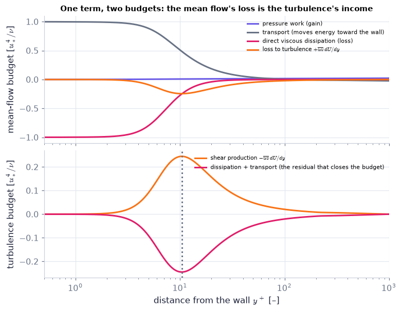

```python
fig, (a1, a2) = plt.subplots(2, 1, figsize=(7.0, 5.4), sharex=True)   # a new figure and its panel(s); figsize in inches
m_, tb_ = bud["mean"], bud["turbulence"]                      # the signed terms of the two budgets (wall units)
a1.semilogx(yp, m_["pressure_work"], color=C_MEAN, label="pressure work (gain)")
a1.semilogx(yp, m_["transport"], color=C_REF, label="transport (moves energy toward the wall)")
a1.semilogx(yp, m_["viscous_dissipation"], color=C_VISC, label="direct viscous dissipation (loss)")
a1.semilogx(yp, m_["loss_to_turbulence"], color=C_RS, label="loss to turbulence $+\\overline{uv}\\,dU/dy$")
a1.set(ylabel="mean-flow budget [$u_*^4/\\nu$]", title="One term, two budgets: the mean flow's loss is the turbulence's income")   # axis labels (with units), title and fixed ranges of this panel
a1.legend(fontsize=7, loc="upper right")   # the legend names every curve
a2.semilogx(yp, tb_["production"], color=C_RS, label="shear production $-\\overline{uv}\\,dU/dy$")
a2.semilogx(yp, tb_["dissipation_plus_transport"], color=C_VISC, label="dissipation + transport (the residual that closes the budget)")
a2.axvline(yp[i_pk], color=C_REF, ls=":")   # a thin reference line
a2.set(xlabel="distance from the wall $y^+$ [–]", ylabel="turbulence budget [$u_*^4/\\nu$]", xlim=(0.5, 1000))   # axis labels (with units), title and fixed ranges of this panel
a2.legend(fontsize=7)   # the legend names every curve
plt.show()   # display the figure
```

**What you see.** Top (mean flow): a purple gain everywhere (the pressure work, of size $U^+/\mathrm{Re}_\tau\approx0.02$ — too small to see on this ±1 scale, yet it supplies everything when summed over the whole channel), a rose loss concentrated at the wall, an orange loss peaking near $y^+\approx10$, and a grey transport curve that carries energy from the core toward the wall. Bottom (turbulence): an orange gain that is the mirror image of the orange loss above, and a rose sink that balances it.

**How to read it.** The two orange curves are the same function with opposite signs — the exchange term. Nearly all of it happens within $y^+<50$ of the wall. ⚠️ The rose curve in the bottom panel is the **residual** that closes the budget (dissipation plus transport together): a mixing-length model carries no information on how that sink splits.

**What would change if…** …$\mathrm{Re}_\tau=5200$: in wall units the peak stays at $y^+\approx10$ with a height just under ¼, and the direct viscous share of the total falls only from 0.45 to about 0.37 — a wall flow never hands *all* of its energy to the turbulence.

📝 **Note.** **N82 [B]** **Buoyant production is potential energy released.** A layer that is unstably stratified (heavy over light) lowers its centre of mass when it mixes; the lost potential energy appears as turbulent kinetic energy. Mixing a stable layer *costs* energy. ⚠️ The temperature here is **potential** temperature. In terms of the thermometer temperature our unstable example cools by 15 K per km: Kundu's $dT/dz=-15<\Gamma_a=-9.8$ K/km ⇔ meteorology's $\Gamma_{met}=15>\Gamma_d=9.8$ K/km — unstable in both conventions.

```
dT/dz = -15.0 K/km (Γ_met = 15.0): dθ/dz = -5.24 K/km, dPE = -17127 J/m², stable initially: False
dT/dz = -6.5 K/km (Γ_met = 6.5): dθ/dz = +3.26 K/km, dPE = +10660 J/m², stable initially: True
```

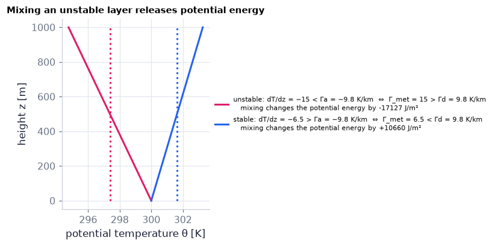

```python
z_mix = np.linspace(0.0, 1000.0, 201)                         # a 1 km deep layer [m]
Gam_a = STRAT.adiabatic_lapse_rate()                          # adiabatic gradient, Kundu sign [K/m] ≈ −9.8e-3
cases = {"unstable: dT/dz = −15 < Γa = −9.8 K/km  ⇔  Γ_met = 15 > Γd = 9.8 K/km": -15e-3,
         "stable: dT/dz = −6.5 > Γa = −9.8 K/km  ⇔  Γ_met = 6.5 < Γd = 9.8 K/km": -6.5e-3}   # two in-situ temperature gradients [K/m]
fig, ax = plt.subplots(figsize=(7.2, 3.6))   # a new figure and its panel(s); figsize in inches
for (name, dTdz), col in zip(cases.items(), (C_VISC, C_BUOY)):
    theta0 = 300.0 + (dTdz - Gam_a)*z_mix                     # potential temperature: its gradient is dT/dz − Γa
    res = ch12.mixing_potential_energy_change(z_mix, theta0, 1/300.0, 1.2)   # mix the column to its mean; α = 1/T, ρ0 = 1.2 kg/m³
    ax.plot(theta0, z_mix, color=col, label=f"{name}\n   mixing changes the potential energy by {res['dPE']:+.0f} J/m²")
    ax.plot(res["T_final"] + 0*z_mix, z_mix, ":", color=col)
    print(f"dT/dz = {dTdz*1e3:+.1f} K/km (Γ_met = {-dTdz*1e3:.1f}): dθ/dz = {(dTdz - Gam_a)*1e3:+.2f} K/km, dPE = {res['dPE']:+.0f} J/m², stable initially: {res['stable_initially']}")
ax.set(xlabel="potential temperature θ [K]", ylabel="height z [m]", title="Mixing an unstable layer releases potential energy")   # axis labels (with units), title and fixed ranges of this panel
ax.legend(fontsize=7, loc="center left", bbox_to_anchor=(1.0, 0.5))   # the legend names every curve
plt.show()   # display the figure
```

**What you see.** Two initial profiles of potential temperature (solid) and the uniform mixed states they end in (dotted). The rose profile decreases with height (unstable); the blue one increases (stable). The legend gives the change of potential energy: negative for the rose case, positive for the blue.

**How to read it.** A negative change is energy handed to the turbulence — the blue term $g\alpha\overline{wT'}>0$ of the budget, with an upward heat flux. A positive change must be paid for by shear production: stable stratification is a sink (C14).

**What would change if…** …the in-situ gradient were exactly adiabatic, $dT/dz=\Gamma_a\approx-9.8$ K/km ($\Gamma_{met}=\Gamma_d$): the potential temperature would be uniform and mixing would neither release nor cost energy.

#### 🎮 Interactive: Where does turbulent energy come from and go?

**Why interactive rather than a static figure:** clicking a height shows the two budgets' bars side by side with the exchange term mirrored; sliding the friction Reynolds number shrinks the mean flow's direct viscous loss — 'same term, opposite sign' is seen, not read.

Start with the **Walkthrough**; the **Explain** tab works every number out with your settings, and the **Derivation** tab steps through the same derivation as above.

**What to try:**

- Click y⁺ ≈ 10: production is at its maximum, ¼ in wall units.
- Go to the centreline: production vanishes with the shear.
- Raise Re_τ from 180 to 5200 and watch the integrated direct dissipation's share fall.
- Turn the wall damping off and see where the peak moves.

```python
show_viz("ch12", "turbulent_energy_budget")   # full-width explainer; ⤢ Full screen for more room
```

🎮 Interactive 4/10 Where does turbulent energy come from and go? Open alone ↗

[interactive chart not shown]

**What would change if…** …we ask how *much* energy flows, and how small the eddies that finally dissipate it are? C07.

### 🧩 Kolmogorov scales $\eta=(\nu^3/\bar\varepsilon)^{1/4},\ u_K=(\nu\bar\varepsilon)^{1/4}$ (12.50) with $\bar\varepsilon\sim(\Delta U)^3/L$ (12.49) and $\eta/L\sim\mathrm{Re}_L^{-3/4}$ (12.51) `C07`

*The question:* If viscosity does the dissipating, why does the dissipation rate not depend on viscosity?

#### The problem in plain words

Stir a cup of water and a cup of honey with the same spoon at the same speed until both are turbulent (you would need a much bigger spoon for honey). The power you put in is set by the spoon and the speed, not by the fluid. All of it ends as heat. So the fluid must arrange for viscosity to remove exactly that power — by making eddies small enough. **Climate hook:** in the atmosphere those eddies are about a millimetre across while a model grid box is kilometres wide: six to seven decades that can only be parameterised.

#### The idea

```
L (big eddies, speed ΔU) → L/2 → L/4 → …  each tier strained by the one above, no viscosity yet  … → η (viscous: Re = 1)
energy passes down at the SAME rate ε̄ ~ ΔU³/L through every tier:   u′(l′) ~ (ε̄ l′)^(1/3),   Re(l′) = u′l′/ν ↓
```

**N87 [B] — the cascade.** Big eddies are unstable and break into smaller ones, which break again. No tier dissipates appreciably until the eddy Reynolds number $u'l'/\nu$ falls to about 1. So the rate at which energy is handed down is fixed at the top, by the big eddies, and viscosity only decides how far down the ladder goes. Symbols: $L$ outer length [m], $\Delta U$ velocity difference across it [m/s], $\eta$ the Kolmogorov length [m], $u_K$ and $\tau_\eta$ the Kolmogorov velocity and time.

> 🔁 **Tools from earlier chapters used in this block** (one line each; the full primers are in the chapters named)
- **order-of-magnitude scaling ("∼")** — replace each quantity by its typical size: ∂u/∂x ~ U/L, ∂²u/∂x² ~ U/L², ∂T/∂x ~ δT/L; ratios of terms decide what can be dropped (Boussinesq, similarity). *(Ch. 4, P130)*
- **np.linalg.solve** — solves B·x = b for a square nonsingular B. *(Ch. 1, P57)*
- **pandas DataFrame for small tables** — `pd.DataFrame(rows)` is a table with named columns; `.to_string(index=False)` prints it without the row numbers. *(earlier chapters)*

📝 **Note.** **N84 [B]** **The outer scale.** $L$ is the cross-stream extent over which the mean velocity changes by $\Delta U$ (the width of a jet, the thickness of a boundary layer), so mean gradients are of order $\Delta U/L$ and the largest eddies have size $L$ and speed $\Delta U$. The sketch shows eddies of many sizes inside one flow.

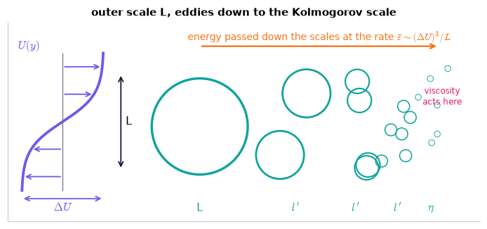

```python
fig, ax = plt.subplots(figsize=(6.2, 3.2))   # a new figure and its panel(s); figsize in inches
scales_sketch(ax, n_tiers=5, seed=0)                          # drawing: eddies of five sizes, from the outer scale L down
plt.show()   # display the figure
```

**How to read it.** Turbulence is not eddies of one size but a whole population, each tier living inside (and strained by) the tier above.

**What would change if…** …the Reynolds number were raised at fixed $L$ and $\Delta U$: more tiers would be added at the small end — the large eddies would not change. The animation below shows it.

#### 🧮 Derivation — $\bar\varepsilon\sim(\Delta U)^3/L$, the Kolmogorov scales, $\eta u_K/\nu=1$ and $\eta/L\sim\mathrm{Re}_L^{-3/4}$ `D11` ★ (Eq. 12.50: $\eta=(\nu^3/\bar\varepsilon)^{1/4},\ u_K=(\nu\bar\varepsilon)^{1/4}$)

**What we want to show.** Estimate how much energy the turbulence dissipates and how small the eddies that do it are.

**Assumptions.** Stationary turbulence; high Reynolds number; Kolmogorov's first hypothesis (small scales depend on ν and ε̄ only).

**The plan.**

1. Production balances dissipation.
2. Estimate production from the large eddies.
3. The smallest eddies know only ν and ε̄: build a length and a velocity from them.
4. Compare with L.

**Tools we use** (each explained before this point): order-of-magnitude scaling (P130) · exponent matching / Π theorem (ch01 C69, `DIM.solve_exponents`)

**We start from**

$$ \begin{array}{l}\text{the turbulent energy budget} \\ \frac{\partial\bar e}{\partial t}+U_j\frac{\partial\bar e}{\partial x_j}=\frac{\partial}{\partial x_j}\big(-\frac1{\rho_0}\overline{pu_j}+2\nu\overline{u_iS'_{ij}}-\frac12\overline{u_i^2u_j}\big)-2\nu\overline{S'_{ij}S'_{ij}}-\overline{u_iu_j}\frac{\partial U_i}{\partial x_j}+g\alpha\overline{u_3T'} \\ \text{(12.47), taken steady, in a shear flow of velocity difference ΔU across a} \\ \text{width L.}\end{array} $$

**Step 1 of 9 — Balance the budget on average.**

$$ \dot W\equiv-\overline{u_iu_j}\dfrac{\partial U_i}{\partial x_j}=\bar\varepsilon $$

- *Why we can do this:* In stationary turbulence $\partial\bar e/\partial t=0$; integrated over the flow the transport (divergence) terms of the Start's budget vanish, leaving production = dissipation. This is $\dot W=\bar\varepsilon$ of (12.49), $\bar\varepsilon\sim(\Delta U)^3/L$.
- *In words:* What the mean flow supplies is dissipated at the same rate.

**Step 2 of 9 — Estimate each factor of the production.**

$$ \overline{u_iu_j}\sim(\Delta U)^2,\qquad\dfrac{\partial U_i}{\partial x_j}\sim\dfrac{\Delta U}{L} $$

- *Why we can do this:* The large eddies are made by the velocity difference, so their velocities are a fraction of ΔU; the mean velocity changes by ΔU over L ("∼" = same order).
- *In words:* Big eddies: speed like ΔU, size like L.

**Step 3 of 9 — Multiply.**

$$ \bar\varepsilon=\dot W\sim(\Delta U)^2\Big[\dfrac{\Delta U}{L}\Big]=\dfrac{(\Delta U)^3}{L} $$

- *Why we can do this:* Steps 1 and 2. This is (12.48)–(12.49), $\dot W\sim\overline{u_iu_j}(\partial U_i/\partial x_j)\sim(\Delta U)^2[\Delta U/L]=(\Delta U)^3/L,\ \bar\varepsilon\sim(\Delta U)^3/L$; no viscosity appears.
- *In words:* The dissipation rate is set by the large scales alone.

**Step 4 of 9 — Seek a length made of ν and ε̄ only.**

$$ \eta=\nu^{a}\,\bar\varepsilon^{\,b} $$

- *Why we can do this:* Kolmogorov's hypothesis: the smallest eddies are far removed from the geometry; the only quantities they can know are the viscosity and the energy handed down to them.
- *In words:* The smallest scale must be a product of powers of ν and ε̄.

**Step 5 of 9 — Match units.**

$$ \mathrm m=\big(\mathrm m^2\mathrm s^{-1}\big)^a\big(\mathrm m^2\mathrm s^{-3}\big)^b\ \Rightarrow\ 2a+2b=1,\quad-a-3b=0 $$

- *Why we can do this:* Both sides must have the same power of metres and of seconds (ch01's Π method).
- *In words:* Two equations for two exponents.

**Step 6 of 9 — Solve.**

$$ a=\tfrac34,\ b=-\tfrac14\ \Rightarrow\ \eta=\big(\nu^3/\bar\varepsilon\big)^{1/4} $$

- *Why we can do this:* From the second equation a = −3b; then −6b + 2b = 1. This is the first of (12.50), $\eta=(\nu^3/\bar\varepsilon)^{1/4},\ u_K=(\nu\bar\varepsilon)^{1/4}$.
- *In words:* The Kolmogorov length.

**Step 7 of 9 — Repeat for a velocity and a time.**

$$ u_K=(\nu\bar\varepsilon)^{1/4},\qquad\tau_\eta=(\nu/\bar\varepsilon)^{1/2} $$

- *Why we can do this:* Same matching with m s⁻¹ and s on the left; the second of $\eta=(\nu^3/\bar\varepsilon)^{1/4}$, $u_K=(\nu\bar\varepsilon)^{1/4}$ (12.50) (the time scale is ours).
- *In words:* The speed and lifetime of the smallest eddies.

**Step 8 of 9 — Form their Reynolds number.**

$$ \dfrac{\eta\,u_K}{\nu}=\dfrac{(\nu^3/\bar\varepsilon)^{1/4}(\nu\bar\varepsilon)^{1/4}}{\nu}=1 $$

- *Why we can do this:* Multiply the two scales; the powers of ε̄ cancel and ν^(3/4+1/4) = ν.
- *In words:* At the Kolmogorov scale inertia and viscosity are equally strong: the cascade stops there.

**Step 9 of 9 — Eliminate ε̄ with step 3.**

$$ \dfrac\eta L\sim\dfrac1L\Big(\dfrac{\nu^3L}{(\Delta U)^3}\Big)^{1/4}=\Big(\dfrac{\nu}{\Delta U\,L}\Big)^{3/4}=\mathrm{Re}_L^{-3/4} $$

- *Why we can do this:* Substitute $\bar\varepsilon\sim(\Delta U)^3/L$; $L^{1/4}/L=L^{-3/4}$. This is (12.51), $\eta/L\sim\mathrm{Re}_L^{-3/4}$ with $\mathrm{Re}_L=\Delta UL/\nu$.
- *In words:* The higher the Reynolds number, the further apart the largest and smallest eddies.

**Result**

$$ \bar\varepsilon\sim(\Delta U)^3/L\ \text{;}\ \eta=(\nu^3/\bar\varepsilon)^{1/4}\ \text{,}\ u_K=(\nu\bar\varepsilon)^{1/4}\ \text{(12.50);}\ \eta/L\sim\mathrm{Re}_L^{-3/4}\ \text{(12.51)} $$

*In words:* Viscosity sets where, not how much

**What it means.** Doubling ν does not change the dissipation rate; it makes the smallest eddies 2^(3/4) = 1.7 times larger. A simulation that resolves η needs $(L/\eta)^3\sim\mathrm{Re}_L^{9/4}$ points. **Fails when:** Re is low (no separation), or the turbulence is not stationary (then ε̄ lags the supply).

**Check it.** Units — ε̄: (m/s)³/m = m²/s³ ✓; η: (m⁶s⁻³/m²s⁻³)^(1/4) = m ✓. Also (ours) $u_K/\Delta U=\mathrm{Re}_L^{-1/4}$, $\tau_\eta\Delta U/L=\mathrm{Re}_L^{-1/2}$. Number: ΔU = 1 m/s, L = 1 m, water: η = 32 µm, Re_L = 10⁶, η/L = 3.2 × 10⁻⁵ ✓.

📝 **Notes taught inside `D11`:** **N85 [B]** the work done on the turbulence, $\dot W\sim\overline{u_iu_j}(\partial U_i/\partial x_j)\sim(\Delta U)^2[\Delta U/L]=(\Delta U)^3/L$ (12.48) (steps 2–3) · **N86 [B]** in a steady state all of it is dissipated, $\dot W=\bar\varepsilon$, so $\bar\varepsilon\sim(\Delta U)^3/L$ (12.49) (steps 1 and 3) · **N88 [B]** the Reynolds number built on the Kolmogorov scales is one, $\eta u_K/\nu=1$ (step 8) · **N89 [B]** the scale separation $\eta/L\sim\mathrm{Re}_L^{-3/4}$ with $\mathrm{Re}_L=\Delta UL/\nu$ (12.51) (step 9).

> ⚠️ **Common confusion (traps in `D11`):** Reading "∼" as "="; forgetting ε̄ is per unit mass; believing ε̄ depends on ν because ν appears in its definition $2\nu\overline{S'_{ij}S'_{ij}}$ (the gradients adjust).

#### ✏️ Tiny example: a stirred tank of water

$\Delta U=1$ m/s, $L=1$ m, $\nu=10^{-6}$ m²/s.

1. $\mathrm{Re}_L=\Delta UL/\nu=10^6$.
2. $\bar\varepsilon\sim\Delta U^3/L=1$ m²/s³ (1 W per kg).
3. $\eta=(\nu^3/\bar\varepsilon)^{1/4}=(10^{-18})^{1/4}=3.2\times10^{-5}$ m = 32 µm.
4. $u_K=(\nu\bar\varepsilon)^{1/4}=3.2$ cm/s; $\tau_\eta=(\nu/\bar\varepsilon)^{1/2}=1$ ms.
5. Check: $\eta u_K/\nu=3.2\times10^{-5}\times3.2\times10^{-2}/10^{-6}=1$ ✓; $\eta/L=3.2\times10^{-5}=(10^6)^{-3/4}$ ✓ — 4.5 decades.
6. A simulation resolving it all needs about $\mathrm{Re}^{9/4}=3\times10^{13}$ grid points.

```python
eps_tank = ch12.dissipation_outer_scaling(1.0, 1.0)           # Eq. (12.49): ε̄ ~ ΔU³/L with ΔU = 1 m/s, L = 1 m [m²/s³]
eta, uK, tau_eta = ch12.kolmogorov_scales(1e-6, eps_tank)     # Eq. (12.50): Kolmogorov length [m], velocity [m/s], time [s] in water
print(f"ε̄ = {eps_tank} m²/s³;  η = {eta:.3e} m, u_K = {uK:.4f} m/s, τ_η = {tau_eta:.1e} s;  η u_K/ν = {eta*uK/1e-6:.3f}")
sep = ch12.scale_separation(1e6)                              # Eq. (12.51) and its relatives at Re_L = 10⁶
print(f"η/L = {sep['eta_over_L']:.3e} = Re^(-3/4);  DNS grid points ≈ {ch12.dns_grid_points(1e6):.2e} = Re^(9/4)")
tiers = ch12.cascade_tiers(1.0, 1.0, 1e-6)                    # the ladder: sizes halving from L down to η
print(f"{tiers['n_tiers']} tiers; eddy Reynolds numbers from {tiers['Re'][0]:.0e} down to {tiers['Re'][-1]:.1f}")
table = pd.DataFrame([ch12.scale_table(c) for c in ch12.SCALE_CASES])[["name", "L", "dU", "nu", "Re_L", "eps", "eta", "tau_eta", "decades"]]   # our four cases
print(table.to_string(index=False, float_format=lambda v: f"{v:.3g}"))
```

```
ε̄ = 1.0 m²/s³;  η = 3.162e-05 m, u_K = 0.0316 m/s, τ_η = 1.0e-03 s;  η u_K/ν = 1.000
η/L = 3.162e-05 = Re^(-3/4);  DNS grid points ≈ 3.16e+13 = Re^(9/4)
15 tiers; eddy Reynolds numbers from 1e+06 down to 2.4
                      name     L  dU      nu     Re_L    eps      eta  tau_eta  decades
             kitchen_mixer  0.05   1   1e-06    5e+04     20  1.5e-05 0.000224     3.52
               wind_tunnel  0.05   1 1.5e-05 3.33e+03     20 0.000114 0.000866     2.64
atmospheric_boundary_layer 1e+03   5 1.5e-05 3.33e+08  0.125 0.000405    0.011     6.39
         ocean_thermocline    10 0.1   1e-06    1e+06 0.0001 0.000316      0.1      4.5
```

**What does the code above do?**

1. `ch12.dissipation_outer_scaling(dU, L)` is $\bar\varepsilon\sim(\Delta U)^3/L$ (12.49) with a constant of order one (1 by default); `ch12.kolmogorov_scales(nu, eps)` returns the three scales of the tiny example: 32 µm, 3.2 cm/s, 1 ms.
2. `ch12.cascade_tiers` lists the ladder: each tier half the size of the one above, speed $(\bar\varepsilon l')^{1/3}$, until the eddy Reynolds number reaches about 1.
3. **N90 [B] — our own table of cases** (`ch12.SCALE_CASES`): a kitchen mixer, a small wind tunnel, the atmospheric boundary layer ($\Delta U=5$ m/s, $L=1$ km: $\bar\varepsilon=0.125$ m²/s³, $\eta\approx0.4$ mm, 6.4 decades between $L$ and $\eta$) and the ocean thermocline ($\bar\varepsilon=10^{-4}$ m²/s³, $\eta\approx0.3$ mm). The Kolmogorov scale is a fraction of a millimetre almost everywhere in nature — only the *range* of scales changes.

```python
# From scratch: the exponents of η = ν^a ε̄^b from dimensions alone (a 2 × 2 linear system)
# units: ν [m² s⁻¹], ε̄ [m² s⁻³], η [m¹ s⁰] →  metres: 2a + 2b = 1,  seconds: −a − 3b = 0
a_, b_ = np.linalg.solve([[2.0, 2.0], [-1.0, -3.0]], [1.0, 0.0])   # solve the two exponent equations
print(f"η = ν^{a_:.2f} ε̄^{b_:.2f}")                           # 0.75 and −0.25: η = (ν³/ε̄)^(1/4)
assert np.allclose([a_, b_], [float(x) for x in ch12.kolmogorov_exponents()["eta"]])   # the library's exact fractions 3/4, −1/4
grp = DIM.solve_exponents("eta", ["nu", "eps"], {"eta": {"L": 1}, "nu": {"L": 2, "T": -1}, "eps": {"L": 2, "T": -3}})   # Ch. 1's Π-theorem solver
print("Ch. 1 solver: the group", grp, "is dimensionless")      # η ν^(−3/4) ε̄^(1/4)
abl = ch12.scale_table("atmospheric_boundary_layer")          # the atmospheric case of the table
eta_mine = (abl["nu"]**3/abl["eps"])**0.25                    # Eq. (12.50) by hand
assert np.isclose(eta_mine, ch12.kolmogorov_scales(abl["nu"], abl["eps"])[0]) and np.isclose(eta_mine, abl["eta"])
print(f"atmospheric boundary layer: η = {eta_mine*1e3:.2f} mm")
```

```
η = ν^0.75 ε̄^-0.25
```

```
Ch. 1 solver: the group {'eta': Fraction(1, 1), 'nu': Fraction(-3, 4), 'eps': Fraction(1, 4)} is dimensionless
atmospheric boundary layer: η = 0.41 mm
```

**What does the code above do?**

1. Matching metres and seconds gives two equations for the two exponents; `np.linalg.solve` returns $a=\tfrac34$, $b=-\tfrac14$.
2. Chapter 1's `DIM.solve_exponents` finds the same group as a dimensionless product (so its exponents are the negatives).
3. The last lines evaluate $\eta=(\nu^3/\bar\varepsilon)^{1/4}$ by hand for the atmospheric boundary layer and compare with the library: 0.4 mm.

```python
Re_list = 10.0**np.arange(3.0, 8.01, 1.0 if FAST else 0.5)    # Re_L from 10³ to 10⁸, one frame per (half-)decade
K_ax = np.logspace(0, 8, 300)                                 # wavenumbers K L [–] (L = 1 m)
fig, (a1, a2) = plt.subplots(1, 2, figsize=(8.6, 3.5))   # a new figure and its panel(s); figsize in inches
a1.set(xlim=(2e-7, 3), ylim=(0, 1), xscale="log", yticks=[], xlabel="eddy size l / L [–]")   # axis labels (with units), title and fixed ranges of this panel
a1.invert_xaxis()                                             # big eddies on the left, small on the right
(tier_dots,) = a1.plot([], [], "o", color=C_FLUC, ms=5)       # the tiers of the cascade
vl_L = a1.axvline(1.0, color=C_MEAN, lw=2); vl_eta = a1.axvline(1.0, color=C_VISC, lw=2); vl_lam = a1.axvline(1.0, color=C_RS, lw=1.2, ls="--")   # a thin reference line
a1.text(1.0, 0.92, " L", color=C_MEAN); t_eta = a1.text(1.0, 0.92, " η", color=C_VISC); t_lam = a1.text(1.0, 0.8, " λ", color=C_RS)
(sp_line,) = a2.loglog([], [], color=C_FLUC)                  # the model spectrum
a2.loglog(K_ax, 1.5*K_ax**(-5/3), ":", color=C_REF, label="$C\\bar\\varepsilon^{2/3}K^{-5/3}$")
a2.set(xlim=(1, 1e8), ylim=(1e-14, 1), xlabel="wavenumber K L [–]", ylabel="E(K) / (ΔU² L) [–]")   # axis labels (with units), title and fixed ranges of this panel
a2.legend(fontsize=8)   # the legend names every curve

def update(i):                                                # frame i: the ladder and the spectrum at Re_list[i]
    Re = Re_list[i]
    tr = ch12.cascade_tiers(1.0, 1.0, 1.0/Re)                 # L = 1 m, ΔU = 1 m/s, ν = 1/Re
    so = ch12.scale_ordering(Re)                              # η/L and λ/L at this Reynolds number
    tier_dots.set_data(tr["size"], 0.5 + 0*tr["size"])   # move the drawn objects to this frame's values
    vl_eta.set_xdata([so["eta_over_L"]]*2); t_eta.set_x(so["eta_over_L"])   # move the drawn objects to this frame's values
    vl_lam.set_xdata([so["lambda_over_L"]]*2); t_lam.set_x(so["lambda_over_L"])   # move the drawn objects to this frame's values
    sp_line.set_data(K_ax, ch12.model_spectrum(K_ax, 1.0, 1.0/Re, L=1.0, kind="pope"))   # move the drawn objects to this frame's values
    a1.set_title(f"Re_L = 10^{np.log10(Re):.1f}: {tr['n_tiers']} tiers, η/L = {so['eta_over_L']:.1e}", fontsize=10)   # label / range / scale of this axis
    a2.set_title(f"−5/3 range ≈ {ch12.inertial_range_decades(Re):.1f} decades (L to η)", fontsize=10)   # label / range / scale of this axis
    return tier_dots, sp_line   # hand the result back to the caller

show_animation(animate(update, frames=len(Re_list), fig=fig, interval=600), player="frames", dpi=40)   # step through the Reynolds numbers
```

[figure not shown]

Once Loop Reflect

**What does the code above do?**

1. Each frame is one Reynolds number; $L$ and $\Delta U$ are fixed (so $\bar\varepsilon=1$ m²/s³ in every frame) and only $\nu$ changes.
2. Left: the tiers from `ch12.cascade_tiers` on a logarithmic size axis, with $L$ (purple), the Taylor microscale $\lambda$ (orange dashed) and $\eta$ (rose) from `ch12.scale_ordering`.
3. Right: a model spectrum for the whole range (`ch12.model_spectrum`, explained in C08) against the −5/3 line.

**What you see.** Step through: on the left the purple line at $L$ never moves, the rose line at $\eta$ slides to the right (smaller sizes) and teal tiers are added at the small end. On the right the spectrum's left end stays put while its straight −5/3 part grows longer toward large wavenumbers.

**How to read it.** The left end never moves: a higher Reynolds number makes the cascade **longer, not stronger**. The energy supply $\Delta U^3/L$ is the same in every frame; viscosity only sets where the ladder ends.

**What would change if…** …we doubled $\Delta U$ instead of lowering $\nu$: the supply would rise eightfold *and* $\eta$ would shrink by $2^{-3/4}=0.59$ — both ends would move.

📝 **Note.** **N91 [B]** **Where the Taylor microscale sits.** Eliminate $\bar\varepsilon$ between the isotropic relation $\bar\varepsilon=15\nu\overline{u^2}/\lambda_g^2$ (12.43) and the outer estimate $\bar\varepsilon\sim(\Delta U)^3/L$ (12.49): $\frac{(\Delta U)^3}L\propto\frac{\nu\overline{u^2}}{\lambda_T^2}\Rightarrow\frac{\lambda_T^2}{L^2}\propto\frac{\overline{u^2}}{(\Delta U)^2}\Big(\frac\nu{\Delta UL}\Big)\propto\frac1{\mathrm{Re}_L}$, or

$$\frac{\lambda_T}L\propto\mathrm{Re}_L^{-1/2}\qquad\text{(12.52)}$$

⚠️ $\lambda_T$ is **not** the size of the dissipating eddies: the relation $\bar\varepsilon=15\nu\overline{u^2}/\lambda_g^2$ pairs it with the *large-eddy* velocity, not with $u_K$. It lies between the two ends, $\lambda_T/\eta\sim\mathrm{Re}_L^{1/4}$.

📝 **Note.** **N92 [B]** **The ordering of the scales.** $R_\lambda\sim\mathrm{Re}_L^{1/2}$, and at high Reynolds number $\eta<\lambda_T<\Lambda_{(f\text{ or }g)}<L$.

```python
for Re in (1e2, 1e4, 1e6, 1e8):                               # four outer Reynolds numbers
    so = ch12.scale_ordering(Re)                              # η/L, λ_g/L, R_λ and whether η < λ_g < L
    print(f"Re_L = {Re:.0e}: η/L = {so['eta_over_L']:.1e}, λ/L = {so['lambda_over_L']:.1e}, λ/η = {so['lambda_over_L']/so['eta_over_L']:5.1f}, R_λ = {so['R_lambda']:.0f}, ordered: {so['ordered']}")
```

```
Re_L = 1e+02: η/L = 3.2e-02, λ/L = 3.9e-01, λ/η =  12.2, R_λ = 39, ordered: True
Re_L = 1e+04: η/L = 1.0e-03, λ/L = 3.9e-02, λ/η =  38.7, R_λ = 387, ordered: True
Re_L = 1e+06: η/L = 3.2e-05, λ/L = 3.9e-03, λ/η = 122.5, R_λ = 3873, ordered: True
Re_L = 1e+08: η/L = 1.0e-06, λ/L = 3.9e-04, λ/η = 387.3, R_λ = 38730, ordered: True
```

**What does the code above do?**

`ch12.scale_ordering(Re_L)` evaluates the three ratios. Each factor 100 in $\mathrm{Re}_L$ divides $\eta/L$ by $100^{3/4}=31.6$, $\lambda/L$ by 10, and multiplies $\lambda/\eta$ by $100^{1/4}=3.2$ and $R_\lambda$ by 10.

**What would change if…** …we ask how the energy is shared among the tiers in between? That is a spectrum, and dimensional analysis gives its shape (C08).

### 🧩 Kolmogorov's inertial-subrange law $S_{11}(k_1)=C_1\bar\varepsilon^{2/3}k_1^{-5/3}$ for $2\pi/L\ll k_1\ll2\pi/\eta$ (12.54, slip #1 corrected) `C08`

*The question:* Why do spectra from a tidal channel, a jet and the atmosphere all fall with the same slope?

#### The problem in plain words

Plot the spectrum of the wind on a mast, of the current in a tidal channel, of the flow behind a grid: on log–log paper, over the middle range of scales, all three are straight lines with the same slope. Something universal is going on. Eddies in that range are too small to know about the geometry and too big to feel viscosity; all they know is the rate at which energy is handed through them.

#### The idea

Only $\bar\varepsilon$ [m²/s³] and $k_1$ [1/m] are available; $S_{11}$ has units m³/s². There is exactly one way to build m³/s² from them.

| Range | Wavenumbers | What sets the spectrum |
| --- | --- | --- |
| energy-containing | $k_1\sim2\pi/L$ | the particular flow — not universal |
| inertial | $2\pi/L\ll k_1\ll2\pi/\eta$ | $\bar\varepsilon$ alone: slope −5/3, universal |
| dissipation | $k_1\eta\sim1$ | $\bar\varepsilon$ and $\nu$: universal in Kolmogorov units |

> 🔁 **Tools from earlier chapters used in this block** (one line each; the full primers are in the chapters named)
- **live widgets (kernel only)** — ipywidgets sliders that re-run a function while a kernel runs; frozen on the page, so pair with a static figure. *(Ch. 1, P47)*

#### 🧮 Derivation — The universal spectrum, Kolmogorov's law $S_{11}=C_1\bar\varepsilon^{2/3}k_1^{-5/3}$ (12.54, corrected) and the normalisation `D12` ★★ (Eq. 12.54: $S_{11}(k_1)=C_1\bar\varepsilon^{2/3}k_1^{-5/3}$)

**What we want to show.** Find the shape of the spectrum between the large eddies and the smallest ones without solving any equation.

**Assumptions.** High Reynolds number; local isotropy; the inertial range knows neither L nor ν (Kolmogorov's second hypothesis).

**The plan.**

1. Find the units of $S_{11}$.
2. At small scales let it depend on ε̄, ν, k₁: two dimensionless groups.
3. In the inertial range drop ν: one group, a power law.
4. Fix the constant's convention.

**Tools we use** (each explained before this point): units of a spectral density (P293) · Π theorem (ch01 C69) · log–log slopes (P13)

**We start from**

$$ S_{11}(k_1)=\dfrac1{2\pi}\displaystyle\int_{-\infty}^{+\infty}R_{11}(r_1)\,e^{-ik_1r_1}\,dr_1\ \text{(12.45).} $$

**Step 1 of 9 — Find the units of the spectrum.**

$$ [S_{11}]=[R_{11}]\,[r_1]=\mathrm m^2\mathrm s^{-2}\times\mathrm m=\mathrm m^3\mathrm s^{-2} $$

- *Why we can do this:* In $S_{11}(k_1)=\frac1{2\pi}\int_{-\infty}^{+\infty}R_{11}(r_1)\,e^{-ik_1r_1}\,dr_1$ (12.45) a correlation (velocity²) is integrated over a distance; the exponential and 1/2π have no units.
- *In words:* A spectrum is "variance per unit wavenumber".

**Step 2 of 9 — List what small-scale eddies can depend on.**

$$ S_{11}=\mathrm{fn}(\bar\varepsilon,\ \nu,\ k_1) $$

- *Why we can do this:* Far down the cascade the mean shear is forgotten (D11 step 4); the wavenumber says which eddy size we ask about. Four quantities, two dimensions (m, s) ⇒ two groups.
- *In words:* One dimensionless spectrum as a function of one dimensionless wavenumber.

**Step 3 of 9 — Form the two groups.**

$$ \dfrac{S_{11}(k_1)}{\nu^{5/4}\bar\varepsilon^{1/4}}=\Phi\Big(\dfrac{k_1\nu^{3/4}}{\bar\varepsilon^{1/4}}\Big) $$

- *Why we can do this:* $\nu^{5/4}\bar\varepsilon^{1/4}$ has units m^(10/4+2/4)s^(−5/4−3/4) = m³s⁻²; $\nu^{3/4}\bar\varepsilon^{-1/4}$ is a length. This is the first form of (12.53), $\frac{S_{11}(k_1)}{u_K^2\eta}=\Phi(k_1\eta)$.
- *In words:* In these units every flow's small-scale spectrum is the same curve Φ.

**Step 4 of 9 — Recognise the Kolmogorov scales.**

$$ \dfrac{S_{11}(k_1)}{u_K^2\,\eta}=\Phi(k_1\eta)\quad\text{for }k_1\gg2\pi/L $$

- *Why we can do this:* $u_K^2\eta=(\nu\bar\varepsilon)^{1/2}(\nu^3/\bar\varepsilon)^{1/4}=\nu^{5/4}\bar\varepsilon^{1/4}$ and $\eta=\nu^{3/4}\bar\varepsilon^{-1/4}$ by (12.50), $\eta=(\nu^3/\bar\varepsilon)^{1/4},\ u_K=(\nu\bar\varepsilon)^{1/4}$. The second form of (12.53), $\frac{S_{11}(k_1)}{u_K^2\eta}=\Phi(k_1\eta)$.
- *In words:* Velocity² × length of the smallest eddies is the natural unit.

**Step 5 of 9 — In the inertial range drop the viscosity.**

$$ S_{11}=C_1\,\bar\varepsilon^{\,a}\,k_1^{\,b}:\quad\mathrm m^3\mathrm s^{-2}=\big(\mathrm m^2\mathrm s^{-3}\big)^a\big(\mathrm m^{-1}\big)^b $$

- *Why we can do this:* For $2\pi/L\ll k_1\ll2\pi/\eta$ eddies are too small to feel L and too large to feel ν. Three quantities, two dimensions ⇒ one group ⇒ a pure power law.
- *In words:* Only one combination of ε̄ and k₁ has the units of a spectrum.

**Step 6 of 9 — Solve for the exponents.**

$$ -3a=-2,\ \ 2a-b=3\ \Rightarrow\ a=\tfrac23,\ b=-\tfrac53:\qquad S_{11}(k_1)=C_1\,\bar\varepsilon^{2/3}\,k_1^{-5/3} $$

- *Why we can do this:* Seconds give a; metres then give b = 2a − 3 = −5/3. This is (12.54), $S_{11}(k_1)=C_1\bar\varepsilon^{2/3}k_1^{-5/3}$ with the exponent the page misprints as +5/3 (slip #1).
- *In words:* The −5/3 law.

**Step 7 of 9 — Check it against the universal form.**

$$ \Phi(k_1\eta)=C_1\,(k_1\eta)^{-5/3}\ \Rightarrow\ S_{11}=C_1u_K^2\eta\,(k_1\eta)^{-5/3}=C_1\bar\varepsilon^{2/3}k_1^{-5/3} $$

- *Why we can do this:* $u_K^2\eta^{-2/3}=(\nu\bar\varepsilon)^{1/2}(\nu^3/\bar\varepsilon)^{-1/6}=\bar\varepsilon^{2/3}$: ν cancels only for the exponent −5/3.
- *In words:* The inertial range is the part of Φ where viscosity drops out.

**Step 8 of 9 — State the range of validity.**

$$ \dfrac{2\pi}{L}\ll k_1\ll\dfrac{2\pi}{\eta},\qquad\dfrac{L}{\eta}\sim\mathrm{Re}_L^{3/4} $$

- *Why we can do this:* Both conditions of step 5; their ratio is D11's $\eta/L\sim\mathrm{Re}_L^{-3/4}$ (12.51).
- *In words:* The −5/3 range is ¾ log₁₀Re_L decades wide at most.

**Step 9 of 9 — Fix what the constant refers to.**

$$ \displaystyle\int_{-\infty}^{+\infty}S_{11}(k_1)\,dk_1=\overline{u_1^2}=\int_0^{+\infty}2S_{11}(k_1)\,dk_1 $$

- *Why we can do this:* $S_{11}$ is even (D05), so one-sided plots show $2S_{11}$. This is (12.55), $\int_{-\infty}^{+\infty}S_{11}(k_1)\,dk_1=\overline{u_1^2}=\int_0^{+\infty}2S_{11}(k_1)\,dk_1$: a quoted $C_1$ is for the two-sided form; the one-sided constant is twice as large.
- *In words:* Two conventions, a factor 2.

**Result**

$$ S_{11}/(u_K^2\eta)=\Phi(k_1\eta)\ \text{(12.53);}\ S_{11}(k_1)=C_1\bar\varepsilon^{2/3}k_1^{-5/3}\ \text{for}\ 2\pi/L\ll k_1\ll2\pi/\eta\ \text{(12.54)} $$

*In words:* In the inertial range the spectrum falls 46-fold per decade

**What it means.** The same argument with a temperature dimension gives the Obukhov–Corrsin spectrum $S_T\propto\bar\varepsilon_T\bar\varepsilon^{-1/3}K^{-5/3}$ (12.113), and with a length gives Richardson's $K\sim\bar\varepsilon^{1/3}l^{4/3}$. **Fails when:** Re_L is too low for a range to exist, or other parameters enter (stratification: N; rotation: f — Ch. 13).

📝 **Notes taught inside `D12`:** **N93 [B]** the universal form at high wavenumber, $\frac{S_{11}(k_1)}{\nu^{5/4}\bar\varepsilon^{1/4}}=\Phi\big(\frac{k_1\nu^{3/4}}{\bar\varepsilon^{1/4}}\big)$, or $\frac{S_{11}(k_1)}{u_K^2\eta}=\Phi(k_1\eta)$ for $k_1\gg2\pi/L$ (12.53) (steps 3–4) · **N94 [B]** the normalisation $\int_{-\infty}^{+\infty}S_{11}(k_1)\,dk_1=\overline{u_1^2}=\int_0^{+\infty}2S_{11}(k_1)\,dk_1$ (12.55) (step 9).

> ⚠️ **Common confusion (traps in `D12`):** The sign of the exponent (slip #1); one- vs two-sided constants; using k in cycles per metre with formulas in rad/m; expecting the law at the largest scales.

> ⚠️ **slip #1 — the book prints** $S_{11}(k_1)=\mathit{const}\cdot\bar\varepsilon^{2/3}\cdot k_1^{5/3}$ **; the correct form is** $S_{11}(k_1)=C_1\bar\varepsilon^{2/3}k_1^{-5/3}$ (12.54). Three checks: units (D12 step 5 and the cell below); the sentence after it in the book calls it the $k^{-5/3}$ law; and a spectrum that *rose* with $k_1$ would have infinite variance.

```python
k_two = np.array([10.0, 100.0])                               # two wavenumbers a decade apart [rad/m]
ok = ch12.inertial_spectrum_1d(k_two, 1.0)                    # Eq. (12.54), corrected: ε̄ = 1 m²/s³, two-sided constant
bad = ch12.inertial_spectrum_1d(k_two, 1.0, printed=True)     # the form as printed (+5/3), kept only to show it fails
print(f"corrected: S_11 = {ok} m³/s², ratio over one decade {ok[1]/ok[0]:.4f} = 10^(-5/3)")
print(f"printed:   ratio over one decade {bad[1]/bad[0]:.1f} — the spectrum would RISE 46-fold per decade")
dims = {"eps": np.array([Fraction(2), Fraction(-3)]), "k": np.array([Fraction(-1), Fraction(0)])}   # exponents of (metre, second) in ε̄ and k_1
for p in (Fraction(-5, 3), Fraction(5, 3)):                   # the corrected and the printed exponent of k_1
    m_exp, s_exp = Fraction(2, 3)*dims["eps"] + p*dims["k"]   # units of ε̄^(2/3) k_1^p
    print(f"ε̄^(2/3) k^({p}) has units m^({m_exp}) s^({s_exp})" + ("  = m³/s², the units of S_11 ✓" if (m_exp, s_exp) == (3, -2) else "  ✗ not m³/s²"))
```

```
corrected: S_11 = [0.0053 0.0001] m³/s², ratio over one decade 0.0215 = 10^(-5/3)
printed:   ratio over one decade 46.4 — the spectrum would RISE 46-fold per decade
ε̄^(2/3) k^(-5/3) has units m^(3) s^(-2)  = m³/s², the units of S_11 ✓
ε̄^(2/3) k^(5/3) has units m^(-1/3) s^(-2)  ✗ not m³/s²
```

**What does the code above do?**

1. `ch12.inertial_spectrum_1d(k1, eps)` is the corrected law; `printed=True` reproduces the page so that we can watch it fail.
2. The loop does the unit arithmetic with exact fractions (`Fraction`, Ch. 1 P60): $(\mathrm m^2\mathrm s^{-3})^{2/3}(\mathrm m^{-1})^{-5/3}=\mathrm m^{3}\mathrm s^{-2}$ ✓, while the printed exponent gives $\mathrm m^{-1/3}\mathrm s^{-2}$ ✗.

📝 **Note.** **N95 [B]** **The three-dimensional spectrum.** Summing the energy over all directions of the wavevector gives the energy spectrum $E(K)$ we have used since §12.1 (the book's letter for it is $S(K)$), with $\bar e=\int_0^\infty E(K)\,dK$ and, in the inertial range, $E(K)=C\bar\varepsilon^{2/3}K^{-5/3}$ with the *Kolmogorov constant* $C\approx1.5$ (a measured, public value: Sreenivasan 1995, *Phys. Fluids* 7, 2778). Isotropy links it to the one-dimensional spectrum: the one-sided constant is $C_1=\tfrac{18}{55}C$, the book's two-sided one $\tfrac{9}{55}C$.

```python
print(ch12.kolmogorov_constants(1.5))                         # C = 1.5 → one-sided C_1 = 18C/55 = 0.491, two-sided 9C/55 = 0.245
ratio = ch12.one_dimensional_from_3d(10.0, lambda K: 1.5*K**(-5/3))/(1.5*10.0**(-5/3))   # integrate the 3-D law down to 1-D at k_1 = 10
print(f"1-D / 3-D at the same wavenumber: {ratio:.5f} = 18/55 = {18/55:.5f};  S(K = 10) = {ch12.inertial_spectrum_3d(10.0, 1.0):.5f} m³/s²")
```

```
{'C': 1.5, 'C1_one_sided': 0.4909090909090909, 'C1_two_sided': 0.24545454545454545}
1-D / 3-D at the same wavenumber: 0.32727 = 18/55 = 0.32727;  S(K = 10) = 0.03232 m³/s²
```

**What does the code above do?**

`ch12.one_dimensional_from_3d(k1, E_fn)` does the isotropic integral that turns a three-dimensional spectrum into the one-dimensional one a probe measures; for a −5/3 law the ratio is exactly $18/55=0.327$.

📝 **Note.** **N98 [C]** **First confirmation.** The −5/3 law was first confirmed convincingly in a tidal channel, where the Reynolds number is enormous and the inertial range spans decades; oceanic and atmospheric spectra have confirmed it ever since (the temperature spectra of C15 are its scalar twin).

📝 **Note.** **N99 [C]** **Why models can work at all.** Because the small scales are universal, a turbulence model (C12, C13) or a large-eddy simulation (Ch. 10) may replace them by a formula that knows only $\bar\varepsilon$ and $\nu$.

> 📎 **Primer — quadrature on a logarithmic grid.** `P298` · A spectrum spans many decades, so we integrate it on a logarithmic grid. With $K=e^s$, $dK=K\,ds$, so $\int E\,dK=\int E\,K\,ds$ with $s=\ln K$ evenly spaced.

```python
K_ = np.logspace(0, 6, 601)                       # wavenumbers from 1 to 10⁶, evenly spaced in ln K
approx = np.trapezoid(K_**(-5/3)*K_, np.log(K_))  # ∫ K^(−5/3) dK done as ∫ K^(−5/3) K d(ln K)
print(round(approx, 4), 1.5*(1 - 1e-4))           # exact: 1.5 (1 − 10⁻⁴)
```

```
1.4999 1.49985
```

📝 **Note.** **N97 [B]** **A model spectrum for the whole range.** Pao's (1965) form multiplies the inertial law by a viscous roll-off, $E(K)=C\bar\varepsilon^{2/3}K^{-5/3}\exp\{-\tfrac32C(K\eta)^{4/3}\}$; with an outer scale $L$ we add an energy-range factor of the kind used by Pope (2000) (`ch12.model_spectrum`). These formulas are from the literature, not from the book. Two integral checks any spectrum must pass: $\int_0^\infty E\,dK=\bar e$ and $2\nu\int_0^\infty K^2E\,dK=\bar\varepsilon$.

#### ✏️ Tiny example: one point on the −5/3 line

$\bar\varepsilon=1$ m²/s³, $k_1=100$ rad/m (a 6 cm eddy), two-sided constant $C_1=(9/55)\times1.5=0.245$.

1. $\bar\varepsilon^{2/3}=1$.
2. $k_1^{-5/3}=100^{-5/3}=4.64\times10^{-4}$.
3. $S_{11}=0.245\times4.64\times10^{-4}=1.14\times10^{-4}$ m³/s².
4. Ten times the wavenumber: $10^{-5/3}=1/46.4$ — the spectrum falls 46-fold per decade.
5. Units: $(\mathrm m^2/\mathrm s^3)^{2/3}(1/\mathrm m)^{-5/3}=\mathrm m^{4/3+5/3}\mathrm s^{-2}=\mathrm m^3/\mathrm s^2$ ✓.

```python
K = np.logspace(0, 6, 400)                                    # wavenumbers [rad/m]
E = ch12.model_spectrum(K, 1.0, 1e-6, L=1.0, kind="pope")     # model E(K): ε̄ = 1 m²/s³, water, outer scale 1 m (the stirred tank of C07)
slope, const = ch12.fit_inertial_range(K, E, band=(50, 2000)) # least-squares straight line on log–log axes in the band 50 … 2000 rad/m
print(f"fitted slope in the inertial band: {slope:.3f} (−5/3 = {-5/3:.3f});  S_11(100) = {ch12.inertial_spectrum_1d(100.0, 1.0):.3e} m³/s²")
E_pao = ch12.model_spectrum(K, 1.0, 1e-6, kind="pao")         # Pao's form without an energy range
print(f"dissipation integral 2ν∫K²E dK = {2e-6*np.trapezoid(K**3*E_pao, np.log(K)):.4f} (should be ε̄ = 1);  energy ∫E dK = {np.trapezoid(E*K, np.log(K)):.3f} m²/s²")
k_eta, S_norm = ch12.kolmogorov_normalize_spectrum(K, E, 1e-6, 1.0)   # Eq. (12.53): (K η, E/(u_K² η))
print(f"in Kolmogorov units the spectrum ends near Kη = {k_eta[np.argmax(S_norm < 1e-3*S_norm[200])]:.2f}")
```

```
fitted slope in the inertial band: -1.677 (−5/3 = -1.667);  S_11(100) = 1.139e-04 m³/s²
dissipation integral 2ν∫K²E dK = 1.0000 (should be ε̄ = 1);  energy ∫E dK = 0.981 m²/s²
in Kolmogorov units the spectrum ends near Kη = 0.81
```

**What does the code above do?**

1. `ch12.model_spectrum(K, eps, nu, L, kind)` returns $E(K)$; `ch12.fit_inertial_range` fits a power law in a band and returns (slope, prefactor): the slope is −1.68, i.e. −5/3 within 0.02 (the band still feels a little of both ends).
2. The dissipation integral of Pao's form returns $\bar\varepsilon$ to 4 digits — on the logarithmic grid of primer P298.
3. `ch12.kolmogorov_normalize_spectrum` puts the spectrum in the universal variables of $\frac{S_{11}(k_1)}{u_K^2\eta}=\Phi(k_1\eta)$ (12.53).

```python
# From scratch: the slope of the inertial range by a straight-line fit on log–log axes
band = (K >= 50) & (K <= 2000)                                # the wavenumbers inside the band
slope_mine = np.polyfit(np.log(K[band]), np.log(E[band]), 1)[0]   # slope of ln E against ln K (P13)
assert abs(slope_mine + 5/3) < 0.02                           # −5/3 within 0.02
assert np.isclose(slope_mine, ch12.fit_inertial_range(K, E, (50, 2000))[0])   # same number as the library
print(f"slope by np.polyfit: {slope_mine:.4f}")
```

```
slope by np.polyfit: -1.6771
```

**What does the code above do?**

A power law is a straight line on log–log axes, so `np.polyfit` of $\ln E$ against $\ln K$ gives the exponent; the library does exactly this.

📝 **Note.** **N96 [B]** **Spectra in Kolmogorov scaling collapse at high wavenumber.** Plot $E/(u_K^2\eta)$ against $K\eta$: the dissipation end is one curve for every flow and every Reynolds number, and only the low-wavenumber end (the energy-containing eddies) moves. The slider figure shows our model spectra; measured spectra from very different flows do the same.

```python
Keta = np.logspace(-6, 0.5, 150)                             # the universal axis K η [–]

def f3(logRe):                                                # curves for one outer Reynolds number
    Re = 10.0**logRe
    nu_ = 1.0/Re                                              # L = 1 m, ΔU = 1 m/s → ε̄ = 1 m²/s³, ν = 1/Re
    eta_, uK_, _ = ch12.kolmogorov_scales(nu_, 1.0)           # Kolmogorov scales at this Reynolds number
    E_ = ch12.model_spectrum(Keta/eta_, 1.0, nu_, L=1.0, kind="pope")   # the model spectrum on the universal axis
    lo, hi = 2*np.pi*eta_*6.0, 0.1                            # a rough inertial range: well above 2π/L, well below 1/η
    return {"model spectrum E/(u_K² η)": (Keta, E_/(uK_**2*eta_)),   # hand the result back to the caller
            "−5/3 law: C (Kη)^(−5/3)": (Keta, 1.5*Keta**(-5/3)),
            "inertial range (2π/L ≪ K ≪ 2π/η)": ([lo, hi] if lo < hi else [hi, hi], [1e-2, 1e-2])}

figF3 = slider_figure(f3, "log10 Re_L", np.linspace(3.0, 8.0, 11), xlabel="K η [–]", ylabel="E / (u_K² η) [–]",
                      title="In Kolmogorov units the small-scale end is one curve")
figF3.update_xaxes(type="log", range=[-6, 0.5])               # logarithmic K η axis
figF3.update_yaxes(type="log", range=[-3, 10])                # logarithmic spectrum axis
figF3.show()   # display the interactive figure (the slider works on the web page too)
```

[interactive chart not shown]

**What does the code above do?**

1. `f3(logRe)` builds the model spectrum for one Reynolds number and expresses it in Kolmogorov units.
2. The horizontal bar at the bottom marks a rough inertial range; it does not exist at $\mathrm{Re}_L=10^3$ and spans about four decades at $10^8$.

**What you see.** Drag the Reynolds number up: the right-hand end of the teal curve (the roll-off near $K\eta\approx0.3$) does not move at all; the hump on the left slides further left along the dotted −5/3 line, and the bar marking the inertial range grows.

**How to read it.** The right-hand end is the same curve for every Reynolds number — that is the universality of $\frac{S_{11}(k_1)}{u_K^2\eta}=\Phi(k_1\eta)$ (12.53). The inertial range is the straight stretch between the two ends; it needs $\mathrm{Re}_L\gtrsim10^5$ to span even one clean decade.

**What would change if…** …we plotted against $KL$ instead (outer scaling): the *left* end would stay fixed and the roll-off would move — the view of animation A4. Both are the same spectra; the scaling decides which end looks universal.

> ▶️ **Live cell.** The widget below needs a running Python kernel. On the web page it is frozen — open this notebook in Colab (button at the top) or run it locally to drag the sliders.

```python
def cascade_live(dU=1.0, L=1.0, log_nu=-6.0):                 # free velocity difference [m/s], outer scale [m] and log10 of viscosity [m²/s]
    nu_ = 10.0**log_nu
    eps_ = ch12.dissipation_outer_scaling(dU, L)              # ε̄ ~ ΔU³/L
    eta_, uK_, tau_ = ch12.kolmogorov_scales(nu_, eps_)       # Kolmogorov scales
    Kk = np.logspace(np.log10(0.3/L), np.log10(3/eta_), 300)  # from the outer scale to beyond η
    fig, ax = plt.subplots(figsize=(6.2, 3.4))   # a new figure and its panel(s); figsize in inches
    ax.loglog(Kk, ch12.model_spectrum(Kk, eps_, nu_, L=L, kind="pope"), color=C_FLUC)   # the model spectrum, dimensional
    ax.loglog(Kk, 1.5*eps_**(2/3)*Kk**(-5/3), ":", color=C_REF)                          # the −5/3 law
    ax.axvline(2*np.pi/L, color=C_MEAN); ax.axvline(1/eta_, color=C_VISC)                # the two ends
    ax.set(xlabel="K [rad/m]", ylabel="E(K) [m³/s²]", title=f"Re_L = {dU*L/nu_:.1e}, ε̄ = {eps_:.2g} m²/s³, η = {eta_*1e3:.3g} mm")   # axis labels (with units), title and fixed ranges of this panel
    plt.show()   # display the figure

live(cascade_live, dU=(0.1, 10.0, 0.1), L=(0.01, 100.0, 0.01), log_nu=(-6.0, -4.0, 0.1))   # sliders (kernel only)
```

▶️ **Live cell.** These sliders need a running Python kernel, so they are frozen on this page. Press **Open in Colab** at the top (or run the notebook locally) to use them.

**What does the code above do?**

The same spectrum with three free sliders (it needs a running kernel; the slider figure above is its web-page twin). Changing $\nu$ moves only the rose line at $1/\eta$; changing $\Delta U$ or $L$ moves the level and both ends.

#### 🎮 Interactive: What does a higher Reynolds number change?

**Why interactive rather than a static figure:** dragging the Reynolds number slides η away from L, adds tiers and widens the −5/3 range while its level stays put; changing the viscosity at fixed ΔU and L moves the right end only.

Start with the **Walkthrough**; the **Explain** tab works every number out with your settings, and the **Derivation** tab steps through the same derivation as above.

**What to try:**

- Switch air ↔ water at the same ΔU and L: ε̄ does not move, η does.
- Load 'atmospheric boundary layer': 6.4 decades between L and η.
- Toggle the printed +5/3 ghost and read the units inspector.
- Double ΔU: ε̄ × 8, η × 2^(−3/4) = 0.59.

```python
show_viz("ch12", "energy_cascade_spectrum")   # full-width explainer; ⤢ Full screen for more room
```

🎮 Interactive 5/10 What does a higher Reynolds number change? Open alone ↗

[interactive chart not shown]

**What would change if…** …the turbulence lives in a jet or a wake, where the big eddies and the mean flow change downstream? Conservation and symmetry still give the answer (C09).

## 12.8 Free Turbulent Shear Flows

**What is this section about?** Jets, wakes, plumes and mixing layers — turbulence with no wall nearby. Far downstream they forget their source and keep one shape that only stretches. One conserved quantity plus that shape-keeping gives how fast they widen and slow down, without any turbulence model.

> ⚠️ **An assumption switches here.** From this section to §12.10 the density is constant ($\rho_0\to\rho$) and $P$ is the deviation from hydrostatic pressure; buoyancy returns in §12.11.

### 🧩 The far field of the plane turbulent jet $U(x,y)=C_5(J_s/\rho)^{1/2}x^{-1/2}F(y/x)$ (12.66) `C09`

*The question:* How can anyone predict how a turbulent jet spreads without solving for the turbulence?

#### The problem in plain words

Smoke from a chimney, the exhaust of an engine, a river entering the sea, the wake of an island in the trade winds: each widens downstream by swallowing the still fluid around it (**N101 [B]** *entrainment*), and each looks the same at every distance once you rescale it (*self-preservation*). **N100 [B]**: a *jet* is fast fluid leaving a nozzle, a *wake* the slow fluid behind a body, a *mixing (shear) layer* the zone between two streams, a *plume* a jet driven by buoyancy. A *free* shear flow has no wall; §12.9 adds one.

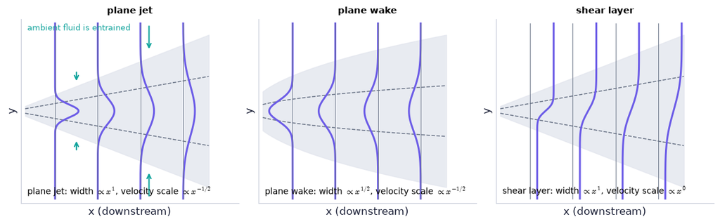

```python
ILLUS = {"C_U": 2.5, "C_Y": 4.0, "xi_half_U": 0.10, "xi_half_Y": 0.15, "dxi80_coeff": 0.1}   # LABELLED ILLUSTRATIVE constants (ours — not the tabulated, measured values)
fig, axs = plt.subplots(1, 3, figsize=(10.5, 3.2))   # a new figure and its panel(s); figsize in inches
for ax, flow in zip(axs, ("plane_jet", "plane_wake", "shear_layer")):
    free_shear_sketch(ax, flow=flow, constants=ILLUS)         # drawing: mean profiles at four stations, from ch12.free_shear_flow
    ax.set_title(flow.replace("_", " "), fontsize=10)   # label / range / scale of this axis
```

**What you see.** Three flows drawn from left to right: a jet (a bump of fast fluid that widens and weakens), a wake (a dip of slow fluid that widens and fills in), a mixing layer (a step between two streams that smears out). Each panel shows the mean profile at four stations and the growing edge of the turbulent region.

**How to read it.** In each flow the profiles at different stations are the same shape, stretched in width and scaled in height. The amplitudes here use **labelled illustrative constants** — the picture shows the growth laws, not measured numbers.

**What would change if…** …the surroundings were not still (a jet in a co-flow): the excess velocity would behave like a wake far downstream, with the wake's exponents.

#### The idea

```
conservation:   momentum flux  J_s = ρ ∫U² dy   is the same at every x        →  U_CL² · δ = const
shape-keeping:  U = U_CL(x) · F(y/δ(x))  must satisfy the equations at every x →  dδ/dx = const
together:       δ ∝ x,   U_CL ∝ x^(−1/2),   volume flux ∝ U_CL·δ ∝ x^(+1/2)  (it grows: entrainment)
```

Symbols: $x$ downstream distance from the slot [m], $y$ across the jet [m]; $U_{CL}(x)$ the centreline mean velocity [m/s]; $\delta(x)$ the width [m]; $\xi=y/\delta$ the similarity variable; $J_s$ the momentum flux per unit span [N/m = kg/s²].

> 🔁 **Tools from earlier chapters used in this block** (one line each; the full primers are in the chapters named)
- **two-length (thin-layer) scaling** — long thin flows: x in units of L, y in units of h = εL, so ∂/∂x = (1/L)∂/∂x* but ∂/∂y = (1/εL)∂/∂y*; the cross velocity scale comes from continuity (v ~ εU). *(Ch. 8, P188)*
- **chain rule with a moving similarity variable** — η = y/δ(x): ∂F/∂y = F′/δ, ∂F/∂x = −F′ηδ′/δ; a product δ(x)f(η) also needs the product rule in x — the step the book skips in every reduction (Blasius, Falkner–Skan, both jets). *(Ch. 9, P206)*
- **Leibniz rule** — ∂/∂x ∫₀^(h(x)) u dy = ∫₀^h ∂u/∂x dy + u(x, h)∂h/∂x: the extra term counts what enters because the limit moved (ch03 P109 had fixed limits); sympy demo returns 0. *(Ch. 8, P189)*
- **separation argument: a function of x equal to a function of ξ is a constant** — if a function of $x$ alone equals a function of $\xi$ alone for all $x$ and $\xi$, both must be the same constant. *(Ch. 7, P167)*
- **exponent matching** — if c₁t^aF(η) + c₂t^bG(η) = 0 for every t and η then a = b; power laws δ = Dt^m turn every bracket into a power of t, matching gives linear equations for the exponents (sympy: the spreading bead's n = m = 1/5). *(Ch. 8, P197)*
- **Gaussian profile and Gaussian integrals** — ∫_−∞^(∞)$e^{-ζ^2}$dζ = √π, √π/2 on each side; no elementary antiderivative, which is why its running integral (erf) has a name. *(Ch. 8, P194)*
- **fractions.Fraction** — exact rationals so an exponent ½ never becomes 0.49999. *(Ch. 1, P60)*

📝 **Note.** **N102 [B]** **The similarity form of the mean velocity**: an amplitude that depends on $x$ times a shape $F$ that depends only on $\xi=y/\delta(x)$; $F$ is even with $F(0)=1$.

$$ U(x,y)=U_{CL}(x)F(y/\delta(x)) \qquad \text{(12.56)} $$

📝 **Note.** **N103 [B]** **The same for the Reynolds shear stress**, with its own amplitude $\Psi(x)$ [m²/s²] and an odd shape $G$. ⚠️ These $F$, $G$ are jet profiles, not the tensor functions of $R_{ij}=F(r)r_ir_j+G(r)\delta_{ij}$ (12.40).

$$ -\overline{uv}=\Psi(x)G(y/\delta(x)) \qquad \text{(12.57)} $$

📝 **Note.** **N104 [B]** **Mean continuity in two dimensions.**

$$ \partial U/\partial x+\partial V/\partial y=0 \qquad \text{(12.58)} $$

📝 **Note.** **N105 [B]** **The mean $x$-momentum equation** (steady, constant density).

$$ U\frac{\partial U}{\partial x}+V\frac{\partial U}{\partial y}=-\frac1\rho\frac{\partial P}{\partial x}+\nu\Big(\frac{\partial^2U}{\partial x^2}+\frac{\partial^2U}{\partial y^2}\Big)-\frac{\partial\overline{u^2}}{\partial x}-\frac{\partial\overline{uv}}{\partial y} \qquad \text{(12.59)} $$

📝 **Note.** **N106 [B]** **The mean $y$-momentum equation.**

$$ U\frac{\partial V}{\partial x}+V\frac{\partial V}{\partial y}=-\frac1\rho\frac{\partial P}{\partial y}+\nu\Big(\frac{\partial^2V}{\partial x^2}+\frac{\partial^2V}{\partial y^2}\Big)-\frac{\partial\overline{uv}}{\partial x}-\frac{\partial\overline{v^2}}{\partial y} \qquad \text{(12.60)} $$

```python
JET_KW = dict(C5="from_invariant", xi_half=0.10)              # amplitude fixed by the momentum invariant; ILLUSTRATIVE half-width ξ½ = 0.10
print("−mean(uv) at (x, y) = (1, 0.1):", round(ch12.plane_jet_reynolds_stress(1.0, 0.1, 1.0, 1.0, **JET_KW), 4), "m²/s²;",   # the Reynolds shear stress at three points
      "at (4, 0.4):", round(ch12.plane_jet_reynolds_stress(4.0, 0.4, 1.0, 1.0, **JET_KW), 4), "; on the axis:", ch12.plane_jet_reynolds_stress(1.0, 0.0, 1.0, 1.0, **JET_KW))   # four times farther at the same ξ, and on the axis
print("V at (1, 0.1):", round(ch12.plane_jet_cross_velocity(1.0, 0.1, 1.0, 1.0, **JET_KW), 4), "m/s; at the edge (1, 1.0):",   # the cross-stream mean velocity inside the jet …
      round(ch12.plane_jet_cross_velocity(1.0, 1.0, 1.0, 1.0, **JET_KW), 4), "m/s = −entrainment velocity", round(ch12.plane_jet_entrainment_velocity(1.0, 1.0, 1.0, **JET_KW), 4))   # … and at its edge: inflow
terms = ch12.thin_shear_layer_terms(1.0, 0.1, 1.0, 1.0, 1.5e-5, **JET_KW)   # sizes of the terms of (12.59) at x = 1 m, y = 0.1 m (air)
print({k: float(f"{float(v):.3g}") for k, v in terms.items()})
```

```
−mean(uv) at (x, y) = (1, 0.1): -0.1345 m²/s²; at (4, 0.4): -0.0336 ; on the axis: -0.0
V at (1, 0.1): 0.0245 m/s; at the edge (1, 1.0): -0.1372 m/s = −entrainment velocity 0.1372
{'advection_x': 1.47, 'advection_y': -0.437, 'stress_gradient': 1.03, 'residual': 1.97e-08, 'viscous_y': 0.00104, 'viscous_x': -5.55e-05, 'viscous_over_stress': 0.001, 'ratio_V_over_U': 0.019}
```

**What does the code above do?**

1. Everything in this block uses $J_s/\rho=1$ m³/s² and an **illustrative** half-width $\xi_{1/2}=0.10$ (our choice, not a measured value); `C5="from_invariant"` lets the momentum invariant fix the amplitude.
2. `ch12.plane_jet_reynolds_stress` returns $-\overline{uv}$ (minus the correlation, the quantity of N103). Above the axis, where $dU/dy<0$, it is **negative** — so $\overline{uv}>0$ there: the stress has the sign of the mean shear, as an eddy viscosity would give ($-\overline{uv}=\nu_T\,dU/dy$). It is one quarter as large at four times the distance and the same $\xi$ (it decays like $x^{-1}$) and zero on the axis.
3. `ch12.plane_jet_cross_velocity`: $V$ is slightly outward inside the jet and **inward** at the edge — the surroundings flow in.
4. `ch12.thin_shear_layer_terms` compares the sizes of the terms of the $x$-momentum equation: the two advection terms balance the stress gradient exactly (`residual` 0), the viscous terms are a thousand times smaller, and $V/U\approx0.02$. These are the facts the next derivation uses.

#### 🧮 Derivation — The thin-layer jet equations and the momentum-flux invariant $J_s=\rho\int U^2dy$ `D13` ★★ (Eq. 12.62: $J_s=\rho\int_{-\infty}^{+\infty}U^2dy=\mathit{const.}$)

**What we want to show.** Simplify the mean equations for a slender jet and find the quantity that is the same at every distance from the nozzle.

**Assumptions.** Steady in the mean; constant density; high Reynolds number; slender (δ ≪ x); still surroundings with uniform pressure.

**The plan.**

1. Compare term sizes for a thin layer.
2. The y-equation gives the pressure.
3. Drop the small terms.
4. Add continuity to make a conservation form.
5. Integrate across the jet.

**Tools we use** (each explained before this point): two-length scaling (P188, ch09) · product rule (P38) · integrals over an infinite range (P144)

**We start from**

$$ \begin{array}{l}\dfrac{\partial U}{\partial x}+\dfrac{\partial V}{\partial y}=0\ \text{(12.58),} \\ U\dfrac{\partial U}{\partial x}+V\dfrac{\partial U}{\partial y}=-\dfrac1\rho\dfrac{\partial P}{\partial x}+\nu\Big(\dfrac{\partial^2U}{\partial x^2}+\dfrac{\partial^2U}{\partial y^2}\Big)-\dfrac{\partial\overline{u^2}}{\partial x}-\dfrac{\partial\overline{uv}}{\partial y} \\ \text{(12.59) and} \\ U\dfrac{\partial V}{\partial x}+V\dfrac{\partial V}{\partial y}=-\dfrac1\rho\dfrac{\partial P}{\partial y}+\nu\Big(\dfrac{\partial^2V}{\partial x^2}+\dfrac{\partial^2V}{\partial y^2}\Big)-\dfrac{\partial\overline{uv}}{\partial x}-\dfrac{\partial\overline{v^2}}{\partial y} \\ \text{(12.60).}\end{array} $$

**Step 1 of 10 — Set the scales.**

$$ U\sim U_{CL},\quad x\sim L_x,\quad y\sim\delta\ll L_x,\quad V\sim U_{CL}\,\delta/L_x $$

- *Why we can do this:* The jet is long and thin; continuity $\partial U/\partial x+\partial V/\partial y=0$ (12.58) makes $\partial V/\partial y\sim\partial U/\partial x$, which fixes the size of V (Ch. 9's boundary-layer scaling).
- *In words:* Cross-stream changes are fast, stream-wise ones slow, and V is small.

**Step 2 of 10 — Keep the largest terms of the y-equation.**

$$ 0\cong-\dfrac1\rho\dfrac{\partial}{\partial y}\big(P+\rho\overline{v^2}\big) $$

- *Why we can do this:* In the cross-stream equation of the Start the inertia terms are ~ $U_{CL}^2\delta/L_x^2$, the stress term $\partial\overline{v^2}/\partial y\sim u'^2/\delta$ is larger by $(L_x/\delta)^2(u'/U_{CL})^2$; only the pressure can balance it. This is the second of (12.61), $0\cong-\frac1\rho\frac{\partial}{\partial y}\big(P+\rho\overline{v^2}\big)$.
- *In words:* Across the jet, pressure and the normal Reynolds stress add to a constant.

**Step 3 of 10 — Integrate across the jet.**

$$ P+\rho\,\overline{v^2}=P_\infty $$

- *Why we can do this:* Integrate step 2 in y out to the still fluid, where $\overline{v^2}=0$ and the pressure is the uniform $P_\infty$.
- *In words:* Inside the jet the mean pressure is slightly below ambient.

**Step 4 of 10 — Differentiate in x.**

$$ -\dfrac1\rho\dfrac{\partial P}{\partial x}=\dfrac{\partial\overline{v^2}}{\partial x} $$

- *Why we can do this:* $P_\infty$ is constant. This term is ~ $u'^2/L_x$, as small as $\partial\overline{u^2}/\partial x$ and smaller than $\partial\overline{uv}/\partial y\sim u'^2/\delta$ by δ/L_x.
- *In words:* The stream-wise pressure gradient is negligible.

**Step 5 of 10 — Drop the small terms of the x-equation.**

$$ U\dfrac{\partial U}{\partial x}+V\dfrac{\partial U}{\partial y}\cong-\dfrac{\partial\overline{uv}}{\partial y} $$

- *Why we can do this:* Viscous terms are ~ 1/Re of the inertia terms; pressure and $\overline{u^2}$ gradients were shown small in step 4. This is the first of (12.61), $U\frac{\partial U}{\partial x}+V\frac{\partial U}{\partial y}\cong-\frac{\partial\overline{uv}}{\partial y}$.
- *In words:* Mean advection is balanced by the cross-stream gradient of the Reynolds shear stress.

**Step 6 of 10 — Add U times the continuity equation.**

$$ U\dfrac{\partial U}{\partial x}+V\dfrac{\partial U}{\partial y}+U\Big(\dfrac{\partial U}{\partial x}+\dfrac{\partial V}{\partial y}\Big)=\dfrac{\partial(U^2)}{\partial x}+\dfrac{\partial(VU)}{\partial y} $$

- *Why we can do this:* The bracket is zero by $\partial U/\partial x+\partial V/\partial y=0$ (12.58), so adding it changes nothing; the product rule then makes exact derivatives.
- *In words:* Advection as the divergence of a momentum flux.

**Step 7 of 10 — Write the conservation form.**

$$ \dfrac{\partial}{\partial x}\big(U^2\big)+\dfrac{\partial}{\partial y}\big(VU+\overline{uv}\big)\cong0 $$

- *Why we can do this:* Steps 5 and 6, everything on one side.
- *In words:* Whatever x-momentum leaves along the jet must have come in from the sides — and nothing does.

**Step 8 of 10 — Integrate across the jet.**

$$ \dfrac{d}{dx}\displaystyle\int_{-\infty}^{+\infty}U^2\,dy+\Big[VU+\overline{uv}\Big]_{y=-\infty}^{y=+\infty}\cong0 $$

- *Why we can do this:* Integrate each term over y; the x-derivative comes outside because the limits are fixed.
- *In words:* Change of momentum flux along the jet = flux through the edges.

**Step 9 of 10 — Evaluate the edge term.**

$$ \Big[VU+\overline{uv}\Big]_{-\infty}^{+\infty}=0 $$

- *Why we can do this:* Outside the jet the fluid has no stream-wise velocity (U → 0) and no turbulence ($\overline{uv}\to0$) — although V does **not** vanish there (entrainment).
- *In words:* The inflowing fluid brings volume but no x-momentum.

**Step 10 of 10 — Integrate in x and multiply by the density.**

$$ J_s\equiv\rho_s\displaystyle\int_{-\infty}^{+\infty}\big[U^2\big]_{x=0}\,dy\cong\rho\int_{-\infty}^{+\infty}U^2\,dy=\mathit{const.} $$

- *Why we can do this:* A zero derivative means a constant, fixed at the nozzle (x = 0). This is (12.62), $J_s=\rho\int_{-\infty}^{+\infty}U^2dy=\mathit{const.}$; downstream the density is the ambient ρ because the jet fluid is diluted.
- *In words:* The momentum flux per unit span is the same at every station.

**Result**

$$ \begin{array}{l}U\frac{\partial U}{\partial x}+V\frac{\partial U}{\partial y}\cong-\frac{\partial\overline{uv}}{\partial y}\ \text{,}\ 0\cong-\frac1\rho\frac{\partial}{\partial y}\big(P+\rho\overline{v^2}\big)\ \text{(12.61) and} \\ J_s=\rho\int_{-\infty}^{+\infty}U^2dy=\mathit{const.}\ \text{(12.62)}\end{array} $$

*In words:* a jet conserves its momentum flux

**What it means.** With no wall and no pressure gradient nothing can change the jet's momentum; everything else (width, speed, volume flux) must arrange itself around this invariant (D15). **Fails when:** there is a co-flow or pressure gradient, buoyancy (plumes: momentum grows), or a nearby wall (Coanda effect).

**Check it.** Units — ρU²·y: kg m⁻³ × m² s⁻² × m = N/m ✓. A top-hat slot of width d: $J_s=\rho_sU_0^2d$. Code: `jet_momentum_flux_per_span` flat to 1e-6 along the similarity solution; `thin_shear_layer_terms` prints the dropped terms, of relative order (δ/x)² — small for ξ½ = 0.1: at x = 1 m, y = 0.1 m in air the viscous term is about 0.001 of the stress gradient and V/U ≈ 0.02 (printed by the cell above the derivation).

📝 **Notes taught inside `D13`:** **N107 [B]** the thin-layer equations $U\frac{\partial U}{\partial x}+V\frac{\partial U}{\partial y}\cong-\frac{\partial\overline{uv}}{\partial y}$, $0\cong-\frac1\rho\frac{\partial}{\partial y}(P+\rho\overline{v^2})$ (12.61) (steps 2 and 5) · **N108 [B]** the conservative (flux) form of the momentum equation (steps 6–7) · **N109 [B]** the momentum-flux invariant $J_s\equiv\rho_s\int_{-\infty}^{+\infty}[U^2]_{x=0}dy\cong\rho\int_{-\infty}^{+\infty}U^2dy=\mathit{const.}$ (12.62) (steps 8–10).

> ⚠️ **slip #18 — the book prints** that the boundary terms $[VU+\overline{uv}]_{y=-\infty}^{y=+\infty}$ vanish because $U$, $V$ and $\overline{uv}$ all go to zero as $y\to\pm\infty$ **; the correct form is** that they vanish because $U\to0$ and $\overline{uv}\to0$. $V$ does **not** go to zero: by continuity $\partial U/\partial x+\partial V/\partial y=0$ (12.58) it tends to $V(\pm\infty)=\mp v_e$, the entrainment velocity with which the surroundings flow in (step 9). The product $VU$ still vanishes, so the invariant $J_s=\rho\int_{-\infty}^{+\infty}U^2dy=\mathit{const.}$ (12.62) is unchanged. The cell above the derivation shows it in numbers: far outside the jet `ch12.plane_jet_cross_velocity` returns $-0.137$ m/s, exactly minus `ch12.plane_jet_entrainment_velocity`, not 0.

> ⚠️ **Common confusion (traps in `D13`):** Concluding V → 0 at the edges; dropping $\overline{v^2}$ and then keeping ∂P/∂x; forgetting that the volume flux is *not* conserved.

#### 🧮 Derivation — The similarity equation of the plane jet `D14` ★★★ (Eq. 12.63: $\big\{\frac{\delta U'_{CL}}{U_{CL}}\big\}F^2-\big\{\frac{\delta U'_{CL}}{U_{CL}}+\delta'\big\}F'\int_0^\xi F\,d\xi=\big\{\frac\Psi{U_{CL}^2}\big\}G'$)

**What we want to show.** Put the self-preserving forms into the jet equation and see what conditions on the scales $U_{CL}(x)$, δ(x), Ψ(x) make a single profile shape possible. The book calls this "somewhat tedious" and skips it.

**Assumptions.** Self-preservation with one length δ(x); symmetric jet (V = 0 on the axis).

**The plan.**

1. Eliminate V by continuity.
2. Differentiate the similarity forms (ξ moves with x!).
3. Do the y-integral by parts.
4. Add the terms: two cancel.
5. Divide by $U_{CL}^2/\delta$.

**Tools we use** (each explained before this point): chain rule with a moving similarity variable (P206) · integration by parts (P218a) · change of variable dy = δ dξ (P106) · sympy (P40)

**We start from**

$$ \begin{array}{l}U\dfrac{\partial U}{\partial x}+V\dfrac{\partial U}{\partial y}\cong-\dfrac{\partial\overline{uv}}{\partial y}\ \text{(12.61) with}\ U=U_{CL}(x)F(\xi)\ \text{(12.56),}\ -\overline{uv}=\Psi(x)G(\xi) \\ \text{(12.57),}\ \xi=y/\delta(x)\ \text{.}\end{array} $$

**Step 1 of 14 — Solve continuity for V.**

$$ V(x,y)=-\displaystyle\int_0^y\dfrac{\partial U}{\partial x}\,dy $$

- *Why we can do this:* Integrate $\partial V/\partial y=-\partial U/\partial x$ (12.58) from the axis, where V = 0 by symmetry.
- *In words:* The cross-flow is whatever is needed to make up for the slowing stream.

**Step 2 of 14 — Eliminate V.**

$$ U\dfrac{\partial U}{\partial x}-\Big[\displaystyle\int_0^y\dfrac{\partial U}{\partial x}\,dy\Big]\dfrac{\partial U}{\partial y}\cong-\dfrac{\partial\overline{uv}}{\partial y} $$

- *Why we can do this:* Substitute step 1 in $U\,\partial U/\partial x+V\,\partial U/\partial y\cong-\partial\overline{uv}/\partial y$ (12.61); now only U and $\overline{uv}$ remain.
- *In words:* One equation for the mean velocity and the shear stress.

**Step 3 of 14 — Differentiate the similarity variable.**

$$ \dfrac{\partial\xi}{\partial x}=-\dfrac{y\,\delta'}{\delta^2}=-\dfrac{\xi\,\delta'}{\delta},\qquad\dfrac{\partial\xi}{\partial y}=\dfrac1\delta $$

- *Why we can do this:* ξ = y/δ(x): at fixed y, ξ decreases as the jet widens (P206). A prime on δ, $U_{CL}$ means d/dx.
- *In words:* A fixed point in space slides inward in the scaled coordinate as the jet grows.

**Step 4 of 14 — Differentiate U in x.**

$$ \dfrac{\partial U}{\partial x}=U_{CL}'\,F-U_{CL}\,F'\,\dfrac{\xi\,\delta'}{\delta} $$

- *Why we can do this:* Product rule on $U_{CL}(x)F(\xi)$, then the chain rule with step 3 (F′ = dF/dξ).
- *In words:* The speed at a point changes because the centreline slows and because the profile widens.

**Step 5 of 14 — Differentiate U in y.**

$$ \dfrac{\partial U}{\partial y}=\dfrac{U_{CL}}{\delta}\,F' $$

- *Why we can do this:* Chain rule with $\partial\xi/\partial y=1/\delta$. We need this derivative for the second advection term, V times the cross-stream gradient of U.
- *In words:* The cross-stream slope.

**Step 6 of 14 — Form the first term.**

$$ U\dfrac{\partial U}{\partial x}=U_{CL}U_{CL}'\,F^2-U_{CL}^2\,\dfrac{\delta'}{\delta}\,\xi FF' $$

- *Why we can do this:* Multiply step 4 by $U=U_{CL}F$. This is the first of the two advection terms of the thin-layer equation, now written with the similarity functions only.
- *In words:* Stream-wise advection in similarity form.

**Step 7 of 14 — Change the integration variable.**

$$ \displaystyle\int_0^y\dfrac{\partial U}{\partial x}\,dy=\delta\,U_{CL}'\int_0^\xi F\,d\xi-U_{CL}\,\delta'\int_0^\xi\xi F'\,d\xi $$

- *Why we can do this:* dy = δ dξ at fixed x; the factors that depend only on x come outside.
- *In words:* The integral becomes two integrals over the profile shape.

**Step 8 of 14 — Integrate the second one by parts.**

$$ \displaystyle\int_0^\xi\xi F'\,d\xi=\xi F-\int_0^\xi F\,d\xi $$

- *Why we can do this:* $\int u\,dv=uv-\int v\,du$ with u = ξ, dv = F′dξ (P218a); the boundary term at 0 vanishes.
- *In words:* Everything is now in terms of F and its running integral.

**Step 9 of 14 — Collect V.**

$$ V=-\displaystyle\int_0^y\dfrac{\partial U}{\partial x}dy=U_{CL}\,\delta'\,\xi F-\big(\delta\,U_{CL}'+U_{CL}\,\delta'\big)I,\qquad I(\xi)\equiv\int_0^\xi F\,d\xi $$

- *Why we can do this:* Steps 7 and 8 with the overall minus sign of step 1.
- *In words:* The cross-flow in similarity form: an outward part and an inward (entraining) part.

**Step 10 of 14 — Form the second term.**

$$ V\dfrac{\partial U}{\partial y}=U_{CL}^2\,\dfrac{\delta'}{\delta}\,\xi FF'-\Big(U_{CL}U_{CL}'+U_{CL}^2\dfrac{\delta'}{\delta}\Big)F'I $$

- *Why we can do this:* Multiply step 9 by step 5.
- *In words:* Cross-stream advection.

**Step 11 of 14 — Add the two advection terms.**

$$ U\dfrac{\partial U}{\partial x}+V\dfrac{\partial U}{\partial y}=U_{CL}U_{CL}'\,F^2-\Big(U_{CL}U_{CL}'+U_{CL}^2\dfrac{\delta'}{\delta}\Big)F'I $$

- *Why we can do this:* The two $\xi FF'$ terms of steps 6 and 10 are equal and opposite and cancel.
- *In words:* Only two terms survive on the left.

**Step 12 of 14 — Differentiate the stress.**

$$ -\dfrac{\partial\overline{uv}}{\partial y}=\dfrac{\partial}{\partial y}\big(\Psi\,G\big)=\dfrac{\Psi}{\delta}\,G' $$

- *Why we can do this:* $-\overline{uv}=\Psi(x)G(\xi)$ (12.57) and the chain rule of step 5.
- *In words:* The stress gradient in similarity form.

**Step 13 of 14 — Multiply both sides by $\delta/U_{CL}^2$.**

$$ \dfrac{\delta\,U_{CL}'}{U_{CL}}F^2-\Big(\dfrac{\delta\,U_{CL}'}{U_{CL}}+\delta'\Big)F'I=\dfrac{\Psi}{U_{CL}^2}G' $$

- *Why we can do this:* This makes every coefficient dimensionless and puts all the x-dependence into three groups.
- *In words:* Functions of x multiply functions of ξ.

**Step 14 of 14 — Write it in the book's form.**

$$ \Big\{\dfrac{\delta U_{CL}'}{U_{CL}}\Big\}F^2-\Big\{\dfrac{\delta U_{CL}'}{U_{CL}}+\delta'\Big\}F'\displaystyle\int_0^\xi F\,d\xi=\Big\{\dfrac{\Psi}{U_{CL}^2}\Big\}G' $$

- *Why we can do this:* Replace I by its definition. This is (12.63), $\big\{\frac{\delta U'_{CL}}{U_{CL}}\big\}F^2-\big\{\frac{\delta U'_{CL}}{U_{CL}}+\delta'\big\}F'\int_0^\xi F\,d\xi=\big\{\frac\Psi{U_{CL}^2}\big\}G'$.
- *In words:* Three brackets that depend on x only; three shape functions that depend on ξ only.

**Result**

$$ \big\{\frac{\delta U'_{CL}}{U_{CL}}\big\}F^2-\big\{\frac{\delta U'_{CL}}{U_{CL}}+\delta'\big\}F'\int_0^\xi F\,d\xi=\big\{\frac\Psi{U_{CL}^2}\big\}G'\ \text{(12.63), as in step 14} $$

*In words:* Self-preservation is possible only if the three brackets behave alike in x

**What it means.** The equation separates into x-dependent brackets and ξ-dependent shapes — the door to D15. **Fails when:** two lengths matter (near the nozzle; wall jets), so no single ξ exists.

**Check it.** Units — every bracket is dimensionless (δ × (1/x) ; Ψ/U² with Ψ in m²/s²). With δ = x, $U_{CL}\propto x^{-1/2}$: brackets −½, +½, $C_3$, and the left side is the exact derivative $-\tfrac12(FI)'$ (used in D15 step 8). Symmetry: left side even in ξ, so G′ is even and G odd ✓.

```python
import sympy as sp                                              # symbolic algebra
x, y, s, a, c4 = sp.symbols("x y s a c4", positive=True)        # s is a dummy for the y-integral
m, n = sp.Rational(1), sp.Rational(-1, 2)                       # delta ~ x^m, U_CL ~ x^n (any m, n work)
delta, UCL = x**m, c4*x**n                                      # the two scales
F = lambda xi: sp.exp(-a*xi**2)                                 # a Gaussian profile shape
U = UCL*F(y/delta)                                              # (12.56)
V = -sp.integrate(sp.diff(UCL*F(s/delta), x), (s, 0, y))        # step 1: continuity
lhs = sp.simplify(U*sp.diff(U, x) + V*sp.diff(U, y))            # left side of (12.61), computed directly
xi = sp.symbols("xi", positive=True)   # the similarity variable ξ = y/δ
I = sp.integrate(F(s), (s, 0, xi))                              # running integral of F
A1 = delta*sp.diff(UCL, x)/UCL; A2 = A1 + sp.diff(delta, x)     # the first two brackets of (12.63)
rhs = (UCL**2/delta)*(A1*F(xi)**2 - A2*sp.diff(F(xi), xi)*I)    # steps 11-13, times U_CL^2/delta
assert sp.simplify(lhs.subs(y, xi*delta) - rhs) == 0            # identical for every x and xi
assert sp.simplify(A1 - n) == 0 and sp.simplify(A2 - (m + n)) == 0   # brackets are the constants n and m + n
print("D14 check — advection computed directly minus the similarity form:", sp.simplify(lhs.subs(y, xi*delta) - rhs))   # 0 for every x and ξ
print("D14 check — the first two brackets for δ ~ x, U_CL ~ x^(−1/2):", sp.simplify(A1), sp.simplify(A2))               # −1/2 and +1/2: constants
```

```
D14 check — advection computed directly minus the similarity form: 0
D14 check — the first two brackets for δ ~ x, U_CL ~ x^(−1/2): -1/2 1/2
```

📝 **Notes taught inside `D14`:** **N110 [B]** the cross-stream velocity eliminated with continuity (steps 1–2 and 7–9) · **N111 [B]** the similarity equation, the Result of this derivation (step 14).

> ⚠️ **Common confusion (traps in `D14`):** Forgetting that ξ depends on x (dropping the $\xi\delta'/\delta$ term); sign of V; integrating $\xi F'$ wrongly; missing the cancellation of the two ξFF′ terms.

```python
sim = ch12.plane_jet_similarity_sympy()                       # sympy repeats D14 with general δ(x), U_CL(x), Ψ(x) (cached)
print("check:", sim["check"])   # True: the symbolic similarity equation equals D14's Result
print("the three brackets:", sim["coefficients"])   # the three x-dependent coefficients of the similarity equation
print("power family δ ~ x^m, U_CL ~ x^n:", sim["power_family"], "| momentum-flux exponent:", sim["momentum_flux_exponent"])   # what the brackets become for powers of x, and the exponent of the momentum flux
print("exponential family δ ~ e^(ax), U_CL ~ e^(−ax):", sim["exponential_family"])   # the same for the exponential family as printed (middle bracket 0: slip #5)
print("G(ξ = 0.1) for the Gaussian F with ξ½ = 0.10:", round(float(ch12.plane_jet_stress_profile(0.1, xi_half=0.10)), 5))   # the stress shape G at ξ = 0.1 from the once-integrated similarity equation
```

```
check: True
the three brackets: {'c1': delta(x)*Derivative(U_CL(x), x)/U_CL(x), 'c2': Derivative(delta(x), x) + delta(x)*Derivative(U_CL(x), x)/U_CL(x), 'c3': Psi(x)/U_CL(x)**2}
power family δ ~ x^m, U_CL ~ x^n: (n*x**(m - 1), x**(m - 1)*(m + n), x**(m - 1)) | momentum-flux exponent: m + 2*n
exponential family δ ~ e^(ax), U_CL ~ e^(−ax): (-a*exp(a*x), 0, exp(a*x))
G(ξ = 0.1) for the Gaussian F with ξ½ = 0.10: -0.02025
```

**What does the code above do?**

1. `ch12.plane_jet_similarity_sympy()` substitutes the similarity forms into the thin-layer equation with **general** functions $\delta(x)$, $U_{CL}(x)$, $\Psi(x)$ and returns the three brackets of D14's Result.
2. For powers $\delta\sim x^m$, $U_{CL}\sim x^n$ the brackets are $(n,\ m+n,\ 1)\,x^{m-1}$: constant only if $m=1$; and the momentum flux varies like $x^{m+2n}$: constant only if $n=-\tfrac12$.
3. `ch12.plane_jet_stress_profile(xi, xi_half)` integrates the similarity equation once for the stress shape, $C_3G=-\tfrac12F\int_0^\xi F\,d\xi$ (D15 step 8): $-0.02025$ at $\xi=0.1$.

#### 🧮 Derivation — $\delta\propto x$, $U_{CL}\propto x^{-1/2}$, the far field and $\dot V\propto x^{1/2}$ `D15` ★★ (Eq. 12.66: $U=C_5(J_s/\rho)^{1/2}x^{-1/2}F(y/x)$)

**What we want to show.** Get the growth and decay laws of the plane jet from the similarity equation and the invariant.

**Assumptions.** The simplest similarity (brackets constant); virtual origin neglected.

**The plan.**

1. Each bracket must be a constant.
2. Integrate the two resulting ODEs.
3. Use the invariant to fix the exponent.
4. Integrate the profile for the volume flux.

**Tools we use** (each explained before this point): separation argument (P167) · separable ODE · exponent matching (P197) · Gaussian integral (P194)

**We start from**

$$ \begin{array}{l}\Big\{\dfrac{\delta U_{CL}'}{U_{CL}}\Big\}F^2-\Big\{\dfrac{\delta U_{CL}'}{U_{CL}}+\delta'\Big\}F'\displaystyle\int_0^\xi F\,d\xi=\Big\{\dfrac{\Psi}{U_{CL}^2}\Big\}G'\ \text{(12.63) and} \\ J_s=\rho\displaystyle\int_{-\infty}^{+\infty}U^2dy=\mathit{const.}\ \text{(12.62).}\end{array} $$

**Step 1 of 10 — Require each bracket to be constant.**

$$ \dfrac{\delta U_{CL}'}{U_{CL}}=C_1,\qquad\dfrac{\delta U_{CL}'}{U_{CL}}+\delta'=C_2,\qquad\dfrac{\Psi}{U_{CL}^2}=C_3 $$

- *Why we can do this:* F, G depend on ξ only; if the brackets varied differently with x the equation could not hold at every x for one pair of shapes (P167). This is (12.64), $\frac{\delta U'_{CL}}{U_{CL}}=C_1,\ \frac{\delta U'_{CL}}{U_{CL}}+\delta'=C_2,\ \frac\Psi{U_{CL}^2}=C_3$.
- *In words:* Two ODEs for the scales and one algebraic relation.

**Step 2 of 10 — Subtract the first from the second.**

$$ \delta'=C_2-C_1\ \Rightarrow\ \delta(x)=(C_2-C_1)(x-x_o) $$

- *Why we can do this:* A constant derivative integrates to a straight line; $x_o$ is the integration constant ("virtual origin").
- *In words:* The jet widens linearly.

**Step 3 of 10 — Choose the convention for δ.**

$$ C_2-C_1=1,\ x_o\approx0\ \Rightarrow\ \delta=x,\quad\xi=y/x $$

- *Why we can do this:* δ is only a scale, so its constant factor can be absorbed into the shape F; $x_o$ is of the order of the slot width, negligible far downstream.
- *In words:* We measure y in units of the distance from the nozzle.

**Step 4 of 10 — Integrate the first condition.**

$$ \dfrac{x\,U_{CL}'}{U_{CL}}=C_1\ \Rightarrow\ \ln U_{CL}=C_1\ln x+\text{const}\ \Rightarrow\ U_{CL}=C_4\,x^{\gamma},\ \gamma\equiv C_1 $$

- *Why we can do this:* With δ = x the equation is separable: $dU_{CL}/U_{CL}=C_1\,dx/x$.
- *In words:* The centreline speed is a power of x — which power is not yet known.

**Step 5 of 10 — Put the similarity form in the invariant.**

$$ J_s=\rho\,U_{CL}^2\,\delta\displaystyle\int_{-\infty}^{+\infty}F^2(\xi)\,d\xi=\rho\,C_4^2\,x^{2\gamma+1}\int_{-\infty}^{+\infty}F^2(\xi)\,d\xi $$

- *Why we can do this:* $U=U_{CL}F$, dy = δ dξ, δ = x. This is (12.65), $J_s=\rho\int_{-\infty}^{+\infty}U^2dy=\rho U_{CL}^2\delta\int_{-\infty}^{+\infty}F^2(\xi)\,d\xi=\rho C_4^2x^{2\gamma+1}\int_{-\infty}^{+\infty}F^2(\xi)\,d\xi$.
- *In words:* The momentum flux as a power of x times a pure number.

**Step 6 of 10 — Demand that it does not depend on x.**

$$ 2\gamma+1=0\ \Rightarrow\ \gamma=-\tfrac12 $$

- *Why we can do this:* $J_s=\rho\int U^2dy=\mathit{const.}$ (12.62) is the same at every x, so the exponent of x must be zero (P197).
- *In words:* Conservation of momentum fixes the decay exponent.

**Step 7 of 10 — Write the far-field velocity.**

$$ U(x,y)=C_5\,(J_s/\rho)^{1/2}\,x^{-1/2}\,F(y/x),\qquad C_5=\Big(\displaystyle\int_{-\infty}^{+\infty}F^2\,d\xi\Big)^{-1/2} $$

- *Why we can do this:* From step 5 with γ = −½: $C_4=(J_s/\rho)^{1/2}(\int F^2)^{-1/2}$. This is (12.66), $U=C_5(J_s/\rho)^{1/2}x^{-1/2}F(y/x)$; $C_5=C_4(\rho/J_s)^{1/2}$ (the text's "C₄" after $-\overline{uv}=C_3C_5^2(J_s/\rho)x^{-1}G(y/x)$ (12.67) is this C₅ — slip #4).
- *In words:* The whole mean velocity field from one invariant and one shape.

**Step 8 of 10 — Integrate the similarity equation once.**

$$ -\tfrac12\big(F\,I\big)'=C_3\,G'\ \Rightarrow\ C_3\,G(\xi)=-\tfrac12F(\xi)\displaystyle\int_0^\xi F\,d\xi $$

- *Why we can do this:* With $C_1=-\tfrac12$, $C_2=+\tfrac12$ the left side of the similarity equation (D14's Result) is $-\tfrac12F^2-\tfrac12F'I=-\tfrac12(FI)'$; G(0) = 0. Then $-\overline{uv}=C_3U_{CL}^2G=C_3C_5^2(J_s/\rho)x^{-1}G(y/x)$ (12.67).
- *In words:* The shear-stress shape follows from the velocity shape; it is negative where dU/dy is negative.

**Step 9 of 10 — Integrate the velocity across the jet.**

$$ \dot V(x)=\displaystyle\int_{-\infty}^{+\infty}U\,dy=C_5\,(J_s/\rho)^{1/2}\,x^{+1/2}\int_{-\infty}^{+\infty}F(\xi)\,d\xi $$

- *Why we can do this:* dy = x dξ turns $x^{-1/2}$ into $x^{+1/2}$. This is (12.68), $\dot V\propto x^{1/2}$.
- *In words:* The volume flux grows downstream: the jet entrains.

**Step 10 of 10 — Differentiate for the entrainment velocity.**

$$ v_e\equiv-V(+\infty)=\tfrac12\dfrac{d\dot V}{dx}=\dfrac{\dot V}{4x},\qquad\dfrac{U_{CL}\,\delta}{\nu}\propto x^{1/2} $$

- *Why we can do this:* Mass balance: the extra flux enters equally through both edges (D14 step 9 at ξ → ∞ gives the same). The local Reynolds number is the product of the two scales.
- *In words:* Still fluid drifts in at a speed ∝ $x^{-1/2}$, and the jet becomes *more* turbulent downstream.

**Result**

$$ \text{δ = x,}\ U=C_5(J_s/\rho)^{1/2}x^{-1/2}F(y/x)\ \text{(12.66),}\ \dot V\propto x^{1/2}\ \text{(12.68)} $$

*In words:* Linear spreading, inverse-square-root decay, entrainment

**What it means.** No turbulence model was used — only conservation and shape-keeping; experiments supply two numbers (the spreading rate and $C_3$). **Fails when:** near the nozzle (x ≲ 20 d), or if the constants are not universal (N125's more general similarity).

**Check it.** Units — $(J_s/\rho)^{1/2}x^{-1/2}$: (m³/s²)^(1/2) m^(−1/2) = m/s ✓. Gaussian F with illustrative ξ½ = 0.10: $\int F^2$ = 0.1505, $C_5$ = 2.577; $J_s$ recovered to 1e-6 at x = 1, 2, 4; $\dot V(4)/\dot V(1)=2$. Laminar jet (Ch. 9): δ ∝ x^(2/3), U ∝ x^(−1/3) — different because there ν (a constant) replaces an eddy viscosity that grows as $U_{CL}\delta\propto x^{1/2}$.

📝 **Notes taught inside `D15`:** **N112 [B]** the three brackets must be constants, $\frac{\delta U'_{CL}}{U_{CL}}=C_1$, $\frac{\delta U'_{CL}}{U_{CL}}+\delta'=C_2$, $\frac\Psi{U_{CL}^2}=C_3$ (12.64) (step 1) · **N113 [B]** linear growth from a virtual origin, $\delta=(C_2-C_1)(x-x_o)$, with $x_o$ of the order of the slot width (steps 2–3) · **N114 [B]** the invariant fixes the decay, $J_s=\rho U_{CL}^2\delta\int_{-\infty}^{+\infty}F^2(\xi)\,d\xi=\rho C_4^2x^{2\gamma+1}\int_{-\infty}^{+\infty}F^2(\xi)\,d\xi$ (12.65) ⇒ $2\gamma+1=0$ (steps 5–6) · **N115 [B]** the stress, $-\overline{uv}=C_3U_{CL}^2G(y/x)=C_3C_5^2(J_s/\rho)x^{-1}G(y/x)$ (12.67) (step 8) · **N116 [B]** the volume flux grows, $\dot V(x)=\int_{-\infty}^{+\infty}U\,dy=C_5(J_s/\rho)^{1/2}x^{+1/2}\int_{-\infty}^{+\infty}F(\xi)\,d\xi$ (12.68) (step 9; its derivative, the entrainment velocity, in step 10).

> ⚠️ **slip #4 — the book prints**, after the stress law, that the constants are "$C_3$ and $C_4$" and that "$C_5$, $C_6$" are tabulated **; the correct form is** $C_3$ and $C_5$ (with $C_5=C_4(\rho/J_s)^{1/2}$), and the tabulated pair is the one that multiplies the nozzle forms $U=C_5U_0(\rho_s/\rho)^{1/2}(x/d)^{-1/2}F(y/x)$ (12.72) and $\bar Y=C_7Y_0(\rho_s/\rho)^{1/2}(x/d)^{-1/2}H(y/x)$ (12.73).

> ⚠️ **Common confusion (traps in `D15`):** Thinking C₁, C₂ are both free (their difference is a convention, γ = C₁ is fixed by $J_s$); the sign of G; confusing the constants' names (slip #4); assuming the volume flux is conserved.

📝 **Note.** **N122 [B]** **A Gaussian is a good fit to the measured shape.** With the half-width $\xi_{1/2}$ (where $F=\tfrac12$), $F(y/x)=\exp\{-\ln(2)(y/x)^2/(\xi_{1/2})_U^2\}$. The Gaussian integral (Ch. 8, P194) gives $\int F\,d\xi=\xi_{1/2}\sqrt{\pi/\ln2}$ and $\int F^2d\xi=\xi_{1/2}\sqrt{\pi/(2\ln2)}$; with such an $F$ the invariant fixes the amplitude, $C_5=\big(\int F^2d\xi\big)^{-1/2}$ (`ch12.gaussian_profile`, `ch12.profile_integrals`).

#### ✏️ Tiny example: a plane jet with an illustrative half-width

Take $J_s/\rho=1$ m³/s² and an **illustrative** half-width $\xi_{1/2}=0.10$ (our choice, not the book's value).

1. $\int F^2d\xi=0.10\times\sqrt{\pi/(2\ln2)}=0.1505$, so $C_5=0.1505^{-1/2}=2.577$.
2. Centreline speed at $x=1$ m: $U_{CL}=2.577$ m/s; at $x=4$ m: $2.577/\sqrt4=1.289$ m/s.
3. Half-width: 0.10 m at $x=1$ m, 0.40 m at $x=4$ m.
4. Momentum flux at both stations: $\rho U_{CL}^2x\int F^2d\xi=\rho\times1.000$ ✓ (the same).
5. Volume flux: $\int F\,d\xi=0.2129$; at $x=1$ m $\dot V=2.577\times0.2129=0.549$ m²/s; at $x=4$ m it has doubled to 1.097 m²/s — the extra fluid was entrained.
6. Entrainment velocity at $x=1$ m: $\tfrac12\,d\dot V/dx=\dot V/(4x)=0.137$ m/s on each side.

```python
y_j = np.linspace(-3.0, 3.0, 6001)                            # cross-stream grid [m], wide enough for the profile to vanish
stations = (1.0, 2.0, 4.0)                                    # three downstream stations [m]
ints = ch12.profile_integrals(0.10, 0.15)                     # ∫F dξ, ∫F² dξ and ∫HF dξ for half-widths 0.10 (velocity) and 0.15 (scalar)
print("profile integrals:", {k: round(float(v), 4) for k, v in ints.items()}, "→ C5 =", round(ints["I2"]**-0.5, 3))
for x in stations:   # one line of results per station
    U = ch12.plane_jet_mean_velocity(x, y_j, 1.0, 1.0, **JET_KW)          # Eq. (12.66): U(x, y) for J_s = 1 N/m, ρ = 1 kg/m³
    J = ch12.jet_momentum_flux_per_span(y_j, U, 1.0)                      # Eq. (12.62): ρ ∫U² dy
    Vdot = ch12.plane_jet_volume_flux(x, 1.0, 1.0, **JET_KW)              # Eq. (12.68): ∫U dy
    ve = ch12.plane_jet_entrainment_velocity(x, 1.0, 1.0, **JET_KW)       # inflow speed at each edge
    print(f"x = {x:.0f} m: U_CL = {U.max():.3f} m/s, J = {J:.4f} N/m, volume flux = {Vdot:.3f} m²/s, entrainment velocity = {ve:.3f} m/s")
```

```
profile integrals: {'I1': 0.2129, 'I2': 0.1505, 'IHF': 0.1771} → C5 = 2.577
x = 1 m: U_CL = 2.577 m/s, J = 1.0000 N/m, volume flux = 0.549 m²/s, entrainment velocity = 0.137 m/s
x = 2 m: U_CL = 1.822 m/s, J = 1.0000 N/m, volume flux = 0.776 m²/s, entrainment velocity = 0.097 m/s
x = 4 m: U_CL = 1.289 m/s, J = 1.0000 N/m, volume flux = 1.097 m²/s, entrainment velocity = 0.069 m/s
```

**What does the code above do?**

1. `ch12.plane_jet_mean_velocity(x, y, Js, rho, C5, xi_half)` is the far-field law of this block's title with a Gaussian $F$.
2. `ch12.jet_momentum_flux_per_span` integrates $\rho U^2$ across the jet: 1.000 N/m at every station — the invariant.
3. The volume flux grows like $\sqrt x$ (0.549, 0.776, 1.097 m²/s); the entrainment velocity is what feeds it.

```python
# From scratch: the two fluxes by the trapezoid rule at the three stations
J_mine, V_mine = [], []   # lists for the two fluxes at the three stations
for x in stations:   # one line of results per station
    U = 2.5774*x**-0.5*np.exp(-np.log(2)*(y_j/x)**2/0.10**2)  # U = C5 x^(−1/2) F(y/x) typed out (C5 from step 1 of the tiny example)
    J_mine.append(np.trapezoid(1.0*U**2, y_j))                # ρ ∫U² dy
    V_mine.append(np.trapezoid(U, y_j))                       # ∫U dy
assert np.allclose(J_mine, 1.0, rtol=1e-4)                    # the momentum flux is the same at every station
assert np.isclose(V_mine[2]/V_mine[0], 2.0, rtol=1e-6)        # the volume flux doubles from x = 1 m to x = 4 m
assert np.allclose(V_mine, [ch12.plane_jet_volume_flux(x, 1.0, 1.0, **JET_KW) for x in stations], rtol=1e-4)   # same as the library
print("momentum flux:", np.round(J_mine, 4), "volume flux:", np.round(V_mine, 4))
```

```
momentum flux: [1. 1. 1.] volume flux: [0.5487 0.776  1.0974]
```

**What does the code above do?**

The profile is typed out from the formula, the two integrals done with `np.trapezoid`: the momentum flux is flat, the volume flux doubles over a factor 4 in distance, and both agree with the library.

```python
y_f = np.linspace(-1.6, 1.6, 161)                            # cross-stream positions [m]
nu_lam = 0.02                                                 # a (large, illustrative) viscosity for the laminar comparison jet [m²/s]

def f4(x):                                                    # raw profiles at station x: turbulent and laminar jet of the same momentum flux
    Ut = ch12.plane_jet_mean_velocity(x, y_f, 1.0, 1.0, **JET_KW)         # turbulent: δ ∝ x, U_CL ∝ x^(−1/2)
    Ul = JET.free_jet(x, y_f, 1.0, 1.0, nu_lam)["u"]                      # laminar (Ch. 9): δ ∝ x^(2/3), U_CL ∝ x^(−1/3)
    return {"turbulent jet U(x, y)": (y_f, Ut), "laminar jet of Ch. 9 (same J_s)": (y_f, Ul),   # hand the result back to the caller
            "turbulent, rescaled to the station x = 1 m: U × √x against y/x": (y_f/x, Ut*np.sqrt(x))}

figF4 = slider_figure(f4, "x", np.round(np.linspace(0.5, 8.0, 16), 2), unit="m", xlabel="y [m]   (rescaled curve: y/x × 1 m)",
                      ylabel="U [m/s]", title="Raw profiles spread and decay; the rescaled one stays", xrange=(-1.6, 1.6), yrange=(0, 4))
figF4.show()   # display the interactive figure (the slider works on the web page too)
```

[interactive chart not shown]

**What does the code above do?**

1. `f4(x)` returns the raw turbulent profile, the laminar jet of Ch. 9 (`JET.free_jet`, Bickley's $\mathrm{sech}^2$ solution) with the same momentum flux, and the turbulent profile **rescaled**: its height multiplied by $\sqrt x$ (undoing the decay $U_{CL}\propto x^{-1/2}$) and its width divided by $x$ (undoing the spreading). Rescaled like this, the profile of any station becomes the profile at $x=1$ m.
2. The rescaled curve is the same at every slider position — and coincides with the raw profile when the slider is at 1 m: that is self-preservation.

**What you see.** Drag $x$ downstream: the purple turbulent profile widens in proportion to $x$ and its peak falls like $x^{-1/2}$; the laminar profile widens more slowly and decays more slowly; the third (rescaled) curve does not move at all.

**How to read it.** One curve $F(y/x)$ describes the jet at every station. The area under $U^2$ is the same at every $x$ (the invariant); the area under $U$ grows (entrainment).

**What would change if…** …the jet were laminar: it widens more slowly at first and its exponents are 2/3 and −1/3, because viscosity — a constant — sets the spreading, not eddies that grow with the jet.

📝 **Note.** **N117 [B]** **The scalar field carried by the jet** (the mass fraction $\bar Y$ of nozzle fluid) is self-similar too, with its own shape $H$ (wider than $F$: scalars spread a little faster than momentum).

$$ \bar Y(x,y)=Y_{CL}(x)H(y/x) \qquad \text{(12.69)} $$

📝 **Note.** **N118 [B]** **Its invariant is the flux of nozzle fluid.**

$$\dot M_s=\rho_s\int_{-\infty}^{+\infty}[U]_{x=0}dy\cong\rho\int_{-\infty}^{+\infty}\bar YU\,dy=\rho Y_{CL}C_5(J_s/\rho)^{1/2}x^{+1/2}\int_{-\infty}^{+\infty}H(\xi)F(\xi)\,d\xi\qquad\text{(12.70)}$$

> ⚠️ **slip #3 — the book prints** the source integral as $\rho_s\int_{-\infty}^{+\infty}[U]_{y=0}\,dy$ **; the correct form is** $\rho_s\int_{-\infty}^{+\infty}[U]_{x=0}\,dy$ — taken across the slot, at $x=0$, exactly as in $J_s\equiv\rho_s\int_{-\infty}^{+\infty}[U^2]_{x=0}dy$ (12.62).

📝 **Note.** **N119 [B]** **So the centreline concentration falls like $x^{-1/2}$**, the same exponent as the velocity.

$$ \bar Y=C_6\big(\dot M_s/\sqrt{\rho J_s}\big)x^{-1/2}H(y/x) \qquad \text{(12.71)} $$

📝 **Note.** **N120 [B]** **In nozzle variables** (slot width $d$, exit speed $U_0$, exit density $\rho_s$).

$$ U=C_5U_0(\rho_s/\rho)^{1/2}(x/d)^{-1/2}F(y/x) \qquad \text{(12.72)} $$

📝 **Note.** **N121 [B]** **And the scalar in nozzle variables** ($Y_0$ the exit mass fraction).

$$ \bar Y=C_7Y_0(\rho_s/\rho)^{1/2}(x/d)^{-1/2}H(y/x) \qquad \text{(12.73)} $$

```python
Y1 = ch12.plane_jet_mass_fraction(1.0, 0.0, 1.0, 1.0, 1.0, C6=1.0, xi_half_Y=0.15)   # Eq. (12.71) on the axis at x = 1 m; C6 = 1 ILLUSTRATIVE
Y4 = ch12.plane_jet_mass_fraction(4.0, 0.0, 1.0, 1.0, 1.0, C6=1.0, xi_half_Y=0.15)   # the same at x = 4 m
Yinv = ch12.plane_jet_mass_fraction(1.0, 0.0, 1.0, 1.0, 1.0, C6="from_invariant", xi_half_Y=0.15, **JET_KW)   # C6 fixed by the flux invariant (12.70)
print(f"centreline mass fraction: {Y1:.3f} at 1 m, {Y4:.3f} at 4 m (x^(−1/2));  with C6 from the invariant: {Yinv:.3f}")
for x in stations:                                            # the scalar flux at three stations
    Yp = ch12.plane_jet_mass_fraction(x, y_j, 1.0, 1.0, 1.0, C6="from_invariant", xi_half_Y=0.15, **JET_KW)   # Ȳ(x, y) for Ṁ_s = 1 kg/(m s)
    Up = ch12.plane_jet_mean_velocity(x, y_j, 1.0, 1.0, **JET_KW)
    print(f"x = {x:.0f} m: ρ∫ȲU dy = {ch12.scalar_flux_per_span(y_j, Up, Yp, 1.0):.6f} kg/(m s)")
print(f"slot of d = 1 cm, U0 = 10 m/s, air: J_s = {ch12.slot_momentum_flux(1.2, 10.0, 0.01):.2f} N/m, Ṁ_s = {ch12.slot_mass_flux(1.2, 10.0, 0.01):.2f} kg/(m s)")
cl = [ch12.free_shear_centerline("plane_jet", x, constants=ILLUS, d=0.01, U0=10.0, rho_s=1.2, rho=1.2)["U_CL"] for x in (0.4, 1.6)]   # Eq. (12.72), illustrative C_U
print(f"centreline speed at 0.4 m / at 1.6 m = {cl[0]/cl[1]:.3f} (x^(−1/2) → 2, whatever the illustrative constant)")
```

```
centreline mass fraction: 1.000 at 1 m, 0.500 at 4 m (x^(−1/2));  with C6 from the invariant: 2.190
x = 1 m: ρ∫ȲU dy = 1.000000 kg/(m s)
x = 2 m: ρ∫ȲU dy = 1.000000 kg/(m s)
x = 4 m: ρ∫ȲU dy = 1.000000 kg/(m s)
slot of d = 1 cm, U0 = 10 m/s, air: J_s = 1.20 N/m, Ṁ_s = 0.12 kg/(m s)
centreline speed at 0.4 m / at 1.6 m = 2.000 (x^(−1/2) → 2, whatever the illustrative constant)
```

**What does the code above do?**

1. `ch12.plane_jet_mass_fraction` is the scalar law: with an illustrative $C_6=1$ it gives 1.0 and 0.5 — a factor 2 over a factor 4 in distance. With `C6="from_invariant"` the constant follows from the flux invariant and our two illustrative half-widths.
2. `ch12.scalar_flux_per_span` integrates $\rho\bar YU$ across the jet: the same at every station (1 to six digits).
3. `ch12.slot_momentum_flux` and `ch12.slot_mass_flux` give the two invariants of a real slot ($\rho_sU_0^2d$ and $\rho_sU_0d$); `ch12.free_shear_centerline` evaluates the nozzle form with constants **we** supply (`ILLUS`): the ratio of two centreline speeds depends only on the exponent.

#### 🧮 Derivation — The exponents of Table 12.1 from each flow's invariant and growth law `D16` ★★

**What we want to show.** Derive, for every free shear flow of Table 12.1, how its width and velocity scale vary with distance — the book prints only the table.

**Assumptions.** Far field; high Re; self-preservation; small deficit for wakes; Boussinesq for plumes.

**The plan.**

1. One equation from what is conserved.
2. One from how fast the layer can widen.
3. Solve two linear equations — flow by flow.

**Tools we use** (each explained before this point): D13–D15 as the template · exponent matching (P197) · exact fractions (`fractions.Fraction`, P60)

**We start from**

$$ \begin{array}{l}\text{a velocity scale}\ U_s\propto x^{n}\ \text{and a width}\ \delta\propto x^{m}\ \text{(and, for scalars and buoyancy, a} \\ \text{third scale ∝}\ x^{b}\ \text{).}\end{array} $$

**Step 1 of 12 — State the growth law for flows that carry themselves.**

$$ \dfrac{d\delta}{dx}\sim\dfrac{u'}{U_{\text{adv}}}=\dfrac{u'}{U_s}=\text{const}\ \Rightarrow\ m=1 $$

- *Why we can do this:* The layer widens at the turbulent velocity u′ ∝ $U_s$ while being carried downstream at $U_s$ itself; the ratio is a pure number (the content of $\delta'=C_2-C_1$ in D15). Holds for jets, plumes, shear layers.
- *In words:* Self-propelled flows spread linearly.

**Step 2 of 12 — Recall the plane jet.**

$$ U_s^2\,\delta=\text{const}\ \Rightarrow\ 2n+m=0\ \Rightarrow\ n=-\tfrac12 $$

- *Why we can do this:* Momentum flux per span, $J_s=\rho\int U^2dy$ (12.62), with step 1. The template.
- *In words:* Plane jet: (m, n) = (1, −½).

**Step 3 of 12 — Round jet: integrate the momentum flux over a disc.**

$$ \displaystyle\int_0^\infty\rho U^2\,2\pi r\,dr\propto U_s^2\,\delta^2=\text{const}\ \Rightarrow\ 2n+2m=0\ \Rightarrow\ n=-1 $$

- *Why we can do this:* The area element is 2πr dr, so the invariant carries δ² instead of δ; m = 1 from step 1.
- *In words:* A round jet slows faster, as 1/x.

**Step 4 of 12 — Round jet: scalar and Reynolds number.**

$$ Y_s\,U_s\,\delta^2=\text{const}\ \Rightarrow\ Y_s\propto x^{-1};\qquad\dfrac{U_s\delta}{\nu}\propto x^{\,n+m}=x^{0} $$

- *Why we can do this:* The flux of nozzle fluid is conserved (the analogue of $\dot M_s\cong\rho\int\bar YU\,dy$ (12.70)); the local Reynolds number is the product of the scales.
- *In words:* A round jet keeps the Reynolds number it started with.

**Step 5 of 12 — Wakes: change the growth law.**

$$ \dfrac{d\delta}{dx}\sim\dfrac{u'}{U_\infty}\sim\dfrac{\Delta U}{U_\infty}\ \Rightarrow\ m-1=n $$

- *Why we can do this:* A wake's deficit ΔU ≪ $U_\infty$ is carried at the free-stream speed (advection linearised to $U_\infty\,\partial/\partial x$) while it spreads at u′ ∝ ΔU: the ratio is no longer constant.
- *In words:* Wakes spread ever more slowly as their deficit fades.

**Step 6 of 12 — Plane wake: conserve the momentum deficit.**

$$ \rho\,U_\infty\displaystyle\int\Delta U\,dy=\text{drag per span}\ \Rightarrow\ n+m=0\ \Rightarrow\ m=\tfrac12,\ n=-\tfrac12 $$

- *Why we can do this:* The deficit flux equals the body's drag (Ch. 4); combine with step 5: m − 1 = −m.
- *In words:* Plane wake: width ∝ √x, deficit ∝ 1/√x.

**Step 7 of 12 — Round wake.**

$$ \Delta U\,\delta^2=\text{const}\ \Rightarrow\ n+2m=0,\ m-1=n\ \Rightarrow\ m=\tfrac13,\ n=-\tfrac23 $$

- *Why we can do this:* Disc area again; then m − 1 = −2m. Local Reynolds number ∝ $x^{n+m}=x^{-1/3}$.
- *In words:* A round wake's Reynolds number falls: far enough downstream it can relaminarise.

**Step 8 of 12 — Plumes: conserve the buoyancy flux.**

$$ \text{plane plume:}\ g'\,U_s\,\delta=\text{const}\ \Rightarrow\ b+n+m=0,\qquad g'\equiv g\,\Delta\rho/\rho\propto x^{b} $$

- *Why we can do this:* A plume is fed with heat (or light fluid), not momentum: the flux of buoyancy through every cross-section equals the source's.
- *In words:* What a plume conserves is its buoyancy flux.

**Step 9 of 12 — Plumes: let buoyancy increase the momentum flux.**

$$ \dfrac{d}{dx}\big(U_s^2\,\delta\big)\sim g'\,\delta\ \Rightarrow\ 2n+m-1=b+m\ \Rightarrow\ b=2n-1 $$

- *Why we can do this:* The stream-wise (vertical) momentum equation gains the force g′ per unit mass, integrated across the plume; match powers of x.
- *In words:* The momentum flux of a plume grows with height.

**Step 10 of 12 — Plane plume: solve.**

$$ m=1,\ b=2n-1,\ b+n+1=0\ \Rightarrow\ n=0,\ b=-1 $$

- *Why we can do this:* Three linear equations (steps 1, 8, 9). The scalar (or temperature excess) scales like g′.
- *In words:* A plane plume rises at constant speed while its excess temperature falls as 1/x.

**Step 11 of 12 — Round plume: solve.**

$$ b+n+2m=0,\ b=2n-1,\ m=1\ \Rightarrow\ n=-\tfrac13,\ b=-\tfrac53 $$

- *Why we can do this:* Disc area in both the buoyancy flux (δ²) and the momentum balance ($\frac{d}{dx}(U_s^2\delta^2)\sim g'\delta^2$ gives the same b = 2n − 1).
- *In words:* A round plume: speed ∝ x^(−1/3), excess ∝ x^(−5/3).

**Step 12 of 12 — Shear layer, and collect.**

$$ \text{shear layer:}\ U_s=U_1-U_2=\text{const}\ \Rightarrow\ n=0,\ m=1 $$

- *Why we can do this:* The velocity difference is imposed by the two streams; only the width grows. All rows: `free_shear_exponents(flow)`.
- *In words:* A mixing layer simply widens linearly between two fixed speeds.

**Result**

$$ \begin{array}{l}\text{(width m, velocity n, scalar, local Reynolds number n + m) plane jet (1, −½,} \\ \text{−½, +½) · round jet (1, −1, −1, 0) · plane wake (½, −½, −½, 0) · round wake} \\ \text{(⅓, −⅔, −⅔, −⅓) · plane plume (1, 0, −1, +1) · round plume (1, −⅓, −5/3, +⅔) ·} \\ \text{shear layer (1, 0, –, +1)}\end{array} $$

*In words:* An invariant and a growth law give every row

**What it means.** The table is not seven facts to memorise but one recipe; the *constants* (spreading rates, amplitude factors) are measurements and are not reproduced here. **Fails when:** the invariant is not conserved (co-flowing jets with pressure gradients, stratified surroundings — a plume in a stable atmosphere stops rising).

**Check it.** Plane jet agrees with $U=C_5(J_s/\rho)^{1/2}x^{-1/2}F(y/x)$ (12.66) and $\bar Y\propto x^{-1/2}$ (12.71) ✓; similarity variables of the wakes: $y/\sqrt{\theta_px}$ and $r/(\theta_r^2x)^{1/3}$ ✓ (m = ½, ⅓), where $\theta_p$ = (drag per unit span)/($\rho U_\infty^2$) is a length and $\theta_r^2$ = drag/($\rho U_\infty^2$) an area — the momentum thicknesses of the two wakes. Units of each invariant: N/m (plane) or N (round). Code: `free_shear_exponents` returns these as exact `Fraction`s; `wrong_exponent_fluxes` is flat only when 2n + m = 0.

📝 **Notes taught inside `D16`:** **N124 [B]** the exponents of every free shear flow follow from one invariant and one growth law; the local Reynolds number $U_s\delta/\nu$ varies like $x^{n+m}$ (steps 1–12).

> ⚠️ **Common confusion (traps in `D16`):** Using the jet's growth law for a wake; forgetting δ² for round flows; confusing which quantity is conserved in a plume (buoyancy flux, not momentum flux).

📝 **Note.** **N123 [B]** **Our own table of exponents.** The exponents are mathematics and public; the book's amplitude constants and half-widths are measured data and are **not reproduced here** — `ch12.FREE_SHEAR_CONSTANTS` is an empty dictionary, and every constant in this notebook is passed explicitly and labelled illustrative.

```python
rows = [ch12.free_shear_exponents(f) for f in ch12.FREE_SHEAR_FLOWS]      # exact fractions for the seven flows
tab = pd.DataFrame(rows)[["flow", "width", "velocity", "scalar", "reynolds", "invariant"]]   # width m, velocity n, scalar, local Reynolds number n + m
print(tab.to_string(index=False))
assert [r["reynolds"] for r in rows] == [ch12.local_reynolds_number_exponent(f) for f in ch12.FREE_SHEAR_FLOWS]   # n + m, flow by flow
print("public table of constants adopted:", ch12.FREE_SHEAR_CONSTANTS)   # {} — none
```

```
       flow width velocity scalar reynolds                                                       invariant
  plane_jet     1     -1/2   -1/2      1/2              momentum flux per span  rho*int(U^2 dy)  [(12.62)]
  round_jet     1       -1     -1        0                           momentum flux  rho*int(U^2 2*pi*r dr)
 plane_wake   1/2     -1/2   -1/2        0 momentum deficit per span  rho*U_inf*int(dU dy) = drag per span
 round_wake   1/3     -2/3   -2/3     -1/3            momentum deficit  rho*U_inf*int(dU 2*pi*r dr) = drag
plane_plume     1        0     -1        1     buoyancy flux per span  g*int((rho - rho_local)/rho * U dy)
round_plume     1     -1/3   -5/3      2/3       buoyancy flux  g*int((rho - rho_local)/rho * U 2*pi*r dr)
shear_layer     1        0   None        1                           velocity difference U1 - U2 (imposed)
public table of constants adopted: {}
```

**What does the code above do?**

1. `ch12.free_shear_exponents(flow)` solves the two linear equations of D16 in exact fractions: width $\propto x^m$, velocity scale $\propto x^n$, scalar, and the local Reynolds number $\propto x^{n+m}$.
2. Read the last column of numbers: a plane jet's Reynolds number *grows* downstream ($+\tfrac12$), a round jet's stays constant (0), a round wake's *falls* ($-\tfrac13$) — far enough downstream a round wake stops being turbulent.

📝 **Note.** **N125 [B]** **A more general similarity.** The three brackets need not be constants; it is enough that they share one $x$-dependence:

$$\frac{\delta U'_{CL}}{U_{CL}}=C_8\Big(\frac{\delta U'_{CL}}{U_{CL}}+\delta'\Big)=C_9\frac\Psi{U_{CL}^2}\qquad\text{(12.74)}$$

for instance $\delta\sim x^m$, $U_{CL}\sim x^n$, $\Psi\sim x^{2n+m-1}$. So the constants of a self-similar flow need not be universal — they may remember the nozzle.

> ⚠️ **slip #5 — the book prints**, as a second example of this general similarity, the exponential family $\delta\sim e^{ax}$, $U_{CL}\sim e^{-ax}$, $\Psi\sim e^{-ax}$ **; the correct form is** that with these exponents the middle bracket $\delta U'_{CL}/U_{CL}+\delta'$ is identically zero, so the three brackets are *not* proportional to one another and the condition above is not met; and $U_{CL}^2\delta\sim e^{-ax}$ is not constant, which violates the jet's invariant $J_s=\rho\int_{-\infty}^{+\infty}U^2dy=\mathit{const.}$ (12.62). An exponential family that *does* satisfy both is $\delta\sim e^{ax}$, $U_{CL}\sim e^{-ax/2}$, $\Psi=$ const. (The book's next sentence itself remarks that the invariant rules out some of the possibilities.) The cell below checks all three families with sympy.

```python
pw = ch12.general_similarity_check(lambda x: 0.1*x, lambda x: 2.577*x**-0.5, lambda x: 0.3/x, 2.0)   # power family m = 1, n = −1/2 at x = 2 m
ex = ch12.general_similarity_check(lambda x: 0.1*np.exp(0.5*x), lambda x: 2.0*np.exp(-0.5*x), lambda x: 0.3*np.exp(-0.5*x), 2.0)   # exponential family, a = 0.5
for name, r_ in (("power", pw), ("exponential", ex)):   # the two trial families, one line each
    print(f"{name:12s}: c1 = {r_['c1']:+.4f}, c2 = {r_['c2']:+.4f}, c3 = {r_['c3']:+.4f}, d ln(U_CL² δ)/d ln x = {r_['momentum_flux_exponent']:+.3f}")
xs_, a_s = sp.symbols("x a", positive=True)                   # downstream distance and the growth rate of the exponential families
for label, d_s, U_s, Psi_s in (("printed: δ ~ e^(ax), U_CL ~ e^(−ax), Ψ ~ e^(−ax)", sp.exp(a_s*xs_), sp.exp(-a_s*xs_), sp.exp(-a_s*xs_)),   # the printed exponential family and one that works, treated symbolically
                               ("ours:    δ ~ e^(ax), U_CL ~ e^(−ax/2), Ψ = const", sp.exp(a_s*xs_), sp.exp(-a_s*xs_/2), sp.Integer(1))):
    c1_s = sp.simplify(d_s*sp.diff(U_s, xs_)/U_s)             # first bracket  δ U_CL'/U_CL
    c2_s = sp.simplify(c1_s + sp.diff(d_s, xs_))              # second bracket δ U_CL'/U_CL + δ'
    c3_s = sp.simplify(Psi_s/U_s**2)                          # third bracket  Ψ/U_CL²
    print(f"{label}: brackets ({c1_s}, {c2_s}, {c3_s});  U_CL² δ = {sp.simplify(U_s**2*d_s)}")
slope_vo, x0_vo = ch12.virtual_origin_fit(np.array([1.0, 2.0, 4.0]), 0.10*(np.array([1.0, 2.0, 4.0]) - 0.05))   # half-widths that start from x_o = 0.05 m
print(f"virtual-origin fit: spreading rate {slope_vo:.3f}, x_o = {x0_vo:.3f} m")
```

```
power       : c1 = -0.0500, c2 = +0.0500, c3 = +0.0452, d ln(U_CL² δ)/d ln x = +0.000
exponential : c1 = -0.1359, c2 = +0.0000, c3 = +0.2039, d ln(U_CL² δ)/d ln x = -1.000
```

```
printed: δ ~ e^(ax), U_CL ~ e^(−ax), Ψ ~ e^(−ax): brackets (-a*exp(a*x), 0, exp(a*x));  U_CL² δ = exp(-a*x)
ours:    δ ~ e^(ax), U_CL ~ e^(−ax/2), Ψ = const: brackets (-a*exp(a*x)/2, a*exp(a*x)/2, exp(a*x));  U_CL² δ = 1
virtual-origin fit: spreading rate 0.100, x_o = 0.050 m
```

**What does the code above do?**

1. `ch12.general_similarity_check(delta_fn, UCL_fn, Psi_fn, x)` evaluates the three brackets for trial functions by finite differences. Power family: $(n,\ m+n,\ 1)\times x^{m-1}\times$ amplitudes, momentum-flux exponent 0 ✓. Exponential family with the printed exponents: the middle bracket is 0 and the momentum flux falls with $x$ ✗ (slip #5).
2. The sympy lines do the same symbolically. Printed family: brackets $(-ae^{ax},\ 0,\ e^{ax})$ and $U_{CL}^2\delta=e^{-ax}$ — not allowed. Our family: $(-\tfrac a2e^{ax},\ +\tfrac a2e^{ax},\ e^{ax})$, all proportional to $e^{ax}$, and $U_{CL}^2\delta=1$ — allowed. So exponentials are not excluded as such; the printed exponents are.
3. `ch12.virtual_origin_fit` recovers the spreading rate and the virtual origin $x_o$ of **N113** from half-widths at three stations.

📝 **Note.** **N126 [B]** **How far until a fuel jet is lean enough to burn?** (our own gas, nozzle and speed). A round jet of hydrogen leaves a nozzle of diameter $d=2$ mm at about 100 m/s into air. Hydrogen burns completely when its *mass fraction* in the mixture is the stoichiometric value — the reaction $\mathrm H_2+\tfrac12\mathrm O_2\to\mathrm H_2\mathrm O$ needs half a mole of O₂ per mole of fuel, and air is 21 % O₂ by mole. (A *mole fraction* counts molecules, a *mass fraction* kilograms; they differ because the molecular masses do.) On the axis of a round jet the mass fraction falls like $1/x$ (the table above), so there is one distance where it reaches that value.

```python
st = ch12.stoichiometric_mass_fraction(2.016, 28.97, 0.5, 0.21)            # H2 (2.016 g/mol) in air (28.97 g/mol): ½ O2 per fuel, air is 21 % O2
x_st = ch12.round_jet_distance_for_mass_fraction(st["Y_fuel"], 0.002, 0.083, 1.2, 1.0, C_Y=4.0)   # d = 2 mm, ρ_s = 0.083 (H2), ρ = 1.2 kg/m³ (air); C_Y = 4 ILLUSTRATIVE (not a tabulated value)
print(f"stoichiometric: mole fraction {st['v_fuel']:.3f}, mass fraction {st['Y_fuel']:.4f};  reached {x_st*100:.1f} cm = {x_st/0.002:.0f} diameters downstream (illustrative C_Y)")
```

```
stoichiometric: mole fraction 0.296, mass fraction 0.0284;  reached 7.4 cm = 37 diameters downstream (illustrative C_Y)
```

**What does the code above do?**

`ch12.stoichiometric_mass_fraction(M_fuel, M_air, moles of O₂ per mole of fuel, O₂ mole fraction of air)`: one mole of fuel needs $0.5/0.21=2.38$ moles of air, so the fuel is $1/3.38=29.6$ % of the mixture by mole — but, hydrogen being so light, under 3 % by mass. `ch12.round_jet_distance_for_mass_fraction` solves $Y_{CL}=C_YY_0(\rho_s/\rho)^{1/2}(x/d)^{-1}$ for $x$. The amplitude constant `C_Y=4.0` is **illustrative** (not a tabulated value), so the distance the cell prints (a few tens of nozzle diameters) shows the method, not a design value.

📝 **Note.** **N127 [C]** **Turbulence quantities across the jet** (qualitative). The turbulent energy $\bar e$ is spread over the whole width with a shallow maximum off the axis; the shear stress $\overline{uv}$ is zero on the axis by symmetry and largest near the steepest mean shear, $\xi\approx\pm\xi_{1/2}$.

📝 **Note.** **N128 [B]** **The turbulent-energy budget of the jet** (the budget of C06 for a thin steady layer, written with the triple correlation $\tfrac12\overline{u_i^2u_j}$ of the exact budget):

$$0=-U\frac{\partial\bar e}{\partial x}-V\frac{\partial\bar e}{\partial y}-\overline{uv}\frac{\partial U}{\partial y}-\frac{\partial}{\partial y}\Big(\frac1{\rho_0}\overline{pv}+\frac12\overline{u_i^2v}\Big)-\bar\varepsilon\qquad\text{(12.75)}$$

advection by the mean flow, production, turbulent transport, dissipation. (⚠️ slip #10 again: the page prints the triple correlation as $\tfrac12\overline{ev}$.)

📝 **Note.** **N129 [C]** **Three balances across the jet.** On the axis there is no production (no shear): advection from upstream balances dissipation. In mid-layer production ≈ dissipation. At the edge neither is large: turbulent transport carries energy outward and advection (the entrained flow) carries it back.

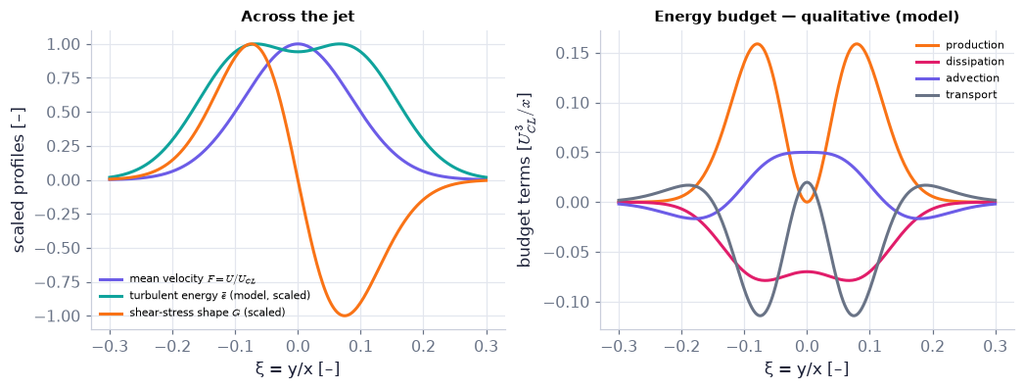

```python
xi_b = np.linspace(-0.3, 0.3, 241)                            # similarity variable ξ = y/x across the jet
bj = ch12.jet_tke_budget(np.abs(xi_b), 0.10)                  # a MODEL budget (label: qualitative), terms in units of U_CL³/x
G_prof = np.array([float(ch12.plane_jet_stress_profile(abs(s), xi_half=0.10))*np.sign(s) for s in xi_b])   # the stress shape G(ξ), odd in ξ
fig, (a1, a2) = plt.subplots(1, 2, figsize=(9.4, 3.5))   # a new figure and its panel(s); figsize in inches
a1.plot(xi_b, ch12.gaussian_profile(xi_b, 0.10), color=C_MEAN, label="mean velocity $F=U/U_{CL}$")
a1.plot(xi_b, bj["e"]/bj["e"].max(), color=C_FLUC, label="turbulent energy $\\bar e$ (model, scaled)")
a1.plot(xi_b, G_prof/np.abs(G_prof).max(), color=C_RS, label="shear-stress shape $G$ (scaled)")
a1.set(xlabel="ξ = y/x [–]", ylabel="scaled profiles [–]", title="Across the jet")   # axis labels (with units), title and fixed ranges of this panel
a1.legend(fontsize=7)   # the legend names every curve
for key, col in (("production", C_RS), ("dissipation", C_VISC), ("advection", C_MEAN), ("transport", C_REF)):   # the four terms of the model budget, each in its colour
    a2.plot(xi_b, bj[key], color=col, label=key)
a2.set(xlabel="ξ = y/x [–]", ylabel="budget terms [$U_{CL}^3/x$]", title=f"Energy budget — {bj['label']}")   # axis labels (with units), title and fixed ranges of this panel
a2.legend(fontsize=7)   # the legend names every curve
plt.show()   # display the figure
```

**What you see.** Left: the bell-shaped mean velocity, a broader turbulent-energy curve with a shallow off-axis maximum, and an S-shaped stress curve that is zero on the axis and extreme near $\xi\approx\pm0.1$. Right: four budget curves — production (two humps where the shear is), dissipation (negative everywhere), advection and transport.

**How to read it.** On the axis production is zero and advection feeds the dissipation; under the humps production ≈ dissipation; at the edges transport and advection trade places. ⚠️ Only the production curve follows from the similarity solution. The energy and dissipation shapes are **assumed** (`ch12.jet_tke_budget` is a qualitative model) and transport is the residual — read the shapes, not the numbers.

**What would change if…** …this were a wake instead of a jet: production would again vanish on the axis, but advection would be relatively larger everywhere, because a wake's turbulence decays faster than it is produced.

📝 **Note.** **N130 [B]** **The simplest closure (ours, a forward pointer to C12).** Assume a constant eddy viscosity across the jet, $\nu_T\propto U_{CL}\delta$. The similarity equation then becomes the laminar jet's with $\nu\to\nu_T$, so $F=\mathrm{sech}^2(a\xi)$ — the laminar *shape* with the turbulent *exponents*.

```python
ev = ch12.plane_jet_eddy_viscosity_profile(xi_b, 0.10)        # F = sech²(a ξ) with the same half-width, and the ν_T it implies
diff = np.abs(ev["F"] - ch12.gaussian_profile(xi_b, 0.10))    # distance from the Gaussian fit
print(f"a = {ev['a']:.2f}, ν_T/(U_CL x) = {ev['nu_hat']:.4f};  largest |sech² − Gaussian| inside the half-width: {diff[np.abs(xi_b) <= 0.10].max():.3f} of U_CL, anywhere: {diff.max():.3f}")
```

```
a = 8.81, ν_T/(U_CL x) = 0.0032;  largest |sech² − Gaussian| inside the half-width: 0.014 of U_CL, anywhere: 0.049
```

**What does the code above do?**

`ch12.plane_jet_eddy_viscosity_profile` returns the $\mathrm{sech}^2$ profile with our half-width and the eddy viscosity that goes with it, $\nu_T\approx0.003\,U_{CL}x$ — hundreds of times the molecular value for a laboratory jet. Inside the half-width it differs from the Gaussian fit by a few per cent of $U_{CL}$; its tails are fatter.

#### 🎮 Interactive: How does a jet spread without a turbulence model?

**Why interactive rather than a static figure:** toggling raw ↔ rescaled makes five profiles collapse onto one F(ξ); a wrong-exponent slider breaks either the collapse or the invariant bar; switching the flow changes the invariant and the exponents follow.

Start with the **Walkthrough**; the **Explain** tab works every number out with your settings, and the **Derivation** tab steps through the same derivation as above.

**What to try:**

- Toggle 'rescaled': five curves become one.
- Set the trial decay exponent to −0.4: the momentum bar grows as x^0.2 — not allowed.
- Switch to 'round jet': the velocity now falls as 1/x and the local Reynolds number stays constant.
- Switch to 'plane wake' and watch the width grow as √x.

```python
show_viz("ch12", "turbulent_jet_similarity")   # full-width explainer; ⤢ Full screen for more room
```

🎮 Interactive 6/10 How does a jet spread without a turbulence model? Open alone ↗

[interactive chart not shown]

**What would change if…** …there is a wall? Then a second length — a tiny viscous one — enters, the flow is never Reynolds-number independent, and the argument must be made twice (C10, C11).

## 12.9 Wall-Bounded Turbulent Shear Flows

**What is this section about?** Turbulence next to a wall: pipes, channels, the boundary layer on a wing, the wind over the ground. Two lengths matter — a viscous one of microns to millimetres at the wall and the thickness of the whole layer — and where the two descriptions overlap the mean velocity is a logarithm.

### 🧩 The law of the wall $U^+\equiv U/u_*=f(yu_*/\nu)=f(y^+)$ (12.80) with $u_*^2\equiv\tau_0/\rho$ (12.81) `C10`

*The question:* Why do profiles from different flows and Reynolds numbers fall on one curve near a wall?

#### The problem in plain words

Measure the wind 1 mm above a smooth plate in a wind tunnel, the water speed 0.1 mm from a pipe wall, the flow just above a ship's hull. Plotted in m/s against mm they have nothing in common. Divide each speed by a "friction velocity" and each distance by a "viscous length", both built from the wall stress alone, and they fall on one curve. **N131 [B]**: a wall brings two length scales, a viscous one $l_\nu$ and the layer thickness $\delta$ with $l_\nu\ll\delta$, and — unlike a jet — the flow never becomes independent of the Reynolds number on a smooth wall.

#### The idea

| Layer | What matters | Where | Velocity law |
| --- | --- | --- | --- |
| viscous sublayer | $\nu$, $\tau_0$ | $y^+<5$ | $U^+=y^+$ |
| buffer layer | viscous and Reynolds stress both | $5<y^+<30$ | neither simple law |
| logarithmic (overlap) layer | neither length | $y^+>30$ and $y/\delta<0.15$ | a logarithm (C11) |
| wake (outer) layer | $\delta$ | $y/\delta>0.15$ | defect law (C11) |

Symbols: $y$ distance from the wall [m]; $\tau_0$ wall shear stress [Pa]; $u_*=\sqrt{\tau_0/\rho}$ the friction velocity [m/s]; $l_\nu=\nu/u_*$ the viscous length [m]; a superscript $+$ means "in wall units": $y^+=y/l_\nu$, $U^+=U/u_*$.

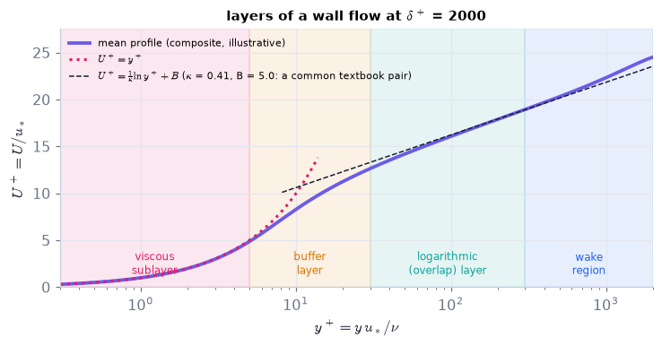

```python
fig, ax = plt.subplots(figsize=(6.6, 3.4))   # a new figure and its panel(s); figsize in inches
wall_layers_sketch(ax, Re_tau=2000.0, Pi=0.2)                 # drawing: the four layers on a semi-log profile (illustrative κ, B, Π)
plt.show()   # display the figure
```

**What you see.** A mean-velocity profile in wall units on a logarithmic distance axis, with four bands: sublayer, buffer layer, logarithmic layer, wake.

**How to read it.** The first three bands are the *inner layer*, where the wall stress and viscosity set the scales; the last two the *outer layer*, where the thickness $\delta$ does. The logarithmic band belongs to both — the overlap that C11 exploits.

**What would change if…** …the Reynolds number $\delta^+=\delta u_*/\nu$ were smaller: the logarithmic band would shrink and vanish near $\delta^+\approx200$, where the buffer layer meets the wake.

> 🔁 **Tools from earlier chapters used in this block** (one line each; the full primers are in the chapters named)
- **scaled (dimensionless) variables** — writing $y=l\,y^+$ turns $\partial/\partial y$ into $(1/l)\,\partial/\partial y^+$; each derivative brings one factor of the scale. *(Ch. 4, P133)*

📝 **Note.** **N132 [B]** **A turbulent profile is blunt.** The figure compares the mean velocity of a turbulent channel flow (a composite model profile, `WT.composite_profile`, with the illustrative pair $\kappa=0.41$, $B=5.0$ and no wake) with the laminar parabola of Ch. 8 (`LAM.channel_flow`) carrying the same flow rate. Three numbers appear in the model profiles of this block before C11 derives what they mean: $\kappa$ (the von Kármán constant, the inverse slope of the logarithmic part of the profile) and $B$ (its intercept), for which we use the labelled illustrative pair 0.41 and 5.0; and $\Pi$, the strength of the extra "wake" velocity near the outer edge (0 = none). A *composite* profile is an inner formula plus that outer correction (primer P301 in C11).

```
centreline/bulk: turbulent 1.11, laminar 1.50;  wall slope ratio turbulent/laminar ≈ 37
```

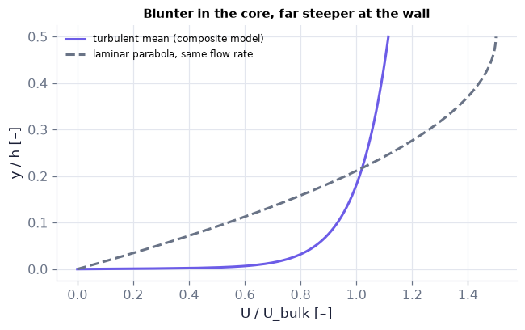

```python
h_ch, nu_w = 0.1, 1.0e-6                                      # full channel height [m] and viscosity of water [m²/s]
u_st = 0.05                                                   # friction velocity [m/s] → δ⁺ = (h/2) u*/ν = 2500
y_ch = np.linspace(0.0, h_ch/2, 400)                          # from the wall to the centreline [m]
U_turb = WT.composite_profile(y_ch, h_ch/2, u_st, nu_w, kappa=KAPPA, B=B_LOG, Pi=0.0)   # composite inner law, no wake (Π = 0, illustrative)
U_bulk = np.trapezoid(U_turb, y_ch)/(h_ch/2)                  # bulk (cross-section mean) speed [m/s]
G_lam = 12*1e-3*U_bulk/h_ch**2                                # the pressure gradient −dp/dx that gives a laminar flow the same bulk speed (μ = 1e-3 Pa s)
U_lam = LAM.channel_flow(y_ch, h_ch, U=0.0, G=G_lam, mu=1e-3) # Ch. 8's parabola between fixed plates
if isinstance(U_lam, dict): U_lam = U_lam["u"]                # (the Ch. 8 function may return a dict of fields)
fig, ax = plt.subplots(figsize=(5.8, 3.6))   # a new figure and its panel(s); figsize in inches
ax.plot(U_turb/U_bulk, y_ch/h_ch, color=C_MEAN, label="turbulent mean (composite model)")
ax.plot(np.asarray(U_lam)/U_bulk, y_ch/h_ch, "--", color=C_REF, label="laminar parabola, same flow rate")
ax.set(xlabel="U / U_bulk [–]", ylabel="y / h [–]", title="Blunter in the core, far steeper at the wall")   # axis labels (with units), title and fixed ranges of this panel
ax.legend(fontsize=8)   # the legend names every curve
print(f"centreline/bulk: turbulent {U_turb[-1]/U_bulk:.2f}, laminar {np.asarray(U_lam)[-1]/U_bulk:.2f};  wall slope ratio turbulent/laminar ≈ {(U_turb[1]/y_ch[1])/(np.asarray(U_lam)[1]/y_ch[1]):.0f}")
```

**What you see.** Two profiles over the lower half of a channel. The dashed laminar parabola peaks at 1.5 times the bulk speed; the purple turbulent profile is nearly flat across the core (about 1.1 times the bulk speed) and drops to zero in a very thin layer at the wall.

**How to read it.** Turbulent mixing evens out the momentum across the core, so the whole velocity change is squeezed against the wall: the wall shear — and the drag — is tens of times the laminar value at the same flow rate.

**What would change if…** …the Reynolds number were higher: the core gets flatter and the wall layer thinner still.

#### 🧮 Derivation — The linear total stress $\bar\tau=\tau_0(1-2y/h)$ and the pressure gradient it fixes `D17` ★★ (Eq. 12.76: $0=-\frac{\partial P}{\partial x}+\frac{\partial\bar\tau}{\partial y},\ 0=-\frac{\partial}{\partial y}\big(P+\rho\overline{v^2}\big)$)

**What we want to show.** Show that in a fully developed channel the total shear stress is a straight line across the channel, whatever the turbulence does.

**Assumptions.** Steady in the mean; statistics independent of x and z; smooth identical walls; constant density.

**The plan.**

1. Use "fully developed" to delete terms.
2. The wall-normal equation fixes how pressure varies with y.
3. a function of y equal to a function of x is a constant.
4. Integrate and use symmetry.

**Tools we use** (each explained before this point): fully developed flow (ch08) · separation argument (P167) · integration of a constant · control-volume balance (ch08 D07)

**We start from**

$$ \begin{array}{l}\text{the constant-density form of the mean momentum equation (12.30),} \\ \frac{\partial U_i}{\partial t}+U_j\frac{\partial U_i}{\partial x_j}=\frac1\rho\frac{\partial\bar\tau_{ij}}{\partial x_j}\ \text{with}\ \bar\tau_{ij}=-P\delta_{ij}+2\mu\bar S_{ij}-\rho\overline{u_iu_j}\ \text{, for flow} \\ \text{between walls at y = 0 and y = h.}\end{array} $$

**Step 1 of 9 — Apply "fully developed".**

$$ \dfrac{\partial}{\partial x}\big(\text{any mean velocity or Reynolds stress}\big)=0,\qquad V=0 $$

- *Why we can do this:* Far from the inlet the statistics no longer change downstream; then continuity gives $\partial V/\partial y=0$, and V = 0 at the wall, so V = 0 everywhere. Only P may depend on x.
- *In words:* A mean flow U(y) only.

**Step 2 of 9 — Reduce the stream-wise equation.**

$$ 0=-\dfrac{\partial P}{\partial x}+\dfrac{\partial\bar\tau}{\partial y},\qquad\bar\tau=\mu\dfrac{\partial U}{\partial y}-\rho_0\overline{uv} $$

- *Why we can do this:* The left side of the Start, $\partial U_i/\partial t+U_j\,\partial U_i/\partial x_j$, vanishes (steady, V = 0, ∂U/∂x = 0); of the stress divergence only the y-derivative of the xy-component remains. This is the first of (12.76), $0=-\frac{\partial P}{\partial x}+\frac{\partial\bar\tau}{\partial y}$; the definition of $\bar\tau$ is the unnumbered line that follows it in the book.
- *In words:* Pressure gradient balances the gradient of the total shear stress.

**Step 3 of 9 — Reduce the wall-normal equation.**

$$ 0=-\dfrac{\partial}{\partial y}\big(P+\rho\,\overline{v^2}\big) $$

- *Why we can do this:* Same reduction for the y-component: only pressure and the normal Reynolds stress survive. This is the second of (12.76), $0=-\frac{\partial}{\partial y}\big(P+\rho\overline{v^2}\big)$.
- *In words:* Across the channel, P + ρ⟨v²⟩ is uniform.

**Step 4 of 9 — Integrate from the wall.**

$$ P(x,y)-P(x,0)=-\rho\,\overline{v^2}+\rho\big[\overline{v^2}\big]_{y=0}=-\rho\,\overline{v^2} $$

- *Why we can do this:* Fundamental theorem of calculus; the fluctuation vanishes at the wall (no-slip, impermeable).
- *In words:* The pressure inside is a little lower than at the wall.

**Step 5 of 9 — Differentiate in x.**

$$ \dfrac{\partial}{\partial x}P(x,y)-\dfrac{d}{dx}P(x,0)=-\rho\dfrac{\partial}{\partial x}\overline{v^2}=0 $$

- *Why we can do this:* Step 1: no Reynolds stress depends on x. This is (12.77), $\frac{\partial}{\partial x}P(x,y)-\frac{d}{dx}P(x,0)=-\rho\frac{\partial}{\partial x}\overline{v^2}=0$.
- *In words:* The stream-wise pressure gradient is the same at every height: a function of x only.

**Step 6 of 9 — Separate.**

$$ \dfrac{d\bar\tau}{dy}(y)=\dfrac{dP}{dx}(x)=\text{constant} $$

- *Why we can do this:* In step 2 the left side depends on y only (step 1), the right on x only (step 5); they can be equal for all x and y only if both are one constant (P167).
- *In words:* The stress gradient is uniform.

**Step 7 of 9 — Integrate in y.**

$$ \bar\tau(y)=\tau_0+\dfrac{dP}{dx}\,y $$

- *Why we can do this:* A constant derivative gives a straight line; at the wall the Reynolds stress is zero and $\bar\tau(0)=\tau_0$, the wall shear stress.
- *In words:* The total stress is linear in y.

**Step 8 of 9 — Use symmetry at the other wall.**

$$ \bar\tau(h)=-\tau_0\ \Rightarrow\ \dfrac{dP}{dx}=-\dfrac{2\tau_0}{h} $$

- *Why we can do this:* The flow is symmetric about the centreline, so the stress on the upper wall is equal and opposite. This is (12.90), h = full height.
- *In words:* The pressure drop pays for the friction on both walls.

**Step 9 of 9 — Substitute back; do the pipe by a force balance.**

$$ \bar\tau(y)=\tau_0\Big(1-\dfrac{2y}{h}\Big);\qquad\dfrac{\pi d^2}{4}\,dP=-\tau_0\,\pi d\,dx\ \Rightarrow\ \dfrac{dP}{dx}=-\dfrac{4\tau_0}{d} $$

- *Why we can do this:* Steps 7 and 8; for a pipe the pressure force on a slug's ends balances friction on its side (ch08 D07). The second is (12.91), $dP/dx=-4\tau_0/d$.
- *In words:* Zero stress on the centreline, τ₀ at the wall, a straight line between.

**Result**

$$ \bar\tau(y)=\mu\,dU/dy-\rho\overline{uv}=\tau_0(1-2y/h)\ \text{;}\ dP/dx=-2\tau_0/h\ \text{(12.90); pipe}\ dP/dx=-4\tau_0/d\ \text{(12.91)} $$

*In words:* The total stress is linear; only its split between viscous and Reynolds parts depends on the turbulence

**What it means.** Very near the wall (y ≪ h) the stress is nearly the constant τ₀ — the "constant-stress layer" on which the law of the wall (D18) and the mixing-length model (D21) stand. **Fails when:** the flow is still developing, or the walls differ (the zero-stress point moves off the centreline).

**Check it.** Units — Pa/m both sides. Laminar limit: $\overline{uv}=0$, μ dU/dy linear ⇒ the parabola of Ch. 8 ✓. Number: τ₀ = 0.3 Pa, h = 0.1 m ⇒ dP/dx = −6 Pa/m. Code: `channel_momentum_residual` ≈ 0; pipe parity with `LAM.pipe_wall_stress`.

📝 **Notes taught inside `D17`:** **N133 [B]** the mean momentum balance of a fully developed channel, $0=-\frac{\partial P}{\partial x}+\frac{\partial\bar\tau}{\partial y}$, $0=-\frac{\partial}{\partial y}(P+\rho\overline{v^2})$ with the total stress $\bar\tau=\mu\frac{\partial U}{\partial y}-\rho_0\overline{uv}$ (12.76) (steps 2–3) · **N134 [B]** $P(x,y)-P(x,0)=-\rho\overline{v^2}$ (step 4) · **N135 [B]** the pressure gradient is the same at every height, $\frac{\partial}{\partial x}P(x,y)-\frac{d}{dx}P(x,0)=-\rho\frac{\partial}{\partial x}\overline{v^2}=0$ (12.77) (step 5) · **N136 [B]** the total stress is a straight line, $\bar\tau(y)=\tau_0(1-2y/h)$ with $h$ the **full** height (steps 6–8).

> ⚠️ **Common confusion (traps in `D17`):** Using the half-height in $dP/dx=-2\tau_0/h$ (12.90) (h is the full height); thinking ⟨v²⟩ changes dP/dx; citing the proof as Exercise 12.31 (slip #7: it is 12.32).

> 🔁 **Recap — Channel: pressure gradient fixed by the wall stress `R03`** (Ch. 8 §8.2). Ch. 8's force balance on a slug of fluid holds for the turbulent mean too: the pressure drop pushes on the cross-section, the two walls hold back, so $dP/dx=-2\tau_0/h$ (12.90) — the last step of D17. (⚠️ slip #7: the book cites its Exercise 12.31 for the proof; it is Exercise 12.32.)

> 🔁 **Recap — Pipe: the same balance `R04`** (Ch. 8 §8.2). For a pipe of diameter $d$: $dP/dx=-4\tau_0/d$ (12.91). This is Ch. 8's $\tau_0=\frac a2\frac{dp}{dz}$ (8.8) with radius $a=d/2$ and $z\to x$. (There $\tau_0$ carries the sign of the pressure gradient; here $\tau_0>0$ is its magnitude, hence the minus sign.)

```python
print(f"channel, τ0 = 0.3 Pa, full height 0.1 m: dP/dx = {WT.channel_pressure_gradient(0.3, 0.1):.1f} Pa/m")   # Eq. (12.90): −2 τ0/h
print(f"pipe, τ0 = 0.3 Pa, diameter 0.1 m:       dP/dx = {WT.pipe_pressure_gradient(0.3, 0.1):.1f} Pa/m")     # Eq. (12.91): −4 τ0/d
tau_back = WT.wall_stress_from_pressure_gradient(-12.0, 0.1)  # the inverse: τ0 from the pipe's pressure gradient
assert np.isclose(tau_back, abs(LAM.pipe_wall_stress(0.05, dpdz=-12.0)))   # Ch. 8's (8.8) with a = d/2 gives the same magnitude
print(f"back to the wall stress: {tau_back:.2f} Pa;  total stress a quarter of the way up the channel: {WT.channel_total_stress(0.025, 0.1, 0.3):.2f} Pa")
st_ch = WT.total_stress(ch["y_over_delta"], ch["Uplus"], -ch["minus_uv_plus"], 1.0/ch["Re_tau"], 1.0)   # model channel of C06 in outer units: μ = 1/Re_τ, ρ = 1
print("viscous + Reynolds = total:", np.allclose(st_ch["viscous"] + st_ch["reynolds"], st_ch["total"]),
      "| total stress at y/δ = 0, 0.5, 1:", np.round(np.interp([0.0, 0.5, 1.0], ch["y_over_delta"], st_ch["total"]), 3))
```

```
channel, τ0 = 0.3 Pa, full height 0.1 m: dP/dx = -6.0 Pa/m
pipe, τ0 = 0.3 Pa, diameter 0.1 m:       dP/dx = -12.0 Pa/m
back to the wall stress: 0.30 Pa;  total stress a quarter of the way up the channel: 0.15 Pa
viscous + Reynolds = total: True | total stress at y/δ = 0, 0.5, 1: [1.  0.5 0. ]
```

**What does the code above do?**

1. `WT.channel_pressure_gradient(tau0, h)` and `WT.pipe_pressure_gradient(tau0, d)` are the two recaps: −6 and −12 Pa/m.
2. `WT.wall_stress_from_pressure_gradient` inverts the pipe relation and agrees with Ch. 8's `LAM.pipe_wall_stress`.
3. `WT.channel_total_stress(y, h, tau0)` is **N136**: a quarter of the way up a channel of full height 0.1 m the total stress is half the wall stress, 0.15 Pa.
4. `WT.total_stress(y, U, uv, mu, rho)` returns a dictionary with the `viscous` part $\mu\,dU/dy$, the `reynolds` part $-\rho\overline{uv}$ and their sum `total`. On the model channel of C06 (lengths in $\delta$, velocities in $u_*$, so $\mu=1/\mathrm{Re}_\tau$) the total falls linearly from 1 at the wall to 0 on the centreline. Note the sign: we pass $\overline{uv}=-(\texttt{minus\_uv\_plus})$, which is negative.

📝 **Note.** **N137 [B]** **Who carries the stress?** The total is a straight line, but its two parts trade places within a hair of the wall. The figure uses `WT.stress_partition`, a **model** partition (Spalding's inner profile for the viscous part — approximate against DNS).

📝 **Note.** **N138 [B]** **In a boundary layer** the stress is not exactly linear, because the mean flow accelerates or decelerates: $U\frac{\partial U}{\partial x}+V\frac{\partial U}{\partial y}=-\frac1\rho\frac{\partial P}{\partial x}+\frac1\rho\frac{\partial\bar\tau}{\partial y}$ (12.78) — the turbulent form of Ch. 9's laminar boundary-layer equation $u\frac{\partial u}{\partial x}+v\frac{\partial u}{\partial y}=-\frac1\rho\frac{\partial p}{\partial x}+\nu\frac{\partial^2u}{\partial y^2}$ (9.9) (there $u$, $v$ are the full velocities). With no pressure gradient the left side vanishes at the wall, so the total stress is nearly **constant** across the inner layer. The cell below puts a number on "nearly": `WT.boundary_layer_stress_from_profile` integrates this equation from the wall for sampled model profiles of a boundary layer in air.

```python
x_bl = np.linspace(2.9, 3.1, 5)                               # five stations around x = 3 m [m] (we need ∂U/∂x)
blx = WT.zpg_boundary_layer(x_bl, 60.0, 1.5e-5, kappa=KAPPA)  # thickness and friction velocity at each station (air, U_inf = 60 m/s; fits of N150 in C11)
us_mid, d_mid = float(blx["u_star"][2]), float(blx["delta99"][2])   # friction velocity [m/s] and thickness [m] at the middle station
y_bl = np.concatenate([[0.0], np.geomspace(0.5*1.5e-5/us_mid, 1.3*d_mid, 160)])   # heights from the wall (first point at y⁺ = 0.5) to beyond the edge [m]
U_bl = np.stack([WT.composite_profile(y_bl, float(blx["delta99"][i]), float(blx["u_star"][i]), 1.5e-5, kappa=KAPPA, B=B_LOG, Pi=0.2)
                 for i in range(5)], axis=1)                  # model profile at each station as one column: U[j, i] = U(y_j, x_i); Π = 0.2 illustrative
dUdx = np.gradient(U_bl, x_bl, axis=1, edge_order=2)          # ∂U/∂x by finite differences along the stations (np.gradient, Ch. 1 P22)
V_bl = np.zeros_like(U_bl)                                    # the wall-normal mean velocity, zero at the wall
V_bl[1:] = -np.cumsum(0.5*(dUdx[1:] + dUdx[:-1])*np.diff(y_bl)[:, None], axis=0)   # continuity: V = −∫ ∂U/∂x dy (running trapezoid sum with np.cumsum)
excess = WT.boundary_layer_stress_from_profile(x_bl, y_bl, U_bl, V_bl, 0.0, 1.2)   # τ̄(x, y) − τ0(x) from Eq. (12.78) with dP/dx = 0, ρ = 1.2 kg/m³ [Pa]
ratio_bl = 1.0 + excess[:, 2]/(1.2*us_mid**2)                 # total stress / wall stress at the middle station (τ0 = ρ u*²)
yp_bl = y_bl*us_mid/1.5e-5                                    # the heights in wall units
print(f"δ+ = {d_mid*us_mid/1.5e-5:.0f};  total stress / τ0 at y+ = 5: {np.interp(5.0, yp_bl, ratio_bl):.5f}, at y+ = 30: {np.interp(30.0, yp_bl, ratio_bl):.5f}, at y/δ = 0.1: {np.interp(0.1*d_mid, y_bl, ratio_bl):.4f}")
```

```
δ+ = 4495;  total stress / τ0 at y+ = 5: 0.99999, at y+ = 30: 0.99954, at y/δ = 0.1: 0.9767
```

**What does the code above do?**

1. `WT.zpg_boundary_layer` (the fitted formulas stated in C11) gives $\delta_{99}$ and $u_*$ at five stations; `WT.composite_profile` builds a model mean profile at each (inner law plus a wake; $\kappa=0.41$, $B=5.0$ "a common textbook pair", $\Pi=0.2$ illustrative). `np.stack(..., axis=1)` puts the five profiles side by side as columns of one array.
2. `np.gradient(..., axis=1)` differentiates along the stations to get $\partial U/\partial x$; continuity then gives $V$ as a running integral in $y$ (`np.cumsum` of trapezoid pieces).
3. `WT.boundary_layer_stress_from_profile(x, y, U, V, dPdx, rho)` integrates the momentum equation from the wall and returns $\bar\tau-\tau_0$. In the inner layer the total stress stays **within 0.05 % of $\tau_0$ at $y^+=30$ and within about 2.4 % at $y/\delta=0.1$** — a *constant-stress layer*.
4. ⚠️ We print inner-layer values only: this model profile is not consistent with the outer fits it is combined with, so its stress in the outer layer and at the edge would mean nothing.

```
viscous = Reynolds at y+ ≈ 9.9;  at y+ = 30 the viscous share is 0.11
```

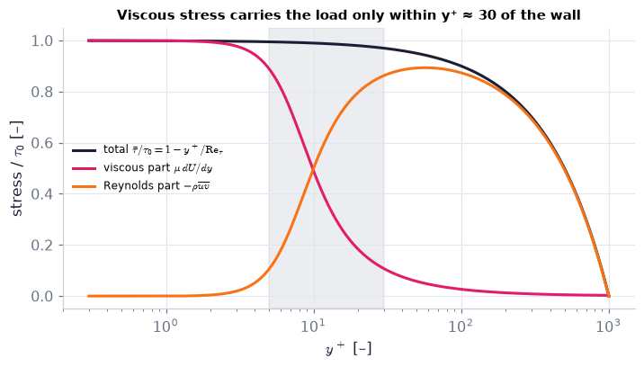

```python
yp_s = np.geomspace(0.3, 1000.0, 300)                         # y⁺ from the wall to the centreline of a channel with Re_τ = 1000
part = WT.stress_partition(yp_s, 1000.0, kappa=KAPPA, B=B_LOG)   # total, viscous and Reynolds parts in units of τ0 (a model)
fig, ax = plt.subplots(figsize=(6.4, 3.6))   # a new figure and its panel(s); figsize in inches
ax.semilogx(yp_s, part["total"], color=COLORS["ink"], label="total $\\bar\\tau/\\tau_0=1-y^+/\\mathrm{Re}_\\tau$")
ax.semilogx(yp_s, part["viscous"], color=C_VISC, label="viscous part $\\mu\\,dU/dy$")
ax.semilogx(yp_s, part["reynolds"], color=C_RS, label="Reynolds part $-\\rho\\overline{uv}$")
ax.axvspan(5, 30, color=C_REF, alpha=0.12)
ax.set(xlabel="$y^+$ [–]", ylabel="stress / $\\tau_0$ [–]", title="Viscous stress carries the load only within y⁺ ≈ 30 of the wall")   # axis labels (with units), title and fixed ranges of this panel
ax.legend(fontsize=8)   # the legend names every curve
i_eq = np.argmin(np.abs(part["viscous"] - part["reynolds"])[yp_s < 100])  # where the two parts are equal (searched inside y⁺ < 100)
print(f"viscous = Reynolds at y+ ≈ {yp_s[i_eq]:.1f};  at y+ = 30 the viscous share is {np.interp(30, yp_s, part['viscous'])/np.interp(30, yp_s, part['total']):.2f}")
```

**What you see.** A black total-stress curve that stays near 1 until $y^+\approx100$ and then falls to zero at the centreline (a straight line in $y$, bent by the logarithmic axis); a rose viscous curve that starts at 1 and dies by $y^+\approx30$; an orange Reynolds curve that takes over. The grey band is the buffer layer.

**How to read it.** At the wall the fluctuations vanish, so viscosity carries everything; by $y^+\approx10$ the two parts are equal — the place where C06 found the peak of production — and beyond $y^+\approx30$ the Reynolds stress carries almost all.

**What would change if…** …this were a zero-pressure-gradient boundary layer: the total would stay within a few per cent of $\tau_0$ across the whole inner layer (a *constant-stress layer*), which is the assumption behind the mixing-length profile of C12.

> 📎 **Primer — inner, outer and overlap: two descriptions that must agree where both hold.** `P300` · Close to the wall one set of variables works (*inner*), far away another (*outer*). If there is a region where both are valid, the two formulas must give the same answer there — *matching*. It is the separation argument of Ch. 7 (a function of one variable can equal a function of another only if both are constant) applied to two approximations.

```python
eps_ = 0.01                                       # a small ratio of the two lengths (inner length / outer length)
Y = 0.1                                           # a point in the middle: outer coordinate Y, inner coordinate y = Y/eps
exact = Y/(Y + eps_) + Y                          # a function with an inner part y/(1 + y) and an outer part Y
inner = 1.0                                       # inner description for large y:  y/(1 + y) → 1
outer = 1.0 + Y                                   # outer description for small Y: 1 + Y
print(round(exact, 3), inner, outer)              # in the overlap all three agree to within the small parameters
```

```
1.009 1.0 1.1
```

📝 **Note.** **N139 [B]** **Inner layer, outer layer, overlap.** In the *inner layer* viscosity matters and the right length is the viscous length $l_\nu$; in the *outer layer* it does not and the right length is $\delta$; where both descriptions hold is the *overlap* (`WT.layer_name(yplus, y_over_delta)` names the layer of a point with the nominal limits 5, 30 and 0.15).

📝 **Note.** **N140 [B]** **The inner list.** Near the wall the mean velocity can depend only on the density, the wall stress, the viscosity and the distance — the thickness $\delta$ and the free-stream speed are deliberately left out.

$$ U=U(\rho,\tau_0,\nu,y) \qquad \text{(12.79)} $$

#### 🧮 Derivation — The law of the wall with $u_*$, and the viscous sublayer $U^+=y^+$ `D18` ★ (Eq. 12.80: $U^+=f(y^+)$)

**What we want to show.** Find the variables in which the mean velocity near any smooth wall is one universal curve.

**Assumptions.** Smooth wall; close enough to it that δ and $U_\infty$ do not matter; constant total stress (y ≪ h, D17).

**The plan.**

1. Count dimensionless groups.
2. Build a velocity and a length from the wall quantities.
3. Very near the wall integrate the stress balance.

**Tools we use** (each explained before this point): Π theorem (ch01 C69, `DIM.pi_groups`) · integration of a constant

**We start from**

$$ U=U(\rho,\tau_0,\nu,y)\ \text{(12.79).} $$

**Step 1 of 7 — List what the near-wall flow depends on.**

$$ U=U(\rho,\ \tau_0,\ \nu,\ y) $$

- *Why we can do this:* The wall acts on the fluid only through its stress τ₀; the fluid's properties are ρ and ν; y is where we look. The outer thickness δ is deliberately left out. This is (12.79), $U=U(\rho,\tau_0,\nu,y)$.
- *In words:* Five quantities.

**Step 2 of 7 — Count the groups.**

$$ 5\ \text{quantities}-3\ \text{dimensions (kg, m, s)}=2\ \text{groups} $$

- *Why we can do this:* Buckingham's Π theorem (ch01). Five quantities (U, ρ, τ₀, ν, y) in three dimensions leave two independent dimensionless groups, so the law is one function of one variable.
- *In words:* One dimensionless velocity is a function of one dimensionless distance.

**Step 3 of 7 — Build a velocity from the wall stress.**

$$ u_*\equiv\sqrt{\tau_0/\rho} $$

- *Why we can do this:* τ₀/ρ has units (N/m²)/(kg/m³) = m²/s²; it is the only velocity that can be made from τ₀ and ρ. This is (12.81), $u_*^2\equiv\tau_0/\rho$.
- *In words:* The friction velocity: a measure of the wall stress in m/s.

**Step 4 of 7 — Build a length and form the groups.**

$$ l_\nu=\dfrac{\nu}{u_*};\qquad U^+\equiv\dfrac{U}{u_*}=f\Big(\dfrac{y\,u_*}{\nu}\Big)=f(y^+) $$

- *Why we can do this:* ν/u_* is m²s⁻¹/(m s⁻¹) = m; dividing U and y by these scales gives the two groups. This is (12.80), $U^+=f(y^+)$.
- *In words:* In wall units every smooth-wall flow has the same profile near the wall.

**Step 5 of 7 — Very near the wall keep only the viscous stress.**

$$ \mu\dfrac{dU}{dy}=\tau_0 $$

- *Why we can do this:* At the wall the fluctuations vanish, so $\overline{uv}\to0$; and the total stress is still ≈ τ₀ because y ≪ h (D17).
- *In words:* In the sublayer the stress is carried by viscosity alone.

**Step 6 of 7 — Integrate from the wall.**

$$ U=\dfrac{\tau_0\,y}{\mu} $$

- *Why we can do this:* τ₀/μ is constant; U = 0 at y = 0 (no slip).
- *In words:* A linear profile.

**Step 7 of 7 — Write it in wall units.**

$$ \dfrac{U}{u_*}=\dfrac{\rho u_*^2\,y}{\mu\,u_*}=\dfrac{y\,u_*}{\nu}\ \Rightarrow\ U^+=y^+ $$

- *Why we can do this:* τ₀ = ρu_*² and μ/ρ = ν. This is (12.82), $U^+=y^+$, good to about y⁺ ≈ 5.
- *In words:* In the viscous sublayer the function f is simply the identity.

**Result**

$$ U^+=f(y^+)\ \text{(12.80),}\ u_*^2=\tau_0/\rho\ \text{(12.81);}\ U^+=y^+\ \text{for}\ y^+\lesssim5\ \text{(12.82)} $$

*In words:* The wall stress alone sets the scales near a wall

**What it means.** Profiles from pipes, channels and boundary layers at any Reynolds number collapse near the wall when scaled this way; C11 extends f beyond the sublayer. **Fails when:** the wall is rough (elements taller than ~ 5 l_ν), or the pressure gradient is strong enough that the stress is not constant across the inner layer.

**Check it.** Units — $u_*$ m/s, $l_\nu$ m. Number: τ₀ = 0.3 Pa in air ⇒ u_* = 0.5 m/s, l_ν = 30 µm; at y = 0.09 mm, y⁺ = 3, U = 1.5 m/s. Spalding's profile differs from U⁺ = y⁺ by 0.02 % at y⁺ = 1 and 2.7 % at y⁺ = 5.

📝 **Notes taught inside `D18`:** **N141 [B]** the friction velocity $u_*^2\equiv\tau_0/\rho$ (12.81), the viscous length $l_\nu=\nu/u_*$ and the friction Reynolds number $\delta^+=\delta u_*/\nu$ (steps 3–4) · **N142 [B]** the viscous sublayer: $\mu(dU/dy)=\tau_0\Rightarrow U=\tau_0y/\mu$, or $U^+=y^+$ (12.82) (steps 5–7).

> ⚠️ **Common confusion (traps in `D18`):** Including δ in the inner list; reading U⁺ = y⁺ on a semi-log plot as "curved, so not linear"; confusing u_* with a velocity that exists somewhere in the flow.

#### ✏️ Tiny example: wall units for air over a plate

$\tau_0=0.3$ Pa, $\rho=1.2$ kg/m³, $\nu=1.5\times10^{-5}$ m²/s.

1. $u_*=\sqrt{0.3/1.2}=0.5$ m/s.
2. $l_\nu=\nu/u_*=3\times10^{-5}$ m = 30 µm.
3. The sublayer ($y^+<5$) is 0.15 mm thick.
4. At $y=0.09$ mm: $y^+=3$, $U^+=3$, so $U=1.5$ m/s.
5. A 3 cm boundary layer has $\delta^+=0.03/(3\times10^{-5})=1000$.

```python
yp1, Up1, u_star, l_nu = WT.wall_units(9.0e-5, 1.5, 0.3, 1.2, 1.5e-5)   # y = 0.09 mm, U = 1.5 m/s, τ0 = 0.3 Pa in air
print(f"u* = {u_star:.2f} m/s, l_ν = {l_nu:.1e} m, y+ = {yp1:.1f}, U+ = {Up1:.1f};  sublayer law U+(3) = {WT.viscous_sublayer(3.0):.1f}")   # friction velocity, viscous length and the point in wall units; the sublayer law at y⁺ = 3
print(f"δ+ of a 3 cm layer: {WT.friction_reynolds_number(0.5, 0.03, 1.5e-5):.0f};  back to SI: {WT.from_wall_units(3.0, 3.0, 0.5, 1.5e-5)}")   # the friction Reynolds number δ⁺ = δ u*/ν, and the conversion back to metres and m/s
print("dimensionless groups of U = U(ρ, τ0, ν, y):", WT.law_of_the_wall_groups())   # exponents of each variable in the two groups
print([WT.layer_name(yp_, yd_) for yp_, yd_ in ((3.0, 0.003), (15.0, 0.015), (100.0, 0.1), (600.0, 0.6))])   # the layer each of four points lies in
```

```
u* = 0.50 m/s, l_ν = 3.0e-05 m, y+ = 3.0, U+ = 3.0;  sublayer law U+(3) = 3.0
δ+ of a 3 cm layer: 1000;  back to SI: (9e-05, 1.5)
dimensionless groups of U = U(ρ, τ0, ν, y): [{'U': Fraction(1, 1), 'rho': Fraction(1, 2), 'tau0': Fraction(-1, 2), 'nu': Fraction(0, 1)}, {'y': Fraction(1, 1), 'rho': Fraction(-1, 2), 'tau0': Fraction(1, 2), 'nu': Fraction(-1, 1)}]
['viscous sublayer', 'buffer layer', 'logarithmic layer', 'wake region']
```

**What does the code above do?**

1. `WT.wall_units(y, U, tau0, rho, nu)` returns $(y^+, U^+, u_*, l_\nu)$ — the numbers of the tiny example; `WT.from_wall_units` goes back to metres and m/s.
2. `WT.law_of_the_wall_groups()` runs Ch. 1's Π theorem on the inner list: two groups, $U\rho^{1/2}\tau_0^{-1/2}=U/u_*$ and $y\rho^{-1/2}\tau_0^{1/2}\nu^{-1}=yu_*/\nu$ — exactly $U^+$ and $y^+$.
3. `WT.layer_name` names the four layers for four points of a $\delta^+=1000$ layer.

```python
# From scratch: the four wall-unit numbers by hand
u_star_mine = np.sqrt(0.3/1.2)                    # Eq. (12.81): friction velocity [m/s]
l_nu_mine = 1.5e-5/u_star_mine                    # viscous length ν/u* [m]
yp_mine, Up_mine = 9.0e-5/l_nu_mine, 1.5/u_star_mine   # Eq. (12.80): y⁺ = y/l_ν and U⁺ = U/u*
assert np.allclose([yp_mine, Up_mine, u_star_mine, l_nu_mine], WT.wall_units(9.0e-5, 1.5, 0.3, 1.2, 1.5e-5))   # same numbers as the library
print(u_star_mine, l_nu_mine, yp_mine, Up_mine)
```

```
0.5 3e-05 3.0 3.0
```

**What does the code above do?**

Four one-line formulas reproduce `WT.wall_units`: wall units are nothing more than dividing by $u_*$ and $l_\nu$.

> 📎 **Primer — semi-log axes: a logarithm is a straight line.** `P299` · On `ax.semilogx` (logarithmic horizontal axis, linear vertical axis) the law $U^+=\frac1\kappa\ln y^++B$ is a straight line; it rises by $\ln(10)/\kappa=2.303/\kappa$ per decade (5.6 for $\kappa=0.41$). The linear law $U^+=y^+$ looks *curved* there.

```python
vals = np.log(np.array([10.0, 100.0, 1000.0]))/0.41 + 5.0   # U⁺ at y⁺ = 10, 100, 1000 for κ = 0.41, B = 5.0 (illustrative pair)
print(np.round(vals, 2), np.round(np.diff(vals), 2))        # each decade adds 2.303/0.41 = 5.62
```

```
[10.62 16.23 21.85] [5.62 5.62]
```

```
sublayer law at y+ = 5 is 2.7 % above the curve; at y+ = 7: 7.3 %
```

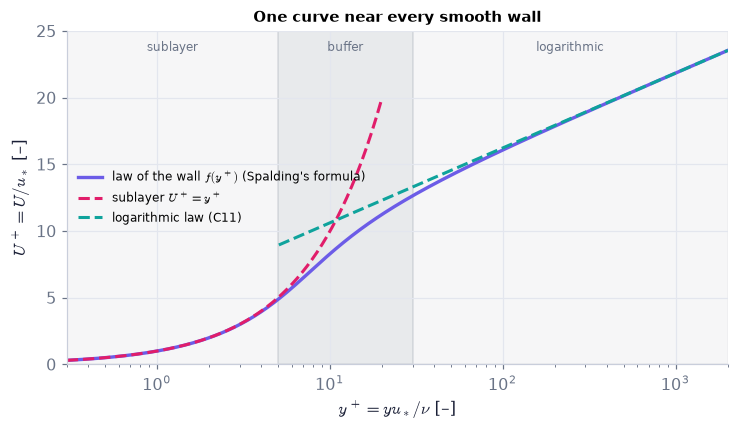

```python
yp_w = np.geomspace(0.3, 2000.0, 400)                         # y⁺ over almost four decades
U_sp = WT.spalding_uplus(yp_w, kappa=KAPPA, B=B_LOG)          # Spalding's single formula for the whole inner layer (a model; κ, B illustrative)
fig, ax = plt.subplots(figsize=(6.6, 3.8))   # a new figure and its panel(s); figsize in inches
ax.semilogx(yp_w, U_sp, color=C_MEAN, lw=2.2, label="law of the wall $f(y^+)$ (Spalding's formula)")   # the whole inner profile U⁺ = f(y⁺)
ax.semilogx(yp_w[yp_w < 20], WT.viscous_sublayer(yp_w[yp_w < 20]), "--", color=C_VISC, label="sublayer $U^+=y^+$")   # Eq. (12.82): U⁺ = y⁺, drawn up to y⁺ = 20
ax.semilogx(yp_w[yp_w > 5], WT.log_law(yp_w[yp_w > 5], kappa=KAPPA, B=B_LOG), "--", color=C_FLUC, label="logarithmic law (C11)")   # Eq. (12.88): the logarithmic law, drawn from y⁺ = 5
for lo, hi, name in ((0.3, 5, "sublayer"), (5, 30, "buffer"), (30, 2000, "logarithmic")):   # shade and name the three layers of the inner region
    ax.axvspan(lo, hi, color=C_REF, alpha=0.06 if name != "buffer" else 0.15)   # a light band for this layer (darker for the buffer layer)
    ax.text(np.sqrt(lo*hi), 23.5, name, ha="center", fontsize=8, color=C_REF)   # its name, centred on the logarithmic axis
ax.set(xlabel="$y^+=yu_*/\\nu$ [–]", ylabel="$U^+=U/u_*$ [–]", xlim=(0.3, 2000), ylim=(0, 25), title="One curve near every smooth wall")   # axis labels (with units), title and fixed ranges of this panel
ax.legend(fontsize=8, loc="center left")   # the legend names every curve
err5 = abs(WT.spalding_uplus(5.0, kappa=KAPPA, B=B_LOG) - 5.0)/5.0   # how far the sublayer line is from the curve at y⁺ = 5
print(f"sublayer law at y+ = 5 is {100*err5:.1f} % above the curve; at y+ = 7: {100*abs(WT.spalding_uplus(7.0, kappa=KAPPA, B=B_LOG) - 7)/7:.1f} %")   # how far U⁺ = y⁺ is from the curve at y⁺ = 5 and 7 [%]
```

**What you see.** A bold purple curve that follows the rose dashed line $U^+=y^+$ (curved on these axes) up to $y^+\approx5$, bends through the buffer band, and joins the teal dashed straight line beyond $y^+\approx30$.

**How to read it.** The sublayer line is accurate to a few per cent up to $y^+\approx5$ (7 % off by $y^+=7$); the straight line takes over after the buffer layer. In between neither simple law holds. (Spalding's formula is a smooth interpolation — a model that is within about half a unit of $U^+$ of channel DNS.)

**What would change if…** …the wall were rough: the roughness elements poke through the sublayer, which disappears, and viscosity with it (C11's rough-wall law).

**What would change if…** …we go far from the wall, where viscosity cannot matter? A second law holds there, and making the two agree gives the logarithm (C11).

### 🧩 The logarithmic law $U^+=\frac1\kappa\ln(y^+)+B$ (12.88); rough wall $U^+=\frac1\kappa\ln(y/y_0)$ (12.93) `C11`

*The question:* Where does the logarithm come from?

#### The problem in plain words

A wind profile over open country, plotted against the logarithm of height, is a straight line — the fact behind every wind-turbine siting study, every "wind at 10 m" in a weather report and every bulk formula for surface drag in a climate model. No turbulence model is needed to get it: only the statement that two descriptions of the same flow must agree.

#### The idea

Near the wall the velocity depends on $y$ and the viscous length, not on $\delta$. Far away it depends on $y$ and $\delta$, not on viscosity. In between, the *gradient* can depend on neither length. The only thing left with the right units is $dU/dy=u_*/(\kappa y)$ — and the integral of $1/y$ is a logarithm. ⚠️ $\kappa$ here is the **von Kármán constant** (a pure number near 0.4), not the thermal diffusivity of the mean heat equation in C04 (our $\kappa_{th}$).

> 🔁 **Tools from earlier chapters used in this block** (one line each; the full primers are in the chapters named)
- **chain rule** — $\frac{d}{dy}f(g(y))=f'(g)\,g'(y)$ — each change of variable brings the derivative of the inner function as a factor. *(Ch. 1, P49)*
- **scipy.optimize.brentq** — root of f(x) = 0 inside a bracket [a, b] where f changes sign; guaranteed and fast; pick the bracket from the physics and exclude trivial roots (x = 0 in 1 + 2x = eˣ). *(Ch. 3, P108)*

#### 🧮 Derivation — The defect law, overlap matching and the logarithmic law; friction law $U_\infty^+=\tfrac1\kappa\ln\delta^++A+B$ `D19` ★★ (Eq. 12.88: $U^+=\frac1\kappa\ln(y^+)+B$)

**What we want to show.** Find the velocity profile in the region where both the near-wall and the outer descriptions hold.

**Assumptions.** An overlap region exists: $y^+\gg1$ and $y/\delta\ll1$ at once, i.e. $\delta^+\gg1$.

**The plan.**

1. Build the outer law by dimensional analysis.
2. Differentiate both laws.
3. Equate the gradients where both hold.
4. Separate variables.
5. Integrate.

**Tools we use** (each explained before this point): Π theorem (ch01) · chain rule (P49) · matching in the overlap (P300, primer in C10) · separation argument (P167) · $\int dy/y=\ln y$

**We start from**

$$ \text{the law of the wall}\ U/u_*=f(y^+)\ \text{(12.80) and the outer list}\ U=U(\rho,\tau_0,\delta,y)\ \text{(12.83).} $$

**Step 1 of 12 — List what the outer flow depends on.**

$$ U=U(\rho,\ \tau_0,\ \delta,\ y) $$

- *Why we can do this:* Far from the wall the Reynolds stress carries the momentum and viscosity does not matter; the wall is still felt through τ₀, and the layer's size δ enters. This is (12.83), $U=U(\rho,\tau_0,\delta,y)$.
- *In words:* Outer flow: no ν, but δ.

**Step 2 of 12 — Form the outer law for the velocity defect.**

$$ \dfrac{U_\infty-U}{u_*}=F_d\Big(\dfrac{y}{\delta}\Big)=F_d(\xi) $$

- *Why we can do this:* Π theorem: one group y/δ. The *defect* is used because without ν the outer flow knows U only up to an additive constant (it cannot see the no-slip wall). This is (12.84), $\frac{U_\infty-U}{u_*}=F(y/\delta)=F(\xi)$ (the book's F).
- *In words:* How far the velocity falls short of the edge value, in units of u_*.

**Step 3 of 12 — Differentiate the inner law.**

$$ \dfrac{dU}{dy}=u_*\dfrac{df}{dy^+}\dfrac{dy^+}{dy}=\dfrac{u_*^2}{\nu}\dfrac{df}{dy^+} $$

- *Why we can do this:* Chain rule with $y^+=yu_*/\nu$. This is (12.85), $\frac{dU}{dy}=\frac{u_*^2}\nu\frac{df}{dy^+}$.
- *In words:* The mean shear from the inner description.

**Step 4 of 12 — Differentiate the outer law.**

$$ -\dfrac{dU}{dy}=\dfrac{u_*}{\delta}\dfrac{dF_d}{d\xi} $$

- *Why we can do this:* Chain rule with ξ = y/δ; $U_\infty$ is constant. This is (12.86), $-\frac{dU}{dy}=\frac{u_*}\delta\frac{dF}{d\xi}$.
- *In words:* The same shear from the outer description.

**Step 5 of 12 — Equate them in the overlap.**

$$ \dfrac{u_*^2}{\nu}\dfrac{df}{dy^+}=-\dfrac{u_*}{\delta}\dfrac{dF_d}{d\xi} $$

- *Why we can do this:* Where both laws are valid they describe the same flow, so the shear must agree (matching, P300). Gradients are matched, not velocities, because the two laws differ by a constant.
- *In words:* Two formulas for one slope.

**Step 6 of 12 — Multiply by $y/u_*$.**

$$ y^+\dfrac{df}{dy^+}=-\xi\dfrac{dF_d}{d\xi} $$

- *Why we can do this:* $y\,u_*/\nu=y^+$ on the left and $y/\delta=\xi$ on the right: each side now contains only its own variable. This is (12.87), $-\xi\frac{dF}{d\xi}=y^+\frac{df}{dy^+}$.
- *In words:* A function of y⁺ alone equals a function of ξ alone.

**Step 7 of 12 — Conclude that both sides are constant.**

$$ y^+\dfrac{df}{dy^+}=-\xi\dfrac{dF_d}{d\xi}=\dfrac1\kappa $$

- *Why we can do this:* y⁺ and ξ can be varied independently (change δ at fixed y⁺), so neither side can depend on its variable (P167). κ is the von Kármán constant (≈ 0.4; not the thermal diffusivity).
- *In words:* In the overlap, y dU/dy = u_*/κ — a number, the same at every height.

**Step 8 of 12 — Write the inner equation as an ODE.**

$$ \dfrac{df}{dy^+}=\dfrac{1}{\kappa\,y^+} $$

- *Why we can do this:* Divide step 7 by y⁺. Dividing by a positive number keeps the equation true and isolates the slope, ready to be integrated.
- *In words:* The slope falls off as 1/y.

**Step 9 of 12 — Integrate it.**

$$ U^+=f(y^+)=\dfrac1\kappa\ln(y^+)+B $$

- *Why we can do this:* $\int dy^+/y^+=\ln y^+$; B is the integration constant, fixed by experiment (it remembers the sublayer and buffer layer). This is (12.88), $U^+=\frac1\kappa\ln(y^+)+B$.
- *In words:* The logarithmic law.

**Step 10 of 12 — Integrate the outer equation the same way.**

$$ F_d(\xi)=-\dfrac1\kappa\ln(\xi)+A $$

- *Why we can do this:* $dF_d/d\xi=-1/(\kappa\xi)$. This is (12.89), $F(\xi)=-\frac1\kappa\ln(\xi)+A$; A remembers the outer flow (the wake).
- *In words:* The same logarithm, seen from outside.

**Step 11 of 12 — Add the two forms at one height.**

$$ \dfrac{U_\infty}{u_*}=\dfrac1\kappa\ln y^+-\dfrac1\kappa\ln\xi+A+B=\dfrac1\kappa\ln\delta^++A+B $$

- *Why we can do this:* $U/u_*+(U_\infty-U)/u_*=U_\infty/u_*$ and $\ln y^+-\ln(y/\delta)=\ln(\delta u_*/\nu)$: y drops out. (Ours.)
- *In words:* A friction law: the edge velocity in wall units grows as the logarithm of the Reynolds number.

**Step 12 of 12 — Turn it into a skin-friction coefficient.**

$$ C_f\equiv\dfrac{\tau_0}{\tfrac12\rho U_\infty^2}=\dfrac{2}{(U_\infty^+)^2}=\dfrac{2}{\big[\tfrac1\kappa\ln\delta^++A+B\big]^2} $$

- *Why we can do this:* τ₀ = ρu_*². This is the definition of the friction velocity, so the ratio of wall stress to dynamic pressure becomes a ratio of velocities squared.
- *In words:* Turbulent skin friction falls only logarithmically with Reynolds number.

**Result**

$$ U^+=\tfrac1\kappa\ln y^++B\ \text{(12.88);}\ F_d(\xi)=-\tfrac1\kappa\ln\xi+A\ \text{(12.89);}\ U_\infty^+=\tfrac1\kappa\ln\delta^++A+B $$

*In words:* The logarithm is what remains when the shear may depend on neither length

**What it means.** Wall functions in CFD, the roughness-length wind profile and bulk drag laws are all this logarithm. **Fails when:** δ⁺ ≲ 200 (no overlap), near separation (u_* → 0), or with strong pressure gradients.

**Check it.** Units — all dimensionless. Illustrative κ = 0.41, B = 5.0: U⁺(100) = 16.23, U⁺(1000) = 21.85 (+5.62 per decade). With A = 1.0, δ⁺ = 1000: U_∞⁺ = 22.85, C_f = 3.8 × 10⁻³. `overlap_matching_sympy()` reproduces steps 3–10. The same argument in dimensional form: dU/dy can depend only on u_* and y ⇒ dU/dy = u_*/(κy).

📝 **Notes taught inside `D19`:** **N143 [B]** the outer list $U=U(\rho,\tau_0,\delta,y)$ (12.83) (step 1) · **N144 [B]** the velocity-defect law $\frac{U_\infty-U}{u_*}=F(y/\delta)=F(\xi)$ (12.84) (step 2) · **N145 [B]** the inner gradient $\frac{dU}{dy}=\frac{u_*^2}\nu\frac{df}{dy^+}$ (12.85) (step 3) · **N146 [B]** the outer gradient $-\frac{dU}{dy}=\frac{u_*}\delta\frac{dF}{d\xi}$ (12.86) (step 4) · **N147 [B]** the matching condition $-\xi\frac{dF}{d\xi}=y^+\frac{df}{dy^+}$ (12.87) (steps 5–6) · **N148 [B]** the outer logarithm $F(\xi)=-\frac1\kappa\ln(\xi)+A$ (12.89) (step 10).

> ⚠️ **Common confusion (traps in `D19`):** Matching velocities instead of gradients; the sign in the defect law; ln vs log₁₀ (slope per decade is 2.303/κ); treating κ and B as exact universal numbers (they vary a little with flow type — required keywords in code).

#### ✏️ Tiny example: reading a log law

Illustrative pair $\kappa=0.41$, $B=5.0$.

1. At $y^+=100$: $U^+=\ln(100)/0.41+5.0=11.23+5.0=16.23$.
2. At $y^+=1000$: 21.85 — one decade adds $2.303/0.41=5.62$.
3. Where do $U^+=y^+$ and the log law cross? Solve $y^+=\ln(y^+)/0.41+5.0$: $y^+\approx10.8$ — the middle of the buffer layer.
4. With $u_*=0.5$ m/s, $l_\nu=30$ µm: at $y=3$ mm ($y^+=100$) the mean speed is $16.23\times0.5=8.1$ m/s.

```python
print(f"U+(100) = {WT.log_law(100.0, kappa=KAPPA, B=B_LOG):.3f};  sublayer and log law cross at y+ = {WT.log_law_crossing(kappa=KAPPA, B=B_LOG):.2f}")   # Eq. (12.88) at y⁺ = 100, and where it crosses U⁺ = y⁺
print(f"friction law: U_inf+ at δ+ = 1000 with A = 1.0 (illustrative): {WT.friction_law_from_overlap(1000, kappa=KAPPA, A=1.0, B=B_LOG):.2f}")   # D19 step 11: the free-stream speed in wall units at δ⁺ = 1000
print("outer groups of U = U(ρ, τ0, δ, y):", WT.defect_law_groups())   # Π theorem on the outer list: U/u* and y/δ
xi_d, defect = WT.velocity_defect(np.array([0.01, 0.05]), np.array([8.0, 9.0]), 10.0, 0.5, 0.1)   # two points of a 10 cm layer: U = 8, 9 m/s; U_inf = 10; u* = 0.5
print(f"defect variables: ξ = {xi_d}, (U_inf − U)/u* = {defect};  outer log law F(0.1) = {WT.log_law_defect(0.1, kappa=KAPPA, A=1.0):.3f}")   # a profile in outer variables, and the outer logarithm (12.89) at ξ = 0.1
om = ch12.overlap_matching_sympy()                            # sympy repeats the matching of D19 (cached)
print("inner solution f =", om["f"], "| outer solution F =", om["F_outer"], "| checks:", om["checks"])   # what sympy finds for the two overlap laws, and its checks
```

```
U+(100) = 16.232;  sublayer and log law cross at y+ = 10.80
friction law: U_inf+ at δ+ = 1000 with A = 1.0 (illustrative): 22.85
outer groups of U = U(ρ, τ0, δ, y): [{'U': Fraction(1, 1), 'rho': Fraction(1, 2), 'tau0': Fraction(-1, 2), 'delta': Fraction(0, 1)}, {'y': Fraction(1, 1), 'rho': Fraction(0, 1), 'tau0': Fraction(0, 1), 'delta': Fraction(-1, 1)}]
defect variables: ξ = [0.1 0.5], (U_inf − U)/u* = [4. 2.];  outer log law F(0.1) = 6.616
inner solution f = B + log(y_plus)/kappa | outer solution F = A - log(xi)/kappa | checks: {'gradients_match': True, 'f_satisfies': True, 'F_satisfies': True, 'friction_law': True}
```

**What does the code above do?**

1. `WT.log_law(yplus, kappa=, B=)` — both constants are **required keywords** everywhere in the module (no silent defaults); `WT.log_law_crossing` solves step 3 of the tiny example: 10.80.
2. `WT.friction_law_from_overlap` adds the inner and outer logarithms (D19 step 11): $U_\infty^+=\frac1\kappa\ln\delta^++A+B=22.85$; the outer constant $A=1.0$ is illustrative.
3. `WT.defect_law_groups()` is the Π theorem for the outer list: $U/u_*$ and $y/\delta$. `WT.velocity_defect` converts a profile to those variables; `WT.log_law_defect` is the outer logarithm $F(\xi)=-\frac1\kappa\ln(\xi)+A$ (12.89): 6.616 at $\xi=0.1$.
4. `ch12.overlap_matching_sympy()` solves the matching condition symbolically and confirms both logarithms and the friction law.

> 📎 **Primer — composite profile: inner law + outer correction.** `P301` · Add to an inner formula a correction that vanishes near the wall and grows to its full size at the outer edge: the sum is usable across the whole layer. `WT.coles_wake(xi)` is such a correction shape: 0 at the wall, 1 at the edge.

```python
print(WT.coles_wake(np.array([0.0, 0.5, 1.0])))   # the cubic wake shape W = 3ξ² − 2ξ³ at the wall, mid-layer and edge: 0, 0.5, 1
```

```
[0.  0.5 1. ]
```

📝 **Note.** **N153 [B]** **One formula for the whole inner layer** (Spalding 1961): it gives $y^+$ as a function of $U^+$, $y^+=U^++e^{-\kappa B}\big[e^{\kappa U^+}-1-\kappa U^+-\tfrac12(\kappa U^+)^2-\tfrac16(\kappa U^+)^3\big]$, and tends to $U^+=y^+$ at the wall and to the log law far from it. `WT.spalding_uplus` inverts it with `brentq` (Ch. 3, P108). It is a **model** (approximate against DNS, within about 0.7 in $U^+$).

📝 **Note.** **N154 [B]** **The outer profile** adds a *wake* to the logarithm (Coles 1956): $U^+=\frac1\kappa\ln(y^+)+B+\frac{2\Pi}\kappa W(y/\delta)$ with $W=3\xi^2-2\xi^3$ or $\sin^2(\pi\xi/2)$. The wake strength $\Pi$ depends on the flow (it is larger in a boundary layer than in a pipe); `WT.composite_profile` takes it as a required keyword, and our examples pass labelled illustrative values.

📝 **Note.** **N155 [C]** **Open questions.** Whether the overlap is exactly logarithmic or a weak power law, and how layers with strong stress gradients behave, are still debated. The sublayer is universal; the wake is not — hence slightly different constants are reported for pipes, channels and boundary layers.

📝 **Note.** **N156 [B]** **Which constants?** We print only cited public values (`WT.LOG_LAW_CONSTANTS`, each entry with its citation) and pass $\kappa$ and $B$ explicitly everywhere.

📝 **Note.** **N157 [B]** **An empirical link between the two constants** across flows and pressure gradients (Nagib & Chauhan 2008):

$$ \kappa B=1.6[\exp(0.1663B)-1] \qquad \text{(12.92)} $$

```python
print("Spalding U+ at y+ = 1, 5, 12, 30, 100:", np.round(WT.spalding_uplus(np.array([1.0, 5.0, 12.0, 30.0, 100.0]), kappa=KAPPA, B=B_LOG), 3))   # the single-formula inner profile at five heights
print(f"its inverse y+(U+ = 10) = {WT.spalding_yplus(10.0, kappa=KAPPA, B=B_LOG):.2f};  slope dU+/dy+ at U+ = 10: {WT.spalding_slope(10.0, kappa=KAPPA, B=B_LOG):.3f}")   # Spalding's formula gives y⁺ directly from U⁺; its slope there
for name, entry in WT.LOG_LAW_CONSTANTS.items():              # the cited public values (never unpacked with **: each entry also holds its citation)
    B_txt = entry['B'] if entry['B'] is not None else "not quoted by the source (we fit it below)"   # the DNS entry gives κ only
    print(f"{name}: kappa = {entry['kappa']}, B = {B_txt}  — {entry['citation'][:70]}…")   # one cited pair per line, with the start of its citation
# PUBLIC-REPO RULE: keep κ = 0.40 here — at κ = 0.384 the printed pair coincides with a row of the book's table (tools/check_public.py fails).
B_nc = WT.nagib_chauhan_B(0.40)                               # Eq. (12.92) solved for B at an illustrative κ = 0.40
print(f"Eq. (12.92): κ = 0.400 → B = {B_nc:.2f} → back to κ = {WT.nagib_chauhan_kappa(B_nc):.3f}")   # the round trip κ → B → κ through the Nagib–Chauhan relation
```

```
Spalding U+ at y+ = 1, 5, 12, 30, 100: [ 1.     4.866  9.157 12.634 16.077]
its inverse y+(U+ = 10) = 14.55;  slope dU+/dy+ at U+ = 10: 0.288
classical: kappa = 0.41, B = 5.0  — common textbook smooth-wall pair (kappa ~ 0.41, C+ ~ 5.0), e.g. https:…
channel_dns_lee_moser_2015: kappa = 0.384, B = not quoted by the source (we fit it below)  — Lee & Moser, J. Fluid Mech. 774, 395 (2015), arXiv:1410.7809, abstract…
Eq. (12.92): κ = 0.400 → B = 4.61 → back to κ = 0.400
```

**What does the code above do?**

1. Spalding's curve at five heights: 1.000 (sublayer), 4.87, 9.16 (buffer), 12.63, 16.08 (already close to the log law's 16.23).
2. `WT.LOG_LAW_CONSTANTS` holds the pairs we may show: a common textbook pair, and $\kappa=0.384$ from channel DNS; each entry carries a `citation` string, which is why we read the keys one by one.
3. `WT.nagib_chauhan_B` and `WT.nagib_chauhan_kappa` are the two directions of $\kappa B=1.6[\exp(0.1663B)-1]$ (12.92): a round trip returns the $\kappa$ we started from. The printed $B$ is **our evaluation** of that formula at an illustrative $\kappa=0.40$ (our choice, between the textbook 0.41 and the DNS 0.384), not a number taken from a table.

📝 **Note.** **N149 [B]** **The profile at many Reynolds numbers.** In wall units the inner part never moves; a higher $\delta^+$ only lengthens the logarithmic stretch before the wake peels off. The slider figure shows a composite model profile; the dots are public channel DNS (Lee & Moser 2015, *J. Fluid Mech.* 774, 395; file `reference/ch12/lee_moser_2015_channel_mean.csv`).

```python
dns = pd.read_csv(REF / "lee_moser_2015_channel_mean.csv", comment="#")   # public DNS mean profiles (case, Re_tau, y/δ, y⁺, U⁺, dU⁺/dy⁺)
dns_pts = {c: dns[dns["case"] == c].iloc[::8] for c in (180, 1000, 5200)}   # three cases, every 8th point

def f5(logRe):                                                # curves for one friction Reynolds number δ⁺ = 10^logRe
    Re_tau = 10.0**logRe   # the friction Reynolds number δ⁺ of this slider position
    yp_ = np.geomspace(0.5, Re_tau, 120)                     # from inside the sublayer to the edge of the layer
    out = {"composite model profile (κ = 0.41, B = 5.0, Π = 0.1; illustrative)": (yp_, WT.composite_profile_plus(yp_, Re_tau, kappa=KAPPA, B=B_LOG, Pi=0.1)),
           "log law": (yp_[yp_ > 8], WT.log_law(yp_[yp_ > 8], kappa=KAPPA, B=B_LOG)),
           "wake begins: y+ = 0.15 δ+": ([0.15*Re_tau]*2, [0.0, 32.0])}
    for c, d_ in dns_pts.items():                             # the DNS dots are the same at every slider position
        out[f"channel DNS, Re_τ ≈ {c} (Lee & Moser 2015)"] = (d_["yplus"].values[1:], d_["Uplus"].values[1:])
    return out   # hand the result back to the caller

figF5 = slider_figure(f5, "log10 δ+", np.round(np.linspace(np.log10(180), 5.0, 10 if FAST else 14), 3), xlabel="y+ [–]", ylabel="U+ [–]",
                      title="The inner curve never moves; the logarithm lengthens",
                      modes={f"channel DNS, Re_τ ≈ {c} (Lee & Moser 2015)": "markers" for c in (180, 1000, 5200)})
figF5.update_xaxes(type="log", range=[np.log10(0.5), 5.0])    # logarithmic y⁺ axis
figF5.update_yaxes(range=[0, 32])                             # fixed U⁺ range
figF5.show()   # display the interactive figure (the slider works on the web page too)
for c in (1000, 5200):                                        # how far are the DNS dots from the model line at the SAME Reynolds number?
    d_ = dns[dns["case"] == c]   # the rows of this DNS case
    Re_c = float(d_["Re_tau"].iloc[0])                        # the exact Re_τ of this DNS case
    at = np.array([30.0, 100.0, 300.0, 1000.0, 3000.0]); at = at[at < 0.6*Re_c]   # heights inside the layer
    gap = np.interp(at, d_["yplus"], d_["Uplus"]) - WT.composite_profile_plus(at, Re_c, kappa=KAPPA, B=B_LOG, Pi=0.1)   # DNS minus model
    print(f"Re_τ ≈ {c}: DNS − model at y+ = {at.astype(int).tolist()}: {np.round(gap, 2).tolist()}")
```

[interactive chart not shown]

```
Re_τ ≈ 1000: DNS − model at y+ = [30, 100, 300]: [0.79, 0.36, 0.33]
Re_τ ≈ 5200: DNS − model at y+ = [30, 100, 300, 1000, 3000]: [0.75, 0.34, 0.26, 0.38, 0.54]
```

**What does the code above do?**

1. `pd.read_csv(..., comment="#")` reads the public DNS table (lines starting with `#` hold the citation).
2. `f5(logRe)` returns the composite profile (`WT.composite_profile_plus`: Spalding's inner law plus a small illustrative wake), the log law, a vertical marker where the wake begins, and the DNS dots.
3. `modes=` draws the DNS as markers instead of lines.
4. The printed lines compare DNS and model at the same Reynolds number: the DNS is **above** the model by a few tenths of a wall unit everywhere in the log region.

**What you see.** Drag $\delta^+$ from 180 to 10⁵: the left part of the curve stays exactly where it is; its right end travels along the straight log line, and the vertical marker ($y^+=0.15\,\delta^+$) travels with it. The three sets of DNS dots lie along the same inner curve and leave it one after the other.

**How to read it.** This is the law of the wall as data: three simulations at very different Reynolds numbers share one inner curve. The DNS dots sit slightly *above* the model line through the log region (by 0.3 to 0.8 in $U^+$, the numbers the cell prints). The gap is largest at $y^+=30$, where Spalding's curve is still low, smallest near $y^+\approx300$, and grows again further out: the DNS line is **steeper** — a smaller $\kappa$, about 0.384 rather than the textbook 0.41 — and the illustrative pair 0.41, 5.0 was not fitted to this simulation (next cell).

**What would change if…** …we plotted in outer variables ($(U_\infty-U)/u_*$ against $y/\delta$): the wakes would collapse and the wall region would fan out — the opposite collapse, which the explainer below lets you switch on.

```python
# From scratch: κ and B from a straight-line fit of U⁺ against ln y⁺ — on public DNS, and on the model profile
d52 = dns[dns["case"] == 5200]                                # channel DNS at Re_τ ≈ 5200 (Lee & Moser 2015, J. Fluid Mech. 774, 395)
yp_d, Up_d, Re_d = d52["yplus"].values, d52["Uplus"].values, float(d52["Re_tau"].iloc[0])   # y⁺, U⁺ and the exact Re_τ of the case
fit = WT.fit_log_law(yp_d, Up_d, window=(350.0, 0.15), Re_tau=Re_d)       # the library: window 350 < y⁺ < 0.15 δ⁺
win = (yp_d >= 350.0) & (yp_d <= 0.15*Re_d)                               # the same window by hand
slope, intercept = np.polyfit(np.log(yp_d[win]), Up_d[win], 1)            # straight line U⁺ = slope · ln y⁺ + intercept (P13)
assert np.allclose((1/slope, intercept), (fit["kappa"], fit["B"]), rtol=1e-8)   # κ = 1/slope, B = intercept: same as the library
print(f"DNS Re_τ ≈ {Re_d:.0f}, window 350 < y+ < 0.15 δ+: κ = {fit['kappa']:.4f}, B = {fit['B']:.2f} ({fit['n_points']} points)")
assert abs(fit["kappa"] - 0.384) < 0.004                                  # the published value for this simulation
yp_m = np.geomspace(1.0, 5000.0, 600)                                     # a composite MODEL profile at δ⁺ = 5000, built with κ = 0.41, B = 5.0
Up_m = WT.composite_profile_plus(yp_m, 5000.0, kappa=KAPPA, B=B_LOG, Pi=0.0)   # the model profile (no wake) in wall units
rows = [("DNS Re_τ ≈ 5200", 350.0, fit), ("DNS Re_τ ≈ 5200", 30.0, WT.fit_log_law(yp_d, Up_d, window=(30.0, 0.15), Re_tau=Re_d)),
        ("model built with 0.41, 5.0", 30.0, WT.fit_log_law(yp_m, Up_m, window=(30.0, 0.15), Re_tau=5000.0)),
        ("model built with 0.41, 5.0", 300.0, WT.fit_log_law(yp_m, Up_m, window=(300.0, 0.15), Re_tau=5000.0))]
print(pd.DataFrame([{"profile": n, "window starts at y+": lo, "fitted κ": round(f_["kappa"], 3), "fitted B": round(f_["B"], 2)} for n, lo, f_ in rows]).to_string(index=False))
```

```
DNS Re_τ ≈ 5186, window 350 < y+ < 0.15 δ+: κ = 0.3837, B = 4.28 (35 points)
```

```
                   profile  window starts at y+  fitted κ  fitted B
           DNS Re_τ ≈ 5200                350.0     0.384      4.28
           DNS Re_τ ≈ 5200                 30.0     0.400      4.92
model built with 0.41, 5.0                 30.0     0.383      3.99
model built with 0.41, 5.0                300.0     0.405      4.80
```

**What does the code above do, and what does it show?**

1. `np.polyfit` of $U^+$ against $\ln y^+$ inside the window gives slope $=1/\kappa$ and intercept $=B$; `WT.fit_log_law` does the same and the `assert` shows the two agree.
2. On the public DNS at $\mathrm{Re}_\tau\approx5200$, in the window $350<y^+<0.15\,\delta^+$, the fit returns $\kappa\approx0.384$ — the value its authors report.
3. **The constants you fit depend on where the window starts** (the table). Start the DNS window at $y^+=30$ and $\kappa$ rises to about 0.40. Fit a model profile that was *built* with 0.41 and 5.0 from $y^+=30$ and you get back a smaller pair, because at $y^+=30$ the buffer layer has not quite joined the logarithm; start at 300 and the built-in pair nearly returns. This is one reason published values differ from one experiment to the next (N155, N156).

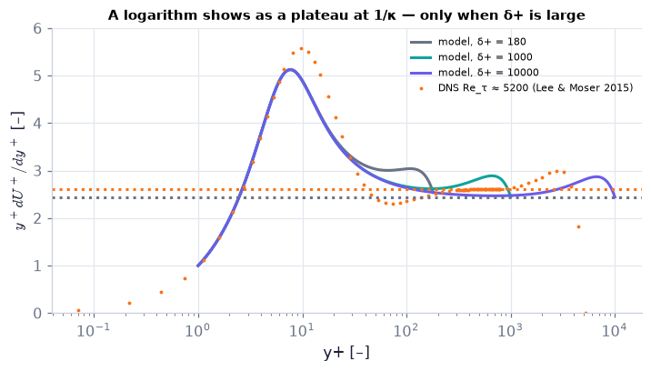

```python
fig, ax = plt.subplots(figsize=(6.4, 3.6))   # a new figure and its panel(s); figsize in inches
for Re_tau, col in ((180.0, C_REF), (1000.0, C_FLUC), (10000.0, C_MEAN)):   # three friction Reynolds numbers, one colour each
    yp_ = np.geomspace(1.0, Re_tau, 300)   # y⁺ from the sublayer to the edge of this layer
    ind = WT.log_law_indicator(yp_, WT.composite_profile_plus(yp_, Re_tau, kappa=KAPPA, B=B_LOG, Pi=0.1))   # y⁺ dU⁺/dy⁺ of the model profile
    ax.semilogx(yp_, ind, color=col, label=f"model, δ+ = {Re_tau:.0f}")
ax.semilogx(d52["yplus"].values[1:], (d52["yplus"]*d52["dUdy_plus"]).values[1:], ".", ms=3, color=C_RS, label="DNS Re_τ ≈ 5200 (Lee & Moser 2015)")
ax.axhline(1/KAPPA, color=C_REF, ls=":"); ax.axhline(1/0.384, color=C_RS, ls=":")   # a thin reference line
ax.set(xlabel="y+ [–]", ylabel="$y^+dU^+/dy^+$ [–]", ylim=(0, 6), title="A logarithm shows as a plateau at 1/κ — only when δ+ is large")   # axis labels (with units), title and fixed ranges of this panel
ax.legend(fontsize=7)   # the legend names every curve
plt.show()   # display the figure
```

**What you see.** The quantity $y^+dU^+/dy^+$ against $y^+$: every curve rises to a peak near $y^+\approx10$ and falls. At $\delta^+=180$ it never levels off; at $10^4$ the model shows a long plateau at $1/0.41=2.44$ (grey dotted). The DNS dots level off near $1/0.384=2.60$ (orange dotted) only for $y^+$ of several hundred.

**How to read it.** This *indicator function* is the matching condition $-\xi\frac{dF}{d\xi}=y^+\frac{df}{dy^+}$ (12.87) itself: it equals $1/\kappa$ exactly where a logarithm holds. It is the honest way to look for a log law — and it shows that even at $\mathrm{Re}_\tau\approx5200$ the plateau is short.

**What would change if…** …the profile had a stronger wake (a boundary layer in an adverse pressure gradient): the curve would turn upward sooner at the outer end, shortening the plateau.

#### 🧮 Derivation — The rough-wall law $U^+=\tfrac1\kappa\ln(y/y_0)$, the equivalent $B=-\tfrac1\kappa\ln y_0^+$ and the neutral drag coefficient `D20` ★ (Eq. 12.93: $U^+=\frac1\kappa\ln(y/y_0)$)

**What we want to show.** Write the logarithmic law for a rough surface, where there is no viscous sublayer to anchor it.

**Assumptions.** Fully rough (elements stick out of the sublayer, so viscosity is irrelevant); y well above the elements.

**The plan.**

1. Integrate without using ν.
2. Name the height where the line extrapolates to zero.
3. Compare with the smooth law.
4. Form a drag coefficient.

**Tools we use** (each explained before this point): logarithm rules · definition of a drag coefficient

**We start from**

$$ dU/dy=u_*/(\kappa y)\ \text{(D19 step 7 in dimensional form).} $$

**Step 1 of 5 — Integrate the overlap shear in dimensional form.**

$$ \dfrac{U}{u_*}=\dfrac1\kappa\ln y+C $$

- *Why we can do this:* Same integral as D19 step 9, but we may not use $l_\nu$ to make y dimensionless: on a rough wall viscosity has dropped out.
- *In words:* Still a logarithm; its constant must come from the roughness.

**Step 2 of 5 — Define the roughness length.**

$$ U=0\ \text{at}\ y=y_0\ \Rightarrow\ C=-\dfrac1\kappa\ln y_0 $$

- *Why we can do this:* The constant is fixed by the height at which the straight line (extrapolated downward) crosses U = 0 — a property of the surface.
- *In words:* $y_0$ packages everything about the roughness into one length.

**Step 3 of 5 — Combine.**

$$ U^+=\dfrac{U}{u_*}=\dfrac1\kappa\ln\Big(\dfrac{y}{y_0}\Big) $$

- *Why we can do this:* $\ln y-\ln y_0=\ln(y/y_0)$. This is (12.93), $U^+=\frac1\kappa\ln(y/y_0)$.
- *In words:* The rough-wall logarithmic law.

**Step 4 of 5 — Compare with the smooth form.**

$$ \dfrac1\kappa\ln y^++B=\dfrac1\kappa\ln\dfrac{y}{y_0}\ \Rightarrow\ B=-\dfrac1\kappa\ln y_0^+,\quad y_0^+\equiv\dfrac{y_0u_*}{\nu} $$

- *Why we can do this:* Write $\ln(y/y_0)=\ln y^+-\ln y_0^+$. (Ours.) A smooth wall with B = 5.0 behaves like $y_0^+=e^{-\kappa B}=0.13$.
- *In words:* Roughness lowers the line: a larger $y_0$ is a smaller B.

**Step 5 of 5 — Form the drag coefficient at a reference height.**

$$ C_D\equiv\dfrac{\tau_0}{\rho\,U(z)^2}=\dfrac{u_*^2}{U(z)^2}=\Big[\dfrac{\kappa}{\ln(z/z_0)}\Big]^2 $$

- *Why we can do this:* τ₀ = ρu_*² and step 3 with y → z, $y_0\to z_0$ (the meteorological names).
- *In words:* The drag coefficient depends only on the measuring height and the roughness — not on the Reynolds number.

**Result**

$$ U^+=\tfrac1\kappa\ln(y/y_0)\ \text{(12.93);}\ C_D=[\kappa/\ln(z/z_0)]^2 $$

*In words:* Over a rough surface the wind is logarithmic in height with zero at $y_0$

**What it means.** This is the neutral wind profile of the atmospheric surface layer; C15 adds the stability correction. **Fails when:** y is within a few element heights (use a displacement height), or the roughness is transitional.

**Check it.** Units — dimensionless. Number: z₀ = 0.03 m, u_* = 0.4 m/s, κ = 0.41: U(10 m) = 5.67 m/s; C_D(10 m) = 4.98 × 10⁻³. Sea (z₀ = 2 × 10⁻⁴ m): C_D = 1.4 × 10⁻³.

📝 **Notes taught inside `D20`:** **N159 [B]** the rough-wall logarithm $U^+=\frac1\kappa\ln(y/y_0)$ (12.93): the roughness length $y_0$ is the height at which the logarithm extrapolates to zero velocity (steps 1–3).

> ⚠️ **Common confusion (traps in `D20`):** Thinking $y_0$ is the height of the roughness elements (it is typically a tenth to a thirtieth of it); evaluating the law below $y_0$; forgetting that C_D depends on the reference height.

📝 **Note.** **N158 [B]** **Hydrodynamically smooth or rough?** If the roughness elements are buried in the viscous sublayer the wall is *smooth* and the logarithm sits on a sublayer; if they poke through it the wall is *rough*, the sublayer is destroyed, viscosity drops out and the logarithm extrapolates to $U=0$ at the roughness length $y_0$.

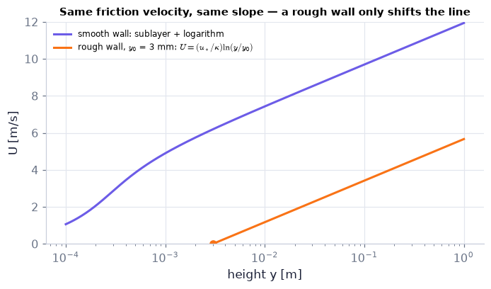

```python
y_r = np.geomspace(1e-4, 1.0, 300)                            # heights from 0.1 mm to 1 m
u_st_r, nu_air = 0.4, 1.5e-5                                  # friction velocity [m/s] and viscosity of air [m²/s]
U_smooth = u_st_r*WT.spalding_uplus(y_r*u_st_r/nu_air, kappa=KAPPA, B=B_LOG)     # smooth wall: inner law in SI units
U_rough = WT.rough_wall_log_law(y_r, u_st_r, 0.003, kappa=KAPPA)                 # rough wall with y0 = 3 mm (NaN below y0)
fig, ax = plt.subplots(figsize=(6.2, 3.6))   # a new figure and its panel(s); figsize in inches
ax.semilogx(y_r, U_smooth, color=C_MEAN, label="smooth wall: sublayer + logarithm")
ax.semilogx(y_r, U_rough, color=C_RS, label="rough wall, $y_0$ = 3 mm: $U=(u_*/\\kappa)\\ln(y/y_0)$")
ax.plot([0.003], [0], "o", color=C_RS)
ax.set(xlabel="height y [m]", ylabel="U [m/s]", ylim=(0, 12), title="Same friction velocity, same slope — a rough wall only shifts the line")   # axis labels (with units), title and fixed ranges of this panel
ax.legend(fontsize=8)   # the legend names every curve
plt.show()   # display the figure
```

**What you see.** Two lines with the same slope on semi-log axes. The purple (smooth) one bends into a sublayer at the far left; the orange (rough) one is straight all the way down to $U=0$ at $y_0=3$ mm (the dot).

**How to read it.** The slope is $u_*/\kappa$ in both cases — it measures the stress. Roughness lowers the whole line: at the same height the wind over a rough surface is slower for the same stress, i.e. the drag coefficient is larger.

**What would change if…** …$y_0$ were ten times larger (crops instead of short grass): the line would shift down by $(u_*/\kappa)\ln10\approx2.2$ m/s at every height.

#### ✏️ Tiny example: wind over grass

$z_0=0.03$ m (we write $z$ for height in the atmosphere), $u_*=0.4$ m/s, $\kappa=0.41$.

1. $U(10\text{ m})=(0.4/0.41)\ln(10/0.03)=0.976\times5.81=5.67$ m/s.
2. Neutral drag coefficient at 10 m: $C_D=[\kappa/\ln(z/z_0)]^2=(0.41/5.81)^2=4.98\times10^{-3}$.
3. Check: $\tau_0=\rho u_*^2=1.2\times0.16=0.192$ Pa $=\rho C_DU^2=1.2\times4.98\times10^{-3}\times32.1$ ✓.

**Climate hook:** this $C_D$ is the neutral value every bulk surface-flux formula starts from; C15 corrects it for stability.

```python
U10 = WT.rough_wall_log_law(10.0, 0.4, 0.03, kappa=KAPPA)     # Eq. (12.93): wind at 10 m over grass (z0 = 3 cm) for u* = 0.4 m/s
CD = WT.drag_coefficient_neutral(10.0, 0.03, kappa=KAPPA)     # C_D = [κ/ln(z/z0)]²
print(f"U(10 m) = {U10:.2f} m/s;  C_D = {CD:.2e};  u* back from the wind: {WT.friction_velocity_from_wind(U10, 10.0, 0.03, kappa=KAPPA):.3f} m/s")
print(f"stress two ways: ρ u*² = {1.2*0.4**2:.3f} Pa, ρ C_D U² = {1.2*CD*U10**2:.3f} Pa")
```

```
U(10 m) = 5.67 m/s;  C_D = 4.98e-03;  u* back from the wind: 0.400 m/s
stress two ways: ρ u*² = 0.192 Pa, ρ C_D U² = 0.192 Pa
```

**What does the code above do?**

`WT.rough_wall_log_law`, `WT.drag_coefficient_neutral` and `WT.friction_velocity_from_wind` are the three uses of the rough-wall law: wind from stress, the bulk coefficient, and stress from one wind measurement — the numbers of the tiny example.

📝 **Note.** **N150 [B]** **Zero-pressure-gradient boundary layer: fitted formulas** (Monkewitz, Chauhan & Nagib 2007, for $\mathrm{Re}_x>10^6$, as quoted in the book): momentum thickness $\theta\approx0.016\,x\,\mathrm{Re}_x^{-0.15}$; displacement thickness $\delta^*\approx\theta\exp\{7.11\kappa/\ln(\mathrm{Re}_\theta)\}$; $\delta_{99}=0.2\,\delta^*[\kappa^{-1}\ln(\mathrm{Re}_{\delta^*})+3.30]$; and the skin-friction coefficient $C_f\cong2.0/[\kappa^{-1}\ln(\mathrm{Re}_{\delta^*})+3.30]^2$ — the friction law of D19 again, since $C_f=2/(U_\infty^+)^2$ (`WT.zpg_boundary_layer`). The thicknesses $\theta$, $\delta^*$, $\delta_{99}$ are those of Ch. 9.

📝 **Note.** **N151 [B]** **Two older skin-friction fits**: $C_f\cong0.370(\log_{10}\mathrm{Re}_x)^{-2.584}$ (Schultz-Grunow) and $C_f\cong0.455/[\ln(0.06\,\mathrm{Re}_x)]^2$ (White). ⚠️ One uses $\log_{10}$, the other the natural logarithm (`WT.skin_friction_zpg(Re_x, law=…)`).

📝 **Note.** **N152 [B]** **A boundary layer with our own numbers**: air at $U_\infty=60$ m/s, 3 m from the leading edge, $\nu=1.5\times10^{-5}$ m²/s, so $\mathrm{Re}_x=1.2\times10^7$ — compared with what a laminar (Blasius) layer would be at the same place.

```python
bl = WT.zpg_boundary_layer(3.0, 60.0, 1.5e-5, kappa=0.384)    # the fits of N150 at x = 3 m, U_inf = 60 m/s in air (κ = 0.384: the cited DNS value)
print(f"Re_x = {bl['Re_x']:.1e}: θ = {bl['theta']*1e3:.2f} mm, δ* = {bl['delta_star']*1e3:.2f} mm, δ99 = {bl['delta99']*1e3:.1f} mm, H = {bl['H']:.2f}, C_f = {bl['Cf']:.2e}, u* = {bl['u_star']:.2f} m/s, δ+ = {bl['Re_tau']:.0f}")   # thicknesses, shape factor, skin friction, u* and δ⁺ of the turbulent layer
print(f"laminar (Blasius) at the same Re_x: C_f = {BL.blasius_skin_friction(bl['Re_x']):.2e}, δ99 = {5.0*3.0/np.sqrt(bl['Re_x'])*1e3:.1f} mm")   # what a laminar layer would have at the same place (Ch. 9)
for law in ("schultz_grunow", "white"):                       # the two older fits
    print(f"C_f by {law}: {WT.skin_friction_zpg(bl['Re_x'], law=law):.2e}")   # the older skin-friction fits at the same Re_x
```

```
Re_x = 1.2e+07: θ = 4.16 mm, δ* = 5.51 mm, δ99 = 32.4 mm, H = 1.32, C_f = 2.32e-03, u* = 2.04 m/s, δ+ = 4410
laminar (Blasius) at the same Re_x: C_f = 1.92e-04, δ99 = 4.3 mm
C_f by schultz_grunow: 2.35e-03
C_f by white: 2.50e-03
```

**What does the code above do?**

1. `WT.zpg_boundary_layer(x, U_inf, nu, kappa=)` returns a dictionary of thicknesses and friction: $\theta\approx4.2$ mm, $\delta_{99}\approx32$ mm, $C_f\approx2.3\times10^{-3}$; $H=\delta^*/\theta\approx1.3$ is the *shape factor* of Ch. 9 (2.59 for the laminar Blasius layer — a fuller profile has a smaller $H$).
2. A laminar layer at the same $\mathrm{Re}_x$ would be about 4 mm thick with a twelve times smaller $C_f$ (Blasius, $C_f=0.664/\sqrt{\mathrm{Re}_x}$, Ch. 9): turbulence makes the layer much thicker **and** the wall shear much larger.
3. The three skin-friction fits agree within a few per cent.

📝 **Note.** **N161 [B]** **Laminar against turbulent friction over eight decades of Reynolds number.**

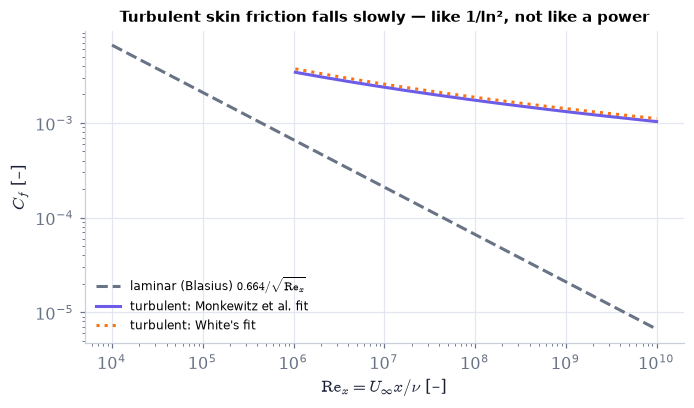

```python
Re_x = np.geomspace(1e4, 1e10, 200)                           # Reynolds numbers based on distance from the leading edge
fig, ax = plt.subplots(figsize=(6.2, 3.6))   # a new figure and its panel(s); figsize in inches
ax.loglog(Re_x, BL.blasius_skin_friction(Re_x), "--", color=C_REF, label="laminar (Blasius) $0.664/\\sqrt{\\mathrm{Re}_x}$")
turb = Re_x > 1e6                                             # the fits are for Re_x > 10⁶
ax.loglog(Re_x[turb], [WT.skin_friction_zpg(r_, law="monkewitz", kappa=0.384) for r_ in Re_x[turb]], color=C_MEAN, label="turbulent: Monkewitz et al. fit")
ax.loglog(Re_x[turb], WT.skin_friction_zpg(Re_x[turb], law="white"), ":", color=C_RS, label="turbulent: White's fit")
ax.set(xlabel="$\\mathrm{Re}_x=U_\\infty x/\\nu$ [–]", ylabel="$C_f$ [–]", title="Turbulent skin friction falls slowly — like 1/ln², not like a power")   # axis labels (with units), title and fixed ranges of this panel
ax.legend(fontsize=8)   # the legend names every curve
plt.show()   # display the figure
```

**What you see.** A dashed laminar line of slope −½ on log–log axes and, from $\mathrm{Re}_x=10^6$, two nearly identical turbulent curves that lie well above it and fall much more slowly, bending gently.

**How to read it.** The turbulent $C_f$ depends on the logarithm of the Reynolds number — the friction law that follows from the log law. It never becomes independent of Reynolds number on a smooth wall, but it changes very slowly.

**What would change if…** …the wall were rough: beyond some Reynolds number the curve would level off completely, because the roughness length, not the viscous length, would set the inner scale.

📝 **Note.** **N160 [B]** **Pipe friction from the log law** (stated). Integrating the log law over a pipe's cross-section (one integration by parts, Ch. 9 P218a) gives the bulk speed $U_{av}\cong u_*[(1/\kappa)\ln(au_*/\nu)+B-3/(2\kappa)]$ ($a$ the radius); with the Darcy friction factor $f_D=8(u_*/U_{av})^2$ this becomes an implicit friction law of the form of Prandtl's $f_D^{-1/2}=2.0\log_{10}(\mathrm{Re}_df_D^{1/2})-0.8$.

```python
a_p, us_p = 0.05, 0.5                                         # pipe radius [m] and friction velocity [m/s] (air)
Uav = WT.pipe_bulk_velocity_loglaw(a_p, us_p, 1.5e-5, kappa=KAPPA, B=B_LOG)   # the closed form for the bulk speed
yq = np.geomspace(1e-9, a_p, 4000)                            # distance from the wall for a numerical check
Uq = us_p*WT.log_law(np.maximum(yq*us_p/1.5e-5, 1e-12), kappa=KAPPA, B=B_LOG)   # log law at every y (integrable at the wall)
Uav_num = 2/a_p**2*np.trapezoid(Uq*(a_p - yq), yq)            # U_av = (2/a²) ∫ U (a − y) dy
print(f"bulk speed: closed form {Uav:.3f} m/s, quadrature {Uav_num:.3f} m/s;  derived coefficient of log10: {np.log(10)/(KAPPA*np.sqrt(8)):.2f} (Prandtl: 2.0)")
fD = WT.pipe_friction_factor_turbulent(1e5)                   # Prandtl's law at Re_d = 10⁵ (constants as cited in the docstring)
print(f"f_D(Re_d = 1e5): turbulent {fD:.4f}, laminar formula 64/Re would give {LAM.pipe_friction_factor(1e5):.5f} — the turbulent value is {fD/LAM.pipe_friction_factor(1e5):.0f} times larger")
```

```
bulk speed: closed form 9.718 m/s, quadrature 9.718 m/s;  derived coefficient of log10: 1.99 (Prandtl: 2.0)
f_D(Re_d = 1e5): turbulent 0.0180, laminar formula 64/Re would give 0.00064 — the turbulent value is 28 times larger
```

**What does the code above do?**

1. `WT.pipe_bulk_velocity_loglaw` is the closed form; the trapezoid integral of the log law over the cross-section reproduces it.
2. Turning the natural logarithm into $\log_{10}$ gives the coefficient $\ln(10)/(\kappa\sqrt8)=1.99$ for $\kappa=0.41$ — Prandtl's 2.0.
3. `WT.pipe_friction_factor_turbulent(1e5)` solves the implicit law: $f_D\approx0.018$, about 28 times what the laminar formula $64/\mathrm{Re}$ of Ch. 8 would give at that Reynolds number.

#### 🎮 Interactive: Where does the logarithm come from?

**Why interactive rather than a static figure:** sliding the friction Reynolds number stretches the log region while the inner curve stays fixed in wall units; switching to outer units makes the opposite collapse; the indicator shows the plateau 1/κ appear only when δ⁺ is large.

Start with the **Walkthrough**; the **Explain** tab works every number out with your settings, and the **Derivation** tab steps through the same derivation as above.

**What to try:**

- Raise Re_τ from 180 to 5200: the straight part grows from nothing to more than a decade.
- Switch to outer scaling: now the wakes collapse and the wall region fans out.
- Click y⁺ = 12: buffer layer — neither law holds.
- Switch to a rough wall and change y₀⁺.

```python
show_viz("ch12", "law_of_the_wall")   # full-width explainer; ⤢ Full screen for more room
```

🎮 Interactive 7/10 Where does the logarithm come from? Open alone ↗

[interactive chart not shown]

**What would change if…** …we tried to *compute* this profile from the averaged equations? We must guess the Reynolds stress. The simplest guess that returns the logarithm is next (C12).

## 12.10 Turbulence Modeling

**What is this section about?** Closing the gap: replacing the unknown Reynolds stress by a formula in terms of the mean flow. We build the simplest such model, see exactly what its one constant does, then meet the two-equation model used in most engineering codes.

### 🧩 The turbulent-viscosity hypothesis $\overline{u_iu_j}=\frac23\bar e\delta_{ij}-\nu_T\big(\frac{\partial U_i}{\partial x_j}+\frac{\partial U_j}{\partial x_i}\big)$ (12.94) and the mixing length `C12`

*The question:* What does 'modelling the Reynolds stress' mean in practice, and how can one constant give the whole profile?

#### The problem in plain words

Every ocean and atmosphere model has a number called the eddy viscosity (Ch. 13's Ekman layer cannot be written down without it). It is not a property of water or air — honey has a viscosity, a storm does not — but of the *flow*: big energetic eddies mix momentum fast. **N162 [B]**: the *turbulent-viscosity hypothesis* for momentum and the *gradient-diffusion hypothesis* for heat and scalars assume, by analogy with Newton's, Fourier's and Fick's laws of Ch. 1 and 4, that a turbulent flux is proportional to the gradient of the mean quantity.

#### The idea

A diffusivity is (speed of the carriers) × (distance they travel before mixing). For molecules: thermal speed × mean free path. For turbulence: eddy speed $u_T$ × eddy size $l_T$. Near a wall an eddy cannot be bigger than its distance from the wall: $l_T=\kappa y$. One guessed length — and the log law comes out. Symbols: $\nu_T$ eddy (turbulent) viscosity [m²/s]; $l_T$ the *mixing length* [m]; $u_T$ a turbulent velocity scale [m/s].

> 🔁 **Tools from earlier chapters used in this block** (one line each; the full primers are in the chapters named)
- **scipy.integrate.cumulative_trapezoid** — `cumulative_trapezoid(f, x, initial=0)` returns the running integral at every sample — the numerical antiderivative; turns a pressure gradient into a pressure profile (slider from scratch). *(Ch. 8, P190)*
- **reading reference data files** — benchmark tables live in `reference/chNN/*.csv` with the citation in the header. *(Ch. 10, P251)*

```python
gU_s = np.zeros((3, 3)); gU_s[0, 1] = 2.0                     # a simple shear dU/dy = 2 1/s
print(np.round(ch12.eddy_viscosity_stress(gU_s, 0.01, 0.3), 3))   # Eq. (12.94) with ν_T = 0.01 m²/s and ē = 0.3 m²/s²: mean(u_i u_j) [m²/s²]
print(f"heat flux by gradient diffusion: mean(wT') = {ch12.gradient_diffusion_flux(-0.01, 1.0):.3f} K m/s for dT/dz = −0.01 K/m, κ_T = 1 m²/s")   # Eq. (12.95)
print(f"ν_T ~ l_T u_T = {ch12.eddy_diffusivity_estimate(0.1, 0.5):.3f} m²/s for l_T = 0.1 m, u_T = 0.5 m/s")   # Eq. (12.98): the parcels of C04
```

```
[[ 0.2  -0.02  0.  ]
 [-0.02  0.2   0.  ]
 [ 0.    0.    0.2 ]]
heat flux by gradient diffusion: mean(wT') = 0.010 K m/s for dT/dz = −0.01 K/m, κ_T = 1 m²/s
ν_T ~ l_T u_T = 0.050 m²/s for l_T = 0.1 m, u_T = 0.5 m/s
```

**What does the code above do?**

1. `ch12.eddy_viscosity_stress(gradU, nu_T, e)` evaluates the hypothesis of this block's title: the shear component is $\overline{uv}=-\nu_T\,dU/dy=-0.02$ m²/s² (negative for a positive shear, as in C04), and each normal stress is $\tfrac23\bar e=0.2$ m²/s² — the model makes the normal stresses equal, which real shear flows are not (C04's anisotropy).
2. `ch12.gradient_diffusion_flux(grad, K)` is "flux = −diffusivity × gradient"; `ch12.eddy_diffusivity_estimate(l_T, u_T)` the product of a length and a velocity: 0.05 m²/s for the parcels of C04's tiny example.

📝 **Note.** **N163 [B]** **Gradient diffusion of heat** with an eddy thermal diffusivity $\kappa_T$ [m²/s].

$$ \overline{u_iT'}=-\kappa_T\,\partial\bar T/\partial x_i \qquad \text{(12.95)} $$

📝 **Note.** **N164 [B]** **Gradient diffusion of a scalar** with an eddy mass diffusivity $\kappa_{mT}$ [m²/s].

$$ \overline{u_iY'}=-\kappa_{mT}\,\partial\bar Y/\partial x_i \qquad \text{(12.96)} $$

📝 **Note.** **N165 [B]** **The closed mean momentum equation.** Put the hypothesis $\overline{u_iu_j}=\frac23\bar e\delta_{ij}-\nu_T\big(\frac{\partial U_i}{\partial x_j}+\frac{\partial U_j}{\partial x_i}\big)$ (12.94) into the constant-density RANS equation:

$$\frac{\partial U_i}{\partial t}+U_j\frac{\partial U_i}{\partial x_j}=-\frac1\rho\frac{\partial P}{\partial x_i}+\frac{\partial}{\partial x_j}\Big([\nu+\nu_T]\Big(\frac{\partial U_i}{\partial x_j}+\frac{\partial U_j}{\partial x_i}\Big)-\frac23\bar e\delta_{ij}\Big)\qquad\text{(12.97)}$$

The eddy viscosity simply adds to the molecular one, and the $\tfrac23\bar e$ term acts as an extra pressure.

> ⚠️ **slip #6 — the book prints** the pressure gradient as $\partial P/\partial x_j$ **; the correct form is** $\partial P/\partial x_i$: $i$ is the free index of the equation, and an index that appears once in a term cannot be $j$.

```python
nu_m, nuT_m, rho_m = 1.0e-3, 0.05, 1.0                        # molecular viscosity, a constant eddy viscosity [m²/s], density [kg/m³]
U_f = lambda x: np.array([x[1]**2, 0.0])                      # a manufactured mean flow: U = y², V = 0
P_f = lambda x: 2*(nu_m + nuT_m)*rho_m*x[0]                   # the pressure that balances it: dP/dx = 2 (ν + ν_T) ρ
res_ok = ch12.rans_eddy_viscosity_residual(U_f, P_f, lambda x: nuT_m, lambda x: 0.3, np.array([0.4, 0.7]), nu=nu_m, rho=rho_m)   # corrected index
res_bad = ch12.rans_eddy_viscosity_residual(U_f, P_f, lambda x: nuT_m, lambda x: 0.3, np.array([0.4, 0.7]), nu=nu_m, rho=rho_m, printed=True)   # as printed
print("residual of (12.97), corrected:", np.round(res_ok, 8), "| with the printed index:", np.round(res_bad, 4))
```

```
residual of (12.97), corrected: [-0.  0.] | with the printed index: [-0.     0.102]
```

**What does the code above do?**

`ch12.rans_eddy_viscosity_residual` evaluates left side minus right side of the closed equation by finite differences for fields given as functions. Our manufactured field $U=y^2$ with $dP/dx=2(\nu+\nu_T)\rho$ satisfies it (residual ≈ 0 in both components). With `printed=True` — one reading of the page's ill-formed index — a spurious pressure force appears in the $y$-component.

📝 **Note.** **N166 [B]** **Why the analogy with molecules is imperfect.** Molecules travel a mean free path far smaller than the flow (small Knudsen number, Ch. 1), so molecular viscosity is a property of the fluid. Eddies are as big as the shear layer itself, $l_T/L=O(1)$ — there is no separation of scales, so $\nu_T$ cannot be a universal constant; it must be modelled flow by flow.

📝 **Note.** **N167 [B]** **The size of an eddy diffusivity.** C16 will derive the eddy diffusivity $D_T=\overline{u^2}\Lambda_t$ for dispersion — the same product of a velocity squared and a time, i.e. a velocity and a length.

$$ \nu_T,\ \kappa_T,\ \text{or}\ \kappa_{mT}\sim l_Tu_T \qquad \text{(12.98)} $$

#### 🧮 Derivation — The mixing length: $-\overline{uv}=l_T^2(dU/dy)^2$, the wall model, $dU^+/dy^+=2/(1+\sqrt{1+4\kappa^2y^{+2}})$ and the logarithmic limit `D21` ★★ (Eq. 12.101: $\frac U{u_*}\cong\frac1\kappa\ln y+\mathit{const.}$)

**What we want to show.** Build the simplest closure for the Reynolds shear stress and show that, near a wall, it returns the logarithmic law.

**Assumptions.** Unidirectional mean flow U(y); zero pressure gradient near the wall (constant-stress layer, D17); the eddy size is proportional to the distance from the wall.

**The plan.**

1. Specialise the hypothesis to a simple shear.
2. Estimate ν_T from a length and a velocity.
3. Put l_T = κy into the momentum equation.
4. Integrate once.
5. Solve the quadratic.
6. Take the two limits.

**Tools we use** (each explained before this point): the parcel estimate of C04 (N50) · quadratic formula (P159) · limits · `cumulative_trapezoid` (P190)

**We start from**

$$ \begin{array}{l}\overline{u_iu_j}=\dfrac23\bar e\,\delta_{ij}-\nu_T\Big(\dfrac{\partial U_i}{\partial x_j}+\dfrac{\partial U_j}{\partial x_i}\Big)\ \text{(12.94) and} \\ 0=-\dfrac1\rho\dfrac{dP}{dx}+\dfrac{\partial}{\partial y}\Big(\nu\dfrac{\partial U}{\partial y}-\overline{uv}\Big)\ \text{(12.99).}\end{array} $$

**Step 1 of 11 — Specialise the hypothesis to U(y).**

$$ -\overline{uv}=\nu_T\dfrac{dU}{dy} $$

- *Why we can do this:* In $\overline{u_iu_j}=\tfrac23\bar e\delta_{ij}-\nu_T(\partial U_i/\partial x_j+\partial U_j/\partial x_i)$ (12.94) take i = 1, j = 2: $\delta_{12}=0$ and only $\partial U_1/\partial x_2=dU/dy$ is non-zero.
- *In words:* The Reynolds shear stress is modelled like a viscous stress with a different viscosity.

**Step 2 of 11 — Estimate the eddy viscosity.**

$$ \nu_T\sim l_T\,u_T $$

- *Why we can do this:* A diffusivity is a length times a velocity (units m²/s); for turbulence the carriers are eddies of size $l_T$ and speed $u_T$. This is (12.98), $\nu_T\sim l_Tu_T$.
- *In words:* Big, fast eddies mix more.

**Step 3 of 11 — Estimate the eddy velocity from the shear.**

$$ u_T\sim l_T\dfrac{dU}{dy}\ \Rightarrow\ -\overline{uv}=l_T^2\Big(\dfrac{dU}{dy}\Big)^2 $$

- *Why we can do this:* A parcel displaced by $l_T$ arrives with a velocity excess $l_T\,dU/dy$ (the parcel argument of C04); the proportionality constant is absorbed into $l_T$.
- *In words:* The stress grows as the square of the shear.

**Step 4 of 11 — Choose the length near a wall and insert.**

$$ l_T=\kappa y:\qquad0=-\dfrac1\rho\dfrac{dP}{dx}+\dfrac{\partial}{\partial y}\Big(\nu\dfrac{dU}{dy}+\kappa^2y^2\Big(\dfrac{dU}{dy}\Big)^2\Big) $$

- *Why we can do this:* An eddy cannot be larger than its distance from the wall, so $l_T\propto y$; put step 3 into $0=-\frac1\rho\frac{dP}{dx}+\frac{\partial}{\partial y}\big(\nu\frac{\partial U}{\partial y}-\overline{uv}\big)$ (12.99). This is (12.100), $0=-\frac1\rho\frac{dP}{dx}+\frac{\partial}{\partial y}\big(\nu\frac{dU}{dy}+\kappa^2y^2\big(\frac{dU}{dy}\big)^2\big)$.
- *In words:* One equation for U(y) with one constant, κ.

**Step 5 of 11 — Integrate once at zero pressure gradient.**

$$ \nu\dfrac{dU}{dy}+\kappa^2y^2\Big(\dfrac{dU}{dy}\Big)^2=\text{const} $$

- *Why we can do this:* With dP/dx = 0 the bracket has zero derivative, so it is constant.
- *In words:* The total stress — viscous plus turbulent — is the same at every height.

**Step 6 of 11 — Evaluate the constant at the wall.**

$$ \text{const}=\nu\dfrac{dU}{dy}\Big|_{y=0}=\dfrac{\tau_0}{\rho}=u_*^2 $$

- *Why we can do this:* At y = 0 the mixing-length term vanishes and the viscous stress is the wall stress; $u_*^2\equiv\tau_0/\rho$ (12.81).
- *In words:* The constant is the wall stress.

**Step 7 of 11 — Write it in wall units.**

$$ s+\kappa^2y^{+2}s^2=1,\qquad s\equiv\dfrac{dU^+}{dy^+} $$

- *Why we can do this:* Divide by $u_*^2$: $\nu(dU/dy)/u_*^2=dU^+/dy^+$ and $\kappa^2y^2(dU/dy)^2/u_*^2=\kappa^2y^{+2}s^2$.
- *In words:* Viscous share + turbulent share = 1.

**Step 8 of 11 — Solve the quadratic for the slope.**

$$ s=\dfrac{-1+\sqrt{1+4\kappa^2y^{+2}}}{2\kappa^2y^{+2}}=\dfrac{2}{1+\sqrt{1+4\kappa^2y^{+2}}} $$

- *Why we can do this:* Quadratic formula with the positive root (the velocity increases away from the wall); multiply top and bottom by $1+\sqrt{\ }$ to avoid 0/0 at the wall. (Ours.)
- *In words:* The exact slope of the model profile at every height.

**Step 9 of 11 — Take the limit near the wall.**

$$ y^+\to0:\ s\to1\ \Rightarrow\ U^+=y^+ $$

- *Why we can do this:* The square root → 1. For a very small wall distance the term with κ²y⁺² under the root is negligible, so only the viscous stress is left — the sublayer must come out.
- *In words:* The model contains the viscous sublayer $U^+=y^+$ (12.82).

**Step 10 of 11 — Take the limit far from the wall.**

$$ y^+\gg1:\ s\to\dfrac{1}{\kappa y^+}\ \Rightarrow\ \dfrac{dU}{dy}\cong\sqrt{\dfrac{\tau_0}{\rho}}\,\dfrac{1}{\kappa y},\quad\dfrac{U}{u_*}\cong\dfrac1\kappa\ln y+\text{const.} $$

- *Why we can do this:* $\sqrt{1+4\kappa^2y^{+2}}\approx2\kappa y^+\gg1$; equivalently, drop the viscous term in step 5. This is (12.101), $\frac U{u_*}\cong\frac1\kappa\ln y+\mathit{const.}$.
- *In words:* Outside the sublayer the model gives the logarithmic law with slope 1/κ.

**Step 11 of 11 — Integrate the exact slope.**

$$ U^+=\dfrac1\kappa\Big[\sinh^{-1}(a)-\dfrac{\sqrt{1+a^2}-1}{a}\Big],\ a=2\kappa y^+;\qquad B=\lim\Big(U^+-\dfrac1\kappa\ln y^+\Big)=\dfrac{\ln(4\kappa)-1}{\kappa} $$

- *Why we can do this:* $\int da/(1+\sqrt{1+a^2})=\sinh^{-1}a-(\sqrt{1+a^2}-1)/a$; for large a, $\sinh^{-1}a\to\ln(2a)$. (Ours.)
- *In words:* The model also predicts the intercept — and gets it badly wrong: −1.23 for κ = 0.41 instead of about 5.

**Result**

$$ -\overline{uv}=\kappa^2y^2(dU/dy)^2\ \text{;}\ dU^+/dy^+=2/(1+\sqrt{1+4\kappa^2y^{+2}})\ \text{;}\ U/u_*\cong\tfrac1\kappa\ln y+\text{const.}\ \text{(12.101)} $$

*In words:* One guessed length returns the log law's slope

**What it means.** κ controls the slope only. The plain model lets eddies mix right down to the wall, so the sublayer is too thin and the line sits about 6 units low; damping the mixing length within ~ 26 wall units fixes the intercept. Two constants, two jobs. **Fails when:** no single length is obvious (separated flows, jets in cross-flow) — then C13.

**Check it.** Units — $l_T^2(dU/dy)^2$: m² s⁻² ✓. y⁺ = 10, κ = 0.41: s = 0.216 (log slope 0.244); y⁺ = 100: 0.0241 (0.0244). Intercept: [ln(1.64) − 1]/0.41 = −1.23 (numerical quadrature −1.232); with van Driest damping $l_T=\kappa y[1-e^{-y^+/26}]$: B = 5.28.

📝 **Notes taught inside `D21`:** **N168 [B]** the mean momentum equation of a unidirectional flow with an eddy viscosity, $0=-\frac1\rho\frac{dP}{dx}+\frac{\partial}{\partial y}\big(\nu\frac{\partial U}{\partial y}-\overline{uv}\big)=-\frac1\rho\frac{dP}{dx}+\frac{\partial}{\partial y}\big([\nu+\nu_T]\frac{\partial U}{\partial y}\big)$ (12.99) (the Start and step 1) · **N169 [B]** Prandtl's mixing-length stress $-\overline{uv}=l_T^2(dU/dy)^2$ (steps 2–3) · **N170 [B]** the wall model $0=-\frac1\rho\frac{dP}{dx}+\frac{\partial}{\partial y}\big(\nu\frac{dU}{dy}+\kappa^2y^2\big(\frac{dU}{dy}\big)^2\big)$ (12.100) (step 4) · **N171 [B]** its first integral and the exact slope (steps 5–8) · **N172 [B]** the logarithmic limit $\frac{dU}{dy}\cong\sqrt{\frac{\tau_0}\rho}\frac1{\kappa y}$, or $\frac U{u_*}\cong\frac1\kappa\ln y+\mathit{const.}$ (12.101) (step 10).

> ⚠️ **Common confusion (traps in `D21`):** Losing the sign for negative shear (use $l_T^2\lvert dU/dy\rvert\,dU/dy$); taking the negative root; believing that recovering the log law validates the model (the slope was built in by l_T ∝ y).

#### ✏️ Tiny example: the model at y⁺ = 10

$\kappa=0.41$.

1. The first integral in wall units: $s+\kappa^2y^{+2}s^2=1$ with $s=dU^+/dy^+$.
2. $\kappa^2y^{+2}=0.1681\times100=16.81$.
3. Positive root: $s=2/(1+\sqrt{1+4\times16.81})=2/(1+8.261)=0.216$.
4. So the viscous stress carries 21.6 % and the Reynolds stress 78.4 % of $\tau_0$ here.
5. Compare the pure log slope $1/(\kappa y^+)=0.244$: already close.
6. Eddy viscosity $\nu_T/\nu=\kappa^2y^{+2}s=3.63$.

```python
plain = ch12.mixing_length_wall_profile(10.0, KAPPA)                          # the model of D21 at y⁺ = 10, l_T = κ y
damped = ch12.mixing_length_wall_profile(10.0, KAPPA, damping="van_driest")   # the same with van Driest's wall damping (A⁺ = 26)
for name, r_ in (("l_T = κy", plain), ("with van Driest damping", damped)):   # one line of numbers per model
    print(f"{name:24s}: slope {r_['slope']:.4f}, U+ = {r_['Uplus']:.2f}, −mean(uv)+ = {r_['minus_uv_plus']:.3f}, ν_T/ν = {r_['nuT_over_nu']:.2f}")
print(f"intercept B of the model's log law: {ch12.mixing_length_intercept(KAPPA):.2f} without damping "
      f"(exact: [ln(4κ) − 1]/κ = {(np.log(4*KAPPA) - 1)/KAPPA:.2f}), {ch12.mixing_length_intercept(KAPPA, A_plus=26.0):.2f} with A+ = 26")   # the intercept with and without damping
```

```
l_T = κy                : slope 0.2160, U+ = 4.67, −mean(uv)+ = 0.784, ν_T/ν = 3.63
with van Driest damping : slope 0.5260, U+ = 8.42, −mean(uv)+ = 0.474, ν_T/ν = 0.90
intercept B of the model's log law: -1.23 without damping (exact: [ln(4κ) − 1]/κ = -1.23), 5.28 with A+ = 26
```

**What does the code above do?**

1. `ch12.mixing_length_wall_profile(yplus, kappa)` returns a dictionary: the slope $s$ (= the viscous share of the stress), $U^+$, `minus_uv_plus` $=-\overline{uv}/u_*^2$ (the Reynolds share, **minus** the correlation, positive) and $\nu_T/\nu$ — the numbers of the tiny example.
2. `ch12.mixing_length_intercept(kappa)` is the constant $B$ of the logarithm the model tends to. **The plain model has the right slope $1/\kappa$ but its line sits about 6 units too low** ($B=-1.23$ instead of ≈ 5): with $l_T=\kappa y$ the eddies mix right down to the wall and the sublayer is far too thin.
3. *Van Driest's damping* is an empirical fix: $l_T=\kappa y[1-e^{-y^+/A^+}]$ switches the eddies off within about $A^+$ wall units of the wall. With the customary $A^+=26$ the intercept becomes 5.28. This is what "tuning a closure" means.

```python
# From scratch: the positive root of s + κ² y⁺² s² = 1 on a log grid, integrated with the running trapezoid rule
yp_g = np.concatenate([[0.0], np.geomspace(1e-3, 1000.0, 4000)])              # y⁺ from the wall outward
s_g = 2.0/(1.0 + np.sqrt(1.0 + 4.0*KAPPA**2*yp_g**2))                         # D21 step 8: the exact slope dU⁺/dy⁺
U_mine = cumulative_trapezoid(s_g, yp_g, initial=0.0)                         # U⁺ = ∫ s dy⁺ (running integral, Ch. 8 P190)
check_at = np.array([1.0, 10.0, 100.0, 1000.0])                               # four heights
U_lib = np.array([ch12.mixing_length_wall_profile(y_, KAPPA)["Uplus"] for y_ in check_at])   # the library (closed form)
assert np.allclose(np.interp(check_at, yp_g, U_mine), U_lib, rtol=1e-4)       # same profile
print("U+ at y+ = 1, 10, 100, 1000:", np.round(U_lib, 3), "| log law with B = −1.23:", np.round(np.log(check_at[2:])/KAPPA - 1.2324, 3))
```

```
U+ at y+ = 1, 10, 100, 1000: [ 0.953  4.672 10.029 15.619] | log law with B = −1.23: [10.    15.616]
```

**What does the code above do?**

The quadratic's positive root is evaluated point by point and integrated with `cumulative_trapezoid`; it matches the library's closed form at four heights. At $y^+=100$ and 1000 the profile is already the logarithm with $B=-1.23$.

```python
yp_f = np.geomspace(0.5, 1000.0, 50 if FAST else 80)          # y⁺ on a logarithmic grid
kappas = (0.384, 0.40, 0.41)                                  # three values of the von Kármán constant

def f6(A_plus):                                               # model profiles for one damping constant A⁺
    out = {}   # the curves of this slider position, by name
    for k_ in kappas:   # one model profile per value of κ
        prof = ch12.mixing_length_wall_profile(yp_f, k_, damping=("van_driest" if A_plus > 0 else None), A_plus=max(A_plus, 1e-9))   # D21's profile; van Driest damping only when A⁺ > 0
        out[f"mixing-length model, κ = {k_}"] = (yp_f, prof["Uplus"])   # store the curve under a name that carries κ
    out["reference log line κ = 0.41, B = 5.0 (illustrative pair)"] = (yp_f[yp_f > 10], WT.log_law(yp_f[yp_f > 10], kappa=KAPPA, B=B_LOG))   # the log law with the illustrative pair, for comparison
    return out   # hand the result back to the caller

A_values = np.linspace(0.0, 40.0, 11)        # the damping constant swept by the slider
figF6 = slider_figure(f6, "A+", A_values, xlabel="y+ [–]", ylabel="U+ [–]", title="κ turns the line, the wall damping A+ slides it up and down", yrange=(0, 28))
figF6.update_xaxes(type="log")                                # logarithmic y⁺ axis
figF6.show()   # display the interactive figure (the slider works on the web page too)
print(pd.DataFrame([{"A+": A_, **{f"B(κ={k_})": round(ch12.mixing_length_intercept(k_, A_plus=(A_ if A_ > 0 else None)), 2) for k_ in kappas}} for A_ in (0.0, 20.0, 26.0, 30.0)]).to_string(index=False))
```

[interactive chart not shown]

```
  A+  B(κ=0.384)  B(κ=0.4)  B(κ=0.41)
 0.0       -1.49     -1.32      -1.23
20.0        3.81      3.94       4.01
26.0        5.10      5.22       5.28
30.0        5.91      6.01       6.06
```

**What does the code above do?**

1. `f6(A_plus)` returns the model profile for three values of $\kappa$ and the reference log line.
2. The printed table is the intercept $B$ the model implies: at $\kappa=0.41$ it goes from −1.23 (no damping) through 4.01 ($A^+=20$) and 5.28 ($A^+=26$) to 6.06 ($A^+=30$).

**What you see.** Drag $A^+$ from 0 to 40: the three model curves keep their slopes at large $y^+$ and slide upward together; near $A^+\approx25$ the $\kappa=0.41$ curve lies on the reference line. The three $\kappa$ curves fan out — a smaller $\kappa$ gives a steeper line.

**How to read it.** **$\kappa$ sets the slope, the wall damping sets the intercept.** Neither constant comes from theory: $\kappa$ is read from measured profiles and $A^+$ is tuned until $B$ comes out right.

**What would change if…** …the wall were rough: no damping would be needed at all (there is no viscous sublayer to protect), and the intercept would be set by the roughness length instead.

> 📎 **Primer — a nonlinear diffusion problem by Picard iteration on the eddy viscosity.** `P302` · The eddy viscosity depends on the answer (on $dU/dy$). *Picard iteration* (Ch. 8's idea of repeated substitution, applied to a boundary-value problem): freeze $\nu_T$ from the last guess, solve the now **linear** problem $\frac{d}{dy}\big([\nu+\nu_T]\frac{dU}{dy}\big)=\frac1\rho\frac{dP}{dx}$, update $\nu_T$, repeat until nothing changes. `ch12.shear_flow_eddy_viscosity_solve` does this on a grid. The demo below iterates the first integral at one point.

```python
l2, s = (0.41*10.0)**2, 1.0                       # squared mixing length at y⁺ = 10 and a first guess for the slope s = dU⁺/dy⁺
for sweep in range(6):                            # six Picard sweeps on  (1 + ν_T/ν) s = 1  with  ν_T/ν = l² s
    s_new = 1.0/(1.0 + l2*s)                      # freeze ν_T from the old slope, solve the linear equation for the new slope
    s_new = 0.5*s + 0.5*s_new                     # under-relaxation: move only half-way (keeps the iteration from oscillating)
    print(f"sweep {sweep + 1}: s = {s_new:.4f}, change {abs(s_new - s):.4f}"); s = s_new   # the change shrinks every sweep; s → 0.216
```

```
sweep 1: s = 0.5281, change 0.4719
sweep 2: s = 0.3147, change 0.2134
sweep 3: s = 0.2368, change 0.0778
sweep 4: s = 0.2188, change 0.0180
sweep 5: s = 0.2163, change 0.0025
sweep 6: s = 0.2160, change 0.0003
```

📝 **Note.** **N181 [B]** **The whole channel with one mixing length** (ours). Combine the linear total stress of D17 with the damped mixing length, $(1-y/\delta)u_*^2=\nu\frac{dU}{dy}+l_T^2\big(\frac{dU}{dy}\big)^2$ with $l_T=\kappa y[1-e^{-y^+/A^+}]$ (capped in the core, where eddies are limited by the channel, not by the wall). `ch12.channel_mixing_length` solves it — a **model**, approximate against DNS.

```
laminar centreline U+ = 500.0 (= Re_τ/2), model centreline U+ = 23.2: ratio 22;  Picard converged: True in 24 sweeps
largest |model − DNS| in U+: 0.57
```

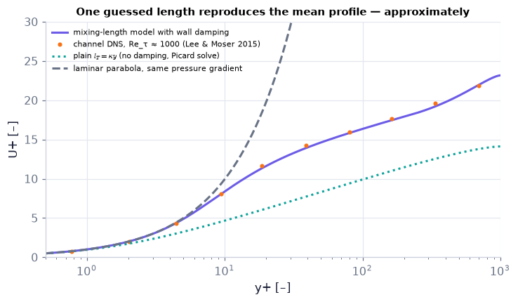

```python
ch1000 = ch12.channel_mixing_length(1000, kappa=KAPPA, A_plus=26.0)           # the model channel at Re_τ = 1000
d1000 = dns[dns["case"] == 1000]                                              # public DNS at Re_τ ≈ 1000 (Lee & Moser 2015)
y_half = np.concatenate([[0.0], np.geomspace(5e-4, 1.0, 120)])                # from one wall to the centreline, points crowded toward the wall
y_lam = np.concatenate([y_half, 2.0 - y_half[-2::-1]])                        # mirrored: the full channel in units of the half-height δ
lam = ch12.shear_flow_eddy_viscosity_solve(y_lam, lambda yf, sf: 0.0*yf, -1.0, 1.0, 1.0/1000.0)   # ν_T ≡ 0: laminar flow at the SAME pressure gradient
mix = ch12.shear_flow_eddy_viscosity_solve(y_lam, lambda yf, sf: (0.41*np.minimum(yf, 2.0 - yf))**2*np.abs(sf), -1.0, 1.0, 1.0/1000.0)   # plain mixing length l_T = κ × wall distance
print(f"laminar centreline U+ = {lam['U'].max():.1f} (= Re_τ/2), model centreline U+ = {ch1000['U_cl_plus']:.1f}: ratio {lam['U'].max()/ch1000['U_cl_plus']:.0f};  Picard converged: {mix['converged']} in {mix['iterations']} sweeps")
fig, ax = plt.subplots(figsize=(6.6, 3.8))   # a new figure and its panel(s); figsize in inches
ax.semilogx(ch1000["yplus"], ch1000["Uplus"], color=C_MEAN, lw=2, label="mixing-length model with wall damping")
ax.semilogx(d1000["yplus"].values[1::4], d1000["Uplus"].values[1::4], "o", ms=3, color=C_RS, label="channel DNS, Re_τ ≈ 1000 (Lee & Moser 2015)")
ax.semilogx(y_lam[1:121]*1000, mix["U"][1:121], ":", color=C_FLUC, label="plain $l_T=\\kappa y$ (no damping, Picard solve)")
ax.semilogx(y_lam[1:121]*1000, lam["U"][1:121], "--", color=C_REF, label="laminar parabola, same pressure gradient")
ax.set(xlabel="y+ [–]", ylabel="U+ [–]", xlim=(0.5, 1000), ylim=(0, 30), title="One guessed length reproduces the mean profile — approximately")   # axis labels (with units), title and fixed ranges of this panel
ax.legend(fontsize=7)   # the legend names every curve
print(f"largest |model − DNS| in U+: {np.abs(np.interp(d1000['yplus'].values[1:], ch1000['yplus'], ch1000['Uplus']) - d1000['Uplus'].values[1:]).max():.2f}")
```

**What you see.** The purple model curve passes through the orange DNS dots from the sublayer to the centreline. The dotted curve (no wall damping) has the same slope in the log region but lies about six units lower. The dashed laminar parabola shoots off the top of the plot — its centreline value is 500.

**How to read it.** For the same pressure gradient the laminar flow would be about 20 times faster: turbulence is an enormous extra resistance. The damped model is within about one unit of $U^+$ of the DNS — good for a one-constant-plus-one-fix model, and **only** because the two numbers were tuned on flows like this one.

**What would change if…** …the flow separated from the wall, or curved strongly: $l_T=\kappa y$ would have no justification, and the model fails. That is why models that carry their own scales were invented (C13).

📝 **Note.** **N173 [B]** **A velocity scale for convection.** A parcel warmer than its surroundings by $T'$ accelerates upward (for a perfect gas $\alpha=1/T$):

$$ Dw/Dt\sim g\alpha T'\sim g\Delta T/T \qquad \text{(12.102)} $$

📝 **Note.** **N174 [B]** **Free fall over the layer depth.** If the parcel accelerates over the depth $L$ of the layer, $w^2/L\sim g\Delta T/T$, so $w\sim\sqrt{gL\Delta T/T}$ and the eddy diffusivity is $\kappa_T\sim wL$. Our own example: a 1 km deep convecting layer with a 2 K temperature contrast at 300 K.

```python
w_c = ch12.convective_velocity_scale(1000.0, 2.0, 300.0)      # w ~ sqrt(g L ΔT/T) for L = 1 km, ΔT = 2 K, T = 300 K [m/s]
K_c = ch12.convective_eddy_diffusivity(1000.0, 2.0, 300.0)    # κ_T ~ w L [m²/s]
print(f"w ≈ {w_c:.1f} m/s, κ_T ≈ {K_c:.1e} m²/s — {K_c/2e-5:.0e} times the molecular 2e-5 m²/s")
```

```
w ≈ 8.1 m/s, κ_T ≈ 8.1e+03 m²/s — 4e+08 times the molecular 2e-5 m²/s
```

**What does the code above do?**

Thermals of about 8 m/s and an eddy diffusivity near $8\times10^3$ m²/s, some $4\times10^8$ times the molecular value: an order-of-magnitude estimate (no constant of proportionality is claimed), but it explains why a convective boundary layer is well mixed within tens of minutes.

#### 🎮 Interactive: What does a closure constant do?

**Why interactive rather than a static figure:** sliding κ rotates the log line and sliding A⁺ shifts it, with the implied intercept B read off live; switching the model off returns the laminar parabola at the same pressure gradient.

Start with the **Walkthrough**; the **Explain** tab works every number out with your settings, and the **Derivation** tab steps through the same derivation as above.

**What to try:**

- Set A⁺ = 0: the line keeps its slope but B drops to −1.2.
- Set A⁺ = 26: B = 5.3.
- Change κ from 0.41 to 0.38 and watch the slope steepen.
- Switch the model off: the laminar parabola is 20 times faster at Re_τ = 1000.

```python
show_viz("ch12", "mixing_length_closure")   # full-width explainer; ⤢ Full screen for more room
```

🎮 Interactive 8/10 What does a closure constant do? Open alone ↗

[interactive chart not shown]

**What would change if…** …no single length like $\kappa y$ is available — a separated flow, a jet in a cross-wind? Then the model must carry its own velocity and length scales: C13.

### 🧩 The modelled energy equation $\frac{\partial\bar e}{\partial t}+U_j\frac{\partial\bar e}{\partial x_j}=\frac{\partial}{\partial x_j}\big(\frac{\nu_T}{\sigma_e}\frac{\partial\bar e}{\partial x_j}\big)-\bar\varepsilon-\overline{u_iu_j}\frac{\partial U_i}{\partial x_j}$ (12.103) — the k–ε model `C13`

*The question:* Where do the constants of a turbulence model come from?

#### The problem in plain words

Most engineering flow software, and the turbulence closures inside ocean and boundary-layer schemes, carry two extra fields: how much turbulent energy there is and how fast it is being dissipated. From those two they build an eddy viscosity everywhere. The price is five constants. Are they fudge factors? Two of them are pinned by experiments you can picture. (⚠️ the "k" of k–ε is the book's $\bar e$; the book's $k$ is a wavenumber or a conductivity.)

#### The idea

A velocity scale $u_T=\sqrt{\bar e}$. A length scale: how far an eddy of that speed goes in its lifetime $\bar e/\bar\varepsilon$, so $l_T=\bar e^{3/2}/\bar\varepsilon$. Their product is the eddy viscosity, $\nu_T\propto u_Tl_T=\bar e^2/\bar\varepsilon$.

> 🔁 **Tools from earlier chapters used in this block** (one line each; the full primers are in the chapters named)
- **solve_ivp; RK4 loop** — adaptive Runge–Kutta that picks its own steps to meet a tolerance. extends P31: ask for chosen output times, get a continuous solution, stop at an event (a stagnation point), integrate backwards by giving t_span in decreasing order. four slope samples per step weighted 1-2-2-1; error ∝ Δt⁴; the from-scratch path line of Ex. 3.1 agrees with `pathline` (extends P30's Euler). *(Ch. 1, P31, Ch. 3, P94, Ch. 3, P95)*

📝 **Note.** **N175 [B]** **Ingredients of a one-equation model** (one transport equation, for $\bar e$; the length $l_T$ is still prescribed): a velocity scale $u_T=c\sqrt{\bar e}$; a modelled dissipation $\bar\varepsilon=C_\varepsilon\bar e^{3/2}/l_T$; and the three transport terms of the exact budget (C06) lumped into one gradient flux, $-\frac1{\rho_0}\overline{pu_j}+2\nu\overline{u_iS'_{ij}}-\frac12\overline{u_i^2u_j}=\frac{\nu_T}{\sigma_e}\frac{\partial\bar e}{\partial x_j}$ (`ch12.one_equation_closure`).

> ⚠️ **slip #8 — the book prints** the viscous transport here as $2\nu\overline{u_jS'_{ij}}$ **; the correct form is** $2\nu\overline{u_iS'_{ij}}$, as in the exact budget.

#### 🧮 Derivation — The modelled energy equation and the k–ε eddy viscosity $\nu_T=C_\mu\bar e^2/\bar\varepsilon$ `D22` ★ (Eq. 12.103: $\frac{\partial\bar e}{\partial t}+U_j\frac{\partial\bar e}{\partial x_j}=\frac{\partial}{\partial x_j}\big(\frac{\nu_T}{\sigma_e}\frac{\partial\bar e}{\partial x_j}\big)-\bar\varepsilon-\overline{u_iu_j}\frac{\partial U_i}{\partial x_j},\ \dots$)

**What we want to show.** Turn the exact (but unclosed) energy budget into an equation a computer can solve, and build an eddy viscosity from its two variables.

**Assumptions.** Constant density; high Reynolds number; transport of ē behaves like diffusion.

**The plan.**

1. Drop buoyancy (constant density).
2. Replace the unknown transport by a gradient flux.
3. Name the dissipation.
4. Build scales from ē and ε̄.

**Tools we use** (each explained before this point): gradient-diffusion hypothesis (N162) · substitution · units check

**We start from**

$$ \begin{array}{l}\dfrac{\partial\bar e}{\partial t}+U_j\dfrac{\partial\bar e}{\partial x_j}=\dfrac{\partial}{\partial x_j}\Big(-\dfrac1{\rho_0}\overline{pu_j}+2\nu\overline{u_iS'_{ij}}-\tfrac12\overline{u_i^2u_j}\Big)-2\nu\overline{S'_{ij}S'_{ij}}-\overline{u_iu_j}\dfrac{\partial U_i}{\partial x_j}+g\alpha\overline{u_3T'} \\ \text{(12.47) and}\ \nu_T\sim l_Tu_T\ \text{(12.98).}\end{array} $$

**Step 1 of 6 — Drop the buoyancy term.**

$$ g\alpha\,\overline{u_3T'}\to0 $$

- *Why we can do this:* From §12.8 to §12.10 the density is constant (the switch announced at the top of §12.8).
- *In words:* No buoyant production in this model.

**Step 2 of 6 — Model the three transport terms as one gradient flux.**

$$ -\dfrac1{\rho_0}\overline{pu_j}+2\nu\overline{u_iS'_{ij}}-\tfrac12\overline{u_i^2u_j}=\dfrac{\nu_T}{\sigma_e}\dfrac{\partial\bar e}{\partial x_j} $$

- *Why we can do this:* They only move energy from where there is much to where there is little; the simplest such law is diffusion down the gradient, with a diffusivity $\nu_T/\sigma_e$ ($\sigma_e$ = a constant of order one). A model, not a theorem.
- *In words:* Turbulent energy diffuses like a scalar.

**Step 3 of 6 — Name the dissipation and keep the production exact.**

$$ \dfrac{\partial\bar e}{\partial t}+U_j\dfrac{\partial\bar e}{\partial x_j}=\dfrac{\partial}{\partial x_j}\Big(\dfrac{\nu_T}{\sigma_e}\dfrac{\partial\bar e}{\partial x_j}\Big)-\bar\varepsilon-\overline{u_iu_j}\dfrac{\partial U_i}{\partial x_j} $$

- *Why we can do this:* $\bar\varepsilon\equiv2\nu\overline{S'_{ij}S'_{ij}}$ becomes an unknown of its own; the production needs no model once $\overline{u_iu_j}$ is given by the closure $\overline{u_iu_j}=\tfrac23\bar e\delta_{ij}-\nu_T(\partial U_i/\partial x_j+\partial U_j/\partial x_i)$ (12.94). This is (12.103), $\frac{\partial\bar e}{\partial t}+U_j\frac{\partial\bar e}{\partial x_j}=\frac{\partial}{\partial x_j}\big(\frac{\nu_T}{\sigma_e}\frac{\partial\bar e}{\partial x_j}\big)-\bar\varepsilon-\overline{u_iu_j}\frac{\partial U_i}{\partial x_j}$.
- *In words:* A transport equation for ē with one diffusion term, one sink, one source.

**Step 4 of 6 — Build scales from ē and ε̄.**

$$ u_T=\sqrt{\bar e},\qquad t_T=\dfrac{\bar e}{\bar\varepsilon},\qquad l_T=u_T\,t_T=\dfrac{\bar e^{3/2}}{\bar\varepsilon} $$

- *Why we can do this:* ē [m²/s²] gives a velocity; ē/ε̄ [s] is the time in which dissipation would use up the energy; their product is a length.
- *In words:* The eddies' speed, lifetime and size from the two model variables.

**Step 5 of 6 — Form the eddy viscosity.**

$$ \nu_T=C_\mu\,l_T\,u_T=C_\mu\Big[\dfrac{\bar e^{3/2}}{\bar\varepsilon}\Big]\sqrt{\bar e}=C_\mu\dfrac{\bar e^{\,2}}{\bar\varepsilon} $$

- *Why we can do this:* $\nu_T\sim l_Tu_T$ (12.98) with step 4; $C_\mu$ is the proportionality constant. This is (12.104), $\nu_T=C_\mu\bar e^2/\bar\varepsilon$.
- *In words:* More energy, or slower dissipation, means more mixing.

**Step 6 of 6 — Write the production with the model stress.**

$$ -\overline{u_iu_j}\dfrac{\partial U_i}{\partial x_j}=2\nu_T\,\bar S_{ij}\bar S_{ij}\ \ge0 $$

- *Why we can do this:* Insert $\overline{u_iu_j}=\tfrac23\bar e\delta_{ij}-\nu_T(\partial U_i/\partial x_j+\partial U_j/\partial x_i)$ (12.94): the $\tfrac23\bar e\delta_{ij}$ part contracts to $\partial U_i/\partial x_i=0$ (12.27); the rest is a symmetric contraction.
- *In words:* In this model production can never be negative.

**Result**

$$ \begin{array}{l}\frac{\partial\bar e}{\partial t}+U_j\frac{\partial\bar e}{\partial x_j}=\frac{\partial}{\partial x_j}\big(\frac{\nu_T}{\sigma_e}\frac{\partial\bar e}{\partial x_j}\big)-\bar\varepsilon-\overline{u_iu_j}\frac{\partial U_i}{\partial x_j} \\ \text{(12.103) with}\ \nu_T=C_\mu\bar e^2/\bar\varepsilon\ \text{(12.104)}\end{array} $$

*In words:* Two fields, ē and ε̄, give a viscosity everywhere

**What it means.** The model still needs an equation for ε̄ — $\frac{\partial\bar\varepsilon}{\partial t}+U_j\frac{\partial\bar\varepsilon}{\partial x_j}=\frac{\partial}{\partial x_j}\big(\frac{\nu_T}{\sigma_\varepsilon}\frac{\partial\bar\varepsilon}{\partial x_j}\big)-C_{\varepsilon1}\big(\overline{u_iu_j}\frac{\partial U_i}{\partial x_j}\big)\frac{\bar\varepsilon}{\bar e}-C_{\varepsilon2}\frac{\bar\varepsilon^2}{\bar e}$ (12.105), built by analogy rather than derived. **Fails when:** transport is not gradient-like (counter-gradient fluxes in convection), or the stress is not aligned with the mean strain (strong rotation, curvature).

**Check it.** Units — ē²/ε̄: (m²/s²)²/(m²/s³) = m²/s ✓. Number: ē = 1 m²/s², ε̄ = 1 m²/s³, $C_\mu$ = 0.09 ⇒ ν_T = 0.09 m²/s, l_T = 1 m.

📝 **Notes taught inside `D22`:** **N176 [B]** the eddy viscosity of the k–ε model, $\nu_T=C_\mu[\bar e^{3/2}/\bar\varepsilon]\sqrt{\bar e}=C_\mu\bar e^2/\bar\varepsilon$ (12.104) (steps 4–5).

> ⚠️ **Common confusion (traps in `D22`):** Thinking the Result is exact (two of its terms are models); writing the book's printed $u_j$ in the viscous transport (slip #8: it is $2\nu\overline{u_iS'_{ij}}$, the viscous transport of the exact budget in the Start).

📝 **Note.** **N177 [B]** **The modelled dissipation equation** is built by analogy with the energy equation, not derived:

$$\frac{\partial\bar\varepsilon}{\partial t}+U_j\frac{\partial\bar\varepsilon}{\partial x_j}=\frac{\partial}{\partial x_j}\Big(\frac{\nu_T}{\sigma_\varepsilon}\frac{\partial\bar\varepsilon}{\partial x_j}\Big)-C_{\varepsilon1}\Big(\overline{u_iu_j}\frac{\partial U_i}{\partial x_j}\Big)\frac{\bar\varepsilon}{\bar e}-C_{\varepsilon2}\frac{\bar\varepsilon^2}{\bar e}\qquad\text{(12.105)}$$

Term by term: change following the mean flow = gradient diffusion + (production of $\bar e$) ÷ (the time scale $\bar e/\bar\varepsilon$) − ($\bar\varepsilon$) ÷ (the same time scale), each with its own constant.

📝 **Note.** **N178 [B]** **The standard constants** (Launder & Sharma 1974; public values, `ch12.K_EPSILON_CONSTANTS`): $C_\mu=0.09$, $C_{\varepsilon1}=1.44$, $C_{\varepsilon2}=1.92$, $\sigma_e=1.0$, $\sigma_\varepsilon=1.3$.

> ⚠️ **slip #9 — the book prints** "five" constants and then lists six entries **; the correct form is** five: $C_\mu,C_{\varepsilon1},C_{\varepsilon2},\sigma_e,\sigma_\varepsilon$.

📝 **Note.** **N179 [C]** **The closed set.** Mean continuity $\partial U_i/\partial x_i=0$ (12.27); the mean momentum equation $\frac{\partial U_i}{\partial t}+U_j\frac{\partial U_i}{\partial x_j}=\frac1\rho\frac{\partial\bar\tau_{ij}}{\partial x_j}$ (12.30, constant density); the closure $\overline{u_iu_j}=\tfrac23\bar e\delta_{ij}-\nu_T(\partial U_i/\partial x_j+\partial U_j/\partial x_i)$ (12.94); the $\bar e$ equation of D22 with $\nu_T=C_\mu\bar e^2/\bar\varepsilon$ (12.104); and the $\bar\varepsilon$ equation of N177 above. At a wall the log law of C11 is imposed as a boundary condition (a "wall function"); results are sensitive to the inlet values of $\bar e$ and $\bar\varepsilon$. *Reynolds-stress closures* model the transport equation for $\overline{u_iu_j}$ (N59 in C04) instead of assuming an eddy viscosity (named in Ch. 10).

```python
print(ch12.K_EPSILON_CONSTANTS)                               # the five standard constants
one = ch12.one_equation_closure(1.0, 0.1, 0.55, 0.17, 1.0)    # ē = 1 m²/s², l_T = 0.1 m; c, C_ε, σ_e ILLUSTRATIVE
print({k: round(float(v), 3) for k, v in one.items()})        # u_T, ν_T = l_T u_T, modelled ε̄, transport diffusivity
print("dē/dt, dε̄/dt for ē = ε̄ = 1 and production 0.5:", ch12.k_epsilon_rhs(1.0, 1.0, 0.5), "| with no production:", ch12.k_epsilon_rhs(1.0, 1.0, 0.0))
```

```
{'C_mu': 0.09, 'C_eps1': 1.44, 'C_eps2': 1.92, 'sigma_e': 1.0, 'sigma_eps': 1.3}
{'u_T': 0.55, 'nu_T': 0.055, 'eps': 1.7, 'transport_diffusivity': 0.055}
dē/dt, dε̄/dt for ē = ε̄ = 1 and production 0.5: (-0.5, -1.2) | with no production: (-1.0, -1.92)
```

**What does the code above do?**

1. `ch12.one_equation_closure(e, l_T, c, C_eps, sigma_e)` returns the ingredients of **N175** for illustrative constants.
2. `ch12.k_epsilon_rhs(e, eps, production)` evaluates the source terms of the two model equations for homogeneous turbulence: $d\bar e/dt=P-\bar\varepsilon=-0.5$ and $d\bar\varepsilon/dt=(1.44\times0.5-1.92)\,\bar\varepsilon/\bar e=-1.2$; with no production, $(-1.0,-1.92)$ — the pair of ODEs the next derivation integrates.

> 📎 **Primer — dividing two ODEs to eliminate time.** `P303` · If $dy/dt=f$ and $dx/dt=g$, then $dy/dx=f/g$: time disappears and $y$ is found as a function of $x$. If the result is $dy/dx=n\,y/x$, the solution is the power law $y\propto x^n$.

```python
x_s = sp.symbols("x", positive=True); y_s = sp.Function("y")  # the independent variable and the unknown function
print(sp.dsolve(sp.Eq(y_s(x_s).diff(x_s), 2*y_s(x_s)/x_s)))   # dy/dx = 2 y/x  →  y = C1 x²
```

```
Eq(y(x), C1*x**2)
```

#### 🧮 Derivation — What fixes the k–ε constants: decay $\bar e\propto(t+t_0)^{-n}$, $n=1/(C_{\varepsilon2}-1)$, and the log layer $\kappa^2=\sqrt{C_\mu}(C_{\varepsilon2}-C_{\varepsilon1})\sigma_\varepsilon$ `D23` ★★ (Eq. 12.105: $\frac{\partial\bar\varepsilon}{\partial t}+U_j\frac{\partial\bar\varepsilon}{\partial x_j}=\frac{\partial}{\partial x_j}\big(\frac{\nu_T}{\sigma_\varepsilon}\frac{\partial\bar\varepsilon}{\partial x_j}\big)-C_{\varepsilon1}\big(\overline{u_iu_j}\frac{\partial U_i}{\partial x_j}\big)\frac{\bar\varepsilon}{\bar e}-C_{\varepsilon2}\frac{\bar\varepsilon^2}{\bar e},\ \dots$)

**What we want to show.** Show that two of the model's constants are tied to things one can measure — how fast grid turbulence decays, and the von Kármán constant. The book states the constants; this derivation is ours.

**Assumptions.** (a) homogeneous turbulence with no mean shear; (b) a steady constant-stress layer in local equilibrium.

**The plan.**

1. Homogeneous decay: two ODEs, divide them, integrate twice.
2. Log layer: production = dissipation, uniform ē, and what is left of the ε̄ equation.

**Tools we use** (each explained before this point): dividing two ODEs (P303, primer above) · separable ODE · the log-layer values of C11

**We start from**

$$ \begin{array}{l}\frac{\partial\bar e}{\partial t}+U_j\frac{\partial\bar e}{\partial x_j}=\frac{\partial}{\partial x_j}\big(\frac{\nu_T}{\sigma_e}\frac{\partial\bar e}{\partial x_j}\big)-\bar\varepsilon-\overline{u_iu_j}\frac{\partial U_i}{\partial x_j} \\ \text{(12.103) and} \\ \dfrac{\partial\bar\varepsilon}{\partial t}+U_j\dfrac{\partial\bar\varepsilon}{\partial x_j}=\dfrac{\partial}{\partial x_j}\Big(\dfrac{\nu_T}{\sigma_\varepsilon}\dfrac{\partial\bar\varepsilon}{\partial x_j}\Big)-C_{\varepsilon1}\Big(\overline{u_iu_j}\dfrac{\partial U_i}{\partial x_j}\Big)\dfrac{\bar\varepsilon}{\bar e}-C_{\varepsilon2}\dfrac{\bar\varepsilon^{\,2}}{\bar e} \\ \text{(12.105).}\end{array} $$

**Step 1 of 12 — Reduce the ē equation for decaying homogeneous turbulence.**

$$ \dfrac{d\bar e}{dt}=-\bar\varepsilon $$

- *Why we can do this:* Homogeneous: every spatial derivative of a statistic vanishes (no transport, no advection); no mean shear: no production.
- *In words:* The energy only decays.

**Step 2 of 12 — Reduce the ε̄ equation the same way.**

$$ \dfrac{d\bar\varepsilon}{dt}=-C_{\varepsilon2}\dfrac{\bar\varepsilon^{\,2}}{\bar e} $$

- *Why we can do this:* Only the destruction term $-C_{\varepsilon2}\bar\varepsilon^2/\bar e$ of the Start's ε̄ equation survives.
- *In words:* The dissipation rate decays too, at a rate set by one constant.

**Step 3 of 12 — Divide the second by the first.**

$$ \dfrac{d\bar\varepsilon}{d\bar e}=C_{\varepsilon2}\dfrac{\bar\varepsilon}{\bar e} $$

- *Why we can do this:* $d\bar\varepsilon/d\bar e=(d\bar\varepsilon/dt)/(d\bar e/dt)$ eliminates time (P303).
- *In words:* How ε̄ changes as ē falls.

**Step 4 of 12 — Integrate.**

$$ \ln\bar\varepsilon=C_{\varepsilon2}\ln\bar e+\text{const}\ \Rightarrow\ \bar\varepsilon=\bar\varepsilon_0\Big(\dfrac{\bar e}{\bar e_0}\Big)^{C_{\varepsilon2}} $$

- *Why we can do this:* Separable: $d\bar\varepsilon/\bar\varepsilon=C_{\varepsilon2}\,d\bar e/\bar e$; the constant is fixed by the initial values.
- *In words:* Dissipation is a power of the energy.

**Step 5 of 12 — Put it back into step 1.**

$$ \dfrac{d\bar e}{dt}=-\bar\varepsilon_0\Big(\dfrac{\bar e}{\bar e_0}\Big)^{C_{\varepsilon2}} $$

- *Why we can do this:* Now one equation for ē alone.
- *In words:* The decay rate depends on how much energy is left.

**Step 6 of 12 — Separate and integrate.**

$$ \Big(\dfrac{\bar e}{\bar e_0}\Big)^{-(C_{\varepsilon2}-1)}=1+(C_{\varepsilon2}-1)\dfrac{\bar\varepsilon_0}{\bar e_0}\,t $$

- *Why we can do this:* $\int\bar e^{-C_{\varepsilon2}}d\bar e=\bar e^{1-C_{\varepsilon2}}/(1-C_{\varepsilon2})$; apply ē = ē₀ at t = 0.
- *In words:* A power of the energy grows linearly in time.

**Step 7 of 12 — Solve for ē.**

$$ \bar e=\bar e_0\Big(1+\dfrac{t}{t_0}\Big)^{-n},\quad n=\dfrac{1}{C_{\varepsilon2}-1},\quad t_0=\dfrac{n\,\bar e_0}{\bar\varepsilon_0};\qquad\bar\varepsilon=\bar\varepsilon_0\Big(1+\dfrac{t}{t_0}\Big)^{-(n+1)} $$

- *Why we can do this:* Raise step 6 to the power −n; ε̄ from step 1 by differentiation.
- *In words:* Power-law decay: the exponent is measured behind grids, so it fixes $C_{\varepsilon2}$.

**Step 8 of 12 — In a log layer set production equal to dissipation.**

$$ \bar\varepsilon=-\overline{uv}\dfrac{dU}{dy}=u_*^2\cdot\dfrac{u_*}{\kappa y}=\dfrac{u_*^3}{\kappa y} $$

- *Why we can do this:* Steady, with ē uniform (step 10) there is no transport in the Start's ē equation; the log-layer values are $-\overline{uv}=u_*^2$, $dU/dy=u_*/(\kappa y)$ from $U^+=\tfrac1\kappa\ln y^++B$ (12.88).
- *In words:* Local equilibrium: what is produced at a height is dissipated there.

**Step 9 of 12 — Find the eddy viscosity there.**

$$ \nu_T=\dfrac{-\overline{uv}}{dU/dy}=\kappa\,u_*\,y $$

- *Why we can do this:* Definition of ν_T for a simple shear (D21 step 1).
- *In words:* The eddy viscosity grows linearly with height.

**Step 10 of 12 — Use the model's formula for ν_T.**

$$ \kappa u_*y=C_\mu\dfrac{\bar e^{\,2}}{\bar\varepsilon}=C_\mu\,\bar e^{\,2}\,\dfrac{\kappa y}{u_*^3}\ \Rightarrow\ \bar e=\dfrac{u_*^2}{\sqrt{C_\mu}} $$

- *Why we can do this:* $\nu_T=C_\mu\bar e^2/\bar\varepsilon$ (12.104) with step 8; y cancels, so ē is the same at every height — which justifies dropping its transport.
- *In words:* In the log layer the turbulent energy is a fixed multiple of u_*².

**Step 11 of 12 — Reduce the ε̄ equation in the log layer.**

$$ 0=\dfrac{d}{dy}\Big(\dfrac{\nu_T}{\sigma_\varepsilon}\dfrac{d\bar\varepsilon}{dy}\Big)+\big(C_{\varepsilon1}-C_{\varepsilon2}\big)\dfrac{\bar\varepsilon^{\,2}}{\bar e} $$

- *Why we can do this:* Steady, V = 0; the production $-\overline{u_iu_j}\,\partial U_i/\partial x_j$ equals ε̄ (step 8), so the source is $+C_{\varepsilon1}\bar\varepsilon^2/\bar e$. Unlike ē, ε̄ varies with y, so its diffusion remains.
- *In words:* Diffusion of ε̄ must make up the difference between its source and its sink.

**Step 12 of 12 — Insert steps 8–10.**

$$ \dfrac{u_*^4}{\sigma_\varepsilon y^2}=\big(C_{\varepsilon2}-C_{\varepsilon1}\big)\dfrac{\sqrt{C_\mu}\,u_*^4}{\kappa^2y^2}\ \Rightarrow\ \kappa^2=\sqrt{C_\mu}\,\big(C_{\varepsilon2}-C_{\varepsilon1}\big)\,\sigma_\varepsilon $$

- *Why we can do this:* $d\bar\varepsilon/dy=-u_*^3/(\kappa y^2)$, $\nu_T\,d\bar\varepsilon/dy=-u_*^4/y$, its derivative $+u_*^4/y^2$; and $\bar\varepsilon^2/\bar e=u_*^4\sqrt{C_\mu}/(\kappa^2y^2)$.
- *In words:* The model reproduces the log law only if its constants obey this relation.

**Result**

$$ n=1/(C_{\varepsilon2}-1)\ \text{;}\ \kappa^2=\sqrt{C_\mu}(C_{\varepsilon2}-C_{\varepsilon1})\sigma_\varepsilon\ \text{;}\ \bar e=u_*^2/\sqrt{C_\mu} $$

*In words:* The constants are tied to the decay exponent and to κ

**What it means.** Measured decay exponents (about 1.1–1.3) and κ ≈ 0.38–0.41 bracket the standard values: the set is a compromise, not a fit to one flow. $C_\mu$ itself comes from the measured ratio $-\overline{uv}/\bar e\approx0.3$ in equilibrium shear layers ($\sqrt{C_\mu}=0.3$). **Fails when:** the flow is far from these two calibration states.

**Check it.** Units — t₀ = ē₀/ε̄₀ in s ✓; κ dimensionless ✓. Standard set ($C_\mu$ = 0.09, $C_{\varepsilon1}$ = 1.44, $C_{\varepsilon2}$ = 1.92, $\sigma_\varepsilon$ = 1.3; Launder & Sharma 1974): n = 1.087, κ = 0.433, ē/u_*² = 3.33. ē₀ = ε̄₀ = 1: ē(10 s) = 0.0801 (closed form = `solve_ivp` = RK4 to 1e-6). Limit $C_{\varepsilon2}\to2$: n = 1.

📝 **Notes taught inside `D23`:** **N180 [B]** what fixes two of the constants: the decay exponent of grid turbulence, $n=1/(C_{\varepsilon2}-1)$, and the von Kármán constant in the log layer, $\kappa^2=\sqrt{C_\mu}(C_{\varepsilon2}-C_{\varepsilon1})\sigma_\varepsilon$ (steps 1–12).

> ⚠️ **Common confusion (traps in `D23`):** The sign of the $C_{\varepsilon1}$ term (the book writes $-C_{\varepsilon1}(\overline{u_iu_j}\,\partial U_i/\partial x_j)\bar\varepsilon/\bar e$, which is positive because the bracket is negative); dropping the diffusion of ε̄ in the log layer (then no relation for κ follows); counting six constants (slip #9: there are five).

#### ✏️ Tiny example: what the standard constants imply

1. Decay exponent $n=1/(C_{\varepsilon2}-1)=1/0.92=1.087$ — grid-turbulence experiments give $n\approx1.1$–1.3: $C_{\varepsilon2}$ was chosen to match.
2. Log layer: $\kappa^2=\sqrt{C_\mu}(C_{\varepsilon2}-C_{\varepsilon1})\sigma_\varepsilon=0.3\times0.48\times1.3=0.187$, $\kappa=0.433$ — a little above the measured 0.38–0.41: the constants are a compromise.
3. In the log layer $\bar e/u_*^2=1/\sqrt{C_\mu}=3.33$.
4. Decay from $\bar e_0=1$ m²/s², $\bar\varepsilon_0=1$ m²/s³: $t_0=n\bar e_0/\bar\varepsilon_0=1.087$ s; at $t=10$ s, $\bar e=(1+10/1.087)^{-1.087}=0.080$ m²/s².

```python
t_d = np.array([0.0, 1.0, 10.0])                              # three times [s]
e_d, eps_d, n_d, t0_d = ch12.k_epsilon_decay(1.0, 1.0, t_d)   # decaying homogeneous turbulence from ē0 = 1 m²/s², ε̄0 = 1 m²/s³
print(f"n = {n_d:.4f}, t0 = {t0_d:.4f} s;  ē = {np.round(e_d, 4)} m²/s²,  ε̄ = {np.round(eps_d, 5)} m²/s³")   # decay exponent, virtual origin, and ē, ε̄ at t = 0, 1, 10 s
print(f"κ implied by the constants: {ch12.k_epsilon_loglayer_kappa(0.09, 1.44, 1.92, 1.3):.4f}")   # D23's log-layer relation κ² = √C_μ (C_ε2 − C_ε1) σ_ε
print(f"ν_T = C_μ ē²/ε̄ at t = 0, 10 s: {ch12.k_epsilon_eddy_viscosity(e_d[0], eps_d[0]):.4f}, {ch12.k_epsilon_eddy_viscosity(e_d[2], eps_d[2]):.4f} m²/s;  "   # Eq. (12.104) at the start and after 10 s …
      f"l_T = ē^1.5/ε̄: {ch12.k_epsilon_length_scale(e_d[0], eps_d[0]):.2f} → {ch12.k_epsilon_length_scale(e_d[2], eps_d[2]):.2f} m")   # … and the length scale ē^(3/2)/ε̄ at the same two times [m]
```

```
n = 1.0870, t0 = 1.0870 s;  ē = [1.     0.4921 0.0801] m²/s²,  ε̄ = [1.     0.2563 0.0078] m²/s³
κ implied by the constants: 0.4327
ν_T = C_μ ē²/ε̄ at t = 0, 10 s: 0.0900, 0.0735 m²/s;  l_T = ē^1.5/ε̄: 1.00 → 2.89 m
```

**What does the code above do?**

1. `ch12.k_epsilon_decay(e0, eps0, t)` returns $\bar e(t)$, $\bar\varepsilon(t)$, the exponent $n$ and the virtual origin $t_0$ (the closed form of D23): $\bar e$ falls to 0.49 after 1 s and 0.080 after 10 s.
2. `ch12.k_epsilon_loglayer_kappa` is the second relation of D23: 0.433.
3. During the decay the eddy viscosity falls slowly while the length scale $l_T=\bar e^{3/2}/\bar\varepsilon$ **grows**: the small eddies die first, leaving the big ones.

```python
# From scratch: the two decay ODEs with a hand-written fourth-order Runge–Kutta loop (Ch. 3, P95)
def rhs(state):                                               # dē/dt = −ε̄,  dε̄/dt = −C_ε2 ε̄²/ē  (no production, no transport)
    e_, eps_ = state   # the two unknowns: turbulent energy ē and dissipation rate ε̄
    return np.array([-eps_, -1.92*eps_**2/e_])   # hand the result back to the caller

state, dt_rk = np.array([1.0, 1.0]), 0.01                     # initial ē, ε̄ and the time step [s]
for _ in range(1000):                                         # 1000 steps to t = 10 s
    k1 = rhs(state); k2 = rhs(state + 0.5*dt_rk*k1); k3 = rhs(state + 0.5*dt_rk*k2); k4 = rhs(state + dt_rk*k3)   # four slopes
    state = state + dt_rk*(k1 + 2*k2 + 2*k3 + k4)/6           # RK4 update
assert np.allclose(state, [e_d[2], eps_d[2]], rtol=1e-6)      # same ē(10) and ε̄(10) as the closed form
print("RK4 at t = 10 s:", np.round(state, 5))
```

```
RK4 at t = 10 s: [0.0801 0.0078]
```

**What does the code above do?**

A plain RK4 loop on the two ODEs lands on the closed form at $t=10$ s to six digits: the closed form of D23 is the solution.

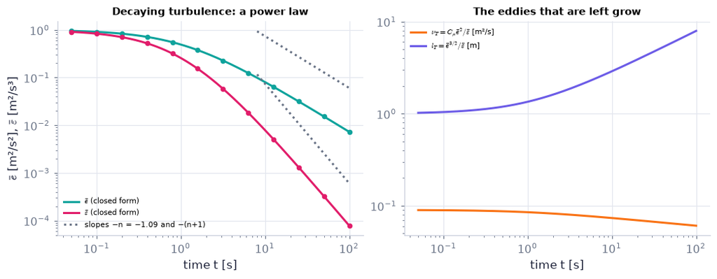

```python
t_ax = np.geomspace(0.05, 100.0, 200)                         # times [s]
e_c, eps_c, n_c, t0_c = ch12.k_epsilon_decay(1.0, 1.0, t_ax)  # closed form
t_iv = np.geomspace(0.05, 100.0, 12)                          # a few times for the numerical cross-check
e_iv, eps_iv, _, _ = ch12.k_epsilon_decay(1.0, 1.0, t_iv, method="ivp")   # the same by solve_ivp
fig, (a1, a2) = plt.subplots(1, 2, figsize=(9.4, 3.6))   # a new figure and its panel(s); figsize in inches
a1.loglog(t_ax, e_c, color=C_FLUC, label="$\\bar e$ (closed form)"); a1.loglog(t_iv, e_iv, "o", ms=4, color=C_FLUC)
a1.loglog(t_ax, eps_c, color=C_VISC, label="$\\bar\\varepsilon$ (closed form)"); a1.loglog(t_iv, eps_iv, "o", ms=4, color=C_VISC)
a1.loglog(t_ax[t_ax > 8], 9*t_ax[t_ax > 8]**(-n_c), ":", color=C_REF, label=f"slopes −n = −{n_c:.2f} and −(n+1)")
a1.loglog(t_ax[t_ax > 8], 9*t_ax[t_ax > 8]**(-n_c - 1), ":", color=C_REF)
a1.set(xlabel="time t [s]", ylabel="$\\bar e$ [m²/s²], $\\bar\\varepsilon$ [m²/s³]", title="Decaying turbulence: a power law")   # axis labels (with units), title and fixed ranges of this panel
a1.legend(fontsize=7)   # the legend names every curve
a2.loglog(t_ax, ch12.k_epsilon_eddy_viscosity(e_c, eps_c), color=C_RS, label="$\\nu_T=C_\\mu\\bar e^2/\\bar\\varepsilon$ [m²/s]")
a2.loglog(t_ax, ch12.k_epsilon_length_scale(e_c, eps_c), color=C_MEAN, label="$l_T=\\bar e^{3/2}/\\bar\\varepsilon$ [m]")
a2.set(xlabel="time t [s]", title="The eddies that are left grow")   # axis labels (with units), title and fixed ranges of this panel
a2.legend(fontsize=7)   # the legend names every curve
plt.show()   # display the figure
```

**What you see.** Left: on log–log axes $\bar e$ (teal) and $\bar\varepsilon$ (rose) bend over near $t\approx t_0=1.09$ s and then fall along straight lines of slopes −1.09 and −2.09 (dotted guides); the dots (`solve_ivp`) sit on the lines (closed form). Right: the eddy viscosity falls slowly while the length scale grows.

**How to read it.** A straight line of slope −1.09: one constant, one measurable exponent. This is how $C_{\varepsilon2}$ was fixed — by the decay of turbulence behind a grid in a wind tunnel.

**What would change if…** …$C_{\varepsilon2}=2.0$: then $n=1.0$ exactly, energy $\propto1/t$, and the eddy viscosity would stay constant during the decay.

**What would change if…** …gravity acts on density fluctuations? The budget gains a buoyancy term that can feed the turbulence or starve it (C14).

## 12.11 Turbulence in a Stratified Medium

**What is this section about?** Turbulence where density changes with height — the atmosphere and the ocean. Buoyancy can feed turbulence (heated ground at noon) or drain it (a clear calm night). Two numbers measure the contest, and one length says at what height buoyancy takes over.

> ⚠️ **Buoyancy is back.** The constant-density assumption of §12.8–12.10 ends here; we return to the Boussinesq equations of §12.5–12.7.

> 🔁 **Recap — Stratification, potential temperature and the two lapse-rate conventions `R05`** (Ch. 1 §1.10; Ch. 7; Ch. 11 §11.7). Stability is set by how the temperature gradient compares with the adiabatic one (Ch. 1), so "temperature" in this section means **potential** temperature $\theta$: stable when $d\theta/dz>0$. In terms of the thermometer temperature:

| Convention | Lapse rate | Adiabatic value | Buoyancy frequency | Stable when |
| --- | --- | --- | --- | --- |
| Kundu (computed with) | $\Gamma\equiv dT/dz$ | $\Gamma_a=-g/C_p\approx-9.8$ K/km | $N^2=g\alpha(dT/dz-\Gamma_a)$ | $dT/dz>\Gamma_a$ |
| meteorology (shown alongside) | $\Gamma_{met}\equiv-dT/dz$ | $\Gamma_d\approx+9.8$ K/km | $N^2=g\alpha(\Gamma_d-\Gamma_{met})$ | $\Gamma_{met}<\Gamma_d$ |

Negate the number, flip the inequality (Ch. 1, P48). Where these come from: Ch. 1's $N^2=-\frac g{\rho(z_o)}\big(\frac{d\rho}{dz}-\frac{d\rho_a}{dz}\big)$ (1.29) and $\frac T\theta\frac{d\theta}{dz}=\frac{dT}{dz}+\frac g{C_p}=\Gamma-\Gamma_a$ (1.32); Ch. 7's incompressible form $N^2\equiv-\frac g{\rho_0}\frac{d\bar\rho}{dz}$ (7.127).

```python
Gamma_a = STRAT.adiabatic_lapse_rate()                        # the adiabatic gradient with Kundu's sign: −g/c_p ≈ −9.76e-3 K/m
print(f"Γa = {Gamma_a*1e3:.2f} K/km (Kundu)  ⇔  Γd = {-Gamma_a*1e3:.2f} K/km (meteorology)")
for dTdz in (-6.5e-3, Gamma_a, -12e-3):                       # three in-situ gradients: standard atmosphere, adiabatic, super-adiabatic
    kundu = STRAT.lapse_rate_stability(dTdz, Gamma_a=Gamma_a, convention="kundu")          # verdict with the criterion in Kundu's convention
    met = STRAT.lapse_rate_stability(dTdz, Gamma_a=Gamma_a, convention="meteorology")      # the same layer in the meteorological convention
    print(f"dT/dz = {dTdz*1e3:6.2f} K/km | Kundu: {kundu.text} | meteorology: {met.text}")
```

```
Γa = -9.76 K/km (Kundu)  ⇔  Γd = 9.76 K/km (meteorology)
dT/dz =  -6.50 K/km | Kundu: stable ⇔ dT/dz > Γa: −6.5 > −9.8 K/km | meteorology: stable ⇔ Γ < Γa: 6.5 < 9.8 K/km
dT/dz =  -9.76 K/km | Kundu: stable ⇔ dT/dz > Γa: −9.8 = −9.8 K/km | meteorology: stable ⇔ Γ < Γa: 9.8 = 9.8 K/km
dT/dz = -12.00 K/km | Kundu: stable ⇔ dT/dz > Γa: −12.0 < −9.8 K/km | meteorology: stable ⇔ Γ < Γa: 12.0 > 9.8 K/km
```

**What does the code above do?**

1. `STRAT.adiabatic_lapse_rate()` (Ch. 1) returns $\Gamma_a=-g/C_p$ with Kundu's sign; we never type −0.0098 by hand.
2. `STRAT.lapse_rate_stability` writes the criterion out with the numbers, in either convention. Each printed text **begins with the criterion for stability** ("stable ⇔ …") and then shows the actual comparison: `>` (stable) for the standard atmosphere, `=` (neutral) for the adiabatic gradient, `<` (unstable) for −12 K/km. ⚠️ In the meteorological line the library prints "Γ < Γa": read it as $\Gamma_{met}<\Gamma_d$ — its "Γ" is our $\Gamma_{met}\equiv-dT/dz$ and its "Γa" the positive dry-adiabatic rate $\Gamma_d\approx+9.8$ K/km. The same strings appear in the verdicts printed in C14 and C15.

### 🧩 The flux Richardson number $\mathrm{Rf}=\frac{-g\alpha\overline{wT'}}{-\overline{uw}(dU/dz)}$ (12.107), $\mathrm{Ri}\equiv\frac{N^2}{(dU/dz)^2}$ (12.108) and $\mathrm{Ri}=(\nu_T/\kappa_T)\mathrm{Rf}$ (12.109) `C14`

*The question:* When does stratification switch turbulence off?

#### The problem in plain words

On a clear night the ground cools, the air near it becomes heavy, and the wind you felt at dusk dies near the surface while it still blows at tree-top height: the turbulence that carried momentum down has been suppressed. In the ocean the same contest decides how much heat is mixed below the thermocline. A mixing scheme must decide, level by level, whether the shear can keep turbulence alive against the stratification.

#### The idea

Lifting heavy fluid and pushing light fluid down costs energy; the turbulence pays it out of what the shear supplies. **Rf = cost / income.** If the cost takes more than about a quarter of the income, dissipation takes the rest and more — the turbulence starves.

| Rf | What it means |
| --- | --- |
| $\mathrm{Rf}<0$ | heat flux upward: buoyancy *adds* energy (convective) |
| $0<\mathrm{Rf}<\approx\tfrac14$ | shear-driven turbulence, weakened by stratification |
| $\mathrm{Rf}\gtrsim\tfrac14$ | decaying: the turbulence cannot sustain itself |

Symbols: $z$ height [m], $w$ the vertical velocity fluctuation, $\overline{wT'}$ the kinematic heat flux [K m/s] (positive upward), $\overline{uw}$ the kinematic momentum flux [m²/s²], $\alpha$ the thermal expansion coefficient [1/K].

> 🔁 **Tools from earlier chapters used in this block** (one line each; the full primers are in the chapters named)
- **inequalities under a sign change** — multiplying by −1 reverses an inequality — exactly the move between the two lapse-rate conventions. *(Ch. 1, P48)*
- **necessary vs sufficient (theorem vs observation)** — sufficient: A guarantees B (Ri > ¼ everywhere ⇒ stable); necessary: no B without A, but A alone does not force B (an inflection point for inviscid instability); "stable" = σ_r ≤ 0 for **every** k, "unstable" needs **one** k. *(Ch. 11, P255)*

#### 🧮 Derivation — The reduced budget, the flux Richardson number and $\mathrm{Ri}=(\nu_T/\kappa_T)\mathrm{Rf}$ `D24` ★ (Eq. 12.107: $\mathrm{Rf}=\frac{-g\alpha\overline{wT'}}{-\overline{uw}(dU/dz)}$)

**What we want to show.** One number that says whether a stratified shear flow can keep its turbulence alive, and its link to the number one can measure from mean profiles.

**Assumptions.** Mean flow U(z) along x; statistics independent of x and y (except $\bar e$ following the flow); Boussinesq; $\bar T$, $T'$ are **potential** temperature.

**The plan.**

1. Specialise the budget to a mean flow U(z) with horizontally uniform statistics.
2. Take the ratio of the buoyancy term to the shear production.
3. Substitute the two closures.

**Tools we use** (each explained before this point): horizontal homogeneity · substitution · N² from the potential-temperature gradient (ch01, R05)

**We start from**

$$ \begin{array}{l}\text{the turbulent energy budget} \\ \frac{\partial\bar e}{\partial t}+U_j\frac{\partial\bar e}{\partial x_j}=\frac{\partial}{\partial x_j}\big(-\frac1{\rho_0}\overline{pu_j}+2\nu\overline{u_iS'_{ij}}-\frac12\overline{u_i^2u_j}\big)-2\nu\overline{S'_{ij}S'_{ij}}-\overline{u_iu_j}\frac{\partial U_i}{\partial x_j}+g\alpha\overline{u_3T'} \\ \text{(12.47) and the closures}\ \overline{u_iu_j}=\tfrac23\bar e\delta_{ij}-\nu_T(\partial U_i/\partial x_j+\partial U_j/\partial x_i)\ \text{(12.94),} \\ \overline{u_iT'}=-\kappa_T\,\partial\bar T/\partial x_i\ \text{(12.95).}\end{array} $$

**Step 1 of 8 — Specialise the left side and the transport.**

$$ \dfrac{\partial\bar e}{\partial t}+U\dfrac{\partial\bar e}{\partial x}=-\dfrac{\partial}{\partial z}\Big(\dfrac1{\rho_0}\overline{pw}+\tfrac12\overline{u_i^2w}\Big)+\dots $$

- *Why we can do this:* The mean flow is (U(z), 0, 0), so $U_j\partial/\partial x_j=U\partial/\partial x$; transport fluxes can vary only with z; viscous transport is negligible at high Re. (Triple correlation written $\tfrac12\overline{u_i^2u_j}$, as in the Start: slip #10.)
- *In words:* Energy is carried along x by the wind and redistributed vertically.

**Step 2 of 8 — Specialise the shear production.**

$$ -\overline{u_iu_j}\dfrac{\partial U_i}{\partial x_j}=-\overline{uw}\dfrac{dU}{dz} $$

- *Why we can do this:* The only non-zero mean gradient is $\partial U_1/\partial x_3=dU/dz$.
- *In words:* Production by the vertical shear of the wind.

**Step 3 of 8 — Keep buoyancy and dissipation.**

$$ \dfrac{\partial\bar e}{\partial t}+U\dfrac{\partial\bar e}{\partial x}=-\dfrac{\partial}{\partial z}\Big(\dfrac1{\rho_0}\overline{pw}+\tfrac12\overline{u_i^2w}\Big)-\overline{uw}\dfrac{dU}{dz}+g\alpha\,\overline{wT'}-\bar\varepsilon $$

- *Why we can do this:* $u_3=w$; $\bar\varepsilon\equiv2\nu\overline{S'_{ij}S'_{ij}}$. This is (12.106), $\frac{\partial\bar e}{\partial t}+U\frac{\partial\bar e}{\partial x}=-\frac{\partial}{\partial z}\Big(\frac1{\rho_0}\overline{pw}+\frac12\overline{u_i^2w}\Big)-\overline{uw}\frac{\partial U}{\partial z}+g\alpha\overline{wT'}-\bar\varepsilon$. We only rename the vertical component and the dissipation, so that the budget is written with the symbols used in a stratified layer.
- *In words:* Transport, shear production, buoyancy, dissipation.

**Step 4 of 8 — Read the signs of the two sources.**

$$ -\overline{uw}\dfrac{dU}{dz}>0;\qquad g\alpha\,\overline{wT'}\ \begin{cases}>0&\text{heat flux upward (unstable)}\\<0&\text{heat flux downward (stable)}\end{cases} $$

- *Why we can do this:* $\overline{uw}<0$ when dU/dz > 0 (C04). Stable: dθ/dz > 0, rising parcels are cold ($T'<0$ with w > 0).
- *In words:* Shear always feeds turbulence; buoyancy feeds or drains it.

**Step 5 of 8 — Take the ratio.**

$$ \mathrm{Rf}\equiv\dfrac{-g\alpha\,\overline{wT'}}{-\overline{uw}\,(dU/dz)}=\dfrac{\text{buoyant destruction}}{\text{shear production}} $$

- *Why we can do this:* Dividing two terms of one budget gives a pure number that does not depend on units or on the size of the flow. This is (12.107), $\mathrm{Rf}=\frac{-g\alpha\overline{wT'}}{-\overline{uw}(dU/dz)}$.
- *In words:* The fraction of the shear production that buoyancy takes away (negative when buoyancy adds).

**Step 6 of 8 — Model the two fluxes.**

$$ -\overline{uw}=\nu_T\dfrac{dU}{dz},\qquad\overline{wT'}=-\kappa_T\dfrac{d\bar T}{dz} $$

- *Why we can do this:* The Start's closures: $\overline{u_iu_j}=\tfrac23\bar e\delta_{ij}-\nu_T(\partial U_i/\partial x_j+\partial U_j/\partial x_i)$ (12.94) with i = 1, j = 3 and $\overline{u_iT'}=-\kappa_T\,\partial\bar T/\partial x_i$ (12.95) with i = 3: eddy viscosity $\nu_T$ and eddy diffusivity $\kappa_T$ (not the molecular κ, not von Kármán's).
- *In words:* Fluxes run down the mean gradients.

**Step 7 of 8 — Substitute into Rf.**

$$ \mathrm{Rf}=\dfrac{g\alpha\,\kappa_T\,(d\bar T/dz)}{\nu_T\,(dU/dz)^2}=\dfrac{\kappa_T}{\nu_T}\,\dfrac{g\alpha\,(d\bar T/dz)}{(dU/dz)^2} $$

- *Why we can do this:* The two minus signs in the numerator cancel.
- *In words:* The flux ratio in terms of mean gradients.

**Step 8 of 8 — Recognise the gradient Richardson number.**

$$ \mathrm{Ri}\equiv\dfrac{N^2}{(dU/dz)^2}=\dfrac{\alpha g\,(d\bar T/dz)}{(dU/dz)^2}\ \Rightarrow\ \mathrm{Ri}=\dfrac{\nu_T}{\kappa_T}\,\mathrm{Rf} $$

- *Why we can do this:* $\mathrm{Ri}\equiv N^2/(dU/dz)^2$ (12.108) with $N^2=g\alpha\,d\bar T/dz$ for potential temperature. This is (12.109), $\mathrm{Ri}=(\nu_T/\kappa_T)\mathrm{Rf}$.
- *In words:* The measurable Ri is Rf times the turbulent Prandtl number.

**Result**

$$ \mathrm{Rf}=\dfrac{-g\alpha\overline{wT'}}{-\overline{uw}(dU/dz)}\ \text{(12.107);}\ \mathrm{Ri}=(\nu_T/\kappa_T)\mathrm{Rf}\ \text{(12.109)} $$

*In words:* Rf compares what buoyancy removes with what shear supplies

**What it means.** In steady state without transport, $\bar\varepsilon=P(1-\mathrm{Rf})$: observations show turbulence cannot sustain itself when Rf exceeds about ¼ (dissipation needs the rest). **Fails when:** transport is important (the top of a convective layer), or the flow is not horizontally uniform.

**Check it.** Units — numerator (m/s²)(1/K)(K m/s) = m²/s³; denominator (m²/s²)(1/s) = m²/s³ ✓. Night example: $\overline{wT'}$ = −0.02 K m/s, $\overline{uw}$ = −0.09 m²/s², dU/dz = 0.1 s⁻¹, α = 1/300: Rf = 6.54 × 10⁻⁴/9.0 × 10⁻³ = 0.073. With the thermometer gradient dT/dz = +10 K/km: Kundu $dT/dz-\Gamma_a$ = 10 − (−9.8) = 19.8 K/km; meteorology $\Gamma_d-\Gamma_{met}$ = 9.8 − (−10) = 19.8 K/km; Ri = 0.065; $\mathrm{Pr}_T$ = 0.89 = Ri/Rf ✓. Neutral: $\overline{wT'}=0$ ⇒ Rf = 0.

📝 **Notes taught inside `D24`:** **N182 [B]** the reduced budget of a horizontally uniform stratified shear flow, $\frac{\partial\bar e}{\partial t}+U\frac{\partial\bar e}{\partial x}=-\frac{\partial}{\partial z}\big(\frac1{\rho_0}\overline{pw}+\frac12\overline{u_i^2w}\big)-\overline{uw}\frac{\partial U}{\partial z}+g\alpha\overline{wT'}-\bar\varepsilon$ (12.106) — ⚠️ slip #10: the page prints the triple correlation as $\overline{ew}$ (steps 1–3) · **N184 [B]** the link between the two Richardson numbers, $\mathrm{Ri}=(\nu_T/\kappa_T)\mathrm{Rf}$ (12.109) (steps 6–8).

> ⚠️ **Common confusion (traps in `D24`):** The sign of Rf (upward heat flux ⇒ negative); using the thermometer gradient in $\mathrm{Ri}=\alpha g(d\bar T/dz)/(dU/dz)^2$ (12.108) without subtracting $\Gamma_a$ (an isothermal layer would look neutral instead of strongly stable); confusing the observed $\mathrm{Rf}_{cr}\approx\tfrac14$ with Ch. 11's theorem Ri > ¼; three different κ's on one page.

> 🔁 **Recap — The gradient Richardson number `R06`** (Ch. 11 §11.7). Ch. 11's $\mathrm{Ri}\equiv N^2/(dU/dz)^2$ (11.66), with linear stability guaranteed if, everywhere in the flow, $\mathrm{Ri}>\tfrac14$ (11.67). Here the same number is written with temperature, $\mathrm{Ri}=\alpha g(d\bar T/dz)/(dU/dz)^2$ (12.108), with $\bar T$ the **potential** temperature. New in this chapter: `ch12.gradient_richardson_thermal` takes the thermometer (in-situ) gradient and $\Gamma_a$ (Kundu sign) and returns Ri with the verdict in both conventions.

> ⚠️ **Common confusion:** **which temperature gradient goes into Ri?** In $\mathrm{Ri}=N^2/(dU/dz)^2$ (12.108) the stratification is $N^2=g\alpha(dT/dz-\Gamma_a)$ — the in-situ gradient **minus the adiabatic one** (Kundu: $\Gamma_a\approx-9.8$ K/km; meteorology: $N^2=g\alpha(\Gamma_d-\Gamma_{met})$ with $\Gamma_d\approx+9.8$ K/km). Forgetting $\Gamma_a$ (using $dT/dz$ alone) would call the standard atmosphere, $dT/dz=-6.5$ K/km, *unstable* — it is stable: $-6.5>-9.8$ ⇔ $6.5<9.8$. That is why `ch12.gradient_richardson_thermal` has no default for `Gamma_a`: pass the adiabatic value for a thermometer gradient, and `Gamma_a=0.0` only when the gradient you pass is already a potential-temperature gradient.

📝 **Note.** **N183 [B]** **The critical flux Richardson number.** Turbulence stops being self-supporting near $\mathrm{Rf}_{cr}\approx0.25$ — an **observation**, not a theorem; a large negative Rf means convection dominates (`ch12.turbulence_regime`).

> ⚠️ **Common confusion:** two different "one quarter" statements. Ch. 11's theorem — $\mathrm{Ri}>\tfrac14$ everywhere ⇒ a *laminar* stratified shear flow is linearly stable — is sufficient and exact. The observed $\mathrm{Rf}_{cr}\approx\tfrac14$ is about *existing turbulence*; by $\mathrm{Ri}=(\nu_T/\kappa_T)\mathrm{Rf}$ (12.109) it corresponds to $\mathrm{Ri}=\mathrm{Pr}_T/4$.

📝 **Note.** **N185 [B]** **The turbulent Prandtl number** $\mathrm{Pr}_T=\nu_T/\kappa_T$ compares how well eddies mix momentum and heat. It is larger than 1 in stable conditions (internal waves, Ch. 7, carry momentum but not heat), small in unstable ones, and about 1 when neutral (the *Reynolds analogy*). ⚠️ In the book's $\mathrm{Ri}=(\nu_T/\kappa_T)\mathrm{Rf}$ (12.109) the eddy viscosity $\nu_T$ is set like an italic "v".

#### ✏️ Tiny example: a stable night

$\overline{wT'}=-0.02$ K m/s (downward), $\overline{uw}=-0.09$ m²/s² ($u_*=0.3$ m/s), $dU/dz=0.1$ s⁻¹, $\alpha=1/300$ K⁻¹, $g\approx9.81$ m/s².

1. Buoyant destruction $-g\alpha\overline{wT'}=9.81\times0.02/300=6.54\times10^{-4}$ m²/s³.
2. Shear production $-\overline{uw}\,dU/dz=0.09\times0.1=9.0\times10^{-3}$ m²/s³.
3. $\mathrm{Rf}=0.073$ — shear-driven.
4. Thermometer gradient $dT/dz=+10$ K/km (an inversion). Kundu: $d\theta/dz=dT/dz-\Gamma_a=0.010-(-0.0098)=0.0198$ K/m. Meteorology: $\Gamma_{met}=-10$ K/km, $\Gamma_d-\Gamma_{met}=9.8+10=19.8$ K/km — the same number.
5. $N^2=g\alpha\,d\theta/dz=6.47\times10^{-4}$ s⁻²; $\mathrm{Ri}=N^2/(dU/dz)^2=0.065$.
6. $\nu_T=0.09/0.1=0.9$ m²/s; $\kappa_T=0.02/0.0198=1.01$ m²/s; $\mathrm{Pr}_T=0.89$; and $\mathrm{Ri}/\mathrm{Rf}=0.065/0.073=0.89$ ✓. (These are our round numbers, chosen for easy arithmetic, not a measured case — in measured stable layers $\mathrm{Pr}_T$ is usually somewhat above 1, see N185.)

```python
Rf = ch12.flux_richardson(-0.02, -0.09, 0.1, 1/300.0)        # Eq. (12.107): mean(wT') = −0.02 K m/s, mean(uw) = −0.09 m²/s², dU/dz = 0.1 1/s
ri = ch12.gradient_richardson_thermal(0.010, 0.1, 1/300.0, Gamma_a=Gamma_a)   # Eq. (12.108) from the IN-SITU gradient +10 K/km; Γa from the Ch. 1 function
print(f"Rf = {Rf:.4f} → {ch12.turbulence_regime(Rf)};  Ri = {ri['Ri']:.4f}, N² = {ri['N2']:.2e} 1/s², dθ/dz = {ri['dthetadz']*1e3:.2f} K/km")
print("Kundu:      ", ri["verdict_kundu"])                    # the criterion, then the numbers
print("meteorology:", ri["verdict_met"])
Pr_T = ch12.turbulent_prandtl(0.9, 0.02/ri["dthetadz"])       # ν_T/κ_T with ν_T = 0.9 m²/s and κ_T = −mean(wT')/(dθ/dz)
print(f"Pr_T = {Pr_T:.3f};  Ri/Rf = {ri['Ri']/Rf:.3f};  Rf back from Ri: {ch12.flux_from_gradient_richardson(ri['Ri'], Pr_T):.4f}")
bud_s = ch12.stratified_tke_budget(10.0, 3.0, -0.09, -0.02, 8.3e-3, 1/300.0, dUdz=0.1)   # the budget of D24 at one height (ε̄ chosen to close it)
print({k: (round(float(v), 5) if not isinstance(v, str) else v) for k, v in bud_s.items()})
wrong = ch12.gradient_richardson_thermal(-6.5e-3, 0.02, 1/288.0, Gamma_a=0.0)["verdict"]     # the trap: the standard atmosphere WITHOUT the adiabatic correction
right = ch12.gradient_richardson_thermal(-6.5e-3, 0.02, 1/288.0, Gamma_a=Gamma_a)["verdict"]  # with it
print(f"standard atmosphere (dT/dz = −6.5 K/km ⇔ Γ_met = 6.5 K/km): forgetting Γa says '{wrong}', the correct verdict is '{right}'")
```

```
Rf = 0.0726 → shear-driven;  Ri = 0.0646, N² = 6.46e-04 1/s², dθ/dz = 19.76 K/km
Kundu:       stable ⇔ dT/dz > Γa: 10.0 > −9.8 K/km
meteorology: stable ⇔ Γ < Γa: −10.0 < 9.8 K/km
Pr_T = 0.889;  Ri/Rf = 0.889;  Rf back from Ri: 0.0726
{'shear_production': 0.009, 'buoyancy': -0.00065, 'dissipation': -0.0083, 'residual': -5e-05, 'Rf': 0.07264, 'regime': 'shear-driven'}
standard atmosphere (dT/dz = −6.5 K/km ⇔ Γ_met = 6.5 K/km): forgetting Γa says 'unstable', the correct verdict is 'stable'
```

**What does the code above do?**

1. `ch12.flux_richardson(wT, uw, dUdz, alpha)` is cost/income: 0.073 (the function's default $g$ is the standard 9.80665 m/s², so the last digit differs from the hand value with 9.81).
2. `ch12.gradient_richardson_thermal(dTdz, dUdz, alpha, Gamma_a=…)` takes the **thermometer** gradient; `Gamma_a` is a required keyword. It returns Ri, $N^2$, $d\theta/dz$ and the verdict in both conventions (each string starts with the criterion "stable ⇔ …"; the meteorological line's "Γ < Γa" means $\Gamma_{met}<\Gamma_d$: here $-10<9.8$ K/km).
3. `ch12.turbulent_prandtl` and `ch12.flux_from_gradient_richardson` close the loop: $\mathrm{Ri}/\mathrm{Rf}=\mathrm{Pr}_T=0.89$.
4. `ch12.stratified_tke_budget` lists the terms of the reduced budget at one height with their Rf and regime: buoyancy removes about 7 % of the shear production.
5. The last two lines are the trap of the ⚠️ box above, run on the standard atmosphere.

```python
# From scratch: Rf and Ri by hand (Kundu sign), and Ri again from the potential-temperature gradient directly
g_ = G0                                                       # standard gravity [m/s²], the library's default
Rf_mine = (-g_*(1/300.0)*(-0.02))/(-(-0.09)*0.1)              # Eq. (12.107): buoyant destruction / shear production
dth = 0.010 - Gamma_a                                         # dθ/dz = dT/dz − Γa (Kundu)  =  Γd − Γ_met (meteorology) [K/m]
Ri_mine = g_*(1/300.0)*dth/0.1**2                             # Eq. (12.108) with the potential-temperature gradient
Ri_pot = ch12.gradient_richardson_thermal(dth, 0.1, 1/300.0, Gamma_a=0.0)["Ri"]   # the library fed a POTENTIAL-temperature gradient: Γa = 0 on purpose
assert np.isclose(Rf_mine, Rf) and np.isclose(Ri_mine, ri["Ri"]) and np.isclose(Ri_pot, ri["Ri"])   # all routes agree
assert np.isclose(Ri_mine/Rf_mine, Pr_T, rtol=1e-3)           # Eq. (12.109): Ri = Pr_T Rf
print(f"Rf = {Rf_mine:.4f}, Ri = {Ri_mine:.4f}, Ri/Rf = {Ri_mine/Rf_mine:.3f}")
```

```
Rf = 0.0726, Ri = 0.0646, Ri/Rf = 0.889
```

**What does the code above do?**

Two one-line formulas reproduce the functions; feeding the library the potential-temperature gradient with `Gamma_a=0.0` (the one legitimate use of that value) gives the same Ri.

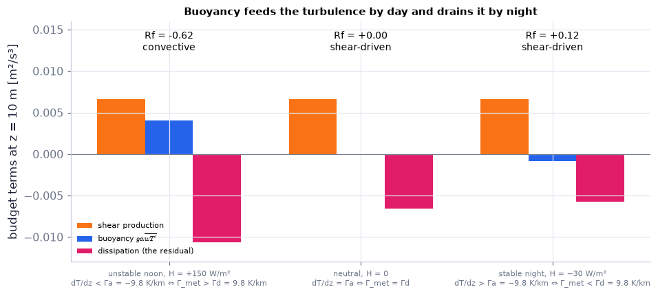

```python
u_st, z_b, alpha_b = 0.3, 10.0, 1/300.0                       # friction velocity [m/s], height [m], expansion coefficient [1/K]
P_sh = u_st**3/(KAPPA*z_b)                                    # shear production in the log layer: u*² × u*/(κ z) [m²/s³]
cases = (("unstable noon, H = +150 W/m²\ndT/dz < Γa = −9.8 K/km ⇔ Γ_met > Γd = 9.8 K/km", 150.0),
         ("neutral, H = 0\ndT/dz = Γa ⇔ Γ_met = Γd", 0.0),
         ("stable night, H = −30 W/m²\ndT/dz > Γa = −9.8 K/km ⇔ Γ_met < Γd = 9.8 K/km", -30.0))   # three surface heat fluxes, both conventions in each label
fig, ax = plt.subplots(figsize=(8.6, 3.8))   # a new figure and its panel(s); figsize in inches
for i, (name, H) in enumerate(cases):   # one group of three bars per case
    B_b = ch12.buoyant_production(H/(1.2*1005.0), alpha_b)    # g α mean(wT') with mean(wT') = H/(ρ c_p) [m²/s³]
    Rf_b = 0.0 if B_b == 0 else -B_b/P_sh                     # Eq. (12.107) (written so that the neutral case prints +0.00)
    ax.bar(i - 0.25, P_sh, 0.25, color=C_RS, label="shear production" if i == 0 else None)
    ax.bar(i, B_b, 0.25, color=C_BUOY, label="buoyancy $g\\alpha\\overline{wT'}$" if i == 0 else None)
    ax.bar(i + 0.25, -(P_sh + B_b), 0.25, color=C_VISC, label="dissipation (the residual)" if i == 0 else None)
    ax.text(i, 0.0125, f"Rf = {Rf_b:+.2f}\n{ch12.turbulence_regime(Rf_b)}", ha="center", fontsize=9)
ax.axhline(0, color=C_REF, lw=0.6)   # a thin reference line
ax.set_xticks(range(3)); ax.set_xticklabels([c[0] for c in cases], fontsize=7)   # label / range / scale of this axis
ax.set(ylabel="budget terms at z = 10 m [m²/s³]", ylim=(-0.013, 0.016), title="Buoyancy feeds the turbulence by day and drains it by night")   # axis labels (with units), title and fixed ranges of this panel
ax.legend(fontsize=7, loc="lower left")   # the legend names every curve
plt.show()   # display the figure
```

**What you see.** Three groups of bars at 10 m height. The orange bar (shear production) is the same in all three. The blue bar (buoyancy) is positive at noon — about 60 % of the shear production —, zero when neutral and slightly negative at night. The rose bar (dissipation, computed as the residual) balances the other two.

**How to read it.** Rf is minus the ratio of the blue bar to the orange one: −0.6 at noon (convective), 0, and +0.12 at night (shear-driven but weakened). Each label states the stratification in both lapse-rate conventions.

**What would change if…** …the wind dropped by half at night: production $\propto u_*^3$ falls 8-fold, Rf rises 8-fold to about 1 — far beyond ¼ — and the turbulence collapses. This is why calm clear nights are so still.

**What would change if…** …we ask at what *height* buoyancy catches up with shear? In the log layer the answer is a single length (C15).

### 🧩 The Monin–Obukhov length $L_M\equiv-u_*^3/(\kappa\alpha g\overline{wT'})$ (12.110), with $\mathrm{Rf}=z/L_M$ (12.111) `C15`

*The question:* What does the Monin–Obukhov length measure?

#### The problem in plain words

A weather or climate model knows the wind and temperature at its lowest level, some tens of metres up, and needs the stress and heat flux at the ground. The bridge is a wind profile that is logarithmic near the ground and bends with stability — and the one length that says how fast it bends is $L_M$. Every bulk surface-flux formula is built on it.

#### The idea

In the log layer the shear production falls with height like $u_*^3/(\kappa z)$, while the buoyancy term $g\alpha\overline{wT'}$ does not change with height in the surface layer (the fluxes are constant there). They are equal in size at the height $z=\lvert L_M\rvert$. Below it the wind makes the turbulence; above it buoyancy makes it (unstable) or kills it (stable). Sign: $L_M<0$ unstable (heat flux up), $L_M>0$ stable, $L_M=\pm\infty$ neutral.

📝 **Note.** **N187 [B]** **Forced and free convection.** On an unstable day the layer below $\lvert L_M\rvert$ is *forced convection* (turbulence made by the wind shear, heat carried along); above it is *free convection*, with thermal plumes that do not care about the wind.

```
['forced convection', 'free convection', 'forced convection', 'stable', 'neutral']
```

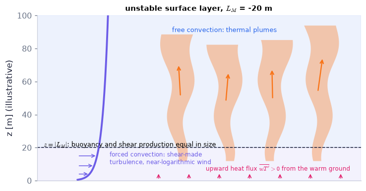

```python
fig, ax = plt.subplots(figsize=(6.6, 3.4))   # a new figure and its panel(s); figsize in inches
surface_layer_sketch(ax, L_M=-20.0, top=100.0, seed=1)        # drawing: an unstable surface layer with |L_M| = 20 m
print([ch12.surface_layer_regime(z_, L_) for z_, L_ in ((2.0, -20.0), (100.0, -20.0), (10.0, 100.0), (300.0, 100.0), (10.0, np.inf))])   # the layer a height lies in
```

**What you see.** A surface layer on an unstable day: small shear-made eddies below a dashed line at $z=\lvert L_M\rvert=20$ m, tall buoyant plumes above it.

**How to read it.** $\lvert L_M\rvert$ is the height at which buoyancy takes over from shear. The printed list is `ch12.surface_layer_regime(z, L_M)` for five (height, $L_M$) pairs: forced convection, free convection, forced convection, stable, neutral. Note that it says "forced convection" for any height well below $\lvert L_M\rvert$ **whatever the sign** of $L_M$ — the layer there is shear-driven; whether the stratification is stable or unstable must be read from the sign of $L_M$ (or from the `verdict` keys of `ch12.surface_layer_state`).

**What would change if…** …the heat flux were weaker or the wind stronger: $\lvert L_M\rvert\propto u_*^3/\overline{wT'}$ grows and the shear-driven layer deepens — on a windy overcast day it fills the whole boundary layer.

> 📎 **Primer — the stability parameter ζ = z/L and integrating a flux–profile relation.** `P304` · Surface-layer schemes write the dimensionless shear $\phi_m=(\kappa z/u_*)\,dU/dz$ as a function of $\zeta=z/L$ alone: 1 when neutral, $>1$ stable, $<1$ unstable (*Monin–Obukhov similarity*). Integrating $dU/dz=(u_*/\kappa z)\phi_m$ from the roughness height $z_0$ gives the wind profile. With $\phi_m=1+5\zeta$ the integral is $\ln(z/z_0)+5(z-z_0)/L$.

```python
z0_, L_ = 0.03, 83.0                              # roughness length [m] and a (stable) Monin–Obukhov length [m]
num = quad(lambda z: (1 + 5*z/L_)/z, z0_, 10.0)[0]    # ∫ φ_m dz/z from z0 to 10 m, done numerically
print(round(num, 4), round(np.log(10.0/z0_) + 5*(10.0 - z0_)/L_, 4))   # the closed form gives the same number
```

```
6.4097 6.4097
```

#### 🧮 Derivation — $\mathrm{Rf}=z/L_M$ and the log-linear wind profile $U=\tfrac{u_*}\kappa\big[\ln\tfrac z{z_0}+5\tfrac z{L_M}\big]$ `D25` ★ (Eq. 12.111: $\mathrm{Rf}=z/L_M$)

**What we want to show.** Show that in the surface layer the flux Richardson number is simply height divided by one length, and get the wind profile that bends with stability.

**Assumptions.** Surface (constant-flux) layer: $-\overline{uw}=u_*^2$ and $\overline{wT'}$ independent of height; z well above $z_0$; mild stratification for the linear correction.

**The plan.**

1. Put the log-layer values of stress and shear into Rf.
2. Recognise L_M.
3. Correct the shear for stability to first order.
4. Integrate from the roughness height.

**Tools we use** (each explained before this point): the log law of C11 · substitution · the stability parameter ζ = z/L and the flux–profile relation (P304, primer above) · $\int(1/z)\,dz=\ln z$

**We start from**

$$ \mathrm{Rf}=\dfrac{-g\alpha\overline{wT'}}{-\overline{uw}(dU/dz)}\ \text{(12.107) and}\ L_M\equiv-\dfrac{u_*^3}{\kappa\,\alpha\,g\,\overline{wT'}}\ \text{(12.110).} $$

**Step 1 of 7 — Take the stress and shear of the neutral log layer.**

$$ -\overline{uw}=u_*^2,\qquad\dfrac{dU}{dz}=\dfrac{u_*}{\kappa z} $$

- *Why we can do this:* Close to the ground the stress is the surface stress ($u_*^2\equiv\tau_0/\rho$ (12.81)) and differentiating $U^+=\tfrac1\kappa\ln y^++B$ (12.88) gives the shear. Here κ is von Kármán's constant.
- *In words:* Near the ground: constant stress, shear ∝ 1/z.

**Step 2 of 7 — Put them into Rf.**

$$ \mathrm{Rf}=\dfrac{-g\alpha\,\overline{wT'}}{u_*^2\cdot u_*/(\kappa z)}=-\dfrac{\kappa\,\alpha\,g\,\overline{wT'}}{u_*^3}\,z $$

- *Why we can do this:* Substitution in $\mathrm{Rf}=\dfrac{-g\alpha\overline{wT'}}{-\overline{uw}(dU/dz)}$ (12.107). We want Rf as a function of height alone, so every flux is replaced by its surface-layer value.
- *In words:* Rf grows in proportion to height: shear production fades as 1/z, the heat flux does not.

**Step 3 of 7 — Recognise the Monin–Obukhov length.**

$$ \mathrm{Rf}=\dfrac{z}{L_M},\qquad L_M\equiv-\dfrac{u_*^3}{\kappa\,\alpha\,g\,\overline{wT'}} $$

- *Why we can do this:* The factor multiplying z is exactly $1/L_M$ by $L_M\equiv-u_*^3/(\kappa\alpha g\overline{wT'})$ (12.110); the minus sign makes $L_M>0$ when the heat flux is downward (stable). This is (12.111), $\mathrm{Rf}=z/L_M$.
- *In words:* $L_M$ is the height at which buoyancy would equal shear production.

**Step 4 of 7 — Correct the shear for stability.**

$$ \phi_m\equiv\dfrac{\kappa z}{u_*}\dfrac{dU}{dz}=1+\beta\,\dfrac{z}{L_M} $$

- *Why we can do this:* Dimensional analysis: the dimensionless shear can depend only on ζ = z/L_M; it is 1 when neutral; for small ζ keep the first term of its Taylor series. β is empirical (≈ 5). (Ours.)
- *In words:* Stable air needs more shear to carry the same stress.

**Step 5 of 7 — Solve for the shear.**

$$ \dfrac{dU}{dz}=\dfrac{u_*}{\kappa}\Big(\dfrac1z+\dfrac{\beta}{L_M}\Big) $$

- *Why we can do this:* Multiply step 4 by $u_*/(\kappa z)$.
- *In words:* The neutral shear plus a height-independent extra.

**Step 6 of 7 — Integrate from the roughness height.**

$$ U(z)=\dfrac{u_*}{\kappa}\Big[\ln\dfrac{z}{z_0}+\beta\,\dfrac{z-z_0}{L_M}\Big] $$

- *Why we can do this:* U = 0 at $z=z_0$, as in the rough-wall law $U^+=\tfrac1\kappa\ln(y/y_0)$ (12.93); $\int dz/z=\ln z$, $\int dz=z$.
- *In words:* A logarithm plus a straight line.

**Step 7 of 7 — Neglect $z_0$ against z and set β = 5.**

$$ U=\dfrac{u_*}{\kappa}\Big[\ln\dfrac{z}{z_0}+5\,\dfrac{z}{L_M}\Big] $$

- *Why we can do this:* $z_0$ is centimetres, z metres. This is the book's log-linear profile (unnumbered, p. 598).
- *In words:* Stable: more wind aloft than the logarithm; neutral ($L_M\to\infty$): the logarithm.

**Result**

$$ \mathrm{Rf}=z/L_M\ \text{(12.111);}\ U=\tfrac{u_*}\kappa[\ln(z/z_0)+5z/L_M] $$

*In words:* Below ∣L_M∣ the wind makes the turbulence; above it buoyancy makes or kills it

**What it means.** Every bulk surface-flux scheme iterates on this profile (and its temperature twin) to get u_* and H from model-level wind and temperature. **Fails when:** z ≥ ∣L_M∣/5 on the unstable side — there the log-linear shear 1 + 5z/L_M reaches zero, and beyond it the linear form even gives negative winds; use a commonly used form (often called Businger–Dyer), $\phi_m=(1-16\zeta)^{-1/4}$, there — and for very stable layers (ζ ≳ 1), where turbulence is intermittent.

**Check it.** Units — $u_*^3/(g\alpha\overline{wT'})$: (m³/s³)/((m/s²)(1/K)(K m/s)) = m ✓. Night: u_* = 0.3 m/s, H = −30 W/m² ⇒ $\overline{wT'}$ = −0.0249 K m/s, T = 300 K: L_M = +83 m; Rf(10 m) = 0.12; U(10 m) = 4.81 m/s (neutral 4.36). Day, H = +150 W/m²: L_M = −17 m. Neutral: H = 0 ⇒ L_M = ∞ ⇒ the rough-wall log law ✓.

📝 **Notes taught inside `D25`:** **N186 [B]** in the surface layer the flux Richardson number is a height in units of $L_M$, $\mathrm{Rf}=z/L_M$ (12.111) (steps 1–3) · **N188 [B]** the log-linear wind profile $U=\frac{u_*}\kappa\big[\ln\frac z{z_o}+5\frac z{L_M}\big]$ — the book's coefficient 5, the stable-side $\phi_m=1+5z/L_M$ (steps 4–7).

> ⚠️ **slip #17 — the book prints**, in the sentence that leads to this result, "using $\overline{uw}=u_*^2$" **; the correct form is** $-\overline{uw}=u_*^2$ (step 1): the momentum flux is downward, $\overline{uw}<0$. With the printed sign the definition $\mathrm{Rf}=\frac{-g\alpha\overline{wT'}}{-\overline{uw}(dU/dz)}$ (12.107) would give $-z/L_M$ instead of $\mathrm{Rf}=z/L_M$ (12.111). The cell below shows both.

> ⚠️ **Common confusion (traps in `D25`):** The sign of L_M; κ is von Kármán's constant here although the temperature-variance budget on the next page (N190 in C15) uses κ for the thermal diffusivity (our $\kappa_{th}$); α = 1/T needs T in kelvin; H in W/m² must be divided by ρc_p.

```python
us17, wT17, z17 = 0.3, -0.02, 10.0                            # friction velocity [m/s], a downward heat flux [K m/s], height [m]
L17 = ch12.monin_obukhov_length(us17, wT17, T=300.0, kappa=KAPPA)   # Eq. (12.110) [m]
shear17 = us17/(KAPPA*z17)                                    # the neutral log-layer shear dU/dz = u*/(κ z) [1/s]
Rf_right = ch12.flux_richardson(wT17, -us17**2, shear17, 1/300.0)    # Eq. (12.107) with mean(uw) = −u*²  (the correct sign)
Rf_printed = ch12.flux_richardson(wT17, +us17**2, shear17, 1/300.0)  # the same with mean(uw) = +u*²  (the sign as printed: slip #17)
print(f"z/L_M = {ch12.flux_richardson_surface_layer(z17, L17):+.4f};  Rf with mean(uw) = −u*²: {Rf_right:+.4f};  with the printed +u*²: {Rf_printed:+.4f}")
assert np.isclose(Rf_right, z17/L17) and np.isclose(Rf_printed, -z17/L17)   # the correct sign gives z/L_M, the printed one −z/L_M
```

```
z/L_M = +0.0993;  Rf with mean(uw) = −u*²: +0.0993;  with the printed +u*²: -0.0993
```

**What does the code above do?**

`ch12.flux_richardson(wT, uw, dUdz, alpha)` evaluated with the log-layer shear: with $\overline{uw}=-u_*^2$ it returns exactly $z/L_M$ (the same number as `ch12.flux_richardson_surface_layer`); with the printed $+u_*^2$ it returns $-z/L_M$ — a stable night would be reported as unstable.

#### ✏️ Tiny example: a clear night over grass

$u_*=0.3$ m/s, $H=-30$ W/m² (downward), $\rho=1.2$ kg/m³, $c_p=1005$ J/(kg K), $T=300$ K, $\kappa=0.4$ (the round value customary in micrometeorology; 0.41 elsewhere in this chapter — a 2.5 % difference in every wind speed here), $z_0=0.03$ m.

1. $\overline{wT'}=H/(\rho c_p)=-30/1206=-0.0249$ K m/s (primer P296).
2. $\alpha=1/T=3.33\times10^{-3}$ K⁻¹.
3. $L_M=-u_*^3/(\kappa\alpha g\overline{wT'})=-0.027/(0.4\times3.33\times10^{-3}\times9.81\times(-0.0249))=+83$ m (positive: stable).
4. Rf at 10 m $=z/L_M=0.12$.
5. Rf reaches ¼ at $z=L_M/4=21$ m: above that the turbulence cannot sustain itself.
6. Wind at 10 m: $(0.3/0.4)[\ln(333)+5\times10/83]=0.75\times(5.81+0.60)=4.81$ m/s, against 4.36 m/s for a neutral profile — more shear for the same stress.

```python
L_night = ch12.monin_obukhov_from_fluxes(tau=1.2*0.3**2, H=-30.0, rho=1.2, cp=1005.0, T=300.0, kappa=0.4)   # Eq. (12.110) from the stress [Pa] and heat flux [W/m²]
print(f"L_M = {L_night:.1f} m;  Rf(10 m) = {ch12.flux_richardson_surface_layer(10.0, L_night):.3f};  "   # the night-time Monin–Obukhov length, Rf at 10 m …
      f"U(10 m) = {WT.surface_layer_wind(10.0, 0.3, 0.03, L_night, kappa=0.4):.2f} m/s (neutral: {WT.surface_layer_wind(10.0, 0.3, 0.03, kappa=0.4):.2f})")   # … and the wind at 10 m with and without the stability correction
st_n = ch12.surface_layer_state(0.3, -30.0, 300.0, 0.03, 10.0, 1.2, 1005.0, 0.4)   # everything at once: u*, H, T, z0, z, ρ, c_p, κ
print(f"regime: {st_n['regime']};  Rf = ¼ at z = {st_n['z_crit']:.1f} m;  verdict: {st_n['verdict']}")   # regime, the height where Rf = ¼, and the stability verdict
print("Kundu:      ", st_n["verdict_kundu"]); print("meteorology:", st_n["verdict_met"])   # stability is read from the verdict keys
L_noon = ch12.monin_obukhov_from_fluxes(tau=1.2*0.3**2, H=150.0, rho=1.2, cp=1005.0, T=300.0, kappa=0.4)    # a sunny noon: H = +150 W/m²
print(f"noon: L_M = {L_noon:.1f} m (negative: unstable), Rf(10 m) = {ch12.flux_richardson_surface_layer(10.0, L_noon):.2f}")   # the same for a sunny noon: L_M negative
print("from kinematic fluxes (κ = 0.41):", [round(float(ch12.monin_obukhov_length(0.3, wT_, T=300.0, kappa=KAPPA)), 1) for wT_ in (0.1, -0.02, 0.0)], "m")   # L_M for an upward, a downward and a zero heat flux
```

```
L_M = 83.0 m;  Rf(10 m) = 0.120;  U(10 m) = 4.81 m/s (neutral: 4.36)
regime: shear-driven;  Rf = ¼ at z = 20.8 m;  verdict: stable
Kundu:       stable ⇔ dT/dz > Γa: 23.5 > −9.8 K/km
meteorology: stable ⇔ Γ < Γa: −23.5 < 9.8 K/km
noon: L_M = -16.6 m (negative: unstable), Rf(10 m) = -0.60
from kinematic fluxes (κ = 0.41): [-20.1, 100.7, inf] m
```

**What does the code above do?**

1. `ch12.monin_obukhov_from_fluxes(tau, H, rho, cp, T, kappa=)` converts the observer's fluxes (Pa, W/m²) to kinematic ones and returns $L_M=+83$ m; `ch12.flux_richardson_surface_layer` is $\mathrm{Rf}=z/L_M$ (12.111); `WT.surface_layer_wind` the log-linear profile: 4.81 m/s against 4.36 m/s neutral.
2. `ch12.surface_layer_state` returns all of it in one dictionary, including the height where Rf reaches ¼ (20.8 m) and the stability verdict in both conventions (the temperature gradient it implies is a strong inversion; in the meteorological line read the printed "Γ < Γa" as $\Gamma_{met}<\Gamma_d$).
3. At noon $L_M\approx-17$ m: unstable, and at 10 m buoyancy already supplies more than half as much energy as the shear.
4. `ch12.monin_obukhov_length(u_star, wT, T=, kappa=)` works from kinematic fluxes: −20 m (unstable), +101 m (stable), `inf` (neutral, no heat flux).

```python
# From scratch: L_M in one line and the log-linear wind at 10 m
wT_n = -30.0/(1.2*1005.0)                                     # kinematic heat flux mean(wT') = H/(ρ c_p) [K m/s]
L_mine = -0.3**3/(0.4*(1/300.0)*G0*wT_n)                      # Eq. (12.110) with α = 1/T
U_mine = 0.3/0.4*(np.log(10.0/0.03) + 5*10.0/L_mine)          # the log-linear profile at z = 10 m
assert np.isclose(L_mine, L_night) and np.isclose(U_mine, WT.surface_layer_wind(10.0, 0.3, 0.03, L_night, kappa=0.4))   # same as the library
print(f"L_M = {L_mine:.2f} m, U(10 m) = {U_mine:.3f} m/s")
```

```
L_M = 83.01 m, U(10 m) = 4.809 m/s
```

**What does the code above do?**

The definition and the profile, typed out, agree with `ch12.monin_obukhov_from_fluxes` and `WT.surface_layer_wind` (83.0 m with the standard $g$; 82.98 m with the hand value 9.81).

📝 **Note.** **N189 [B]** **Wind profiles for every stability.** On a logarithmic height axis the neutral profile is a straight line; a stable layer bends toward larger wind (more shear), an unstable one toward smaller wind (the air is well mixed).

```python
z_ax = np.geomspace(0.05, 100.0, 80)                        # heights from just above z0 = 0.03 m to 100 m
U_neut = WT.surface_layer_wind(z_ax, 0.3, 0.03, kappa=0.4)    # the neutral logarithm for u* = 0.3 m/s

def f7(invL):                                                 # profiles for one value of 1/L_M [1/m]
    L_ = np.inf if abs(invL) < 1e-9 else 1.0/invL   # the Monin–Obukhov length of this slider position (infinite when neutral)
    nan = np.full_like(z_ax, np.nan)   # an all-NaN curve: plotly draws nothing for it
    stable = WT.surface_layer_wind(z_ax, 0.3, 0.03, L_, kappa=0.4) if invL > 0 else nan                              # log-linear (book's form)
    unstable = WT.surface_layer_wind(z_ax, 0.3, 0.03, L_, kappa=0.4, unstable="businger_dyer") if invL < 0 else nan   # Businger–Dyer form
    book_uns = WT.surface_layer_wind(z_ax, 0.3, 0.03, L_, kappa=0.4) if invL < 0 else nan                            # the book's log-linear form used outside its range
    z_q = [0.25*L_]*2 if invL > 0 and 0.25*L_ < 100 else [np.nan]*2                                                   # the height where Rf = z/L_M = ¼
    return {"neutral: dT/dz = Γa ⇔ Γ_met = Γd (logarithm)": (U_neut, z_ax),   # hand the result back to the caller
            "stable, L_M > 0: dT/dz > Γa = −9.8 K/km ⇔ Γ_met < Γd = 9.8 K/km": (stable, z_ax),
            "unstable, L_M < 0: dT/dz < Γa = −9.8 K/km ⇔ Γ_met > Γd = 9.8 K/km (Businger–Dyer)": (unstable, z_ax),
            "unstable: the book's log-linear form (ends where 1 + 5 z/L_M = 0, z = |L_M|/5)": (book_uns, z_ax),
            "height where Rf = z/L_M = ¼ (stable side)": ([0.0, 12.0], z_q)}

figF7 = slider_figure(f7, "1/L_M", np.round(np.linspace(-0.1, 0.05, 16), 4), unit="1/m", xlabel="wind speed U [m/s]",
                      ylabel="height z [m]", title="Stable: more shear than neutral; unstable: less",
                      xrange=(0, 12))
figF7.update_yaxes(type="log", range=[np.log10(0.05), 2.0])   # logarithmic height axis
figF7.show()   # display the interactive figure (the slider works on the web page too)
```

[interactive chart not shown]

**What does the code above do?**

1. `f7(invL)` returns the neutral logarithm and, depending on the sign of $1/L_M$, the stable (log-linear) or unstable profile. For the unstable side we use a commonly used form (often called Businger–Dyer; `unstable="businger_dyer"`) and show the book's log-linear form with it. The log-linear shear $1+5z/L_M$ reaches zero at $z=\lvert L_M\rvert/5$; above that height it has no meaning and the function returns no value (NaN).
2. Each trace name carries the stratification in **both** lapse-rate conventions; the horizontal marker is the height $z=L_M/4$ where $\mathrm{Rf}=\tfrac14$.

**What you see.** Drag $1/L_M$ from negative (unstable) through zero to positive (stable). At zero only the straight neutral line is there. To the right the profile bends toward larger wind aloft and the ¼-marker comes down from the top; to the left it bends toward smaller wind, and the book's log-linear form simply stops at $z=\lvert L_M\rvert/5$.

**How to read it.** Stable: the same surface stress needs **more** shear, so the 10 m wind is stronger for a given $u_*$ — or, the way a model uses it, a given 10 m wind produces **less** stress and less heat flux. Unstable: the reverse.

**What would change if…** …the surface were rougher (larger $z_0$): every curve shifts to smaller wind by the same amount at all heights; the *bending* depends only on $z/L_M$.

> ▶️ **Live cell.** The widget below needs a running Python kernel. On the web page it is frozen — open this notebook in Colab (button at the top) or run it locally to drag the sliders.

```python
def surface_live(u_star=0.3, H=-30.0, log_z0=-1.5):           # free friction velocity [m/s], surface heat flux [W/m²], log10 of roughness length [m]
    z0_ = 10.0**log_z0
    L_ = ch12.monin_obukhov_from_fluxes(tau=1.2*u_star**2, H=H, rho=1.2, cp=1005.0, T=300.0, kappa=0.4)   # Eq. (12.110)
    zz = np.geomspace(1.5*z0_, 100.0, 100)                    # heights [m]
    fig, ax = plt.subplots(figsize=(6.0, 3.4))   # a new figure and its panel(s); figsize in inches
    ax.semilogy(WT.surface_layer_wind(zz, u_star, z0_, kappa=0.4), zz, "--", color=C_REF, label="neutral")
    ax.semilogy(WT.surface_layer_wind(zz, u_star, z0_, L_, kappa=0.4, unstable="businger_dyer"), zz, color=C_BUOY, label=f"L_M = {L_:.0f} m")
    name = "stable: dT/dz > Γa ⇔ Γ_met < Γd" if L_ > 0 else "unstable: dT/dz < Γa ⇔ Γ_met > Γd"   # both conventions in the title
    ax.set(xlabel="U [m/s]", ylabel="z [m]", title=f"{name};  Rf(10 m) = {10.0/L_:+.2f}")   # axis labels (with units), title and fixed ranges of this panel
    ax.legend(fontsize=8)   # the legend names every curve
    plt.show()   # display the figure

live(surface_live, u_star=(0.05, 1.0, 0.05), H=(-80.0, 400.0, 10.0), log_z0=(-4.0, 0.0, 0.25))   # sliders (kernel only)
```

▶️ **Live cell.** These sliders need a running Python kernel, so they are frozen on this page. Press **Open in Colab** at the top (or run the notebook locally) to use them.

**What does the code above do?**

The same profile with three free sliders (it needs a running kernel; the slider figure above is its web-page twin). Lower $u_*$ on a night with $H<0$ and watch $\mathrm{Rf}(10\text{ m})$ climb past ¼.

📝 **Note.** **N190 [B]** **A budget for temperature fluctuations.** The recipe of D10 with $T'$ in place of $u_i$ gives the budget of the temperature variance:

$$\frac{\partial}{\partial t}\Big(\frac12\overline{T'^2}\Big)+U\frac{\partial}{\partial x}\Big(\frac12\overline{T'^2}\Big)=-\overline{wT'}\frac{d\bar T}{dz}-\frac{\partial}{\partial z}\Big(\frac12\overline{T'^2w}-\kappa\frac{\partial}{\partial z}\Big(\frac12\overline{T'^2}\Big)\Big)-\bar\varepsilon_T,\qquad\bar\varepsilon_T=\kappa\overline{(\partial T'/\partial x_j)^2}\qquad\text{(12.112)}$$

production by the heat flux acting on the mean gradient, transport, and the "thermal dissipation" $\bar\varepsilon_T$ [K²/s] (here $\kappa$ is the thermal diffusivity, our $\kappa_{th}$).

> ⚠️ **slip #15 — the book prints** the molecular transport as $\kappa\,\partial\overline{T'^2}/\partial z$ **; the correct form is** $\kappa\,\partial(\tfrac12\overline{T'^2})/\partial z$ — the factor ½ belongs to every term.

📝 **Note.** **N191 [B]** **The temperature spectrum** $S_T(K)$ distributes the temperature variance over wavenumbers: $\overline{T'^2}\equiv\int_0^\infty S_T(K)\,dK$.

📝 **Note.** **N192 [B]** **The Obukhov–Corrsin law.** D12's dimensional argument with temperature as an extra dimension: in the inertial range the temperature spectrum can depend only on $\bar\varepsilon_T$, $\bar\varepsilon$ and $K$.

$$ S_T\propto\bar\varepsilon_T\bar\varepsilon^{-1/3}K^{-5/3}\quad\text{for}\quad2\pi/L\ll K\ll2\pi/\eta \qquad \text{(12.113)} $$

📝 **Note.** **N193 [B]** **The Batchelor scale.** When heat diffuses more slowly than momentum ($\nu/\kappa_{th}\gg1$: sea water has a Prandtl number near 7) temperature keeps finer structure than velocity, down to $\eta_T=\eta(\kappa_{th}/\nu)^{1/2}$.

📝 **Note.** **N194 [B]** **Between the two scales** the smallest eddies only stretch the temperature field, and its spectrum flattens.

$$ S_T\propto K^{-1}\quad\text{for}\quad2\pi/\eta\ll K\ll2\pi/\eta_T \qquad \text{(12.114)} $$

```python
tv = ch12.temperature_variance_sympy()                        # sympy derives the temperature-variance budget (cached)
print("derived budget = corrected form:", tv["check"], "| = the form as printed:", tv["printed_check"])   # True, False (slip #15)
z_t = np.linspace(1.0, 50.0, 50)                              # heights [m]
tb = ch12.temperature_variance_budget(z_t, 300.0 + 0.02*z_t, np.full(50, -0.02), np.full(50, 4.0e-4))   # dθ/dz = 0.02 K/m, mean(wT') = −0.02 K m/s, ε̄_T = 4e-4 K²/s
print(f"production −mean(wT') dθ/dz = {tb['production'][0]:.1e} K²/s (> 0: the flux runs down the gradient);  dissipation {tb['dissipation'][0]:.1e} K²/s")
print("exponents of S_T ∝ ε̄_T^a ε̄^b K^c:", ch12.scalar_spectrum_exponents())   # 1, −1/3, −5/3
print(f"sea water (ν = 1e-6, κ_th = 1.4e-7 m²/s, ε̄ = 1e-6 m²/s³): η = {ch12.kolmogorov_scales(1e-6, 1e-6)[0]*1e3:.2f} mm, η_T = {ch12.batchelor_scale(1e-6, 1.4e-7, 1e-6)*1e3:.3f} mm")
```

```
derived budget = corrected form: True | = the form as printed: False
production −mean(wT') dθ/dz = 4.0e-04 K²/s (> 0: the flux runs down the gradient);  dissipation -4.0e-04 K²/s
exponents of S_T ∝ ε̄_T^a ε̄^b K^c: {'eps_T': Fraction(1, 1), 'eps': Fraction(-1, 3), 'K': Fraction(-5, 3)}
sea water (ν = 1e-6, κ_th = 1.4e-7 m²/s, ε̄ = 1e-6 m²/s³): η = 1.00 mm, η_T = 0.374 mm
```

**What does the code above do?**

1. `ch12.temperature_variance_sympy()` confirms the budget with the ½ and shows that the printed form (without it) does not follow.
2. `ch12.temperature_variance_budget(z, T_mean, wT, eps_T)`: production is positive whenever the heat flux runs down the mean gradient, as here on a stable night; dissipation is returned as $-\bar\varepsilon_T$.
3. `ch12.scalar_spectrum_exponents()` solves the dimensional problem of **N192** in exact fractions.
4. `ch12.batchelor_scale(nu, kappa_th, eps)`: with $\eta=1$ mm in sea water the temperature field has structure down to 0.37 mm.

📝 **Note.** **N195 [B]** **Velocity and temperature spectra side by side** (our model curves for sea water).

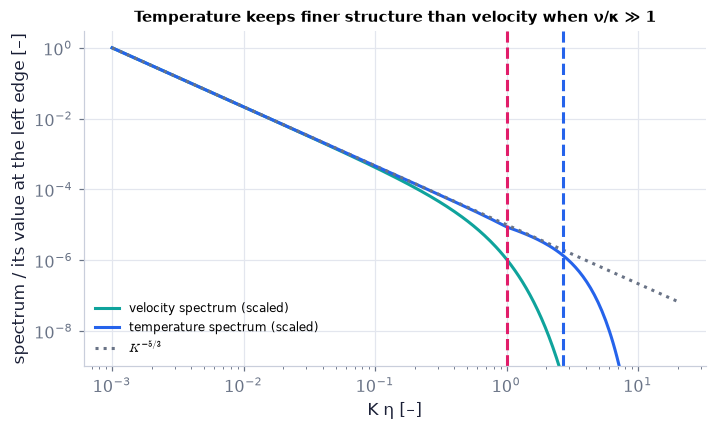

```python
nu_sw, kth_sw, eps_sw = 1.0e-6, 1.4e-7, 1.0e-6                # sea water: viscosity, thermal diffusivity [m²/s]; dissipation rate [m²/s³]
eta_sw = ch12.kolmogorov_scales(nu_sw, eps_sw)[0]             # Kolmogorov length [m]
K_sw = np.logspace(0, 4.3, 300)                               # wavenumbers [rad/m]
E_sw = ch12.model_spectrum(K_sw, eps_sw, nu_sw, kind="pao")   # velocity spectrum (model of C08)
S_T = ch12.scalar_spectrum(K_sw, eps_sw, 1.0e-8, nu_sw, kth_sw, cutoff=True)   # temperature spectrum with ε̄_T = 1e-8 K²/s (illustrative)
fig, ax = plt.subplots(figsize=(6.4, 3.8))   # a new figure and its panel(s); figsize in inches
ax.loglog(K_sw*eta_sw, E_sw/E_sw[0], color=C_FLUC, label="velocity spectrum (scaled)")
ax.loglog(K_sw*eta_sw, S_T/S_T[0], color=C_BUOY, label="temperature spectrum (scaled)")
ax.loglog(K_sw*eta_sw, (K_sw/K_sw[0])**(-5/3), ":", color=C_REF, label="$K^{-5/3}$")
ax.axvline(1.0, color=C_VISC, ls="--"); ax.axvline(eta_sw/ch12.batchelor_scale(nu_sw, kth_sw, eps_sw), color=C_BUOY, ls="--")   # a thin reference line
ax.set(xlabel="K η [–]", ylabel="spectrum / its value at the left edge [–]", ylim=(1e-9, 3), title="Temperature keeps finer structure than velocity when ν/κ ≫ 1")   # axis labels (with units), title and fixed ranges of this panel
ax.legend(fontsize=8)   # the legend names every curve
plt.show()   # display the figure
```

**What you see.** Two curves that follow the dotted −5/3 line together up to $K\eta\approx1$ (rose dashed line). There the teal velocity spectrum falls off steeply, while the blue temperature spectrum turns to the flatter slope −1 and continues to the Batchelor scale (blue dashed line) before it too is cut off.

**How to read it.** Velocity fluctuations are smoothed out at $\eta$; temperature fluctuations survive to $\eta_T<\eta$ because heat diffuses about seven times more slowly than momentum in sea water. Ocean microstructure probes exploit this range to measure mixing.

**What would change if…** …this were air ($\nu/\kappa_{th}\approx0.7$): there would be no −1 range — both spectra would end near $\eta$.

#### 🎮 Interactive: When does stratification kill turbulence?

**Why interactive rather than a static figure:** dragging the surface heat flux through zero flips the sign of the Monin–Obukhov length, bends the wind profile to the other side of the neutral logarithm and moves the Rf = ¼ height up and down, while the badge states the regime in both lapse-rate conventions.

Start with the **Walkthrough**; the **Explain** tab works every number out with your settings, and the **Derivation** tab steps through the same derivation as above.

**What to try:**

- Load 'clear calm night' and lower u_*: the Rf = ¼ height drops toward the ground.
- Drag H through zero: L_M jumps from +∞ to −∞ and the profile crosses the neutral line.
- Toggle the convention: the same layer, the other inequality.
- Switch z₀ from sea to forest at the same 10 m wind.

```python
show_viz("ch12", "stratified_surface_layer")   # full-width explainer; ⤢ Full screen for more room
```

🎮 Interactive 9/10 When does stratification kill turbulence? Open alone ↗

[interactive chart not shown]

**What would change if…** …instead of momentum and heat we follow a puff of smoke released into the turbulence? C16.

## 12.12 Taylor's Theory of Turbulent Dispersion

**What is this section about?** How far turbulence carries a marked particle. One exact formula shows the cloud spreads in proportion to time at first and to the square root of time later — and that an "eddy diffusivity" is not a constant.

> 🔁 **Recap — The molecular yardstick `R07`** (Ch. 8 §8.4; Ch. 3 and Ch. 5 (Lamb–Oseen vortex)). A line vortex switched on at $t=0$ spreads by viscosity as $u_\theta=(\Gamma/2\pi r)\exp(-r^2/4\nu t)$: a Gaussian whose standard deviation per coordinate is $\sigma=\sqrt{2\nu t}$, i.e. $\sigma^2=2\nu t$. (⚠️ Ch. 3's vortex *core radius* used $4\nu t$ — a different definition of width.) Molecular diffusion always spreads like $\sqrt t$.

> 🔁 **Recap — A diffusivity from the growth of a variance `R08`** (Ch. 1 §1.5). Ch. 1's $\sigma^2=2Dt$ read backwards gives a way to *measure* a diffusivity: $\nu=\frac12\frac{d\sigma^2}{dt}$ (12.126) (`ch12.diffusivity_from_variance`). This is the starting line of the derivation D28 below.

### 🧩 Taylor's formula $\overline{X_\alpha^2}(t)=2\overline{u_\alpha^2}\,t\int_0^t\big(1-\frac\tau t\big)r_\alpha(\tau)\,d\tau$ (12.119) `C16`

*The question:* Why does a puff spread like t at first and like √t later?

#### The problem in plain words

Smoke leaves a chimney as a narrow cone that opens like a wedge, then, far downwind, widens ever more slowly. An oil slick, volcanic ash, a cloud of drifting buoys in the ocean behave the same way. The switch happens when each smoke particle has forgotten the velocity it started with.

#### The idea

```
t ≪ Λ_t : the particle still has its first velocity  → flies straight:  X ≈ u t          → X_rms = u_rms · t
t ≫ Λ_t : many independent "steps" of duration ~2Λ_t  → random walk:    X_rms = step·√n  → X_rms = u_rms √(2Λ_t t)
```

Symbols: $X_\alpha(t)$ is one coordinate of a particle's displacement from its release point [m]; $u_\alpha(t)$ the same component of **that particle's** velocity; $r_\alpha(\tau)$ its autocorrelation coefficient; $\Lambda_t$ its integral (memory) time. ⚠️ $\alpha$ is a component label here (no sum over it), not the expansion coefficient.

> 🔁 **Tools from earlier chapters used in this block** (one line each; the full primers are in the chapters named)
- **iterated integrals** — a double integral done one variable at a time, the inner one first with the outer variable held fixed. *(Ch. 2, P83, Ch. 3, P87)*
- **erf** — erf(ζ) = (2/√π)∫₀^ζ $e^{-ξ^2}$dξ rises 0 → 1, erfc = 1 − erf computed directly (no cancellation; ch04 P123); `erfinv`/`erfcinv` answer "where does the profile reach this level?" — 2 erfcinv = 3.643 is δ₉₉ in units of √(νt). *(Ch. 8, P195)*
- **differentiation under the integral sign** — with fixed limits, d/dt ∫_a^b F dx = ∫_a^b ∂F/∂t dx; moving limits add the Leibniz end terms. *(Ch. 3, P109)*

📝 **Note.** **N196 [B]** **The set-up.** We follow particles (the Lagrangian description of Ch. 3): $\mathbf X(\mathbf a,t)$ is the position at time $t$ of the particle that started at $\mathbf a$. The turbulence is stationary and homogeneous with zero mean velocity. `ch12.langevin_particles` makes such paths by integrating the Ornstein–Uhlenbeck velocity of C01 (primer P283) in time.

📝 **Note.** **N199 [B]** **The Lagrangian autocorrelation** is C02's coefficient for the velocity of one particle: $r_\alpha(\tau)\equiv\overline{u_\alpha(t)u_\alpha(t+\tau)}/\overline{u_\alpha^2}$; its integral $\Lambda_t$ is the **Lagrangian** integral time scale (not the one a fixed probe measures).

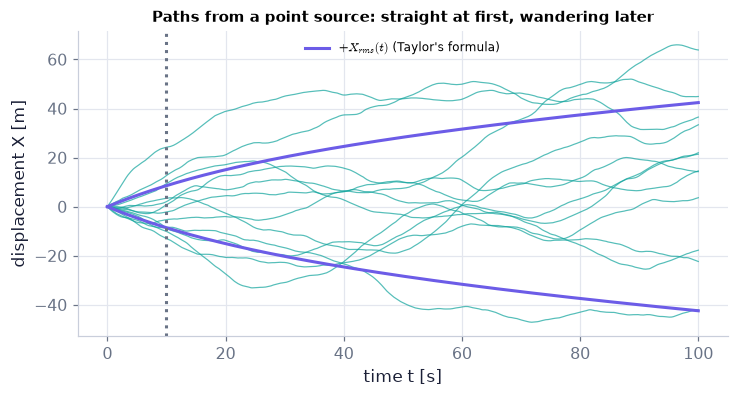

```python
t_p = np.linspace(0.0, 100.0, 1001)                           # times [s]
Xp, up = ch12.langevin_particles(12, t_p, 1.0, 10.0, seed=3)  # 12 particles: u_rms = 1 m/s, memory Λ_t = 10 s → positions [m], velocities [m/s]
fig, ax = plt.subplots(figsize=(6.6, 3.5))   # a new figure and its panel(s); figsize in inches
ax.plot(t_p, Xp.T, lw=0.8, color=C_FLUC, alpha=0.7)           # each particle's path X(t)
ax.plot(t_p, np.sqrt(ch12.taylor_dispersion_exponential(t_p, 1.0, 10.0)), color=C_MEAN, lw=2, label="$+X_{rms}(t)$ (Taylor's formula)")
ax.plot(t_p, -np.sqrt(ch12.taylor_dispersion_exponential(t_p, 1.0, 10.0)), color=C_MEAN, lw=2)
ax.axvline(10.0, color=C_REF, ls=":")   # a thin reference line
ax.set(xlabel="time t [s]", ylabel="displacement X [m]", title="Paths from a point source: straight at first, wandering later")   # axis labels (with units), title and fixed ranges of this panel
ax.legend(fontsize=8)   # the legend names every curve
plt.show()   # display the figure
```

**What you see.** Twelve teal paths leaving the origin. For the first few seconds each is nearly a straight line with its own slope; after the memory time (dotted line at 10 s) they wander. The purple envelope $\pm X_{rms}(t)$ opens like a wedge and then like a parabola on its side.

**How to read it.** Early on a particle's displacement is (its initial velocity) × (time); later it is a sum of many unrelated pieces. The envelope is what this block derives.

**What would change if…** …the memory were longer: the straight part of every path, and the wedge-shaped part of the envelope, would last longer.

> 📎 **Primer — a double integral over a triangle.** `P305` · $\int_0^tdt'\int_0^{t'}g(\tau)\,d\tau$ covers the triangle $0<\tau<t'<t$. Each value of $\tau$ is counted for every $t'$ between $\tau$ and $t$ — a strip of length $t-\tau$ — so the double integral equals the single integral $\int_0^t(t-\tau)g(\tau)\,d\tau$.

```python
from scipy.integrate import dblquad                          # a double integral over a region with variable inner limits
g = lambda tau: np.exp(-tau)                                  # any function of the inner variable
double = dblquad(lambda tau, tp: g(tau), 0, 2.0, lambda tp: 0.0, lambda tp: tp)[0]   # ∫_0^2 dt' ∫_0^t' g dτ
single = quad(lambda tau: (2.0 - tau)*g(tau), 0, 2.0)[0]      # ∫_0^2 (2 − τ) g dτ
print(round(double, 4), round(single, 4))                     # 1.1353 both ways
```

```
1.1353 1.1353
```

#### 🧮 Derivation — Taylor's formula: from the particle's velocity to the double integral and the single integral `D26` ★★ (Eq. 12.119: $\overline{X_\alpha^2}=2\overline{u_\alpha^2}\,t\int_0^t(1-\tau/t)r_\alpha\,d\tau$)

**What we want to show.** Express how far marked particles have spread, on average, purely in terms of the statistics of their velocity.

**Assumptions.** Stationary homogeneous turbulence; zero mean velocity; average over many particles (or releases).

**The plan.**

1. Differentiate the mean-square displacement.
2. Write X as the time integral of u.
3. Recognise the velocity autocorrelation.
4. Integrate in time.
5. Simplify the double integral by parts.

**Tools we use** (each explained before this point): D01's rules $\overline{\partial u/\partial t}=\partial\bar u/\partial t$ (12.6) and $\overline{\int u\,dt}=\int\bar u\,dt$ (12.7) · chain rule (P49) · substitution (P106) · even functions (P261) · a double integral over a triangle (P305, primer above) · integration by parts (P218a)

**We start from**

$$ \begin{array}{l}\text{a particle released at the origin at t = 0:}\ \dfrac{dX_\alpha}{dt}=u_\alpha(t)\ \text{, where}\ u_\alpha\ \text{is the} \\ \text{velocity of that particle (Lagrangian) along one axis α (no sum).}\end{array} $$

**Step 1 of 11 — Write the displacement as an integral of the velocity.**

$$ X_\alpha(t)=\displaystyle\int_0^tu_\alpha(t')\,dt' $$

- *Why we can do this:* Integrate $dX_\alpha/dt=u_\alpha$ from the release (X = 0 at t = 0); t′ is a dummy time.
- *In words:* Where a particle is = the sum of all its past velocities.

**Step 2 of 11 — Differentiate the square.**

$$ \dfrac{d}{dt}\big(X_\alpha^2\big)=2X_\alpha\dfrac{dX_\alpha}{dt} $$

- *Why we can do this:* Chain rule (P49). The derivative of a square is twice the quantity times its derivative; we differentiate because the rate of spreading is easier to find than the spread itself.
- *In words:* The square grows at twice displacement × velocity.

**Step 3 of 11 — Average over particles.**

$$ \dfrac{d}{dt}\big(\overline{X_\alpha^2}\big)=2\,\overline{X_\alpha\dfrac{dX_\alpha}{dt}} $$

- *Why we can do this:* The average commutes with d/dt, $\overline{\partial u^m/\partial t}=\partial\overline{u^m}/\partial t$ (12.6). This is (12.115), $\frac{d}{dt}(\overline{X_\alpha^2})=2\overline{X_\alpha\frac{dX_\alpha}{dt}}$.
- *In words:* The growth rate of the cloud's mean-square size.

**Step 4 of 11 — Replace dX/dt by the velocity.**

$$ \dfrac{d}{dt}\big(\overline{X_\alpha^2}\big)=2\,\overline{X_\alpha u_\alpha} $$

- *Why we can do this:* Definition of the particle's velocity. The rate of change of a particle's position is its velocity, which brings the velocity statistics into the equation.
- *In words:* The cloud grows when displaced particles are still moving outward.

**Step 5 of 11 — Insert step 1 and move the average inside.**

$$ \dfrac{d}{dt}\big(\overline{X_\alpha^2}\big)=2\,\overline{\Big[\displaystyle\int_0^tu_\alpha(t')dt'\Big]u_\alpha(t)}=2\displaystyle\int_0^t\overline{u_\alpha(t')\,u_\alpha(t)}\,dt' $$

- *Why we can do this:* $u_\alpha(t)$ does not depend on t′, so it goes inside the integral; the average commutes with time integration, $\overline{\int u\,dt}=\int\bar u\,dt$ (12.7). This is (12.116), $\frac{d}{dt}(\overline{X_\alpha^2})=2\overline{X_\alpha u_\alpha}=2\int_0^t\overline{u_\alpha(t')u_\alpha(t)}\,dt'$.
- *In words:* The growth rate is the accumulated correlation between present and past velocity.

**Step 6 of 11 — Use stationarity.**

$$ \overline{u_\alpha(t')\,u_\alpha(t)}=\overline{u_\alpha^2}\;r_\alpha(t-t') $$

- *Why we can do this:* In stationary turbulence $\overline{u_\alpha^2}$ is constant and the correlation depends only on the time difference: $r_\alpha(\tau)\equiv\overline{u_\alpha(t)u_\alpha(t+\tau)}/\overline{u_\alpha^2}$. The book writes $r_\alpha(t'-t)$; the two are equal because r is even (D03).
- *In words:* How well a particle remembers the velocity it had a time t − t′ ago.

**Step 7 of 11 — Change variable to the lag.**

$$ \dfrac{d}{dt}\big(\overline{X_\alpha^2}\big)=2\,\overline{u_\alpha^2}\displaystyle\int_0^tr_\alpha(\tau)\,d\tau,\qquad\tau=t-t' $$

- *Why we can do this:* dτ = −dt′; t′ = 0 → τ = t and t′ = t → τ = 0; the minus sign swaps the limits back. This is (12.117), $\frac{d}{dt}\overline{X_\alpha^2}=2\overline{u_\alpha^2}\int_0^tr_\alpha\,d\tau$.
- *In words:* The cloud grows at twice the variance times the area under the correlation up to now.

**Step 8 of 11 — Integrate in time from the release.**

$$ \overline{X_\alpha^2}(t)=2\,\overline{u_\alpha^2}\displaystyle\int_0^tdt'\int_0^{t'}r_\alpha(\tau)\,d\tau $$

- *Why we can do this:* $\overline{X_\alpha^2}=0$ at t = 0; rename the upper limit of step 7 as t′ and integrate it from 0 to t. This is (12.118), $\overline{X_\alpha^2}(t)=2\overline{u_\alpha^2}\int_0^tdt'\int_0^{t'}r_\alpha(\tau)\,d\tau$.
- *In words:* A double integral over a triangle in the (t′, τ) plane.

**Step 9 of 11 — Integrate by parts in t′.**

$$ \displaystyle\int_0^tdt'\int_0^{t'}r_\alpha\,d\tau=\Big[t'\int_0^{t'}r_\alpha(\tau)\,d\tau\Big]_{t'=0}^{t}-\int_0^tt'\,r_\alpha(t')\,dt' $$

- *Why we can do this:* $\int v'w=[vw]-\int vw'$ with v = t′ and $w=\int_0^{t'}r\,d\tau$, whose derivative is $r(t')$ (fundamental theorem, P84).
- *In words:* Trade the inner integral for a weight.

**Step 10 of 11 — Evaluate the bracket and rename.**

$$ =t\displaystyle\int_0^tr_\alpha(\tau)\,d\tau-\int_0^t\tau\,r_\alpha(\tau)\,d\tau=t\int_0^t\Big(1-\dfrac{\tau}{t}\Big)r_\alpha(\tau)\,d\tau $$

- *Why we can do this:* The bracket vanishes at t′ = 0; t′ in the last integral is a dummy, renamed τ; factor out t. Same result as counting strips of the triangle (P305).
- *In words:* Each lag τ is weighted by the fraction of the time (1 − τ/t) for which it was available.

**Step 11 of 11 — Assemble.**

$$ \overline{X_\alpha^2}(t)=2\,\overline{u_\alpha^2}\;t\displaystyle\int_0^t\Big(1-\dfrac{\tau}{t}\Big)r_\alpha(\tau)\,d\tau $$

- *Why we can do this:* Step 10 in step 8. This is (12.119), $\overline{X_\alpha^2}=2\overline{u_\alpha^2}\,t\int_0^t(1-\tau/t)r_\alpha\,d\tau$.
- *In words:* The spread of the cloud needs only the velocity variance and its autocorrelation.

**Result**

$$ \overline{X_\alpha^2}(t)=2\overline{u_\alpha^2}\,t\int_0^t\big(1-\frac\tau t\big)r_\alpha(\tau)\,d\tau\ \text{(12.119)} $$

*In words:* Dispersion is the velocity autocorrelation, integrated twice

**What it means.** No eddy diffusivity was assumed — the result is exact kinematics; all the physics is in r(τ) and its integral scale Λ_t. **Fails when:** the turbulence is not homogeneous or stationary along the particle's path (a plume rising through a boundary layer), or there is mean shear (shear dispersion is faster).

**Check it.** Units — (m²/s²)(s)(s) = m² ✓. The double integral $\overline{X_\alpha^2}(t)=2\overline{u_\alpha^2}\int_0^tdt'\int_0^{t'}r_\alpha(\tau)\,d\tau$ (12.118) and the Result agree numerically to 1e-8 for $r=e^{-\tau/\Lambda_t}$. Differentiating the Result returns $\frac{d}{dt}\overline{X_\alpha^2}=2\overline{u_\alpha^2}\int_0^tr_\alpha\,d\tau$ (12.117) ✓. Particles: 10⁴ Langevin particles reproduce it within 5 standard errors.

📝 **Notes taught inside `D26`:** **N197 [B]** $\frac{d}{dt}(\overline{X_\alpha^2})=2\overline{X_\alpha\frac{dX_\alpha}{dt}}$ (12.115) (steps 2–3) · **N198 [B]** $\frac{d}{dt}(\overline{X_\alpha^2})=2\overline{X_\alpha u_\alpha}=2\int_0^t\overline{u_\alpha(t')u_\alpha(t)}\,dt'$ (12.116) (steps 4–5) · **N200 [B]** the rate of spreading is the integral of the autocorrelation, $\frac{d}{dt}(\overline{X_\alpha^2})=2\overline{u_\alpha^2}\int_0^tr_\alpha(\tau)\,d\tau$ (12.117) (steps 6–7) · **N201 [B]** the double integral $\overline{X_\alpha^2}(t)=2\overline{u_\alpha^2}\int_0^tdt'\int_0^{t'}r_\alpha(\tau)\,d\tau$ (12.118) (step 8) · **N202 [B]** the integration by parts that turns it into the single integral of this block's title (steps 9–11).

> ⚠️ **Common confusion (traps in `D26`):** Using the Eulerian (fixed-point) correlation — the formula needs the correlation *following a particle*; summing over α (it is a label); the limits when changing t′ → τ.

#### 🧮 Derivation — The ballistic limit, the diffusive limit with its offset, and the closed form for $r=e^{-\tau/\Lambda_t}$ `D27` ★ (Eq. 12.121: $(X_\alpha)_{rms}=(u_\alpha)_{rms}t$)

**What we want to show.** Read the two simple laws — spreading like t, then like √t — out of Taylor's formula, and get one formula that covers everything in between.

**Assumptions.** As D26; r integrable with integral scale $\Lambda_t\equiv\int_0^\infty r_\alpha\,d\tau$ (Lagrangian).

**The plan.**

1. Short times: r ≈ 1.
2. Long times: the integrals reach their limits.
3. Exponential r: do the integrals exactly.

**Tools we use** (each explained before this point): limits of integrals · improper integrals (P144) · integration by parts (P218a) · sympy (P40)

**We start from**

$$ \overline{X_\alpha^2}(t)=2\overline{u_\alpha^2}\,t\displaystyle\int_0^t\Big(1-\dfrac{\tau}{t}\Big)r_\alpha(\tau)\,d\tau\ \text{(12.119).} $$

**Step 1 of 8 — For short times set r to one.**

$$ t\ll\Lambda_t:\quad r_\alpha(\tau)\approx1\ \ \text{for}\ 0\le\tau\le t $$

- *Why we can do this:* r(0) = 1 and r changes only over times of order Λ_t: the particle has not yet forgotten its velocity.
- *In words:* Perfect memory.

**Step 2 of 8 — Do the integral.**

$$ \overline{X_\alpha^2}\simeq2\,\overline{u_\alpha^2}\,t\displaystyle\int_0^t\Big(1-\dfrac{\tau}{t}\Big)d\tau=\overline{u_\alpha^2}\,t^2\ \Rightarrow\ (X_\alpha)_{rms}=(u_\alpha)_{rms}\,t $$

- *Why we can do this:* $\int_0^t(1-\tau/t)\,d\tau=t-t/2=t/2$. These are (12.120), $\overline{X_\alpha^2}\simeq\overline{u_\alpha^2}t^2$ and (12.121), $(X_\alpha)_{rms}=(u_\alpha)_{rms}t$.
- *In words:* Ballistic: each particle flies straight, so the cloud grows in proportion to time.

**Step 3 of 8 — For long times split the integral.**

$$ \overline{X_\alpha^2}=2\,\overline{u_\alpha^2}\Big[t\displaystyle\int_0^tr_\alpha\,d\tau-\int_0^t\tau\,r_\alpha\,d\tau\Big] $$

- *Why we can do this:* Multiply out (1 − τ/t); this is step 10 of D26 read backwards.
- *In words:* A part that grows with t and a correction.

**Step 4 of 8 — Let both integrals reach their limits.**

$$ t\gg\Lambda_t:\quad\displaystyle\int_0^tr_\alpha\,d\tau\to\Lambda_t,\qquad\int_0^t\tau\,r_\alpha\,d\tau\to\int_0^\infty\tau\,r_\alpha\,d\tau=\text{const} $$

- *Why we can do this:* r has decayed to zero well before t, so extending the upper limits to ∞ changes nothing (P144); the second integral converges if r decays faster than 1/τ².
- *In words:* The memory is used up.

**Step 5 of 8 — Write the long-time law.**

$$ \overline{X_\alpha^2}\simeq2\,\overline{u_\alpha^2}\,\Lambda_t\,t-2\,\overline{u_\alpha^2}\displaystyle\int_0^\infty\tau\,r_\alpha\,d\tau\ \approx\ 2\,\overline{u_\alpha^2}\,\Lambda_t\,t\ \Rightarrow\ (X_\alpha)_{rms}=(u_\alpha)_{rms}\sqrt{2\Lambda_tt} $$

- *Why we can do this:* The second term is a constant, negligible against the first as t → ∞. These are (12.122), $\overline{X_\alpha^2}=2\overline{u_\alpha^2}\Lambda_tt$ and (12.123), $(X_\alpha)_{rms}=(u_\alpha)_{rms}\sqrt{2\Lambda_tt}$.
- *In words:* Diffusive: the cloud grows like the square root of time, as in a random walk.

**Step 6 of 8 — For an exponential memory do the first integral.**

$$ r_\alpha=e^{-\tau/\Lambda_t}:\quad\displaystyle\int_0^tr_\alpha\,d\tau=\Lambda_t\big(1-e^{-t/\Lambda_t}\big) $$

- *Why we can do this:* Elementary integral; this shape is what a Langevin particle has (P283).
- *In words:* The remembered fraction of the memory time.

**Step 7 of 8 — Do the second integral.**

$$ \displaystyle\int_0^t\tau\,e^{-\tau/\Lambda_t}d\tau=\Lambda_t^2\Big[1-e^{-t/\Lambda_t}\Big(1+\dfrac{t}{\Lambda_t}\Big)\Big] $$

- *Why we can do this:* Integration by parts (P218a) with u = τ.
- *In words:* The correction, in closed form.

**Step 8 of 8 — Combine.**

$$ \overline{X_\alpha^2}=2\,\overline{u_\alpha^2}\,\Lambda_t^2\Big[\dfrac{t}{\Lambda_t}-1+e^{-t/\Lambda_t}\Big] $$

- *Why we can do this:* Step 3 with steps 6 and 7: the two $t\Lambda_te^{-t/\Lambda_t}$ terms cancel. (Ours.)
- *In words:* One formula from the wedge to the parabola.

**Result**

$$ \begin{array}{l}(X_\alpha)_{rms}=(u_\alpha)_{rms}t\ \text{for}\ t\ll\Lambda_t\ \text{(12.121);}\ (X_\alpha)_{rms}=(u_\alpha)_{rms}\sqrt{2\Lambda_tt}\ \text{for}\ t\gg\Lambda_t\ \text{(12.123);} \\ \text{exponential memory:}\ \overline{X_\alpha^2}=2\overline{u_\alpha^2}\Lambda_t^2[t/\Lambda_t-1+e^{-t/\Lambda_t}]\end{array} $$

*In words:* t first, √t later, with the change at t ≈ Λ_t

**What it means.** Near a source turbulent spreading is not diffusion at all; far from it, it is — with diffusivity $\overline{u^2}\Lambda_t$ (D28). On a plot of $\overline{X^2}$ against t the long-time line does not pass through the origin. **Fails when:** r has a long tail (anomalous diffusion), or for *relative* dispersion of particle pairs (Richardson's law instead).

**Check it.** Small t: $e^{-x}\approx1-x+x^2/2$ ⇒ $\overline{u^2}t^2$ ✓; large t: $2\overline{u^2}\Lambda_t(t-\Lambda_t)$ ✓ (offset $-2\overline{u^2}\Lambda_t^2$, since $\int_0^\infty\tau e^{-\tau/\Lambda_t}d\tau=\Lambda_t^2$). Numbers (u_rms = 1 m/s, Λ_t = 10 s): 0.967, 73.6, 1800 m² at t = 1, 10, 100 s (ballistic 1, 100, 10⁴; diffusive 20, 200, 2000). Gaussian memory $r=e^{-\tau^2/t_c^2}$: $\Lambda_t=\tfrac{\sqrt\pi}2t_c$ and $\overline{X^2}=2\overline{u^2}[\tfrac{\sqrt\pi}2t_ct\,\mathrm{erf}(t/t_c)-\tfrac{t_c^2}2(1-e^{-t^2/t_c^2})]$ (86.15 m² at t = t_c = 10 s, checked by quadrature).

📝 **Notes taught inside `D27`:** **N204 [B]** short times, $\overline{X_\alpha^2}\simeq\overline{u_\alpha^2}t^2$ (12.120) (steps 1–2) · **N205 [B]** $(X_\alpha)_{rms}=(u_\alpha)_{rms}t$ for $t\ll\Lambda_t$ (12.121) (step 2) · **N206 [B]** long times, $\overline{X_\alpha^2}=2\overline{u_\alpha^2}\Lambda_tt$ (12.122) (steps 4–5) · **N207 [B]** $(X_\alpha)_{rms}=(u_\alpha)_{rms}\sqrt{2\Lambda_tt}$ for $t\gg\Lambda_t$ (12.123) (step 5) · **N208 [B]** the closed form for an exponential memory $r=e^{-\tau/\Lambda_t}$ (steps 6–8); for a Gaussian memory $r=e^{-\tau^2/t_c^2}$ ($\Lambda_t=\tfrac{\sqrt\pi}2t_c$) the closed form is `ch12.taylor_dispersion_gaussian`.

> ⚠️ **slip #11 — the book prints** a reference to "(11.119)" in this argument **; the correct form is** this chapter's $\overline{X_\alpha^2}=2\overline{u_\alpha^2}\,t\int_0^t(1-\tau/t)r_\alpha\,d\tau$ (12.119).

> ⚠️ **Common confusion (traps in `D27`):** Using the diffusive law at t ~ Λ_t (at t = Λ_t it gives an rms displacement 65 % too large — a factor 2.7 in the mean square); forgetting that Λ_t here is Lagrangian; the book's reference "(11.119)" (slip #11) means $\overline{X_\alpha^2}=2\overline{u_\alpha^2}\,t\int_0^t(1-\tau/t)r_\alpha\,d\tau$ (12.119).

📝 **Note.** **N203 [B]** **"Small $t$" and "large $t$" on the correlation curve.** The two limits are two ways of looking at the same integral: for $t\ll\Lambda_t$ only the top of the curve, $r\approx1$, is inside the range of integration; for $t\gg\Lambda_t$ the whole curve is, and its area is $\Lambda_t$.

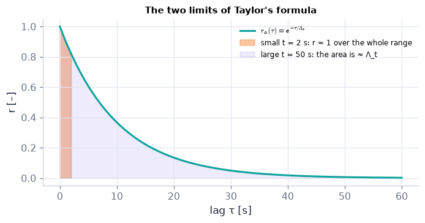

```python
tau_c16 = np.linspace(0.0, 60.0, 400)                         # lags [s]
r_c16 = np.exp(-tau_c16/10.0)                                 # the Lagrangian autocorrelation with Λ_t = 10 s
fig, ax = plt.subplots(figsize=(6.2, 3.2))   # a new figure and its panel(s); figsize in inches
ax.plot(tau_c16, r_c16, color=C_FLUC, label="$r_\\alpha(\\tau)=e^{-\\tau/\\Lambda_t}$")
ax.fill_between(tau_c16[tau_c16 <= 2], r_c16[tau_c16 <= 2], color=C_RS, alpha=0.4, label="small t = 2 s: r ≈ 1 over the whole range")
ax.fill_between(tau_c16[tau_c16 <= 50], r_c16[tau_c16 <= 50], color=C_MEAN, alpha=0.12, label="large t = 50 s: the area is ≈ Λ_t")
ax.set(xlabel="lag τ [s]", ylabel="r [–]", title="The two limits of Taylor's formula")   # axis labels (with units), title and fixed ranges of this panel
ax.legend(fontsize=8)   # the legend names every curve
plt.show()   # display the figure
```

**What you see.** The exponential correlation with two shaded ranges of integration: a narrow orange strip under the flat top (small $t$) and a wide purple area that contains nearly the whole curve (large $t$).

**How to read it.** Small $t$: $\int_0^tr\,d\tau\approx t$, so the spreading *rate* grows with time — ballistic. Large $t$: $\int_0^tr\,d\tau\approx\Lambda_t$, a constant rate — diffusive.

**What would change if…** …the correlation had a negative lobe (particles that tend to come back, as in a wave field): the area, and with it the long-time spreading, would be reduced.

#### ✏️ Tiny example: a puff in turbulence with a 10 s memory

$u_{rms}=1$ m/s, $\Lambda_t=10$ s, exponential correlation: $\overline{X^2}=2\overline{u^2}\Lambda_t^2[t/\Lambda_t-1+e^{-t/\Lambda_t}]$.

1. $t=1$ s: $200\times(0.1-1+0.90484)=0.967$ m² — the ballistic value $u^2t^2=1.000$ is 3 % high: $X_{rms}\approx0.98$ m.
2. $t=10$ s: $200\times0.3679=73.6$ m² ($X_{rms}=8.6$ m) — neither limit works (ballistic 100, diffusive 200).
3. $t=100$ s: $200\times9.000=1800$ m² ($X_{rms}=42$ m); the diffusive formula $2u^2\Lambda_tt=2000$ is 11 % high; with the constant offset $-2u^2\Lambda_t^2=-200$ it is exact.
4. Eddy diffusivity at $t=10$ s: $D_T=u^2\Lambda_t(1-e^{-1})=6.3$ m²/s; final value 10 m²/s.

```python
n_part = 2000 if FAST else 10000                              # number of particles
t_l = np.linspace(0.0, 100.0, 401 if FAST else 1001)          # times [s]
X, u = ch12.langevin_particles(n_part, t_l, 1.0, 10.0, seed=0)   # positions [m] and velocities [m/s], particles on axis 0
X2 = (X**2).mean(axis=0)                                      # mean square displacement over the particles
se = (X**2).std(axis=0)/np.sqrt(n_part)                       # its standard error
exact = ch12.taylor_dispersion_exponential(t_l, 1.0, 10.0)    # the closed form for an exponential memory
for t_ in (1.0, 10.0, 100.0):   # three times: early, at the memory time, late
    i = np.argmin(np.abs(t_l - t_))   # index of the sample nearest to this time
    print(f"t = {t_:5.0f} s ({ch12.dispersion_regime(t_, 10.0):10s}): closed form {exact[i]:8.2f} m², particles {X2[i]:8.2f} ± {se[i]:.2f} m²")
assert np.all(np.abs(X2 - exact)[1:] < 5*se[1:] + 1e-9)       # particles within 5 standard errors at every time
tt3 = np.array([1.0, 10.0, 100.0])                            # three times for the two integral forms
single = ch12.taylor_dispersion(tt3, lambda s: np.exp(-s/10.0), 1.0, form="single")   # Eq. (12.119)
double = ch12.taylor_dispersion(tt3, lambda s: np.exp(-s/10.0), 1.0, form="double")   # Eq. (12.118)
print("single-integral form:", np.round(single, 3), "| double-integral form equal:", np.allclose(single, double, rtol=1e-8))
lhs, rhs = ch12.dispersion_rate_from_particles(t_l, X, u)     # both sides of d mean(X²)/dt = 2 mean(X u), Eq. (12.116)
print(f"rate of spreading at t = 50 s: d mean(X²)/dt = {np.interp(50, t_l, lhs):.1f}, 2 mean(Xu) = {np.interp(50, t_l, rhs):.1f}, theory {ch12.taylor_dispersion_rate(50.0, lambda s: np.exp(-s/10.0), 1.0):.1f} m²/s")
print("rate at t = 1, 10, 100 s:", np.round(ch12.taylor_dispersion_rate(tt3, lambda s: np.exp(-s/10.0), 1.0), 2), "m²/s")
```

```
t =     1 s (ballistic ): closed form     0.97 m², particles     0.96 ± 0.01 m²
t =    10 s (transition): closed form    73.58 m², particles    73.37 ± 1.04 m²
t =   100 s (diffusive ): closed form  1800.01 m², particles  1801.67 ± 25.55 m²
single-integral form: [   0.967   73.576 1800.009] | double-integral form equal: True
rate of spreading at t = 50 s: d mean(X²)/dt = 19.6, 2 mean(Xu) = 19.6, theory 19.9 m²/s
rate at t = 1, 10, 100 s: [ 1.9  12.64 20.  ] m²/s
```

**What does the code above do?**

1. `ch12.langevin_particles(n, t, u_rms, Lambda_t)` returns positions and velocities; averaging $X^2$ over particles estimates $\overline{X_\alpha^2}$, with a standard error that the `assert` uses (5 standard errors, primer P281).
2. `ch12.taylor_dispersion_exponential` is the closed form of the tiny example: 0.967, 73.6, 1800 m². `ch12.dispersion_regime` names the regime (ballistic for $t\le0.3\Lambda_t$, diffusive for $t\ge3\Lambda_t$, transition between).
3. `ch12.taylor_dispersion(t, r_fn, u2, form=…)` evaluates Taylor's formula for **any** correlation function, as the single integral or as the double integral of D26: the same numbers.
4. `ch12.dispersion_rate_from_particles` checks the first step of the derivation on the particles: the rate of growth of $\overline{X^2}$ equals $2\overline{Xu}$; `ch12.taylor_dispersion_rate` is $2\overline{u_\alpha^2}\int_0^tr_\alpha\,d\tau$ (12.117): it rises from $2u^2t$ (1.9 m²/s at 1 s) to $2u^2\Lambda_t=20$ m²/s.

```python
# From scratch: Taylor's integral by the trapezoid rule, and a random walk by a cumulative sum
mine = []   # Taylor's integral at the three times, done by hand
for t_ in (1.0, 10.0, 100.0):   # three times: early, at the memory time, late
    tau = np.linspace(0.0, t_, 20001)                         # lags from 0 to t
    mine.append(2*1.0*t_*np.trapezoid((1 - tau/t_)*np.exp(-tau/10.0), tau))   # 2 u² t ∫ (1 − τ/t) r dτ
assert np.allclose(mine, ch12.taylor_dispersion_exponential(np.array([1.0, 10.0, 100.0]), 1.0, 10.0), rtol=1e-5)   # same as the closed form
rng = np.random.default_rng(5)                                # seeded generator
theta = rng.uniform(0, 2*np.pi, (4000, 100))                  # 4000 walkers × 100 steps: a random direction for every step
R = np.cumsum(np.stack([np.cos(theta), np.sin(theta)], axis=-1), axis=1)   # positions after each unit step (cumulative sum of steps)
R2 = (R[:, -1]**2).sum(axis=1)                                # squared distance from the start after 100 steps
lib = ch12.random_walk(100, 4000, seed=0)                     # the library's walkers: array (walker, step, component)
R2_lib = (lib[:, -1]**2).sum(axis=1)   # squared end-to-end distance of the library's walkers
se_rw = R2.std()/np.sqrt(4000)                                # standard error of the mean of R²
assert abs(R2.mean() - 100.0) < 5*se_rw and abs(R2_lib.mean() - 100.0) < 5*se_rw   # mean(R_n²) = n L² within 5 standard errors
print("Taylor integral:", np.round(mine, 3), f"| random walk: rms distance after 100 steps = {np.sqrt(R2.mean()):.2f} (mine), {np.sqrt(R2_lib.mean()):.2f} (library); L√n = 10")
```

[output not shown]

[output not shown]

**What does the code above do?**

1. The single integral with `np.trapezoid` reproduces the closed form at the three times.
2. A random walk is a cumulative sum (`np.cumsum`) of unit steps in random directions; after 100 steps the rms distance is $L\sqrt n=10$ step lengths, for our walkers and for `ch12.random_walk` alike.

```python
nfr = 30 if FAST else 60                                      # frames
Xa, ua = ch12.langevin_particles(400, t_l, 1.0, 10.0, seed=1) # 400 particles for the movie
idx = np.unique(np.round(np.geomspace(1, t_l.size - 1, nfr)).astype(int))   # frame times, log-spaced so that the early stage is visible
rng_y = np.random.default_rng(2).uniform(-1, 1, 400)          # a random vertical position for each dot (display only)
fig, (a1, a2) = plt.subplots(1, 2, figsize=(8.6, 3.5))   # a new figure and its panel(s); figsize in inches
dots = a1.scatter(Xa[:, 0], rng_y, s=4, color=C_FLUC)         # the particles
edge_l = a1.axvline(0.0, color=C_MEAN, lw=1.5); edge_r = a1.axvline(0.0, color=C_MEAN, lw=1.5)   # the two edges at ± X_rms
a1.set(xlim=(-130, 130), ylim=(-1, 1), yticks=[], xlabel="displacement X [m]")   # axis labels (with units), title and fixed ranges of this panel
a2.loglog(t_l[1:], exact[1:], color=C_MEAN, label="Taylor (closed form)")
a2.loglog(t_l[1:], t_l[1:]**2, ":", color=C_RS, label="ballistic $u^2t^2$ (slope 2)")
a2.loglog(t_l[1:], 20*t_l[1:], "--", color=C_REF, label="diffusive $2u^2\\Lambda_tt$ (slope 1)")
(pt,) = a2.plot([], [], "o", color=C_FLUC, label="400 particles")
a2.set(xlabel="time t [s]", ylabel="mean(X²) [m²]", xlim=(0.1, 100), ylim=(0.01, 3000))   # axis labels (with units), title and fixed ranges of this panel
a2.legend(fontsize=7)   # the legend names every curve

def update(k):                                                # frame k: the cloud at time t_l[idx[k]]
    i = idx[min(k, idx.size - 1)]
    dots.set_offsets(np.c_[Xa[:, i], rng_y])   # move the drawn objects to this frame's values
    xr = np.sqrt(np.mean(Xa[:, i]**2))                        # the cloud's rms half-width now
    edge_l.set_xdata([-xr, -xr]); edge_r.set_xdata([xr, xr]) # move the two edge lines
    pt.set_data(t_l[idx[:k + 1]], np.mean(Xa[:, idx[:k + 1]]**2, axis=0))   # move the drawn objects to this frame's values
    a1.set_title(f"t = {t_l[i]:.1f} s ({ch12.dispersion_regime(t_l[i], 10.0)}): X_rms = {xr:.1f} m", fontsize=10)   # label / range / scale of this axis
    return dots, pt   # hand the result back to the caller

show_animation(animate(update, frames=idx.size, fig=fig, interval=120), player="video", dpi=60)   # a smooth video
```

[video not shown]

**What does the code above do?**

1. Left: 400 particles released at one point (the vertical position is only for display), with two purple lines at $\pm X_{rms}$.
2. Right: their mean square displacement, dot by dot, against the closed form and the two limits on log–log axes (slope 2, then 1).
3. The frame times are log-spaced, so the ballistic stage is not over in the first frame.

**What you see.** The cloud opens quickly at first — its width grows in proportion to time — and then ever more slowly. On the right the dots climb along the dotted slope-2 line, bend near $t\approx\Lambda_t=10$ s, and settle parallel to the dashed slope-1 line (a little below it: the constant offset of D27).

**How to read it.** One formula covers both regimes; the bend is at the particles' memory time. The title names the regime (`ch12.dispersion_regime`).

**What would change if…** …$\Lambda_t=100$ s: the cloud would still be a wedge at the end of the movie — and ten times wider than a $\sqrt t$ law fitted to late times would predict for early times.

> 📎 **Primer — proof by induction.** `P306` · To prove a statement for every whole number $n$: show it for $n=1$; show that if it holds for $n-1$ it holds for $n$; then it holds for every $n$ (each case hands over to the next, like dominoes).

```python
for n in range(1, 6):                             # the statement "1 + 2 + … + n = n(n+1)/2", checked for n = 1 … 5
    print(n, sum(range(1, n + 1)), n*(n + 1)//2)  # the induction step adds n to both sides: (n−1)n/2 + n = n(n+1)/2
```

```
1 1 1
2 3 3
3 6 6
4 10 10
5 15 15
```

📝 **Note.** **N209 [B]** **The random walk.** A walker takes steps of length $L$ in random directions: $\mathbf R_n=\mathbf R_{n-1}+\mathbf L$. Squaring and averaging, the cross term vanishes when the new step is uncorrelated with the past — the product rule of C01 again.

$$ \overline{R_n^2}=\overline{R_{n-1}^2}+L^2+2\overline{\mathbf R_{n-1}\cdot\mathbf L} \qquad \text{(12.124)} $$

📝 **Note.** **N210 [B]** **By induction** $\overline{R_n^2}=\overline{R_{n-1}^2}+L^2=\dots=nL^2$: every step adds $L^2$ to the mean square distance (the figure shows three walkers and the ensemble rms).

📝 **Note.** **N211 [B]** **The rms distance grows like $\sqrt n$.** With $n=t/\Delta t$ steps of length $L=u_{rms}\Delta t$ and $\Delta t=2\Lambda_t$ this is exactly $(X_\alpha)_{rms}=(u_\alpha)_{rms}\sqrt{2\Lambda_tt}$ (12.123): a dispersing particle makes one independent step every two memory times.

$$ (R_n)_{rms}=L\sqrt n \qquad \text{(12.125)} $$

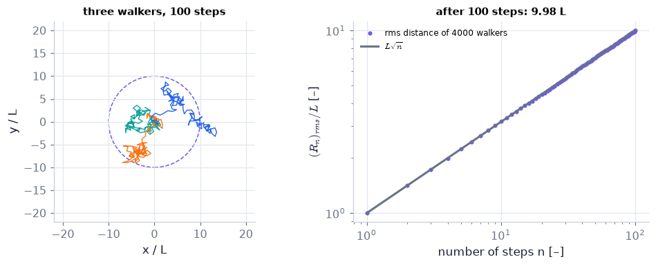

```python
walk = ch12.random_walk(100, 4000, seed=0)                    # 4000 walkers, 100 unit steps in two dimensions
rms_n = np.sqrt((walk**2).sum(axis=2).mean(axis=0))           # ensemble rms distance after each step
fig, (a1, a2) = plt.subplots(1, 2, figsize=(8.6, 3.4))   # a new figure and its panel(s); figsize in inches
for k, col in zip(range(3), (C_FLUC, C_RS, C_BUOY)):   # three individual walkers, one colour each
    a1.plot(walk[k, :, 0], walk[k, :, 1], lw=0.9, color=col)  # three individual paths
a1.add_patch(plt.Circle((0, 0), 10.0, fill=False, color=C_MEAN, ls="--"))   # the circle of radius L√n = 10
a1.set(aspect="equal", xlim=(-22, 22), ylim=(-22, 22), xlabel="x / L", ylabel="y / L", title="three walkers, 100 steps")   # axis labels (with units), title and fixed ranges of this panel
a2.loglog(np.arange(1, 101), rms_n[1:], "o", ms=3, color=C_MEAN, label="rms distance of 4000 walkers")
a2.loglog(np.arange(1, 101), np.sqrt(np.arange(1, 101)), color=C_REF, label="$L\\sqrt{n}$")
a2.set(xlabel="number of steps n [–]", ylabel="$(R_n)_{rms}/L$ [–]", title=f"after 100 steps: {rms_n[-1]:.2f} L")   # axis labels (with units), title and fixed ranges of this panel
a2.legend(fontsize=8)   # the legend names every curve
plt.show()   # display the figure
```

**What you see.** Left: three tangled paths of 100 steps each and a dashed circle of radius 10. Right: the rms distance of 4000 walkers on a straight line of slope ½ on log–log axes.

**How to read it.** No single walker follows the $\sqrt n$ law — some end inside the circle, some outside; the law is for the **ensemble**. One hundred steps take you only ten step lengths away: random steps mostly cancel.

**What would change if…** …successive steps were correlated (`persistence=0.5`): the walk would still spread like $\sqrt n$, but as if each step were longer — which is what a long velocity memory does to dispersion.

📝 **Note.** **N212 [B]** **A smoke plume in a wind** is the same picture with time read as distance, $t=x/U$: the time-averaged plume widens linearly near the source and like $\sqrt x$ far away.

> ⚠️ **slip #13 — the book's figure caption prints** width $\propto x^{1/2}$ near the source and $\propto x$ far away **; the correct statement is** $\propto x$ near (from $(X_\alpha)_{rms}=(u_\alpha)_{rms}t$ (12.121)) and $\propto x^{1/2}$ far (from $(X_\alpha)_{rms}=(u_\alpha)_{rms}\sqrt{2\Lambda_tt}$ (12.123)).

```
Z_rms at x = 10, 100, 1000, 5000 m: [ 0.98  8.58 42.43 98.99] m
```

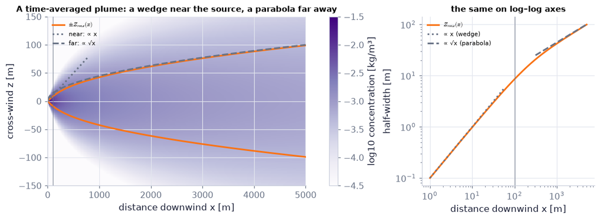

```python
x_pl = np.linspace(1.0, 5000.0, 400)                          # distance downwind [m]
z_pl = np.linspace(-150.0, 150.0, 201)                        # cross-wind coordinate [m]
Zrms = ch12.smoke_plume_width(x_pl, 5.0, 0.5, 20.0)           # rms half-width for wind 5 m/s, w_rms = 0.5 m/s, Λ_t = 20 s
conc = ch12.plume_concentration(x_pl[None, :], z_pl[:, None], 1.0, 5.0, Zrms[None, :])   # Gaussian cross-section, source strength 1 kg/(m s)
fig, (ax, ax2) = plt.subplots(1, 2, figsize=(10.0, 3.6), gridspec_kw=dict(width_ratios=[1.5, 1]))   # a new figure and its panel(s); figsize in inches
x_log = np.geomspace(1.0, 5000.0, 200)                        # the same distances on a logarithmic grid
ax2.loglog(x_log, ch12.smoke_plume_width(x_log, 5.0, 0.5, 20.0), color=C_RS, label="$Z_{rms}(x)$")
ax2.loglog(x_log[x_log < 60], 0.1*x_log[x_log < 60], ":", color=C_REF, label="∝ x (wedge)")
ax2.loglog(x_log[x_log > 300], 0.5*np.sqrt(8.0*x_log[x_log > 300]), "--", color=C_REF, label="∝ √x (parabola)")
ax2.axvline(100.0, color=C_REF, lw=0.6)                       # x = U Λ_t = 100 m, where the particles have forgotten their first velocity
ax2.set(xlabel="distance downwind x [m]", ylabel="half-width [m]", title="the same on log–log axes")   # axis labels (with units), title and fixed ranges of this panel
ax2.legend(fontsize=7)   # the legend names every curve
pc = ax.pcolormesh(x_pl, z_pl, np.log10(np.maximum(conc, 1e-6)), cmap="Purples", shading="auto", vmin=-4.5, vmax=-1.5)
ax.plot(x_pl, Zrms, color=C_RS, label="$\\pm Z_{rms}(x)$"); ax.plot(x_pl, -Zrms, color=C_RS)
ax.plot(x_pl[x_pl < 800], 0.5*x_pl[x_pl < 800]/5.0, ":", color=C_REF, label="near: ∝ x")
ax.plot(x_pl, 0.5*np.sqrt(2*20.0*x_pl/5.0), "--", color=C_REF, label="far: ∝ √x")
ax.axvline(5.0*20.0, color=C_REF, lw=0.6)   # a thin reference line
fig.colorbar(pc, label="log10 concentration [kg/m³]")   # the colour scale and what it measures
ax.set(xlabel="distance downwind x [m]", ylabel="cross-wind z [m]", ylim=(-150, 150), title="A time-averaged plume: a wedge near the source, a parabola far away")   # axis labels (with units), title and fixed ranges of this panel
ax.legend(fontsize=7, loc="upper left")   # the legend names every curve
print("Z_rms at x = 10, 100, 1000, 5000 m:", np.round(ch12.smoke_plume_width(np.array([10.0, 100.0, 1000.0, 5000.0]), 5.0, 0.5, 20.0), 2), "m")
```

**What you see.** A plume (colour = concentration) spreading to the right, with its rms half-width in orange. Up to about $x=U\Lambda_t=100$ m (thin vertical line) the edge follows the dotted straight line; far downstream it follows the dashed $\sqrt x$ curve. Right: the half-width on log–log axes, where the near-source wedge (slope 1, the first 100 m — only 2 % of the left panel) and the far-field parabola (slope ½) are both plain to see.

**How to read it.** Read $x$ as time: $t=x/U$. The half-width is about 1 m at 10 m, 8.6 m at 100 m, 42 m at 1 km and 99 m at 5 km — tenfold in distance gives nearly tenfold in width near the source and only $\sqrt{10}\approx3$-fold far away.

**What would change if…** …the atmosphere were stable (a night-time inversion): $w_{rms}$ and the vertical memory time fall, and the plume stays a thin ribbon for kilometres.

#### 🧮 Derivation — The eddy diffusivity: $\nu=\tfrac12\,d\sigma^2/dt$, $D_T=\overline{u_\alpha^2}\int_0^tr_\alpha\,d\tau$ and its two limits (the printed condition corrected) `D28` ★ (Eq. 12.127: $D_T\equiv\frac12\frac{d}{dt}(\overline{X_\alpha^2})=\overline{u_\alpha^2}\int_0^tr_\alpha(\tau)\,d\tau$)

**What we want to show.** Define an "effective diffusivity" for turbulent spreading and see why it is not a constant.

**Assumptions.** As D26.

**The plan.**

1. Read a diffusivity off the growth of a variance.
2. Apply the same reading to the cloud of particles.
3. Take the two limits.

**Tools we use** (each explained before this point): Gaussian spreading (ch01 σ² = 2Dt, R08) · D26's $\frac{d}{dt}\overline{X_\alpha^2}=2\overline{u_\alpha^2}\int_0^tr_\alpha\,d\tau$ (12.117) · limits (D27)

**We start from**

$$ \begin{array}{l}\text{the molecular yardstick (R07): a diffusing patch is a Gaussian whose variance} \\ \text{per coordinate grows as}\ \sigma^2=2\nu t\ \text{.}\end{array} $$

**Step 1 of 7 — Recall how a diffusing patch grows.**

$$ \sigma^2=2\,\nu\,t $$

- *Why we can do this:* The Gaussian solution of the diffusion equation, $\propto\exp(-r^2/4\nu t)$, has variance 2νt along each coordinate (Ch. 1; R07).
- *In words:* Under diffusion the variance grows linearly in time.

**Step 2 of 7 — Solve for the diffusivity.**

$$ \nu=\dfrac12\dfrac{d\sigma^2}{dt} $$

- *Why we can do this:* Differentiate step 1. This is (12.126), $\nu=\frac12\frac{d\sigma^2}{dt}$: a diffusivity is half the growth rate of a variance.
- *In words:* A recipe to *measure* a diffusivity from a spreading cloud.

**Step 3 of 7 — Apply the recipe to turbulent dispersion.**

$$ D_T\equiv\dfrac12\dfrac{d}{dt}\big(\overline{X_\alpha^2}\big) $$

- *Why we can do this:* $\overline{X_\alpha^2}$ is the variance of the particle cloud along α; this defines an effective (eddy) diffusivity. First part of (12.127), $D_T\equiv\frac12\frac{d}{dt}(\overline{X_\alpha^2})=\overline{u_\alpha^2}\int_0^tr_\alpha(\tau)\,d\tau$.
- *In words:* How fast the cloud's variance is growing right now.

**Step 4 of 7 — Insert the rate from Taylor's analysis.**

$$ D_T=\overline{u_\alpha^2}\displaystyle\int_0^tr_\alpha(\tau)\,d\tau $$

- *Why we can do this:* $\frac{d}{dt}\overline{X_\alpha^2}=2\overline{u_\alpha^2}\int_0^tr_\alpha\,d\tau$ (12.117), halved. Second part of (12.127), $D_T\equiv\frac12\frac{d}{dt}(\overline{X_\alpha^2})=\overline{u_\alpha^2}\int_0^tr_\alpha(\tau)\,d\tau$.
- *In words:* The eddy diffusivity is the velocity variance times the memory used so far.

**Step 5 of 7 — Short times.**

$$ t\ll\Lambda_t:\quad r_\alpha\approx1\ \Rightarrow\ D_T\cong\overline{u_\alpha^2}\,t $$

- *Why we can do this:* As D27 step 1. This is (12.128), $D_T\cong\overline{u_\alpha^2}\,t\ \text{for}\ t\ll\Lambda_t$.
- *In words:* At first the "diffusivity" grows in proportion to time — not a diffusion process.

**Step 6 of 7 — Long times.**

$$ t\gg\Lambda_t:\quad\displaystyle\int_0^tr_\alpha\,d\tau\to\Lambda_t\ \Rightarrow\ D_T\cong\overline{u_\alpha^2}\,\Lambda_t $$

- *Why we can do this:* As D27 step 4. This is (12.129), $D_T\cong\overline{u_\alpha^2}\Lambda_t\ \text{for}\ t\gg\Lambda_t$ with the condition corrected: the page prints $t\ll\Lambda_t$ (slip #12).
- *In words:* Only after several memory times does the diffusivity settle to a constant.

**Step 7 of 7 — Read it as a length times a velocity.**

$$ D_T=u_{rms}\times\big(u_{rms}\Lambda_t\big)=u_T\,l_T $$

- *Why we can do this:* $\overline{u_\alpha^2}=u_{rms}^2$; $u_{rms}\Lambda_t$ is the distance a particle travels while it remembers its velocity. This is $\nu_T\sim l_Tu_T$ (12.98), now derived.
- *In words:* The eddy diffusivity of C12, with its length identified.

**Result**

$$ \begin{array}{l}D_T\equiv\tfrac12\frac{d}{dt}\overline{X_\alpha^2}=\overline{u_\alpha^2}\int_0^tr_\alpha\,d\tau\ \text{(12.127);}\ D_T\cong\overline{u_\alpha^2}t\ \text{for}\ t\ll\Lambda_t\ \text{(12.128);} \\ D_T\cong\overline{u_\alpha^2}\Lambda_t\ \text{for}\ t\gg\Lambda_t\ \text{(12.129)}\end{array} $$

*In words:* An eddy diffusivity grows before it saturates

**What it means.** a constant-D (Fickian) model of a plume is right far downwind and wrong near the stack, where the plume is a wedge; and for a *patch* that keeps meeting larger eddies as it grows, the effective diffusivity keeps growing with its size, $K\sim\bar\varepsilon^{1/3}l^{4/3}$ (Richardson). **Fails when:** the scale of the cloud is comparable with the largest eddies of an inhomogeneous flow.

**Check it.** Units — (m²/s²)(s) = m²/s ✓. Exponential memory: $D_T=\overline{u^2}\Lambda_t(1-e^{-t/\Lambda_t})$: 0.95, 6.32, 10.0 m²/s at t = 1, 10, 100 s for u_rms = 1 m/s, Λ_t = 10 s. Against air's molecular ν = 1.5 × 10⁻⁵ m²/s: 10⁶ times larger.

📝 **Notes taught inside `D28`:** **N213 [B]** the eddy diffusivity $D_T\equiv\frac12\frac{d}{dt}(\overline{X_\alpha^2})=\overline{u_\alpha^2}\int_0^tr_\alpha(\tau)\,d\tau$ (12.127) (steps 3–4) · **N214 [B]** $D_T\cong\overline{u_\alpha^2}t$ for $t\ll\Lambda_t$ (12.128) (step 5) · **N215 [B]** $D_T\cong\overline{u_\alpha^2}\Lambda_t$ for $t\gg\Lambda_t$ (12.129) (step 6).

> ⚠️ **slip #12 — the book prints** the condition $t\ll\Lambda_t$ on the constant value $D_T\cong\overline{u_\alpha^2}\Lambda_t$ (12.129) **; the correct form is** $t\gg\Lambda_t$: the constant is the long-time limit (at $t=0.01\Lambda_t$ the constant would be 100 times the true diffusivity).

> ⚠️ **Common confusion (traps in `D28`):** σ² = 2νt per coordinate here, while Ch. 3's vortex core radius used 4νt; treating $D_T$ as a property of the fluid; the printed condition $t\ll\Lambda_t$ on $D_T\cong\overline{u_\alpha^2}\Lambda_t$ (12.129) (⚠️ slip #12: it holds for $t\gg\Lambda_t$).

```python
D_num = ch12.eddy_diffusivity_taylor(tt3, lambda s: np.exp(-s/10.0), 1.0)     # Eq. (12.127) for the exponential memory at t = 1, 10, 100 s
print("D_T at t = 1, 10, 100 s:", np.round(D_num, 3), "m²/s = closed form", np.round(ch12.eddy_diffusivity_exponential(tt3, 1.0, 10.0), 3))   # Eq. (12.127) by quadrature and in closed form
print("short-time form u²t at t = 1 s:", ch12.eddy_diffusivity_asymptote(1.0, 1.0, 10.0, which="short"), "| long-time form u²Λ_t at t = 100 s:", ch12.eddy_diffusivity_asymptote(100.0, 1.0, 10.0, which="long"))   # Eqs. (12.128) and (12.129), each inside its own range
print("the constant under the PRINTED condition, at t = 0.1 s:", ch12.eddy_diffusivity_asymptote(0.1, 1.0, 10.0, which="long", printed=True),   # slip #12: the constant used at short times (as printed) …
      "m²/s — the true value there is", round(float(ch12.eddy_diffusivity_exponential(0.1, 1.0, 10.0)), 4))   # … against the true diffusivity at t = 0.1 s
D_part = ch12.diffusivity_from_variance(t_l, X2)              # Eq. (12.126) applied to the particles: ½ d mean(X²)/dt
print(f"from the particles at t = 100 s: D_T ≈ {D_part[-5:].mean():.1f} m²/s (theory {ch12.eddy_diffusivity_exponential(100.0, 1.0, 10.0):.1f})")   # ½ d mean(X²)/dt of the particle cloud at late times
```

```
D_T at t = 1, 10, 100 s: [ 0.952  6.321 10.   ] m²/s = closed form [ 0.952  6.321 10.   ]
short-time form u²t at t = 1 s: 1.0 | long-time form u²Λ_t at t = 100 s: 10.0
the constant under the PRINTED condition, at t = 0.1 s: 10.0 m²/s — the true value there is 0.0995
from the particles at t = 100 s: D_T ≈ 9.9 m²/s (theory 10.0)
```

**What does the code above do?**

1. `ch12.eddy_diffusivity_taylor(t, r_fn, u2)` is half the spreading rate: 0.95, 6.3 and 10.0 m²/s — it **grows** from $u^2t$ toward $u^2\Lambda_t$ (step 4 of the tiny example).
2. `ch12.eddy_diffusivity_asymptote(..., which=…)` returns each limiting form where its condition holds; `printed=True` applies the constant under the printed (wrong) condition: 10 m²/s at $t=0.1$ s, a hundred times the true 0.1 m²/s (slip #12).
3. `ch12.diffusivity_from_variance` (recap R08) applied to the particle cloud returns about 10 m²/s at late times.

```python
t_f8 = np.geomspace(0.1, 1000.0, 100)                        # times [s]

def f8(Lam):                                                  # curves for one memory time Λ_t [s] (u_rms = 1 m/s)
    Xr = np.sqrt(ch12.taylor_dispersion_exponential(t_f8, 1.0, Lam))   # exact X_rms(t)
    return {"X_rms (Taylor)": (t_f8, Xr), "ballistic u_rms t": (t_f8, 1.0*t_f8),   # hand the result back to the caller
            "diffusive u_rms √(2 Λ_t t)  (= a constant diffusivity u²Λ_t from the start)": (t_f8, np.sqrt(2*Lam*t_f8))}

figF8 = slider_figure(f8, "Λ_t", np.round(np.geomspace(1.0, 100.0, 13), 2), unit="s", xlabel="time t [s]",
                      ylabel="X_rms [m]", title="The bend from t to √t sits at the memory time")
figF8.update_xaxes(type="log", range=[-1, 3])                 # logarithmic time axis
figF8.update_yaxes(type="log", range=[-1.5, 3.2])             # logarithmic vertical axis
figF8.show()   # display the interactive figure (the slider works on the web page too)

def f8d(Lam):                                                 # the eddy diffusivity for the same slider values, on its own axes
    return {"eddy diffusivity D_T(t)": (t_f8, ch12.eddy_diffusivity_exponential(t_f8, 1.0, Lam)),   # hand the result back to the caller
            "short-time form u² t": (t_f8[t_f8 < Lam], 1.0*t_f8[t_f8 < Lam]), "long-time value u² Λ_t": ([Lam, 1000.0], [Lam, Lam])}

figF8d = slider_figure(f8d, "Λ_t", np.round(np.geomspace(1.0, 100.0, 13), 2), unit="s", xlabel="time t [s]",
                       ylabel="D_T [m²/s]", title="The eddy diffusivity grows, then levels off at u²Λ_t")
figF8d.update_xaxes(type="log", range=[-1, 3])                # logarithmic time axis
figF8d.update_yaxes(type="log", range=[-1.2, 2.3])            # logarithmic diffusivity axis
figF8d.show()   # display the interactive figure (the slider works on the web page too)
```

[interactive chart not shown]

**What does the code above do?**

1. `f8(Lam)` returns the exact rms displacement and its two limits; the diffusive line is also what a **constant** diffusivity $D=u^2\Lambda_t$ would give from the start — the "Fickian ghost".
2. `f8d(Lam)` puts the eddy diffusivity $D_T(t)$ on its own axes (its unit is m²/s, not m), with its short-time form and its long-time value.

**What you see.** Drag $\Lambda_t$: the purple curve follows the ballistic line up to $t\approx\Lambda_t$ and the diffusive line after; the bend moves with the slider. In the second figure the diffusivity rises linearly and levels off at $u^2\Lambda_t$ — ten times higher for ten times the memory.

**How to read it.** Near the source the constant-diffusivity (diffusive) line lies far **above** the true width: Fickian diffusion spreads a fresh puff much too fast, because it assumes the particles have already forgotten their velocities.

**What would change if…** …the turbulence were twice as intense at the same memory time: every curve shifts up by a factor 2 ($X_{rms}$) or 4 ($D_T$); the bend stays at $t\approx\Lambda_t$.

📝 **Note.** **N216 [B]** **Turbulent diffusion is not molecular diffusion with a bigger constant.** Near the source a constant-$D$ model spreads a puff like $\sqrt t$ — far too wide a start — and a patch that keeps growing is stirred by ever larger eddies, so its effective diffusivity keeps growing too (Ch. 10 drew the same line between a numerical and an eddy diffusivity).

📝 **Note.** **N06 [B]** **Richardson's four-thirds law**, stated here where both ingredients exist. In the inertial range (C08) the effective diffusivity $K$ [m²/s] for a patch of size $l$ can depend only on $l$ and $\bar\varepsilon$; dimensions leave one combination, $K\sim\bar\varepsilon^{1/3}l^{4/3}$. **Climate hook:** this is why tracer diffusivities in ocean models are chosen to depend on the grid size.

```python
print("dimensionless group:", DIM.solve_exponents("K", ["eps", "l"], {"K": {"L": 2, "T": -1}, "eps": {"L": 2, "T": -3}, "l": {"L": 1}}))   # K ε̄^(−1/3) l^(−4/3)
print(f"1 km patch in the ocean (ε̄ = 1e-8 m²/s³): K ≈ {ch12.richardson_diffusivity(1000.0, 1e-8):.0f} m²/s;  in the atmosphere (ε̄ = 1e-3): K ≈ {ch12.richardson_diffusivity(1000.0, 1e-3):.0f} m²/s")
```

```
dimensionless group: {'K': Fraction(1, 1), 'eps': Fraction(-1, 3), 'l': Fraction(-4, 3)}
1 km patch in the ocean (ε̄ = 1e-8 m²/s³): K ≈ 22 m²/s;  in the atmosphere (ε̄ = 1e-3): K ≈ 1000 m²/s
```

**What does the code above do?**

Chapter 1's Π-theorem solver finds the one dimensionless group, i.e. $K\propto\bar\varepsilon^{1/3}l^{4/3}$; `ch12.richardson_diffusivity(l, eps)` evaluates it with a constant of order one: about 22 m²/s for a 1 km patch in the ocean and 1000 m²/s in the atmosphere.

#### 🎮 Interactive: Why t first and √t later?

**Why interactive rather than a static figure:** the particles spread on one clock with the mean-square-displacement curve changing slope from 2 to 1 as t passes the memory time; dragging the memory time moves the bend; a constant-diffusivity ghost shows how wrong Fickian diffusion is near the source; the plume mode maps t to x/U.

Start with the **Walkthrough**; the **Explain** tab works every number out with your settings, and the **Derivation** tab steps through the same derivation as above.

**What to try:**

- Press ▶ and watch the local slope readout fall from 2 to 1.
- Drag Λ_t up tenfold: the bend moves tenfold later and the final D_T is ten times larger.
- Switch to 'plume in a wind': the same curve drawn in space.
- Compare with the constant-D ghost at t = 0.1 Λ_t.

```python
show_viz("ch12", "taylor_dispersion")   # full-width explainer; ⤢ Full screen for more room
```

🎮 Interactive 10/10 Why does a puff spread like t, then like √t? Open alone ↗

[interactive chart not shown]

**What would change if…** …the planet rotates and the fluid is stratified on the large scale? The eddies become flat, nearly two-dimensional, and their energy moves to *larger* scales instead of smaller ones — C07's cascade turned round. The tools of this chapter (averages, Reynolds stresses, eddy viscosity, Ri and $L_M$, dispersion) all carry over; the next chapter adds the Coriolis force to them.

## 12.13 Concluding Remarks

**What is this section about?** Where the subject goes from here.

📝 **Note.** **N217 [C]** **Turbulence remains an open research field.** What this chapter left out comes next: Ch. 13 adds rotation and large-scale stratification — eddy-viscosity Ekman layers (C12), surface layers (C11, C15), and geostrophic turbulence, whose energy flows toward *larger* scales, with a steeper spectrum at small scales than C08's −5/3. Direct and large-eddy simulation are named in Ch. 10.

*↪ **S01** — The chapter's exercises are not reproduced. Results this lesson derived or stated that appear among them: the moment identities (N22), the real, even spectrum (D05), the periodogram (N38), the Taylor microscale (D04), frozen turbulence (N40), the mean scalar equation (N57), the mean-flow energy budget (D09), the Reynolds-stress equation (N59), the isotropic tensor and dissipation (D07, D08), the exponents of the free shear flows (D16), laminar vs turbulent skin friction (N161), the channel force balance (D17), the pipe friction law (N160), dispersion for a Gaussian correlation (N208).*

*↪ **S02** — Literature: public sources are cited where used (Sreenivasan 1995; Lee & Moser 2015; Launder & Sharma 1974; McKeon, Zagarola & Smits 2005 for Prandtl's law; Monkewitz, Chauhan & Nagib 2007; Nagib & Chauhan 2008; Pao 1965; Spalding 1961; Coles 1956; Taylor 1921). For more: Pope, *Turbulent Flows*; Tennekes & Lumley, *A First Course in Turbulence*.*

## ✅ What should have clicked

- **C01** An average passes through every linear operation and fails on a product: $\overline{\tilde u\tilde v}=\bar u\bar v+\overline{uv}$.
- **C02** The area under the autocorrelation is the memory time $\Lambda_t$; a record is worth about $\Delta t/\Lambda_t$ independent samples.
- **C03** The spectrum is the Fourier transform of the autocorrelation: long memory, narrow spectrum; its area is the variance.
- **C04** Averaging the momentum equation leaves one new term, the Reynolds stress $-\rho_0\overline{u_iu_j}$ — a covariance, with $\overline{uv}<0$ in a positive shear, and no equation of its own.
- **C05** With no preferred direction, one function $f(r)$ fixes every two-point correlation, and $\bar\varepsilon=15\nu\overline{u^2}/\lambda_g^2$.
- **C06** Shear production leaves the mean-flow budget and enters the turbulent one with the opposite sign; dissipation ends it.
- **C07** The big eddies set $\bar\varepsilon\sim\Delta U^3/L$; viscosity only sets $\eta=(\nu^3/\bar\varepsilon)^{1/4}$, and $\eta/L\sim\mathrm{Re}_L^{-3/4}$.
- **C08** Between $L$ and $\eta$ only $\bar\varepsilon$ and $k_1$ matter, so $S_{11}\propto\bar\varepsilon^{2/3}k_1^{-5/3}$.
- **C09** A conserved momentum flux plus shape-keeping give $\delta\propto x$ and $U_{CL}\propto x^{-1/2}$ for the plane jet.
- **C10** Near a smooth wall $\tau_0$ and $\nu$ alone set the scales: $U^+=f(y^+)$, and $U^+=y^+$ in the sublayer.
- **C11** Where the answer may depend on neither the viscous nor the outer length, $y\,dU/dy=u_*/\kappa$: a logarithm.
- **C12** An eddy viscosity is a length times a velocity of the flow; $l_T=\kappa y$ returns the log law, and wall damping sets its intercept.
- **C13** The k–ε model builds $\nu_T=C_\mu\bar e^2/\bar\varepsilon$ from two transport equations; its constants are tied to the decay exponent of grid turbulence and to $\kappa$.
- **C14** Rf = buoyant destruction / shear production; turbulence starves near $\mathrm{Rf}\approx\tfrac14$; $\mathrm{Ri}=\mathrm{Pr}_T\,\mathrm{Rf}$.
- **C15** $L_M$ is the height where buoyancy matches shear: $\mathrm{Rf}=z/L_M$.
- **C16** A cloud spreads like $t$ while particles remember their velocity and like $\sqrt t$ afterwards; the eddy diffusivity grows to $\overline{u^2}\Lambda_t$.

**What later chapters build on**

- Ch. 13 (geophysical fluid dynamics): eddy viscosity in Ekman layers; the surface layer and bulk drag; Ri-dependent mixing; geostrophic turbulence spectra; `TS.periodogram` for wave and eddy spectra.
- Ch. 14 (aerodynamics): turbulent skin friction on airfoils.
- Ch. 15 (compressible flow): friction in ducts.

**Not taught here (and where to find it)**

- Direct and large-eddy simulation (named in Ch. 10; Pope, *Turbulent Flows*).
- Intermittency and structure functions (Frisch, *Turbulence*).
- Reynolds-stress closures (Pope, ch. 11).
- Two-dimensional and geostrophic turbulence (Ch. 13).

← All chapters

← PreviousNext →

Code and explanations: shammun/fluidpy (MIT). The book is not reproduced here; equations are cited by number.